# 阿斯伯格综合征完全指南

# 第五章 心理理论

这个男孩说话的声调怪异，讲话方式和动作方式也很奇特。因此，他缺乏了解其他人话语的能力，很难作出适当的回应，也就不足为奇了。

——汉斯·阿斯伯格（［1944］1991）

心理理论（Theory of Mind，简称 ToM）是一个心理学概念，指的是一个人为了理解他人的行为和预测对方接下来的行动，所需要的识别和理解他人的想法、信念、愿望和意图的能力。这一概念也可以称作“想法解读”（Baron–Cohen 1995）。通俗地说，就是“站在其他人的角度思考”，还有一个类似的概念是“同理心”（Gillerg 2002）。有阿斯伯格综合征的儿童和成年人，不具有与其生理年龄相符的心智能力，难以通过外在线索识别和理解他人的想法或感受。

阿斯伯格综合征的诊断评估应包括对儿童或成人的心理理论能力成熟度的检测，我们已经发展出一系列针对儿童、青少年或成人的测试（Attwood 2004d）。针对不同年龄段，我们通过一些故事和相应的问题来评估受试者识别故事人物想法和感受的能力。弗朗西丝卡·哈佩（Francesca Happé）曾针对4～12岁的孩子设计了“奇怪的故事”测试（Strange Stories，Happé 1994），尼尔斯·卡兰达（Nils Kaland）和同事们为青少年设计了“日常生活中的故事”测试（Stories from Everyday Life，Kaland et al.2002）。西蒙·巴伦·科恩和萨莉·惠尔赖特（Sally Wheelwright）设计了符合成年人心理理论的测试工具（Baron-Cohen 2003）。在这些测试中，由医护人员记录儿童或成人能否提供体现心理理论能力的答案，并且记录答题时间，然后和同龄对照组的成绩相对比；此外，还要了解受试者提供的正确答案是经过了分析，还是死记硬背的学习和记忆，或依赖瞬间反应或直觉。

普通孩子，特别是5岁以上的孩子，通常已经非常善于感知和理解社交线索，从而明白他人的想法和感受。这就像他们的大脑在挑选周围环境中的信息时，会优先选取社会性线索，而且他们也拥有一套心理理论能力去理解社会线索的含义，并作出适当的回应。这种能力主宰了普通人的知觉，甚至令我们愿意采用拟人化的观点，把人类的社会性行为投射到动物和无生命的物体上。

阿米·克林（Ami Klin 2000）在海德和西梅尔（Heider，Simmel 1944）原创的“社会属性任务”（Social Attribution Task）的基础上，进行了一项非常耐人寻味的研究。他们制作了一部以几何图形为角色的动画片，这些角色要么和其他图形一起运动，要么因为其他图形的动作而引发一些动作。这部短片只有50秒钟，包含六个连续的部分。在观赏每个部分的时候，观众都要回答“影片中到底发生了什么事情”，并要求他们为这段无声影片加一段旁白。观众还被问到类似“那个大三角形或小的圆圈，是什么样的人”这样的问题。这项研究的创始人发现，普通大学生往往会采用拟人化的字眼来描述图形的运动（比如，追逐、坑害或游戏）和感受（比如，害怕、兴高采烈或沮丧）。

用“社会属性任务”来测试阿斯伯格综合征青少年，发现他们和同龄对照组的表现有着明显差异。通常他们的旁白比较短，而且缺少详细的社会性情节。很多人的评论内容与影片毫不相关，而且他们从影片中找到的社会性要素也只有对照组的四分之一。他们较少运用心理理论词汇，即使用了也是社会复杂度比较低的；也很少猜测对方意图，可分析出的人格特征比较少，而且相对简单。在对照组所叙述的故事中，一些模糊不清的场景也很容易被赋予社会性含义，包括对勇敢或兴高采烈的描述、复杂的人格和社会归属类型的分析，最终能得到一个连贯的社交故事。相比之下，阿斯伯格综合征青少年给出的旁白会使用不同的词汇来说明图形的动作，他们更多强调物体本身的属性，比如，描述某一动作是基于磁场的作用而产生的跳跃或震动。由此可见，阿斯伯格综合征人士更善于察觉周围的物理世界，而不是社会世界。

另一项采用拟人化的几何形状所做的研究表明，阿斯伯格综合征成年人较少使用心理状态来描述行动。这项研究还确认了大脑的哪些部位参与了思考的过程（Castelli et al.2002）。对于普通成年人，心智活动经由前额叶皮质（prefrontal cortex）、颞上沟（superior temporal sulcus）和颞极（temporal poles）来进行；而参与研究的阿斯伯格综合征成年人大脑的这些部分都不太活跃。因此，阿斯伯格综合征心理理论能力的损伤和迟缓有了神经学上的解释。

有学者提到，心理理论能力的缺损会影响到自我意识和自省能力（Frith and Happé 1999）。我曾经和一位阿斯伯格综合征青少年科里（Corey）谈到过“想法解读”的能力。他说：“我不怎么擅长猜测别人在想什么，我甚至都不确定自己在想什么。”阿斯伯格综合征个体普遍存在理解想法和感受的困难，不管是面对他人还是自己。

不过重要的是，我们理解他们的问题源于心理理论能力和同理心的不成熟或迟缓，而不是完全缺乏同理心。如果暗指阿斯伯格综合征个体缺乏同理心，这对他们是一个可怕的侮辱，因为这句话意味着他们完全无法识别和关注别人的感受。事实上，他们非常关注他人，只是没有能力来识别情感状态中比较细微的线索，或解读出复杂的心理状态。

## 一、心理理论能力缺损对日常生活的影响

虽然我们知道阿斯伯格综合征个体很难了解其他人的想法和感受，但我们依然很难想象这对日常生活的影响，因为“想法解读”对普通人是那么简单，凭着直觉就能进行。我们能“阅读”一张脸，翻译身体语言和口语韵律中的含义；我们也能轻易识别出那些透露他人当前或预期的线索。但是因为心理理论能力的缺陷或发育迟缓，阿斯伯格综合征儿童和成人往往会在日常生活中受到影响。下面是一些实例。

### （一）难以通过眼神获取社会性和情感方面的信息

我们怎样知道一个人的想法和感受？方法之一是通过解读他人的面孔——尤其是眼睛周围的区域。众所周知，孤独症谱系障碍里的儿童和成人（包括阿斯伯格综合征）都较少与他人目光接触，他们很少会注视别人的面孔，因此，容易错失一些表情的变化。

克里斯（Chris）是位阿斯伯格综合征青少年，他对天文学有着浓厚的兴趣。在接受正式诊断评估之前，父母要求克里斯不要向我提起他的特殊兴趣，因为他的狂热很容易令人生厌，让人觉得古怪。不过知道他拥有丰富的天文学知识之后，我开始询问克里斯最近电视新闻报道中展示的火星表面照片。克里斯能意识到，当我渴望和他继续探讨有关天文学话题的时候（他自己也乐于这么做），他的父母正注视着他，而他们是反对谈论这个话题的。于是他糊涂了，试图闭上眼睛来逃避父母的目光，不过依然希望我能继续天文学这个话题。接下来我向克里斯解释，我无法和一个闭着眼睛的人交谈，克里斯说：“既然我知道你就在那里，为什么一定要看着你呢？”

注视对方，并不只是为了知道他的位置，或了解他是否移动了位置。我们注视一张面孔，更多是为了从面部表情中解读出对方的想法和感受。当阿斯伯格综合征儿童或成人注视一张面孔的时候，他们到底是在看什么地方呢？在大多数情况下，为了确定对方的想法和感受，普通人注意看对方的眼睛，因为眼睛向来被认为是“心灵的窗户”。通过“眼神追踪”（Eye-tracking）技术，可以测量眼神的凝视位置。最新的研究表明，和对照组相比，阿斯伯格综合征成人较少注视对方的眼睛，而较多关注嘴巴、身体和周围物体（Klin et al.2002a，2002b）。这些设计巧妙的研究主要是通过观察找出受试者在观看影片中的人物互动时到底注视什么地方。在其中一个场景中，对照组被试关注的焦点是演员睁得大大的眼睛所流露出的惊讶和恐怖，而阿斯伯格综合征或高功能孤独症被试则专注于演员的嘴巴。研究结果表明，对照组注视眼睛周围的次数比阿斯伯格综合征和高功能孤独症组多了两倍。如果只注视对方的嘴巴，可能会有助于理解语言表达的信息，但也因此错失了眼睛周围表达出的信息。

其他相关研究表明，即使阿斯伯格综合征被试注视了对方的眼睛，他们解读眼睛含义的能力也远远不如对照组（Baron-Cohen and Jolliffe 1997；Baron-Cohen et al.2001a）。一位阿斯伯格综合征人士的话证实了他们的确无法读出眼睛所表达的信息：“人们通过眼神来交流信息，我却无法了解他们到底在说什么。”（Wing 1992，p.131）在依据眼睛传达的信息理解他人的想法和感受方面，阿斯伯格综合征个体存在两个问题：第一，他们很少注视对方眼睛，而我们知道主要的社会性或情绪沟通是通过眼睛完成的；第二，即使能够注视对方眼睛，他们解读眼神信息的能力也比较差。

### （二）字面解读

心理理论能力的缺陷或迟缓所带来的另一个影响是倾向于只从字面上理解别人的话。我注意到阿斯伯格综合征孩子常常对“Hop on the scales”（字面意义：在天平上跳。实际意义：起了决定性的作用。）这类俗语的理解仅限于字面意思，对于“Let’s toast the bride”（字面意义：让我们烘烤新娘。实际意义：让新娘祝酒。）甚至会产生情绪上的激烈反应，他们往往对于“It’s about time that you pulled your socks up”（字面意义：你该把袜子提起来了。实际意义：你该振作起来了。）这类英语中的隐喻感到困惑。还有一个例子，当一个阿斯伯格综合征孩子写完一篇文章，他妈妈奇怪为什么他要在文章结尾画一幅图，他解释说因为老师要求在文章的最后必须“作出自己的结论”（draw his own conclusions）。（这孩子以为“draw”在这里还是字面上的“画”的意思，而不是“作出”的意思。）

近年来，我们已经知道阿斯伯格综合征儿童和成人无法从别人脸上识别相关的社会性线索以及解读他人的想法和感受，但最近一些新的研究证据表明，他们也很难从别人谈话的声调和韵律中了解其代表的含义（Kleinman，Marciano and Ault 2001；Rutherford，Baron-Cohen and Wheelwright 2002），而这些内容正是让听众超越字面理解对方意图的关键所在。我们可以通过理解对方的面部表情和说话语调是否协调，从而察觉对方是否在嘲笑或讽刺，而阿斯伯格综合征儿童和成人对讽刺的语言通常感到困惑，容易轻信，认为对方说的都是真心话，也因此常常成为被捉弄的对象。

### （三）被认为不尊重他人和态度粗鲁

由于不耐烦阿斯伯格综合征孩子以自我为中心的独断行为和谈话方式，其他成人和孩子会微妙地暗示他终止，但他们可能不会注意和理解这些线索，因此容易违犯社交规则，并且对警告信号无动于衷。如果其他成人和孩子不了解这种表现本质上是由于心理理论能力的缺陷和发育迟缓所导致，就容易对他们的行为产生道德上的评价，认为这些孩子故意不尊重他人，态度粗鲁。其实他们并没有恶意，通常也不能意识到自己已经冒犯了别人，而他们也很困惑为何别人会生气。

阿斯伯格综合征个体往往非常痴迷于自己的特殊爱好，但是不能认识到其他人不可能像自己一样投入。因为他们在谈话中较少注视对方，往往不能察觉和识别出别人的不耐烦表情，也不能判断这样的主题是否和上下文相关，或能否引起别人同样的兴趣。

当一位妈妈问自己的孩子“今天在学校做什么了”，普通孩子能理解妈妈这样问的时候她已经知道了什么，想要知道什么，或是想要知道学校里是不是发生了一些趣事。而心理理论能力有缺陷的孩子，往往不知道如何回答这类问题。妈妈想要知道从一早进教室到离开学校期间发生的所有事情么？哪些事情对她来说是重要的？她已经知道了什么？阿斯伯格综合征孩子无法从妈妈的角度来界定重要事件，所以可能因为问题太难而拒绝回答，或者事无巨细地陈述一天当中发生的所有事情，使得这一过程变得非常乏味。

斯蒂芬·肖尔（Stephen Shore）曾写给我这段话：“当我到别人家里去做客，人家问我想吃点什么或喝点什么时，我根本不知道怎么回答。我通常会反问：‘你有些什么？’当别人给了我一些选择之后，我才可以轻易从中挑出我想要的，否则，这样的问题对我来说，实在是太难了。”

同样道理，对别人有趣的话题或活动，阿斯伯格综合征个体可能感到很无聊。比如，在学校里年幼的孩子通常要做“分享课程”，他们总是乖乖地坐在下面，非常有兴趣地听台上的孩子表达自己的经验。而对阿斯伯格综合征孩子来说，他们可能无法理解台上的孩子，或者对他人的经验毫无兴趣，所以很快就感到厌烦，然后被老师批评注意力不集中。无论是自己滔滔不绝无视他人的不耐烦，还是对别人的话题不感兴趣，其根源都是心理理论能力的缺陷，而不是不尊重他人，或者故意不遵守行为规范。

### （四）诚实和欺骗

我注意到，阿斯伯格综合征幼儿往往都非常诚实，如果父母问他们是否做了不应当做的事情，他们总是毫不犹豫地承认。其他孩子通常会看出大人在某些时候不是那么清楚（比如，他们其实没有看到是谁做的），而采用欺骗的手段来逃避可能产生的后果。

阿斯伯格综合征个体的另一个特征是他们不知道什么时候应该说“善意的谎言”，也不知道如果在某些场合说了实话，可能会引起对方的反感。比如，有个孩子注意到在超市的结账队伍中有位女士体态肥胖。他用平时说话的口气和音量直接评论这位女士太胖了，真的需要减肥了。这个孩子认为对方应当感谢这样的观察和建议，但这会让孩子的妈妈尴尬不已，也会冒犯那位女士，不过这一切的后续反应都是他想不到的。基于对他人的想法和感受的了解，普通孩子通常会控制自己，但阿斯伯格综合征儿童和成人绝对会忠于诚实及真相，而不太会顾及到别人的想法和感受。

学校里也会发生类似的事情。譬如，当老师不注意的时候，某个孩子可能会做一些顽皮的举动；而当老师意识到有事发生但又不知道是谁做的时候，会要求捣乱者站出来承认。一般来说，普通孩子虽然明知是谁做的也不会表态，因为他们会服从于某种社会潜规则，就像澳洲人常说的“不要告发自己的同伴”，但阿斯伯格综合征孩子只会忠于事实真相，而不是社会群体。当老师询问的时候，他们会很快给出答案，而且不明白为什么其他孩子会迁怒于他，特别是那些没有捣乱行为的孩子，他又没有告发他们，他们怎么也会生他的气呢。对阿斯伯格综合征孩子而言，他们只是合乎逻辑而且正确地回答了老师的问题。

阿斯伯格综合征孩子可能要到十几岁才能最终了解欺骗背后的意图，以及欺骗可以带来的预期结果。这会让父母和老师感到很突然也很困惑，一个往日诚实的孩子（也许仅仅是因为心智缺陷）怎么突然会骗人逃过一劫。不过一般来说，他们这种欺骗行为往往不够高明，很容易被大人识破。

当阿斯伯格综合征孩子的“说谎”行为成为家人和朋友的苦恼时，需要向他们进行合理的解释。首先，由于心理理论能力的缺陷和发育迟缓，阿斯伯格综合征个体可能无法认识到说谎要比闯祸更会得罪人；第二，阿斯伯格综合征个体可能会想到说谎是逃避后果或快速解决社会问题的一种方法，不过，他们往往没有意识到，为了保住面子而用说谎来掩饰，这是一个铁板钉钉的错误。

阿斯伯格综合征成人可能出了名的诚实，有强烈的社会正义感而且坚守原则，他们强烈信守某些道德和伦理原则。不过如果他们的上级并不具有相同的价值观，这些令人钦佩的美德反而会给他们带来相当多问题。我怀疑社会上很多“打黑分子”具有阿斯伯格综合征特征，而且我确实遇到过这样的人，他们在公司或政府部门中将严格的书面行为规范应用到实际中，喜欢举报别人的错误和贪污腐败行为。他们会对自己公司的企业文化感到震惊，惊讶地发现部门经理和同事并不特别支持这种举报，结果是自己的理想幻灭，甚至出现抑郁症状。

### （五）偏执倾向

由于心理理论能力的缺陷或迟缓，阿斯伯格综合征个体很难区分他人的行为是有意为之还是意外发生的。我观察到一个阿斯伯格综合征孩子和同班同学坐在教室地板上听老师讲故事。当老师没看着这边的时候，后边的一个孩子开始用手指戳他的后背逗弄他，他变得越来越恼火，最终回头打了那个孩子，命令他住手。老师注意到了这个情况，但是没有注意到之前发生的事情，因此批评了这个孩子的攻击性行为。如果是普通孩子遇到这样的事情，他们会向老师解释自己被挑衅的经过，而且能认识到如果老师知道事情的来龙去脉就会有更公平的处理，但那个孩子却一直保持沉默。老师继续讲故事，过了一会儿，一个孩子上厕所回来经过那个孩子的时候，无意中碰到了他，而他不能理解这是个意外，还是出手打了那个孩子，就像打先前欺负他的那个孩子一样。还好，老师明白他真的无法区分对方的行为是故意还是意外，因此，主动解释并解决了这个事件。

还要加以说明的是，如果阿斯伯格综合征儿童和成人具有明显受迫害幻想症的倾向，可能来源于他们个人的社会经验，因为他们比同龄人遭遇过更严重的蓄意挑衅和捉弄。一旦怀疑其他孩子怀有敌意，与对方的任何互动都会让他困惑，甚至会怀疑对方的所有行动都带有故意的侵犯性；普通孩子则更有能力根据当时的气氛和社会性线索，理解其他孩子的真实意图。

### （六）解决问题

普通孩子在年幼的时候就能认识到，一定会有其他人能帮助自己解决生活中的实际问题，其中一些人是真的有兴趣并乐意提供帮助，但阿斯伯格综合征孩子很难自发地察觉他人的想法和能力。当他们遇到问题时，“向可能知道解决办法的人寻求指导”通常不是他们脑海中浮现的第一个念头（甚至不是第二个）。他们常常对那些就在身边、明显能够提供帮助的人视而不见，最终决定由自己来解决。

### （七）处理冲突

随着年龄的成长，普通孩子会变得越来越成熟，越来越善于说服、妥协以及处理冲突。他们越来越能够了解别人的观点，也知道如何听取他人积极的策略，怎样影响别人的想法和情感。成功处理冲突需要相当的心理理论能力，因此，可以预见阿斯伯格综合征儿童或成人必然欠缺处理冲突的能力。观察他们在实际生活中处理冲突的情况，我们可以看出他们的心智相对不成熟，缺乏变通的协商手段，而且倾向于采用对立的心态。他们通常使用“原始的”冲突处理策略，比如，恐吓或固执坚守自己的观点。他们总是不明白，如果对他人友好一些，或许更有可能得到自己想要的。在经过一番激烈的争论之后，他们也不太会出现懊悔的心情，或意识到修复他人的情感（比如道歉）是有意义的。

在儿童时期的每个阶段，阿斯伯格综合征孩子都需要成人的指导来解决冲突，不过到了青少年时期，我们期望他们自己有能力去妥协、分辨和了解其他人的观点，学会协商、原谅和忘记冲突。阿斯伯格综合征青少年可能依然难以掌握这些能力，他们会表现出类似对立和反抗障碍（Oppositional and Defiant Disorder）的症状。在这个阶段，他们解决冲突的特征如下。

难以概括他人的观点和喜好。

说服他人的技巧有限。

倾向于对立和死板处理问题。

不愿意改变自己的决定，不愿意承认自己的错误。

讨厌被人打断。

具有一定要完成某件事的强迫心理。

倾向于惩罚对方而不是奖励。

倾向于逃避他人的要求。

不善于变通。

因此，他们常常会反对其他人的决定，违抗他人的喜好，否定他人的理由。他们都曾有过这样的经历：固执坚持自己的决定直到其他人屈服，而无法看出其实对方认为不继续争论才是更明智的做法。别的孩子有能力觉察朋友的观点、喜好和理由，至少会为了友谊而迁就他人的要求和决定，并且知道这样做会提高友谊的互惠性。阿斯伯格综合征孩子则需要有人引导来了解什么时候以及如何做出请求，如何聆听和吸收别人的观点和倾向，如何协商做出某些协议和妥协，如何寻求并接受评判者的决定。总而言之，他们需要学习的是，不要因为情绪（尤其是愤怒）而干扰整体情况。我们可以用角色扮演游戏向他们解释适当和不适当的冲突解决策略。

### （八）内省及自我意识

尤塔·弗里思和弗朗西丝卡·哈佩（Frith 1999）曾经提到，由于在认知发展过程中，阿斯伯格综合征孩子心理理论能力的先天情况和后天发展与其他孩子不一样，他们也会发展出与众不同的自我意识。由于他们主要通过后天智力发展和生活经验而不是依靠先天直觉掌握心理理论能力，因此，在自我反省和解读他人心理时所表现的自我意识与众不同。弗里思和哈佩（Frith 1999）形容，他们这种较高层面的自我反省和明确的自我意识形式与哲学家颇为相似。

我读过一些阿斯伯格综合征成人的自传，同意他们的确具有准哲学家的风范。当他们用不同的方式来思考和感知世界时，他们高超的智能会使我们现有的哲学体系取得新的进展。有意思的是，哲学家维根斯坦（Ludwig Wittgenstein）的确具有很多与天资优异的阿斯伯格综合征人士相似的特征（Gillberg 2002）。

### （九）认识尴尬情绪

一项主要检验高功能孤独症和阿斯伯格综合征儿童对于尴尬情绪认识的研究发现，心理理论能力和认识尴尬情绪的能力之间存在关联；在更详细地检验受试孩子的反应之后，研究者发现一些有趣的特征（Hillier and Allinson 2002），某些阿斯伯格综合征孩子认为会出现尴尬的情况，普通孩子不那么认为；他们也很难合理解释为什么会产生尴尬。当他们达到某一智力水平阶段的时候，能够理解尴尬的概念，但是依然不太能将这一理解应用到一个新的情景中。在现实中，我观察到一些阿斯伯格综合征孩子在众人面前表演或做报告时，很少会感到尴尬或“怯场”。如果观察他们在社交场合的身体语言表现，会发现他们比其他人更少出现尴尬的肢体动作，比如，用手遮住嘴巴或脸红等（Attwood，Frith and Hermelin 1988）。

西蒙·巴伦·科恩和同事利用一系列故事开发了一套“失礼测试”，用以检验孩子能否觉察到失礼的行为（Baron-Cohen et al.1999a）。这里的失礼可以定义为“一个不礼貌的言语或行为”，研究结果验证了很多家长的经验，即同普通孩子相比，阿斯伯格综合征孩子比较不擅长发觉自己失言或失礼，在日常生活中更可能出现这类行为。

8岁左右的普通孩子已经知道基于对他人情绪反应的预期，有些时候应当克制自己不去评论或批评他人，也就是说，为了不让朋友感到尴尬或苦恼，他们会保留自己的想法不说出来。阿斯伯格综合征个体则非常善于挑别人的错误并热衷于指出来。他们的评论往往被其他人理解为故意挑剔和带有敌意，而实际上他们的本意是鼓励对方达到完美，并帮助他人了解自己的错误。我看过一个阿斯伯格综合征青少年在全班同学面前批评自己的老师，虽然老师所犯的错误可能微不足道，比如只是拼错了一个单词，但是对于这个年轻人来说，纠正别人错误的愿望远远大于对老师情绪反应的关注。

### （十）焦虑感

不了解他人的想法和感受是造成不安全感和焦虑感的一个因素。马克·弗莱舍（Marc Fleisher）是一位阿斯伯格综合征天才数学家，和其他阿斯伯格综合征一样，他也是个心地善良的人，不希望有人因他而困惑或沮丧。他在自传中提道：

因为缺乏自信，我特别害怕不自觉说出什么不该说的话，或是做出什么不该做的事，从而冒犯别人。我希望能够读懂别人的心思，这样我就能知道他们想要什么，也可以每次都做对。对我来说，与人交往比解任何数学题都要难，因为适合这个人的方式并不一定适合那个人。我也发现人们常常不会说出自己的本意，或信守他们说过的话。（Fleisher 2003，p.110）

### （十一）社会推理能力的速度和质量

普通人在社交场合能够快速有效地运用心理理论能力。有研究表明，一些阿斯伯格综合征儿童和成人也能发展出较高的心理理论技巧，但在实际应用中，他们需要花费比其他人更长的时间认知相关线索，进行信息处理，然后做出适当的回应，因此，在行动中他们需要来自外界的更多鼓励和督促，而不是批评。当他们运用心理理论能力回答问题的时候，很少凭借直觉和自发性，而是更依赖于字面的、具体的和不相关的信息（Bauminger and Kasari 1999；Kaland et al.2002）。

一个对电脑有浓厚兴趣的阿斯伯格综合征青少年对我说，他认为在社交场合，普通人的大脑就像是在社会化世界中运行的WINDOWS操作系统，而阿斯伯格综合征的大脑只是在DOS系统下缓慢运作（熟悉计算机系统的读者能够理解这一比喻）。

不凭借直觉而运用有意识的心智推理会大大影响反应的速度。阿斯伯格综合征个体与人交谈或处于社交场合需要应用心理理论技能的时候，对信息的处理速度就会突然变慢。由于时间上的延迟，导致互动双方无法达成统一的步骤。由于他们反应速度较慢，对方可能会认为他们过分谨慎或喜欢摆学者架子，甚至怀疑他的智商较低。有些孩子在欺负阿斯伯格综合征孩子的时候叫他们“白痴”，这样的侮辱会雪上加霜，导致他们自尊心低落或产生愤怒情绪。

我也注意到，阿斯伯格综合征儿童或成人的心理理论能力会因情况的复杂度、互动的速度和自身压力程度而受到影响。在大型社交聚会中，他们可能因为周围社交信息过多感觉大脑负荷过重：虽然他可能有相对不错的心理理论能力，但却无法确定哪些信号是相关的，哪些是不相关的，特别是在社会性线索蜂拥而至的时候。

阿斯伯格综合征个体在处理社会性信息上所花的时间和普通人用不熟练的第二外语与熟练掌握该语言的人交谈时处理对方信息所需要的时间相当。如果对方说话太快，我们也许只能听懂其中很少的一些片段。因此，我总会调整自己与他们谈话的速度，尽量配合他们处理社会推理信息的速度。

在轻松的气氛下，阿斯伯格综合征个体通常能较顺利地分析对方的心理状态，但是处于压力之下，他们的任何能力都可能表现不佳。这通常会影响心理理论能力的测试结果：在刻意安排的测试环境中和在真实社会生活中，他们会有不一致的表现，因为真实生活中的情景通常更复杂，社会性线索出现时间比较短暂，而且更容易产生压力。

### （十二）精疲力竭

我们知道，阿斯伯格综合征个体的心理理论能力常常发育迟缓，假以时日，他们最终能够获得相对高级的心理理论能力。但是我们也需要进一步了解，当他们处理社交信息的时候，需要耗费相当大的精力，运用后天认知机制来补偿心理理论能力的先天不足，常常很容易就会感觉精力耗竭；而他们有限的社交成功经验、低自信心和容易精疲力竭，容易导致临床意义上的抑郁症状。我的一位就诊者曾用一句简短精彩的话来描述她在社会环境中的困境——“我被所有人累出毛病了。”

## 二、提高心理理论能力的策略

### （一）社交故事

目前已经有很多可以提高心理理论能力的训练策略，其中一个主要方法是社交故事（请参见第三章）。社交故事中的观点式句子可以提供充分的信息去发展心理理论能力。这些句子描述了每个人针对故事中的某一状况所具有的知识、想法、信念和感受。在准备和撰写一篇社交故事时，一个必要条件是取得所有参与者，特别是阿斯伯格综合征孩子的观点资料。我们可以编写社交故事词典，用来解释“知道、猜测、期待、意见”等词汇的含义，并配图说明这些心理状态名词，这种做法同时也可以促进阿斯伯格综合征个体的认知和词汇能力。

我们也可以从社交故事进一步发展出以特定心理理论能力为主题的练习，例如，请孩子完成以下句子：

我常谈到火车，因为我想 ____________。

我常谈到公共汽车时刻表，因为我想 _____________。

马特常谈到恐龙，我猜马特在想 ______________。

马特可能会喜欢我问他 ___________________。

虽然社交故事被认为是一项可以提高心理理论能力的策略，但对于运用标准化的心理理论测试工具验证社交故事是否能够提高心理理论能力，怎样操作才能达到最佳效果至今仍缺乏系统研究。但我认为无论老师、父母，还是训练师都需要社交故事这样的策略，而不能等到取得完善的研究结果之后再用。

### （二）心理理论训练方案

目前有多项研究在探讨那些针对提高社会认知能力特别设计的训练方案能否真的提高心理理论能力，这些方案包括以团体形式进行社交技巧训练（Ozonoff and Miller 1995），利用简单的电脑程序训练（Swettenham et al.1996），或者发给老师训练手册和工作手册（Hadwin et al.1996）。在研究过程中，干预训练前后都采用标准化的心理理论能力评估工具测试，结果表明，这些方案都提高了孩子通过心理理论测试的能力。不过这些研究没有发现孩子的能力能够有效泛化到训练方案以外的任务上。

有两项研究采用有趣的“图片在头上”的方式培养学龄前阿斯伯格综合征儿童的心理理论能力（McGregor，Whiten and Blackburn 1998；Swettenham et al.1996）。训练的流程如下：将一张图片插入玩偶头上的一个小孔，用来解释别人看到和知道的内容，与自己看到和知道的内容不一样。

### （三）连环漫画对话

连环漫画对话（请参见第四章）最初由卡萝尔·格蕾所创，运用简单的图画，比如单线条的人形，加上想法框和对话框（thought and speech bubbles）以及不同颜色写出来的句子，来描述某一特定情境中的一系列行为情绪和想法（Gray 1994）。孩子们一般很熟悉漫画书和动画片，所以他们知道想法框的作用。我们了解到，3～4岁的孩子就能明白想法框代表某人正在想的事情（Wellman，Hollander and Schult 1996）。最近有研究证实，使用想法框帮助孤独症孩子学习心理理论，的确能取得一些效果（Kerr and Durkin 2004；Rajendran and Mitchelle 2000；Wellman et al.2002）。

在连环漫画对话中，单格的漫画或连环漫画就是孩子和成人之间的“交流”方式，我们用图画来确定某人此刻的想法、感受、言语，已经做过的事情或可能要做的事情，用不同的颜色来标识不同的情感状态或动机。我们可以先制定一个颜色对应表格，说明某一特定颜色或颜色的深浅程度代表着某一特定情感。例如，一个孩子决定用红色蜡笔代表生气，写下自己认为另一个孩子的话语所流露的情绪。这样的方法让我们有机会了解阿斯伯格综合征孩子对某一事件的看法，并纠正他们的错误认识。这种方法的另一个优点是，孩子和成人之间的交流不需要面对面的对视，他们共同注视的焦点是面前展现的图画。

在这个共同发现的过程中，我们通常是去了解漫画所呈现的想法和感受，而不是判定到底谁做错了。连环漫画对话用清晰的视觉描述说明一个人的想法和感受，可用于解释被双方误解的意图，那些类似讽刺的语言到底是什么含义，并通过描绘另一种行动、语言和想法来探讨是否会有另一种结果。有意思的是，当我们向对方表达自己新的理解时会说“是的，我明白你的意思了（Yes，I see what you mean）”，而不是“我听到你的意思了（I hear what you mean）”。

在临床上，我经常使用连环漫画对话的方法治疗情绪障碍患者（请参见第六章）。使用图画比使用语言更能让阿斯伯格综合征孩子顺畅地表达自己的想法和感受。虽然他们很难识别他人的想法和感受，但是根据我的临床经验，他们更难把握某种特殊情感的表达程度。他们的认知处于非黑即白的境地，不理解所谓的灰色地带。为此，我在连环漫画对话中增加了一项刻度尺，用0-10的数字测量情感表达的程度（比如，某人悲伤的程度）。对那些难以用有限的词汇量精确表达微妙情感的孩子，这一策略非常适用。

#### 给老师的指导

巴伦·科恩和哈德温（Hadwin 1999）在《怎么教孤独症孩子解读想法》（Teaching Children with Autism to Mind-Read：A Practical Guide）一书中提供了实用的资源和材料，包括评估和教学流程，同时阐述了他们的理论与实践的基本原则。其中有关心理状态的认知，可以分成理解信息状况、理解情感、理解伪装三个部分。

在“理解信息状况”部分，书中提供了很多活动来传授如何形成视觉观点，用视觉带动行动的认知原则，以及怎样根据对别人的了解预测对方的下一步行动。在教导“情感”的部分，检查孩子对于不同程度情感的理解，即通过照片和示意图辨识与情景相关的情感，以及与愿望和信念相关的情感。

接受训练的孩子需要具备至少5岁孩子的语言能力，同时了解每个人有自己的愿望和想法。一些活动会要求孩子挑选别人碰到某个情况时可能出现的感受。例如，出示一幅图画，显示有一辆汽车被卡在铁轨道口栏杆中间，而火车正朝着这个方向驶来。用书面语言描述这一幕的情景如下，“杰米坐在汽车里，道口栏杆已经放下，火车就快过来了。这个时候，杰米的感受是什么？”老师会给孩子一些提示，比如，快乐、悲伤、生气、害怕等等。虽然答案看起来很明显，但是我的观察表明，如果那个年幼的孩子正好对火车特别感兴趣，他可能只会从自己的观点来考虑这个情况——很高兴有机会能这么接近火车。如果孩子选择了这类答案，我们可以接着和他们讨论杰米感到开心的同时，开车的爸爸或许会感到害怕，这也有助于说明处在同样情况下的两个人会出现完全不一样的感觉。

这些资料图画简单，故事线索清楚，没有其他不相干的情景细节，结构合乎逻辑、循序渐进。如果让孩子有足够的时间思考怎样回答问题，并经过大量的练习，孩子会越来越顺畅地解释人物的心理状态。这份指南的作者还专门做过量化分析，发现孩子们的心理理论能力得到了提高，并能在干预训练结束后保持。

### （四）电脑软件方案

在一套很出名的关于情感的电子百科全书《想法解读：关于情感的互动式指导》（Mind Reading：The Interactive Guide to Emotions）中，西蒙·巴伦·科恩和剑桥大学的同事们确定了412种人类情感（去除相似的情感）。他们测试了普通孩子在哪个年龄段才能了解某种情感的含义，并将所有情感归类成24个不同的组群。在此基础上，一家多媒体公司开发了互动式的软件帮助阿斯伯格综合征孩子或成人学习了解别人的想法和感受。

在这套软件中，演员们[包括扮演哈利·波特的丹尼尔·雷德克里夫（Daniel Radcliffe）]展现了与特定情感相关的脸部表情、身体语言和说话特色。此外，这套软件的声音记录能分析说话的节奏，并根据每一种情感编写了情景故事。这套电子百科全书相当于一个综合性的情感图书馆、学习中心和游戏区。

这套互动式的软件特别适合阿斯伯格综合征儿童和成人。阿斯伯格综合征个体在教室学习心理理论和技巧会很困难，因为在现实的社交场合中他们需要将注意力分散在不同的任务上，包括眼前的学业活动，与老师、其他同学的互动、情感和语言交流。相反，电脑软件可以提供及时的反馈信息，而无需苦苦等待老师的个别回应；同时，也可以反复播放同一情节，帮助他们慢慢寻找并分析相关线索。他们不用干扰别人或让班里同学感到厌烦，也不必因为总是犯错误而受到老师公开的批评，单独的活动环境让他们放松。此外，电脑软件减少了不必要的细节，强调最重要的线索，使学生有能力依照自己的速度慢慢进步。也许大家会觉得奇怪，他们要通过电脑而不是真实的生活场景来学习理解别人的想法和感受。每一天人们都会通过直觉猜测对方正在想些什么或感觉如何，大部分时候我们能猜中，不过这种天生的能力也并非万无一失，谁都没有完美的读心术。如果每一个人都能确切地表达自己的想法，不用任何假设或含糊的内容，我们的社会性互动一定会更容易。就像利亚纳·霍利迪·维利在发给我的电子邮件中提到的那样：“如果每个人都能吐露真心，我们就不再需要学习心理理论了。”

## 本章重点及策略

心理理论的缺陷对于日常生活的影响

1.难以从他人眼中读取信息。

2.倾向于从字面上理解他人话语的意思。

3.倾向于被认为不尊重他人及态度粗鲁。

4.过度诚实。

5.有被迫害幻想倾向。

6.无法看出他人可能拥有知识和意图来帮助自己。

7.说服、妥协和解决冲突的能力发展迟缓。

8.具有与众不同的内省和自我意识。

9.很难理解引发尴尬情绪的场景。

10.严重的焦虑感。

11.处理社会性信息花费的时间过长，因为他们主要依靠后天智力而非先天直觉。

12.身体和情感容易精力耗尽。

提高心理理论能力的策略

1.社交故事。

2.心理理论训练方案。

3.连环漫画对话。

4.电脑软件方案。

# 第六章 情感的认知与表达

想要理解这些孩子的情感特征，不能单靠“缺乏情感”这样的抽象名词。这些孩子的情感特征，同其他人群有着本质上的差异，主要表现为内在情感与外在表现的不协调。

——汉斯·阿斯伯格（［1944］1991）

丰富的临床经验和许多阿斯伯格综合征人士的回忆录表明，虽然阿斯伯格综合征个体普遍拥有不错的智力水平，尤其是在了解事实方面，但他们在情感方面却相当幼稚，经常产生困惑。因此，阿斯伯格综合征的诊断中必须评估情感认知和表达能力。这项评估除了能够确认诊断结果，还可用来筛检被评估者是否患有其他情绪障碍（特别是焦虑症和抑郁症）。

汉斯·阿斯伯格医生首先提出阿斯伯格综合征个体情感认知和表达能力与普通人有着本质上的差异，目前这项特征已经成为诊断标准之一。DSM-IV中阿斯伯格综合征诊断标准之一是“缺乏社会性和情感的互动”；ICD-10的诊断标准指出“无法建立同伴关系，包括共享相同的兴趣、活动与情感”。缺乏社会性和情感的双向互动指的是“回应他人情感的能力有缺陷或偏差，以及/或者无法配合社会情境调整其行为，以及/或者统合社会性、情感和沟通行为的能力薄弱”。克里斯托弗·吉尔伯格（Christopher Gillberg）医生的诊断标准提到了“不适当的社会性和情感行为，以及有限或不适当的脸部表情”（Gillberg and Gillberg 1989，p.632）；彼得·绍特马里和同事的诊断标准提到“难以感知他人的情感，无法与他人的感受相连结，呆板的脸部表情，无法从他们的脸部表情读出情感，无法用眼睛表达内心想法”（Szatmari et al.1989b，p.710）。换句话说，这些诊断标准都表明，阿斯伯格综合征个体在认识、表达和调节情感方面的能力出现了临床意义上的障碍。

DSM-IV的说明部分指出，阿斯伯格综合征通常会合并附加型或继发型的情绪障碍，特别是抑郁症和焦虑障碍。目前的研究指出，大约有65%的阿斯伯格综合征青少年兼有情感或情绪障碍，其中最常见的是焦虑障碍（Ghaziuddin et al.1998；Gillot，Furniss and Walter 2001；Green et al.2000；Kim et al.2000；Konstantareas 2005；Russell and Sofronoff 2004；Tantam 2000b；Tonge et al.1999）；不过，抑郁症的发病率也相当高（Clarke et al.1999；Gillot et al.2001；Green et al.2000；Kim et al.2000；Konstantareas 2005）。也有研究指出，双相障碍（bipolar disorder）的出现率极高（DeLong and Dwyer 1988；Frazier et al.2002），另外一些研究证明了阿斯伯格综合征与妄想障碍（Kurita 1999）、偏执症（Blackshaw et al.2001）和行为规范障碍（Green et al.2000；Tantam 2000b）之间的关系。阿斯伯格综合征青少年出现附加的情绪障碍，似乎是一种常态，而非特例。

有研究表明，在孤独症和阿斯伯格综合征儿童的家族史中，家族成员出现情绪障碍的发生率比对照组要高（Bolton et al.1998；DeLong 1994；Ghaziuddin and Greden 1998；Lainhart and Flostein 1994；Micali，Chakrabarti and Fombonne 2004；Piven and Palmer 1999）。结合这些研究调查的结果，我们再回忆一下父母在孩子出生之前的情绪状态，仿佛验证了一句带有挖苦性质的老话——“你从孩子身上得知：疯狂是可以遗传的”。目前，父母一方患有情绪障碍和孩子患有阿斯伯格综合征之间是否有直接的关联，我们尚不得知，但是，我相信今后的研究一定会得出更明确的结论。

如果父母当中有一方曾出现过情绪障碍，那么阿斯伯格综合征儿童就有出现强烈情绪问题的遗传倾向。这或许可以解释阿斯伯格综合征个体为何具有高强度的情绪，为何在情感管理方面存在困难。不过，这肯定不是唯一因素。我们认为，除了在社会性推理、同理心、交流能力、独特的学习方式和高度敏感的感知觉方面存在困难，阿斯伯格综合征个体也更容易感受到压力、焦虑、受挫和情感耗竭带来的困扰。另外，他们更容易遭受到同龄人的排斥，经常受到捉弄和欺凌，因而产生自信心低落和抑郁感。到了青少年时期，当他们逐渐觉察到自己缺乏成功的社交经验，也越来越了解自己跟别人不一样——这又是造成反应性抑郁症的一个重要因素。因此，遗传和环境两大因素可以用来解释阿斯伯格综合征个体情绪障碍发生率何以偏高。

此外，从认知心理学发展而来的孤独症理论框架，以及神经心理学和神经影像的研究结果，都解释了阿斯伯格综合征儿童和成人容易出现继发性情绪障碍的原因。很多关于心理理论的研究（请参见第五章）证实，阿斯伯格综合征个体很难确认和定义他人与自己的想法和感受。对于他们来说，不管是人际间的情感交流，还是自己内在的情感世界，都是一个未知领域，这种状况当然对他检查和管理自己的内在情绪，以及与其他人互动时表达和控制情绪的能力产生了影响。

一项针对阿斯伯格综合征以及执行功能的研究发现，阿斯伯格综合征个体具有无法抑制情感和冲动的特征，同时也缺乏能够影响一般执行功能的直觉能力（Eisenmajer et al.1996；Nyden et al.1999；Ozonoff et al.2000；Pennington and Ozonoff 1996）。执行功能方面的缺陷也会影响依靠认知控制情绪的能力。临床经验发现，阿斯伯格综合征个体经常不加思索地直接对情感线索做出回应。这种快速又冲动的反击行为，常被视为是一种行为规范障碍，或是愤怒情绪管理方面的问题。

运用神经影像技术检测孤独症和阿斯伯格综合征个体大脑的相关研究发现，他们大脑中主控情感认知和调节的部位——杏仁核，出现了结构和功能异常（Adolphs，Sears and Piven 2001；Baron-Cohen et al.1999b；Critchley et al.2000；Fine，Lumsden and Blair 2001）。杏仁核主要调节各种情绪，包括愤怒、焦虑和悲伤。神经解剖学的证据也证实阿斯伯格综合征个体会出现情感感知和调节的问题。

也有一些研究结果指出，阿斯伯格综合征个体可能出现面部认知困难，也就是无法看懂脸部表情（Barton et al.2004；Duchaine et al.2003；Kracke 1994；Nieminen-von Wendt 2004；Njiokiktjien et al.2001；Pietz，Ebinger and Rating 2003）。他们通常无法解读别人的脸部表情。普通人的大脑有一个特定区域具备处理脸部表情信息的功能，不过阿斯伯格综合征个体似乎不具备这种能力，他们只是将别人的脸看做一个物体，而且通常只关注脸上的单一部位。这种倾向容易导致错误地解读他人的情感表达，比如，他们往往认为皱眉的动作只代表生气，而皱眉也可能是在表达困惑的情感。普通孩子会综合考虑脸上的所有表情信号以及当时的环境氛围，来确定对方到底在传递什么情感。

心理学名词“情感表述障碍”（alexithymia）可以描述阿斯伯格综合征的另一个特征，即他们在确认和描述情感感受能力方面存在缺陷。临床经验和研究结果证实，通过阿斯伯格综合征个体在测试中的表现可以明显看出这个特征（Berthoz and Hill 2005；Hill，Berthoz and Frith 2004；Nieminen-von Wendt 2004；Rastam et al.1997；Tani et al.2004）。阿斯伯格综合征儿童和成人通常无法用较多的词汇形容情感感受状态，特别是那些微妙和复杂的情感。

## 一、评估情感理解力与表达能力

评估情感沟通能力的第一个步骤是确认儿童或成人情感表达的成熟度，表达和描述情感的词汇量，以及调节和控制情绪以及压力的能力（Berthoz and Hill 2005；Groden et al.2001；Laurent and Rubin 2004）。我注意到阿斯伯格综合征儿童的情感成熟度通常比同龄儿童落后至少三年，一些研究结果证实了我们的观察（Rieffe，Terwogt and Stockman 2000）。他们表达愤怒和爱意的能力往往落后于实际年龄，表达情感的词汇也相当有限，情感的表达往往不够微妙，没有太多变化。比如，其他孩子会感到伤心、困惑、尴尬、焦虑或嫉妒时，他们却只有一个反应——生气。他们的负面情绪（生气、焦虑或悲伤）通常表现得非常强烈，就像开关只设在最大音量档。

在评估辨识脸部表情的能力时，可以给被评估者看一些脸部照片，要求他们说出照片中的人物表达了什么情感，记下他们说错或感到困惑的地方，以及回答问题所花的时间。虽然有时答案正确，但他们却花了很多时间分析，并需要参考曾看过的类似表情；而对普通儿童或成人而言，这种活动非常简单，根本不需要花时间思考。阿斯伯格综合征孩子通常能够顺利辨识强烈的基本情感，如强烈的悲伤、愤怒或快乐；不过对于比较细微的情感表达，如困惑、嫉妒或怀疑，就不容易辨识。

进行诊断评估时，我会要求被评估者用表情表达指定的情感。普通的学龄前儿童很容易按照要求做出快乐、悲伤、愤怒或者害怕的脸部表情；相比之下，我发现一些阿斯伯格综合征儿童和成人却无法完成这项任务。他们会刻意地操纵脸部肌肉，却常常集中在某一个特定位置，比如做出特定的嘴形来表示悲伤，或做出一个完全不符合人类情感表达习惯的怪样。他们对此的解释是，自己内心没有感受到这种情绪，所以很难做出表情。

在评估孩子理解、表达和调节情感的能力时，可以向父母询问以下问题。

孩子是否有任何与情感相关的不寻常行为，比如：兴奋时不断拍手，或者想专注、放松时会摇晃身体。

孩子是否理解在某些情况下需要主动表达感激、道歉或同情。

孩子是否难以读懂别人无聊、烦躁或尴尬的表情。

孩子表达愤怒、爱意、焦虑和悲伤情感的能力是否不够细腻或不够成熟。

孩子的情绪是否变化很快。

孩子如何表达和回应别人的爱意。

与父母交谈时，可以询问孩子在学校里是否会刻意压抑自己的困惑和挫折情绪，然后回到家尽情发泄。我曾提到过有些阿斯伯格综合征孩子就像有双重人格——在学校里是小天使，在家里是小魔鬼，有文献将此称为“面具表演”（Carrington and Graham 2001）。不幸的是，往往是父母受到指责，人们认为他们没有能力处理孩子在家里的情绪问题。有位老师在报告中说：“孩子在课堂上行为表现良好，因此，不当行为必然是因父母在家处理孩子情绪时的错误方法导致的。”这些老师尤其是学校主管人员需要了解的是，阿斯伯格综合征孩子在学校里有时会刻意压抑自己的情绪，回到家后把这些痛苦情绪发泄在年幼的弟妹和慈爱的父母身上。等孩子再回到学校，会变得更加困惑、受挫，其中的压力远超过身体语言所能表达的程度，而这些受压抑的情绪最终还是会在家里表现和释放出来。我们要明白导致这一现象的主要原因是孩子在学校里无法表达强烈的压力情绪，而不是父母不知道如何在家管理孩子的情绪。

在诊断评估的过程中，我们也需要了解孩子感到痛苦时是否会出现任何不合适或不合常规的情绪反应，比如咯咯地傻笑（Berthier 1995），或情绪反应迟钝。孩子或许一直在忧虑某件事，却不敢告诉父母真实感受，最终累积的情绪会在几个小时甚至几天之后突然以“火山爆发”的形式发泄出来。这些孩子通常不愿意说出自己的想法，只是在脑子里反复回忆发生过的事情，希望能想明白到底是怎么回事。对他们来说，每一次回忆都会带来一次相关情绪的发作，最后导致实在无力应对；当挫折感、恐惧或困惑情绪达到某种程度，就只能以非常强烈的行为方式表现出来了。通常情况下，如果父母发现孩子好像在反复回忆，最好仔细询问，让他表达出来，以随时帮助他解决问题。不过我们应当了解，这些孩子几乎没有能力清楚地陈述和说明自己的感受，或主动提醒父母注意他的痛苦，而且他们好像也不知道父母可以帮助他们理解并解决问题。

有些阿斯伯格综合征儿童和青少年会觉得别人生气或苦恼一定是由自己引起的，他们会开口向别人道歉或妥协，虽然事实上与他/她无关。温迪·劳森（Wendy Lawson）解释说：

直到不久之前，我还认为如果周围有人生气，那一定是由于我的缘故。现在我才开始了解，人们不高兴或是生气其实有很多不同的原因，事实上可能跟我没有任何关系。（Lawson 2001，pp.118-19）

阿斯伯格综合征孩子可能会在年幼的时候就表现得过度依赖父母或疏远父母。在常规作息时间和预期安排计划改变或遭受挫折和失败时，他们会出现强烈的情绪反应，还可能由一种情绪快速转换到另一种情绪。我也会询问父母，孩子的情绪是否会在较短时间内像弹子一样来回蹦跳，在某些情绪之间快速转换，并且越来越强烈。温迪·劳森曾记录自己的情绪并解释说：

生活对我来说，不是“快乐”，就是“不快乐”；不是“生气”，就是“不生气”，而没有在两个极端之间的过渡情感。我总是一下子从极度冷静跳到彻底惊慌失措。（Lawson 2001，p.119）

不少父母曾提到阿斯伯格综合征孩子或成人只有在独处（McGee，Feldman and Chernin 1991）或沉浸在自己的特殊兴趣时最快乐（Attwood 2003b）。一些阿斯伯格综合征个体不会和其他人分享快乐，当别人表现快乐时也不知道自己该做什么。有时他们会以一种不成熟或奇特的方式来表现快乐，比如，开心得直跳脚，或是兴奋地使劲儿拍手。

医护工作者观察到阿斯伯格综合征孩子和普通孩子的外在表现有本质的不同。汉斯·阿斯伯格医生注意到阿斯伯格综合征孩子的脸部缺乏细腻的情感表达，就像是木头人或戴了面具，有时还会出现不自然的表情，或过于严肃（Hippler and Klicpera 2004）。一位阿斯伯格综合征成人对我说：“我刚刚才学会一种新的脸部表情。”另一个人说：“人们告诉我要微笑，可是我心里感觉已经很开心了。”

在对阿斯伯格综合征儿童进行诊断评估时，我会先讲几个故事，然后提一些问题要求他们回答，以此确定他们的心理理论能力的成熟程度（请参见第五章）。这些故事的内容包括如何描述人物的感受，比如兴奋和失望。我仔细观察他们听故事时脸上的表情和身体语言，判断他们的情感表现是否同步反映了故事中的情感。我发现普通孩子脸上的表情呈现出他对故事主角的同情，而阿斯伯格综合征孩子虽然很专注地听故事，脸上却没有任何情感表现。我也注意到阿斯伯格综合征成人不会表现对影片人物的同情，当剧院中的其他观众都表现出同情时，他们仍然保持着“扑克脸”。

阿斯伯格综合征成人往往非常理性地感受情感，鄙视一些人的过度感性，他们也表示自己无法了解一些特殊的情感，比如爱情。此外，阿斯伯格综合征成人也常常表现出明显的情感不成熟，例如，一位有阿斯伯格综合征的数学教授的情感成熟度可能只有普通青少年的水平。虽然他们常会因小事大发雷霆，在周围人中名声不太好，不过我注意到有些成人在紧急关头不会像一般人那么慌张，反而出奇地冷静。对于担任医院紧急救护人员或执行紧急任务的军人来说，这样的能力倒非常有用。

对于“一个人可以同时存在两种情感”的观点，比如因职务升迁而感到开心，同时因为马上有新的责任而感到焦虑，阿斯伯格综合征个体会有特别的甚至幼稚的看法。肖恩·巴伦（Sean Barron）这样解释：

直到二十岁出头，我才明白了一个简单的社交常识——人们在同一时刻能够而且经常体验一种以上的情感。这一发现为我更好地理解他人打开了一扇大门。简直难以置信有人会在开心的状态下突然对某个具体事情发怒——同一个人竟然可以在同一时间表现出两种互相矛盾的情感！（Grandin and Barron 2005，p.255）

对阿斯伯格综合征的诊断评估不仅要评估认识和表达情感的能力，还应包括修复情感的能力。我用一个故事来评估儿童是否了解如何平复别人的情绪。我会要求孩子想象如下情境：他刚从学校放学回家，走进厨房，看到妈妈站在厨房的水池边，背对着他。当孩子问候她的时候，她转过身来，这时他注意到妈妈正在哭，而且看起来很难过。我跟孩子说明妈妈并不是因为他做了什么事而难过，然后问：“如果她在哭而且很难过，你应当做什么呢？”

普通孩子和阿斯伯格综合征孩子的第一个反应都是问妈妈出什么事啦。我表扬了这个回答，之后再问他：“接下来你可以说些什么或做些什么让她感觉更好一些呢？”普通孩子很快就提出一些方法，比如，让妈妈开心的语言和安抚动作，而阿斯伯格综合征孩子则倾向于做一些让她感觉好的实际行动，比如，给她几张纸巾擦眼泪，泡一杯茶，自己乖乖去做功课，或者和她谈自己的特殊兴趣（因为孩子自己觉得这是件令人开心的事），或是让她独处（因为阿斯伯格综合征孩子认为独处是让人最快平复情绪的方法）。

有些阿斯伯格综合征孩子也会提出给妈妈一个拥抱，不过当问到这个动作为何有帮助时，他们往往回答不知道，只是听到其他人说过要这么做。阿斯伯格综合征孩子的确关心他人，也真心希望妈妈可以感觉好一些，不过他们主要是通过一些实际行动，比如让她独处，或者模仿别人的建议，来帮助妈妈平复情绪。他们明显缺乏表达情感的词汇和动作（或表达的程度不够），这种特征具有临床意义，不仅可以作为诊断评估的依据，也可以找出对孩子有效的情绪平复方法。医护工作者可以质化和量化孩子的情绪平复方法，作为诊断评估的一部分内容。另外，当他们需要接受情绪障碍的治疗时，也有助于确定哪些方法最有效。

除了理解、表达、调节和平复情绪的能力问题之外，这些孩子往往没有足够的自信心做出适当的回应。不久以前，我在一个年幼男孩家中进行诊断评估，并确定他为阿斯伯格综合征。评估结束后，这个男孩去了邻居家，让我能和他父母专心讨论诊断结果、干预策略和可能的预后。当我向男孩的父母确认诊断时，对此早有怀疑的妈妈终于忍不住痛哭起来，发泄长久以来积累的压抑情感。这时她流下的眼泪代表一种解脱，而不是绝望。我直觉地认为她需要亲人的安慰，由于她就坐在丈夫旁边，我想他肯定会安慰她。不过他却毫无表情，完全没有安慰的表示。之后，我们又谈了一些有关家庭和家人关系的话题，当丈夫离开房间时，孩子妈妈问我她的丈夫是否也有阿斯伯格综合征症状。从他自己刚才所描述的童年生活和目前的能力来看，的确呈现出不少典型特征。当他回到房间以后，我问他可不可以告诉我刚才妻子哭泣时他在想什么。他回答说：“我知道她生气了，不过我不想做错什么，所以我什么都没做。”

总而言之，阿斯伯格综合征个体很难理解与情感相关的线索，就像有一个孩子在妈妈哭泣时问她：“为什么你的眼睛会下雨？”同样，他们也困惑于如何回应这些情感线索，比如，某个孩子看到妹妹从秋千上掉下来，当妹妹哭着跑过来的时候，他问妈妈：“我脸上到底应当做出什么表情？”那些最终能够发展出情感解读能力的阿斯伯格综合征个体，也可能因为担心做出错误的回应而没有信心付诸行动，因此，他们平复情绪的方法相当有限。

### 情感评定量表

医护工作者目前会使用一些自制量表评估普通儿童和成人的抑郁、焦虑或愤怒情绪的程度，这些量表在修正之后也可以用来评估阿斯伯格综合征儿童和成人。被评估者可以根据自己的经验用数字更准确地评价自己的情绪反应强度，而不需要使用具体和精细的词汇。我会使用“情感温度计”、条形图或“音量量表”等工具，这些模拟的测量方法既可以建立情感评估基准线，也可以在今后治疗情绪障碍的教育方案中使用。

情感理解和表达能力的评估还应当包括与情感变化相关的行为指标。这些指标也包括那些与阿斯伯格综合征特征相关的变化，比如，在某些情感的作用下，独处和沉迷于特殊兴趣的时间增加；由于焦虑或抑郁，思考过程中固执或前后不连贯的现象增加；或是出现想要控制他人日常生活的行为和凌驾于他人之上的行为倾向。这些行为指标是对常见的行为指标（比如，恐慌性攻击、自我评价过低和大发脾气）的补充。

阿斯伯格综合征个体和家人也可以通过撰写情感日记确定情绪变化是否有自然周期，或分析容易引发情绪的特定因素。比如孩子出现焦虑障碍时，父母可以观察孩子白天的焦虑表现，并以1～20的分数来记录孩子的焦虑程度。分数接近0表示这一天很轻松；10分代表孩子焦虑程度中等；分数接近20则说明孩子当天处于高度焦虑状态。经过一段时间之后，我们也许可以看出一种曲线模式，其变化可能与生理或月亮周期，或一年当中某个特定的时间段有关，或就是一个与环境无关的情绪涨落模式。我们可以通过医学生理检查了解阿斯伯格综合征个体的荷尔蒙是否有不正常的变化，或存在由双相情感障碍所引起的情绪波动。

## 二、焦虑障碍

普通人不时也会出现轻微的焦虑症状，但是许多阿斯伯格综合征儿童和成人大部分时间都处在焦虑状态中，或对某一特殊事件感到极度焦虑。已故的马克·西格（Marc Segar）是位阿斯伯格综合征人士，他在《孤独症思想者之战》（The Battles of the Autistic Thinker）一文中提道：“通常孤独症人士很擅长忧虑。”我曾和一些因慢性焦虑接受治疗的阿斯伯格综合征人士交谈，很多人提到自己很少有不焦虑的时候，即使在幼儿时期也是如此。我不太确定这是由他们的生理特质所决定的，还是由他们每天都要面对的社交、不可预期事件、感觉超负荷所带来的心理负荷持续过度造成的。

可能引起焦虑情绪的特殊事件包括预期计划的改变（比如代课老师上课），常规作息突然被改变，在公共场合被批评或鼓励，或是某项感知觉问题。如果阿斯伯格综合征个体的感知觉尤其是听觉非常敏感，会非常痛苦。我的妻妹最害怕的是狗叫声。她一度认为自己得了广场恐惧症（agoraphobic），害怕走出家门去附近的商店，因为一路上可能会听到狗叫声。感知觉敏感会导致焦虑情绪，不幸的是，焦虑感反过来也会强化感知觉的敏感度，两者的交互作用对他们的生活品质产生了很大影响。

焦虑的状态会影响一个人的思考，因此，我们要想办法降低焦虑程度。当我们心情放松时，身体也会柔软灵活；当我们焦虑时，肌肉会收紧变得僵硬。同理，思考和解决问题的能力也会受焦虑影响。当感到焦虑时，阿斯伯格综合征个体的思考会变得更僵化，“思路狭隘（tunnel vision）”和“单轨思维（one-track mind）”的思考模式会反映他们的焦虑状态。马克·西格曾说过：“忧虑会带来很多问题，尤其在你解决某个难题的时候，忧虑会让你分心，无法专注于本来能做好的事情上。”

不幸的是，阿斯伯格综合征对易焦虑情景的逃避，会被他人视为具有控制或对抗外界的人格特征。其实孩子只是藉由发脾气、情绪恐吓、固执反抗以及不顺从等举动来回避那些让他们感到焦虑的场合。他们还会通过退缩到独处世界中，或专注于自己的特殊兴趣来逃避焦虑场景。一般而言，阿斯伯格综合征最大的焦虑感来自社交场合，独处可以让他们避免犯下社交错误，受到别人的羞辱或欺负。特殊兴趣能让他们全神贯注而且乐在其中，焦虑也就不会侵入他的大脑。医护工作者还必须注意一点，使用不良药物（比如饮酒或吸大麻）也是一种降低焦虑感的方法。

焦虑程度过高、持续过久，会导致现实感消失，出现妄想症。当某些固执的想法变成妄想，特别是当事人不再努力抗拒偏执，内心洞察力消失，他的想法会变得没有条理，甚至有精神分裂的嫌疑。如果出现这样的特征，需要转介给专门治疗阿斯伯格综合征合并情绪障碍的精神科医生，接受进一步的治疗。

由于长期处于焦虑状态，阿斯伯格综合征个体对任何可能增加焦虑感的场合都非常敏感，而且很容易惊恐。这也会影响那些为有慢性焦虑障碍的阿斯伯格综合征个体提供辅助支持的家人，降低他们的生活品质。他们的家庭生活也常常因此受到影响：为了避免可能的焦虑发作，阿斯伯格综合征个体和家人就像行走在充满焦虑的雷区之上，时时刻刻生活在紧张之中。

有些阿斯伯格综合征个体会担心一些根本不可能发生的事。马克·弗莱舍曾写过一本讨论阿斯伯格综合征生存之道的书，他在书中如此描述自己的焦虑感。

我有一个重要的发现：我担心的事有99%是根本不可能发生的。孤独症谱系里的人通常浪费许多精力，身体每个部分都处于紧张状态，结果是他们焦虑的事情可能永远不会发生。（Fleisher 2006，p.32）

阿斯伯格综合征儿童和成人最常出现的焦虑障碍类型包括：强迫症、创伤后应激障碍、厌学症、选择性缄默症和社交焦虑障碍（Ghaziuddin 2005b）。

### （一）强迫症

约有25%的阿斯伯格综合征成人具有明显的强迫症临床症状（Russell et al.2005）。一些本人并不想要的念头会不断侵入强迫症患者的大脑，这种念头被形容为痛苦和不愉快的自我失调（egodystonic）。在普通人中，侵入念头通常会是洁癖、侵略、宗教和性方面的问题。临床经验和研究结果指出，阿斯伯格综合征儿童和成人呈现的强迫思维会偏向洁癖、欺凌、取笑、犯错误和遭受批评等主题（Mcdougle et al.1995）。普通人和阿斯伯格综合征人群最容易出现强迫症的年龄都在10～12岁之间，或者青壮年时期（Ghaziuddin 2005b）。针对强迫症的治疗包括心理治疗，比如，认知行为治疗（请参考本章后面的内容）和药物治疗的结合。

有时父母也会将孩子的特殊兴趣描述为一种“强迫症状”，担心孩子患了强迫症，不过特殊兴趣与临床强迫症之间有着明显的本质差异。阿斯伯格综合征个体非常享受自己的兴趣，这并不是一种自我失调，因此不符合强迫症的诊断标准（Attwood 2003b；Baron-Cohen 1990）。

强迫行为指的是一系列降低焦虑感的动作和仪式，通常反复进行，比如，不断洗手以免被细菌感染，或再三检查屋里所有电器的开关。阿斯伯格综合征儿童的典型行为常常包括反复或强迫的动作，比如，确定所有的东西都排成一条直线或对称的模式，囤积大量东西并反复计数，上床睡觉前必须完成某一特定的仪式等等。虽然这些都是阿斯伯格综合征的行为特征，不过，如果表现程度超过一般情形而达到临床意义，还是可以做出强迫症的诊断。至于行为特征是否达到临床意义，则要凭心理医生或精神科医生的主观判断了。

### （二）创伤后应激障碍

创伤后应激障碍指的是经历单独的创伤性事件或一连串创伤性事件之后的结果，其临床症状包括：想要逃避意外事件发生或有关意外事件的记忆，出现与突发意外事件相关的焦虑、抑郁、愤怒甚至幻觉反应。普通人的创伤后应激障碍常与经历战争和性侵害、身体与情感方面的虐待有关。我发现，阿斯伯格综合征儿童如果遭遇严重而且重复出现的欺凌事件，也可能引发创伤后应激障碍（请参见第四章），而且他们因为害怕欺凌过程中遭受身体方面的伤害，常感到无比焦虑（Russell and Sofronoff 2004）。

创伤后应激障碍患者的脑海中会不断出现创伤事件的侵入性记忆，很难停止。有位阿斯伯格综合征青少年告诉我，这种侵入性想法（害怕成为恶意欺凌的对象）往往在不断地与其内心想法争论。他提到自己发现一个侵入声音，“它不让我这么容易就冷静下来，这个声音不停地提到发生了什么，以及别人如何恶意地对我。”最初发生的事件带来了明显的创伤，之后侵入性想法以及心理上的反复重现，会让他们不断体验相同程度的害怕和痛苦。

创伤后应激障碍的主要治疗方式是药物治疗和心理治疗。我采用连环漫画对话的方式画出单线条人物和想法框及对话框，来探索孩子或大人的创伤经验，并解释为何会发生此类事件，当事者对此都有哪些不同的看法，以及每个参与者（包括患者本人）当时的想法和动机。之后我们采用认知行为疗法中的认知重构策略（请请参见本章后续内容）来改变当事者的想法和反应，最终达到妥善处理，或终止症状。

### （三）厌学症

普通孩子拒绝上学有很多原因，包括感到焦虑，试图逃避某一科目，或者想跟朋友一起在校外玩，而阿斯伯格综合征孩子的厌学，通常都源于焦虑感。年龄较小的孩子可能是分离焦虑，他不想离开妈妈的陪伴，需要父母在身边提供安全感和指导。教室对他们来说是一个很吓人的地方，容易引发相当强的焦虑感，继而出现与焦虑相关的生理症状，比如想吐、头疼和肠道问题。

面对学校和家庭迥然不同的生活方式和环境，年龄较大的孩子可能出现厌学问题。功课表现不佳、社会交往不佳、害怕遭受欺凌以及对教室里或操场上大量的不愉快经历感到痛苦，都可能导致他们对学校的恐惧反应。在厌学症的治疗方案里，我们首先必须确认是学校的哪些因素引发了孩子的焦虑感，然后再进一步鼓励孩子在功课和社交互动上取得成功。

### （四）选择性缄默症

女孩比男孩更容易受到选择性缄默症的影响，她们不愿意开口讲话的原因通常是焦虑。感到焦虑时，可能会出现对抗、逃避或僵硬的反应，会让人变得激动不安（表现出对抗），试图逃走或回避，或者身体僵硬到无法参与对话。阿斯伯格综合征儿童如果在很小的时候出现选择性缄默症，那么，在相对轻松的气氛下，还是可以流利说话的，比如家里；而在学校环境中，由于焦虑感变得非常严重，他们就无法或不愿意开口说话。治疗方案应首先找出容易引发焦虑的环境，然后采取相应策略鼓励孩子学习放松和恢复信心。

### （五）社交焦虑障碍

阿斯伯格综合征个体也常出现社交恐惧症或社交焦虑障碍，尤其到了青少年和成年阶段，他们逐渐意识到自己对社会情景感到困惑，经常做出错误的社交举动，经常遭受别人的嘲笑。普通人也会出现社交恐惧症，他们通常过于关注别人对自己的看法，而且害怕碰到难堪的事情。我注意到，附带社交恐惧症的阿斯伯格综合征年轻人最想躲避的是自我批评，而不是别人对他的批评，而且病态地担心会犯下社交错误。社交焦虑障碍的治疗方案包括药物治疗和认知行为治疗。如果阿斯伯格综合征个体合并有社交恐惧症，也需要对他们同时进行社交技能的指导，鼓励他们不必太过自责，并学习正确应对社交中产生的错误。

## 三、抑郁症

情绪障碍的心理学和生理学模型指出，长期焦虑和抑郁症会持续共存。一个人感到焦虑时会想：“如果发生了这件事，应当怎么办？”如果处在抑郁状态，这个人就会假设必然发生最恶劣的后果。幸好，药物疗法和认知行为疗法对焦虑障碍和抑郁症都有正面的效果。

抑郁症的特征包括生理和心理的耗竭感，感到悲伤或空虚，不再喜欢以前感兴趣的事情等等。此外，也会出现社会性退缩，食欲改变导致体重增加或减少，睡眠习惯的改变，变得嗜睡或失眠。当事者自述感觉自身没有价值和出现罪恶感，无法集中精神，以及可能产生自杀意图。

阿斯伯格综合征个体很容易出现抑郁症。调查指出，大约三分之一的阿斯伯格综合征儿童或成人会出现临床意义上的抑郁症状（Ghaziuddin et al.1998；Kim et al.2000；Tantam 1988a；Wing 1981）。引发阿斯伯格综合征个体抑郁症状的因素有很多，比如感觉不被社会接纳和理解，自尊心长期受到不利的影响；试图获得社会性成功但往往导致心力疲惫；感觉孤单；容易被同龄人欺凌和取笑；悲观的认知取向；总是想着一些负面的事情。我发现，具有临床抑郁症状的阿斯伯格综合征青少年常提到“我觉得我不属于这个世界”。这种抑郁情绪可能导致严重的社会性退缩，不想跟别人接触，没有任何成功的社交经验，最终感觉人生变得毫无意义。

阿斯伯格综合征个体通常是完美主义者，对犯错误特别敏感，格外害怕失败。他们也缺乏乐观的心态，总是预期事情会失败，或者担心自己无法控制事态发展（Barnhill and Smith Myles 2001）。随着认知能力水平的提高，他们会越来越了解自己的与众不同，明白自己存在着不可弥补的缺陷，理解自己在社交中笨拙的表现。

阿斯伯格综合征的某些特征持续越久，抑郁强度就会随之增加。一些阿斯伯格综合征个体不愿意公开自己的内心感觉，宁愿退缩到独处的世界，逃避与人对话，尤其是当谈话内容涉及自我感受和经历时，他们宁愿依靠主观的思考来解决自身的抑郁情绪。普通人通常都比较善于也比较有信心表达自己的情感，同时知道其他人可以提供更客观的意见，帮助自己修复情绪。对普通人而言，家人和朋友安全、爱抚性的语言和动作可以暂时有效平息或缓解他们的情绪，周围的人也可以通过有趣的事情或幽默话语来转移抑郁者的思维。但这些情绪救援策略未必对阿斯伯格综合征个体有效，因为他们习惯依靠自己解决人际交往和实际问题。对他们来讲，关爱和同情心不是平复情绪的有效工具。

阿斯伯格综合征个体的抑郁症状与普通人的症状相似，不过专门研究阿斯伯格综合征的医护工作者发现，还有一些其他症状也能显示他们患有抑郁症。他们展现出来的特殊兴趣通常偏向于物理世界的信息，而不会从社会世界去获得乐趣（请参见第七章）。如果他们出现抑郁情绪，特殊兴趣就会变得有些病态，甚至会全神贯注于死亡的话题。

导致特殊兴趣转移到一些可怕话题的原因，有时有些不可思议，不过这却是孩子试图表达自己的疑惑、悲伤和不确定感的途径。帕特·豪林（Pat Howlin）在她撰写的一本有关孤独症和阿斯伯格综合征的书中曾提到一个故事。乔舒亚的父亲是一位战地新闻摄影记者，有一次参与某个任务，几天失去联系，家人都极为担忧。乔舒亚开始不断询问妈妈有关战争时双方使用的武器，以及有多少人会被杀死之类的问题。在全家人倍感焦虑的这段时间，乔舒亚并未表现出忧虑或试图寻求家人的安慰。等到父亲终于平安归来，乔舒亚最想知道的问题是，父亲所拍的照片中有多少尸体。当问到乔舒亚为什么似乎表现得缺少关心和同情时，他表示自己能意识到妈妈和姐姐都很担心，不过他不知道如何去安慰她们，因为谁也不知道爸爸到底发生了什么事，而他又不想撒谎说爸爸没事儿——所以他根本不知道该说什么。其实他那些病态的兴趣和问题就是渴求他人帮助的信号，他确实在尝试表达并理解自己的感受（Howlin 2004）。父母和医护工作者需要看到特殊兴趣背后的含义，进一步了解这些难以被理解、难于表达自己情感的人，是否在用一种不常见但却是他们力所能及的方法来表达自己的情绪障碍（焦虑或抑郁）。

临床经验证实，确实有一些阿斯伯格综合征青少年和成人因患临床抑郁症而视自杀为结束感情痛苦和表达绝望的唯一方法，他们通常会花很多时间来计划自杀方案。不过，阿斯伯格综合征儿童和一些青少年可能会出现之前提到的“冲动自杀”现象，就是不经计划，一时兴起而戏剧性地做出结束生命的决定。利利安娜（Liliana）是位阿斯伯格综合征成人，她认为自己强烈的抑郁症状是一种“心理偏头痛”。我们知道有时普通人也会出现恐慌冲动行为——即快速而无预期地做出冲动行为，此时人们会突然出现一种强烈而不可抑制的焦虑感。在抑郁症冲动发作的时候，阿斯伯格综合征个体可能会突然出现强烈的和不可抑制的抑郁情绪，非常冲动而戏剧化地企图自杀，他们可能会突然冲向行驶中的汽车，或突然从桥上跳下去结束生命。身边的人事先不会发现他有任何明显的自杀企图，只是感觉到他有轻微的烦躁，就像通常遭受嘲笑或犯错误时出现的强烈情绪反应一样，而这些都有可能造成抑郁冲动行为。如果他们还有能力去克制和避免自己受到伤害，而且过一阵子就能回复平常的情绪状态，这就应该不是严重的临床抑郁症。

一个人如果陷入抑郁，也容易出现自伤行为。妮塔·杰克逊在自传中提道：

抑郁症的另一个后果是，任何事情都可能引发我落泪：一个音调，一首曲子，一张照片，一个不在原位的物体，相框上的一粒灰尘……之后盘旋在我脑子里的，只有如何赶走痛苦，而唯一能达到目的的方法就是对身体进行伤害。自伤的方法有很多，并不一定要用刀子。（N.Jackson 2002，p.63）

阿斯伯格综合征并不总是以自我中心和不关心别人的人。我的许多阿斯伯格综合征朋友都说，他们会尽量保守自伤的秘密，因为不想让家人担心。（N.Jackson 2002，p.63）

治疗阿斯伯格综合征个体的临床抑郁症，通常必须结合药物治疗、认知行为治疗，鼓励社交成功的经验，鼓励培养自信心和更乐观的心态。本章后面的小节会对此进一步加以讨论。

## 四、愤怒

我们并不知道阿斯伯格综合征儿童和成人出现愤怒情绪管理问题的概率有多高，不过我们知道，当他们出现愤怒情绪的表达问题时，他们和家人一直在非常积极地降低愤怒情绪的发生频率、强度和可能的后果。对阿斯伯格综合征人士来说，一个微小事件引起的愤怒情绪，其快速发作程度和强度往往非常强烈。如果用音量控制从一到十的刻度来比喻情绪的表达强度，普通孩子的愤怒情绪表达是逐渐由强度一提升到强度十，而阿斯伯格综合征儿童和成人可能只有两个强度指数，从一到二，和从九到十。如果某一事件导致普通孩子出现从三到八的情绪强度，阿斯伯格综合征孩子可能会出现九到十的反应。因此，某些阿斯伯格综合征个体的情绪调节和控制机制似乎天生失灵，难以具备有效控制愤怒表达的能力。

在生气的时候，阿斯伯格综合征个体没有办法依靠自己的智力和与年龄相符的控制能力来平复情绪，或者考虑用愤怒之外的方法处理当时的情景，而往往表现出明显没有经过仔细思考的瞬间身体反应。当他们的愤怒情绪强度太高时，很容易处在一种“盲目愤怒”的状态，以至于无法看到要停止的信号。

愤怒的情绪也可能出现在其他情绪的背景之中。我注意到阿斯伯格综合征个体容易将悲伤的情绪表现为愤怒。在一个针对阿斯伯格综合征青少年进行情绪管理的认知行为治疗活动中，我曾经询问每个成员如何表达悲伤。有些人的答案和普通孩子无异，如独处、散步，有时会哭，不过有好几位成员提到试图打破玻璃、玩暴力电子游戏和打枕头。如果普通孩子出现这些行为，通常是处于愤怒而非悲伤的情绪中。还有一种将愤怒和抑郁情绪混淆的现象，卢克·杰克逊的一段话可以印证：“我生气时，总是叫着要杀掉自己。”

活动中有位成员提到悲伤时会对那些“想要让他高兴起来的人感到气愤”。对他来说，安慰的话语和动作并不能平复情绪，反而会造成更加愤怒和攻击的反应。有位女孩提道，“痛哭对我没有帮助，所以我就会开始生气，扔东西。”对她来说，眼泪显然并不是发泄情绪的渠道。虽然对他们来说，身体反抗或破坏性动作的确能够平复悲伤情绪，不过其他人通常会干涉这种代表愤怒和攻击的行为。当普通孩子或成人出现负面情绪或想法，比如感到悲伤、焦虑、困惑或者尴尬的时候，往往会使用许多丰富的词汇清楚地表达自己的情感，让别人很容易就了解，而阿斯伯格综合征个体则缺乏这种表达能力，因为他们表达情感的词汇也相当有限，所以很容易被人误解。

还有一些理由可以解释愤怒情绪管理为何会成为阿斯伯格综合征个体常见问题。对于年幼的孩子，甚至某些成人来说，攻击是获得独处的方法。学龄前幼儿如果被其他孩子干扰，或被要求一起玩的时候，容易感到生气，他很快就会发现如果使用一些攻击冒犯型的语言和动作，能让其他孩子与他保持距离，他或许会终身使用这种方法。道格（Doug）是位对自己的脾气很在意的阿斯伯格综合征成人，他说，“愤怒可以拒人于千里之外。”格兰特（Grant）表示，“如果我看起来有威严，别人就不会轻易靠近我。”

面对冲突情景时，年幼的普通儿童也会变得愤怒，容易产生攻击举动，从而获得物品拥有权、小团体优势地位或控制权。不过随着事件推移，这些攻击和威胁的举动会渐渐被协商、妥协和合作的态度所取代，而且他们也会认识到态度和善更容易达到自己的目的。而阿斯伯格综合征儿童不容易学会这些策略，他们还是习惯于依赖不成熟但快速有效的对抗，以及情绪恐吓的方法。我注意到，有些阿斯伯格综合征孩子会出现行为规范障碍，他们常常利用威胁或暴力行为来控制周围的环境和他们的体验。例如，威胁妈妈如果坚持要他上学，就会伤害她；或使用暴力，让妈妈答应买与自己特殊兴趣有关的物品。耐人寻味的是，这些对抗、对立和攻击行为并非模仿自家成员，而他们的父母也常常是那种性格柔顺，面对冲突情景缺乏信心回应和不够果断的人。

如果阿斯伯格综合征个体对别人做的事情感到愤怒，也可能出现攻击的举动，并将之视为有效制止对方行为的方法。比如，阿斯伯格综合征儿童遭受到欺凌或捉弄的时候，他们能选择的制止方法非常有限。第一个选择可能是直接告诉对方停止，如果无效又不能摆脱对方，也无法跑去通知大人，他们唯一能做的就是还击，以尽快结束面前那些无法忍受的捉弄和折磨。我用“事不过三”这句话来形容他们屡次请求对方停止捉弄或折磨后的反应，如果这个方法无效，这时他唯一能采用的制止方式就是暴力。虽然他们多多少少明白暴力行为是不被允许的，还有可能造成严重的后果，但是他们实在无法继续忍受折磨，已经无计可施。

在第一章中我们提到，如果孩子察觉到自己与他人不同，而且具有阿斯伯格综合征特征表现和行为时，会出现四种心理反应，其中一个反应就是变得傲慢自大，对自己和他人都抱有过高标准的期待。如果感到困惑或受挫，他们会非常生气，认为其他人很愚蠢，或是别人在故意混淆或扰乱自己。这种愤怒的感觉很快就会演变为报复、破坏、惩罚和暴力还击的想法。

本章前文提到阿斯伯格综合征儿童和成人抑郁症的发病率很高。典型抑郁症具有缺少精力、自尊心低落和自我谴责等症状，这些症状是内化型的。不过有时抑郁症也可能是外化型的（责怪别人），并且伴随着周期性的强烈情绪发作，在医学中被称作“外化型烦躁抑郁症”。通常前来就诊的阿斯伯格综合征儿童和成人如果合并有愤怒情绪管理问题，在评估过程中必须首先确定他们的某些愤怒情绪表现本质上是否是临床抑郁症的表现，以便及时对症处理。

常规情绪管理和愤怒情绪管理问题也有神经学的解释。我们知道大脑内部有一个部位叫做杏仁核，阿斯伯格综合征儿童和成人的杏仁核可能存在结构和功能异常。杏仁核有很多功能，包括感知和调节情感，尤其是害怕和愤怒两种情绪。打个比方，在高速公路上开车，大脑的额叶是司机，由他决定车子要怎么开，开到哪里等等；杏仁核的功能就像是汽车的仪表盘，向司机提供各种信息，包括发动机的温度、油箱的油量、车速等资料。阿斯伯格综合征个体的“仪表盘”无法正常运作，不能向司机提供有关情绪热度和发动机状态（情绪和压力程度）的准确信息，无法及时有效地发出即将产生故障的警告。

杏仁核功能异常可以用来解释阿斯伯格综合征儿童和成人无法意识到自身逐渐增加的情绪压力，他们的想法和行为也无法作为判断情绪恶化的指标。最终，他们的情绪压力会高涨到无法忍受的地步，而此刻为时已晚，他们的认知和意识已经无法控制住情绪的发展。总之，阿斯伯格综合征个体的外在行为缺乏提醒情绪崩溃的警告信号，让别人无法及早发现并帮助他们；而他们的意识中也缺乏警告信号，使他们无法及时进行自我控制。

虽然杏仁核的功能异常可以解释阿斯伯格综合征个体在情感沟通和调节情绪方面的困难，不过，这并不能作为逃避责任和后果的借口。我不希望听到阿斯伯格综合征孩子说自己天生不能控制愤怒情绪，可以随意打破东西或伤害别人，然后将全部过错推卸给没发育好的杏仁核。

还有其他原因可能会导致愤怒情绪管理问题，比如无法用语言表达自己的情绪感受（述情障碍，alexithymia），无法运用身体动作表述心情和发泄情感能量。有时，阿斯伯格综合征个体会试图通过故意针对他人的恶意行为平复自己的愤怒情绪。有个女孩在学校里非常有礼貌，一向遵守纪律，不过回到家里的表现却完全相反，非常可怕。不管在教室里还是操场上，她都会尽量克制自己内心的压力，但一回到家马上把情绪发泄到妹妹身上，对妹妹施加言语和身体上的凌虐。我问那个女孩为何回家之后对妹妹那么粗暴，她看着我，理所当然地回答：“因为这样能让我自己感觉舒服一点。”心理学上把这种行为称为负强化：伤害妹妹的举动可以终止她自己的痛苦，因此成为维持攻击行为的一个有力强化物。

有时，阿斯伯格综合征孩子的攻击举动是一种先发制人的策略。根据经验，他们相信某个孩子对他一贯不怀好意，因此，在对方还未出现任何挑衅之前，他会预期有冲突发生，抢先出手，“他一定想欺负我，所以我就先打他”。

但是，愤怒感受和随之发生的攻击行为，会进一步阻碍他们和同龄人之间的积极互动。由于同龄人通常不会把阿斯伯格综合征孩子当作朋友，也就不认为自己有责任安抚他们的愤怒情绪。

### 管理盛怒

下一部分就要讨论适合愤怒情绪管理的认知行为疗法，不过在此之前，读者还应该知道当阿斯伯格综合征个体处于极度愤怒和迅速自我失控的时候（例如发脾气失控，进入盛怒状态），周围的人应该做和不做什么。

虽然我也认识一些基本不会发脾气的阿斯伯格综合征儿童和成人，但每个人都有生气的时候。一个人愤怒的感觉非常强烈，导致爆炸式的盛怒，在DSM-IV中被诊断为“间歇性爆发障碍”（Intermittent Explosive Disorder，IED）。

无法抵抗冲动，导致多次无关联的严重暴力或破坏事件。攻击行为的严重程度与促发其产生的心理社会压力源之间的关系，完全不成比例。这些症状不符合其他心理障碍的诊断，比如，人格障碍、精神障碍、行为障碍或是注意力缺陷多动障碍（ADHD），或酒精和毒品依赖。（美国精神病学会 2000，p.667）

因此，如果阿斯伯格综合征个体出现愤怒情绪管理问题，并间歇性发作相当激烈的愤怒情绪，需要诊断他们是否患有“间歇性爆发障碍”，以便及时接受合适的治疗。

要想管住一个愤怒的阿斯伯格综合征个体，必须首先了解哪些行为容易激怒他，是提高声音、对抗的姿态、讽刺的语言，还是情绪化以及对他使用身体约束等。提高声音和对抗的做法容易激化现有事态，使他们更加激动而且思维更加僵化，以至于无法考虑其他可以降低愤怒情绪的方法；讽刺的语言会让他们感到困惑；而对方变得情绪化，无论是生气还是亲密，都会对他们产生反效果，起到“火上浇油”的作用。

我曾与一个阿斯伯格综合征孩子讨论哪些策略可以帮他避免陷入盛怒情绪。我问他：“妈妈的拥抱是否能让你感觉好一点？”他坚决回答说：“不！这会让我更发疯。”这是很有用的信息。身体接触，特别是试图对身体进行约束，可能会提高阿斯伯格综合征个体的愤怒情绪和能量。有时就连问他们一句“怎么啦”都可能激化事态，因为在经历严重的情绪痛苦时，他们的陈述能力显著降低，试图与他们对话会给他们带来更多的挫折感。

当阿斯伯格综合征儿童和成人盛怒时，我建议不必询问生气的原因，而是使用温和及肯定的语气，把重点放在分散注意力或更有建设性的释放情绪能量的方案上，包括建议他们投入特殊兴趣活动，因为这能让他们全神贯注并得到很大乐趣，愤怒情绪自然被排除了；独处也可以让情绪慢慢稳定下来；或者为他们安排耗费体力的活动，比如长跑，来消耗破坏性的能量。

## 五、爱

我们知道，阿斯伯格综合征个体的心理理论能力存在缺陷或发育迟缓，无法了解别人的想法和感受，甚至无法了解自己的想法和感受。当他们被转到诊所接受情绪障碍治疗时，医生们通常关注的是焦虑、悲伤和愤怒等情绪。不过，我通过多年的临床经验发现，还有第四种情感问题值得注意：那就是对爱的理解和表达。

普通孩子都喜欢寻求父母的爱，也能解读别人期待自己表达爱意的信号，他们知道什么时候应当表达情感，与别人相互传递爱意，或修复别人的情感。小于2岁的孩子已经知道那些和爱相关的词汇和动作是最有效的情感修复工具。不过，阿斯伯格综合征个体往往不太理解为什么普通人如此执着于相互表达爱意和情感。对他们来说，拥抱很可能是一种身体被挤压的不舒服的体验，有些年幼的孩子很快就学会不哭，因为一哭就会引来别人对他的身体的不舒服挤压。

唐娜·威廉姆斯在自传中写道：

安妮坐在床上，有位专家和她坐在一起，并在她身边放了一个洋娃娃。这时安妮突然歇斯底里地大叫起来，仿佛这一情景让她更惊慌。哦，这个正常的安慰符号——洋娃娃——变成了可怕的提醒。在普通人看来，如果自己不能安慰一个人，至少“人的符号——娃娃”会让对方感觉舒服。但是这一“常识”对安妮不起作用。（Williams 1998，p.171）

在表达爱的感受时，阿斯伯格综合征个体可能会喜欢简短而低调的表达方式，当他们体验到更高或超过预期的爱意表达时会变得困惑或感到负荷过度。不过，相反的情景也会出现，一些阿斯伯格综合征儿童和成人渴求频繁的爱抚（有时为了得到安全感），而且爱意的表达接近别人无法承受的地步。他们表达爱的方式往往不是通过丰富的情感词汇，也与年龄不相符，有些人的表达甚至很过火。有位成人对我说：“我们能感觉并表达爱意，不过要么是言不达意，要么是强度不对。”

埃德加·施奈德（Edgar Schneider）在自传中解释了自己对爱的困惑：

有一次妈妈很生气，对我说：“你知道问题在哪里么？你就是不知道如何爱别人！你要学着怎样去爱！”我吃了一惊，完全搞不清她的意思，直到现在也没明白。（Schneider 1999，p.43）

有针对阿斯伯格综合征群体的心理分析研究指出，这些人不大会谈恋爱（Mayes，Cohen and Klin 1993）。我曾经协助夫妻中有一方是阿斯伯格综合征的夫妇进行婚姻关系咨询，要求他们分别描述对爱的看法。以下回答来自非阿斯伯格综合征的一方。

爱是：容忍、不作评判、给予支持。

爱是：与我们童年语言和经验连结的一种信念组合，当你遇见一个人，具有你所欣赏的特点，或你不具有的特点（但是是你赞许和尊重的）——或者他们（你所欣赏的人）会投射出你的理想自我——你希望自己成为的形象，或认为自己就是和对方一样的人。

爱是：热情、接纳、爱慕、安全感、共同享受。

爱是：当我和那个人在一起的时候，我能感受到自己。

以下回答来自阿斯伯格综合征的一方。

爱是：帮助你的伴侣，为她做事。

爱是：想要与别人的情感连结在一起。

爱是：相互陪伴，有人依靠你，并以正确的方法帮助你。

爱是：我不知道它具体指什么。

爱是：容忍、忠诚，允许有私人的空间。

爱是：我不知道正确答案是什么。

爱是：目前还没感受和体验到。

玛克辛·阿斯顿（Maxine Aston）在她的书《爱河里的阿斯伯格》（Asperger in Love）中写道：

在伴侣关系中，阿斯伯格综合征男性大多诚实、忠诚和努力工作，大部分人终生忠于自己的伴侣。他们尽自己的能力给予爱。如果他们的伴侣了解阿斯伯格综合征，那么会很感激他们以实际行动的付出。阿斯伯格综合征男性不太可能给对方提供情感支持或同理心，而有些女性无法生活在由此引发的空虚感和孤独感中。（Aston 2003，p.197）

阿斯伯格综合征个体可能因为看到别人承受身体痛苦而表现出明显的同情心，也可能因为看到饥荒或天灾的照片而感动。不过，有时我不得不向某些阿斯伯格综合征人解释，滴着血的伤口表示身体正在承受疼痛，而留着泪的面孔则表示正在承受情感上的痛苦，此时他可以采取一些实际行动来减轻别人的情感痛苦。

阿斯伯格综合征孩子的父母，尤其是母亲，常常因为孩子不会用语言和行为来表达爱意感到遗憾。当妈妈对孩子表达爱意，比如伸手拥抱孩子时，他的身体常常变得僵硬，别人的爱意也经常无法安抚他的痛苦。妈妈们常常不知道应当如何安抚孩子，因为她的爱和关怀总是被拒绝，看上去根本无法有效平复孩子的情绪。

阿斯伯格综合征儿童常常困惑于或误解父母表达的爱意，比如，每天晚上临睡前妈妈总是躺在一位有焦虑情绪的8岁男孩身边陪他，这是妈妈习惯表达爱意的行为，保证当他入睡时有一个爱他的人就在旁边。不过当我问他：“为什么你妈妈要躺在旁边？”他回答说：“她累了，她说我的床是天底下最舒服的一张床。”

老师们通常很快意识到，阿斯伯格综合征孩子不喜欢带有关爱含义的动作或接受有感情的公开表扬。阿斯伯格综合征个体不能忍受别人的爱意和感性行为。克里思解释说：“我厌恶多愁善感，我认为这种故意显示出来的空洞情感其实毫无用处。人们应该尽量避免情感的泛滥，因为过于感性会让真实的情感变得毫无价值。”

虽然阿斯伯格综合征个体喜欢而且有能力表现微弱的爱意，不过等到青少年和成人早期，可能会因为迷恋上某个人而产生麻烦。这时候，爱的表现和表示爱意的举动可能变得非常强烈，别人的善意行为会被误解为具有特殊的爱的涵义；再加上他们的心理理论能力的缺陷和发育迟缓，常认为别人也有同样程度的爱意，因此，总喜欢粘在这个人身边，想要和他说话。这样的举动容易被视为跟踪骚扰而受到指控。

虽然我们有一些治疗方案和药物可以处理焦虑、抑郁和愤怒情绪，不过医护工作者还未曾遇到前来求诊“爱情障碍”的例子。专家们认识到，阿斯伯格综合征儿童和成人需要接受一些课程来理解和学习如何表达感情和爱意，如何表达喜欢和赞美，陷入爱河之后怎么办，以及伴侣如何期待自己在爱情中表现得感性、浪漫和热情。有关爱和伴侣关系的教育方案中应当包括运用一系列的社交故事或社会性文章（请参见第三章），说明为什么普通人喜欢情感联系并从中受益；如何表现出你喜欢某些人，以及如何判断他们也喜欢你；如何在阿斯伯格综合征个体喜欢的情感程度以及家人和朋友对爱意表达的期待之间达成共识。

夫妻或父母当中如果有一方是阿斯伯格综合征，训练内容则应包括教导有阿斯伯格综合征的一方何时、如何以及用什么频率表达爱意和感情。有时我也会运用认知行为疗法的策略，比如，通过情感教育帮助他们了解“爱”的概念和感受；用认知重构策略来改变他们的思考和行为；用脱敏疗法降低与爱的感受相关的焦虑、困惑和挫折感。我希望能逐渐增加他们的容忍度、愉快感和能力，让他们有信心表达由喜欢到爱的一系列微妙情感。

天宝·格兰丁曾这样说过：

从我的大脑扫描发现，位于大脑额叶皮层和杏仁核之间的某些情感回路并没有连结在一起——这些回路影响到我的情感，并且与我对爱的感受能力有关。我能体会到爱的情感，不过跟一般神经系统正常的人所感受的方式不同。难道这就说明我的爱比其他人的更缺乏价值么？（Grandin and Barron 2005，p.40）

## 六、认知行为疗法

如果某些阿斯伯格综合征儿童或成人已确诊有情绪障碍，临床心理医生或精神科医生需要根据他们独特的认知能力调整常规处理情绪障碍的心理治疗方案。情绪障碍的主要心理治疗方案是已经发展和完善了数十年的认知行为疗法（Cognitive Behaviour Therapy，简称CBT）。调查研究发现，认知行为疗法能有效改变一个人的思考方式，提高处理焦虑、悲伤和愤怒情绪的能力（Graham 1998；Grave and Blissett 2004；Kendall 2000）。认知行为疗法的重点目标是情感的成熟度、复杂度、敏感度、用来表达情感的词汇、情感功能失调和不合逻辑的思考以及对情感不正确的假设。因此，这套方法适用于心理理论能力存在缺陷和发育迟缓的阿斯伯格综合征儿童和成人，有针对性地解决他们难以了解、表达和控制情感的问题。认知行为疗法所采用的情感理论模式与当前研究人类情感的科学模式极为一致，换言之，认知行为疗法可以帮助阿斯伯格综合征个体有意识地察觉到个人的情感状态，了解如何回应各种情感，以及帮助他们更加敏感地感受他人的情感（Ekman 2003）。到目前为止，已经有一些个案研究和客观的科学证据证明，认知行为疗法能有效减少阿斯伯格综合征儿童和成人的情绪障碍（Bauminger 2002；Fitzpatrick 2004；Hare 1997；Reaven and Hepburn 2003；Sofronoff，Attwood and Hinton 2005）。

认知行为疗法包括几个阶段。首先，我们使用自填量表和临床会诊评估阿斯伯格综合征个体情绪障碍的自然特征和严重程度。接下来是提高情感知识的情感教育，通过一系列讨论和活动探索想法、情感和行为之间的联系，并且帮助他们界定情感和各种不同场景。人们对情感的认识越多，就越能适当地表达和控制情感。认知行为疗法的第三个阶段是认知重构，通过修正原来的扭曲概念和不正确的认识，帮助他们更积极主动地控制情绪。最后一个阶段是制定现实活动计划，练习新的认知技能，处理真实生活中出现的各种情绪问题。

我设计过两种以阿斯伯格综合征儿童和青少年为对象的特殊认知行为疗法，名为“情感探索”，一种是处理愤怒情绪，一种是处理焦虑情绪（Attwood 2004a，2004b）。认知行为疗法通常由临床心理人员执行，不过，我设计的这两套“情感探索”方案适用于教育或临床心理人员、精神科医师、教师、语言病理学家、感觉统合治疗师和父母。

本章前面提到，一些适合阿斯伯格综合征儿童和成人的评估策略可以测量情绪障碍的程度，并找出与情绪控制困难有关的特殊情景。真正的治疗开始于学习情感，即心理医生所说的情感教育阶段。

### （一）情感教育

在认知行为疗法中的情感教育阶段，阿斯伯格综合征个体可以学习各种情感的特点，辨认自己和他人如何通过语言和行为来表达不同程度的情感。针对儿童，这个方案可以从一个科学探索小项目入手，每次探索一种情感。我们首先从正面的情感开始，然后过渡到临床所关心的负面情绪。心理医生或治疗师通常会先选择一种情感，如幸福或快乐。下面我们列出一些可以用于认知行为疗法情感教育的活动和策略。

#### 1．制作一本情感剪贴簿

教学方案最初的几项任务可以包括制作一本能表示情感的剪贴簿，在里面粘贴和阿斯伯格综合征个体本身情感有关的图画或说明，如果要表示自己很幸福和快乐，可以展示一种稀有蜘蛛的照片（因为他的特殊兴趣是昆虫和蜘蛛）。我们要注意的是，这本剪贴簿里展示的只是他们生活中的愉快事物，但不一定被其他儿童和成人所喜欢。我注意到，阿斯伯格综合征成人在愉快剪贴簿里会放很多图片，其中大部分是风景或动物，几乎看不到人物形象。

低龄儿童可以从杂志广告和各种快乐情景的图片中剪下有快乐表情的人物图片贴在剪贴簿上；也可以选择一些图片，说明某一困难如何被解决。比如，有张图片显示孩子正处在学习某种技能的初级阶段，比如骑自行车，旁边可以写上注解，说明孩子这个时候还不会骑车，以及他的形象表现了某些情感，如焦虑感和挫折感。紧接着贴上一张孩子已经成功学会骑车的图片，说明他现在的表情非常开心。这本剪贴簿上也可以贴孩子喜欢的食物、玩具和人物的相关图片和描述。

教学方案中也可以包括探索与味觉、嗅觉（olfactory）和触觉等有关感受的任务，这些都可以记录在剪贴簿里。此外，剪贴簿也可以作为个人日记，记录他们得到的赞赏和优良表现，比如各种证书、与快乐时光有关的纪念品等。这本剪贴簿需要定时更新，也可以用于认知行为治疗的后期，帮助改变某种特殊的负面心情，增强自信心和自尊心。

幸福和快乐的剪贴簿还可以用来展示对某一情景的不同感觉。比如进行团体治疗时可以比较不同参与者的剪贴簿内容，这时我们可以明显看到，一个人喜欢的主题不见得就能吸引其他人，比如，某个参与者喜欢讨论火车，而别人都觉得无聊。因此，情感教育还应说明，能引起一个人愉快体验的主题不一定能让其他人高兴。

#### 2．认识情感状态

认知行为疗法中情感教育的另一个重要组成部分是帮助阿斯伯格综合征人士学习通过身体感觉、行为和想法，找到明显的线索，觉察自身情感的特定状态。这些情感线索可以作为早期的警告信号，提醒他们可能升级的情感状态。情感教育的部分作用是弥补杏仁核的缺陷功能，通过认知能力向大脑额叶发送有关压力升高和情感被激发的信息。此外，我们也可以使用听觉肌电图（EMG）和皮电反应仪（GSR）一类的生物反馈仪器，找出身体的内在线索，以鼓励他们更好地意识自己的情感状态，在失去认知控制能力之前有效把握自己的情绪。

情感教育还包括学习如何解读他人的情感状态。妮塔·杰克逊在自传中写道：

我发现自己一直无法解读他人的脸部表情，以及他们说话的内容和方式。回顾小时候在学校的日子，我终于意识到，为什么有人哭的时候，我会感到好笑，因为我认为他是在笑。我不了解自己为何有这种错误的想法——我只知道自己当时就是这么认为的。（N.Jackson 2002，p.20）

对某些人来说，哭和笑这两种极端的表情非常相似，因为这两种情感都可能表现为流泪。阿斯伯格综合征个体为此感到困惑，绝对是可以理解的，不过这常常会被其他人误解。阿斯伯格综合征儿童会对别人取笑自己做过的事或说过的话感到十分痛苦。他们不知道为什么其他人会觉得某段话或某个动作有趣，他们也搞不清楚其他人究竟想和他一起开心，还是在取笑他。情感教育活动包括一些提高心理理论能力的策略（请参见第五章），以及解读面部表情和辨识别人意图的任务，能够帮助孩子分辨某个特定动作是友善的、不小心的或恶意的。

情感教育也应当包括从别人的面部表情、声调和身体语言解读情感信息。面部是情感的信息中心，阿斯伯格综合征个体常犯的错误是无法辨别哪些线索是相关的或多余的，以及误解某些线索。治疗师利用一系列游戏和资源，让他们学会一下子“击中信息”，并且能够解释信息的多元含义。例如，眉头紧皱可能表示生气或者困惑，或仅仅是皮肤老化的一种迹象；大声说话并不一定意味着生气。参与者可以参考大量图片比较反映不同情感的面部表情，并讨论在表达不同情感时五官的组合表现。

参与者要学习从声音线索识别心情。他们可以通过聆听某人说话的录音带，记录声调和重音的变化，也可以学习使用不同的声调，自己重复说同一个句子，来代表不同的心情状态，如以低语、大声吼叫、叹气或快速的口气说出“你过来”这句话，就代表不同的含义（Pyles 2002）。有关利用肢体语言沟通的教学，可以运用改编过的“动作字谜游戏”，要求参与者不说话而做出一些动作，同时脸上也配合特定的表情，再由其他参与者猜出其动作和情感的含义。比如，做出打网球的动作加上困惑的表情，洗碗的动作加上放松的表情等。

我们也可以设计一些情感教育活动增加情感表达的词汇量。阿斯伯格综合征个体容易忽视一些细微的情感表达，比如，介于轻微恼怒和盛怒之间的状态，或是感觉有一点难过和指望自杀才可以解脱痛苦的抑郁状态。父母通常都有过孩子因为一件小事却显得过于激动的经历，比如孩子发现自己喜欢的果酱没有了，家里也没有其他的果酱，而商店已经关门了，此时他的反应可能非常激烈，脸上挂着眼泪来怪罪妈妈，并且认为妈妈根本不爱他。对父母来说，这实在是可笑又伤人的一种过度反应，不过本质上也是一个因为缺乏表达词汇而出现过度情绪反应的例子。

有一位阿斯伯格综合征青少年每个星期总有几次表示想要自杀，他妈妈对此非常担心。我立即为他做了一个临床抑郁症的测试，结果表明他并没有抑郁症的症状。接着我向他说明了“情感温度计”的概念，如何度量情感强度，并用一张小纸写下他说过的能引起别人强烈关注的话“我要杀了我自己”。情感温度计总共有十个刻度（从一到十），我请他针对说出这句话时的心情选一个合适的刻度，他选了二。我们发现他描述失望和伤心的词汇非常有限，由于他记得曾看过的一部影片中主角因悲伤而选择自杀时说的就是这句话，因此，他认为表达所有悲伤情绪的方式就是这句话。

阿斯伯格综合征个体往往搞不清楚什么样的情感反应是合适的，这时增加他们的情感表达词汇量就能发挥作用。斯蒂芬·肖尔在自传中提道：

很多时候，我有兴趣研究情绪和感受，特别是当我看到某人出现强烈情绪，或是我感觉自己在某些情况下不会出现“合适的”情绪反应时……我发现音乐可以成为内心感受的扬声器。如果我有某种特殊的心情，听音乐或脑子里回响起一段乐曲，就可以帮助我表达出这种情感……有时我觉得自己应该有某种特殊的情感，但是的确就是感受不到……当我的女朋友到瑞典读书一年后，我弹奏“马勒第九交响曲”，特别是最后一段乐章，此时突然发现我终于体会到与离别有关的悲伤和失落，并且最终意识到，我们的情侣关系结束了。（Shore 2001，p.107）

#### 3．测量情感强度

在完成辨别某一特定情感的步骤之后，我们需要使用测量工具来确定情感的强度。治疗师可以运用“温度计”、“计量器”或“音量控制器”等模型，以及一系列活动定义情感表达的强度。比如，挑选一系列表达不同快乐程度的面部表情，分别对应测量工具中合适的刻度。此外，也可以选择不同的字词，形容不同程度的快乐感，对应测量工具的不同刻度。

其他的情感，比如悲伤、愤怒或爱意等，不太容易找到适合的图片。我曾收集过《新闻周刊》中有关悲伤情景的图片，比如，人类遭受天灾时的痛苦表情，或从运动杂志里剪切一些愤怒表情的照片。至于有关爱意的图片，则比较容易从流行的娱乐杂志里找到。

在情绪管理治疗期间，必须确保阿斯伯格综合征儿童和成人对于字词和肢体动作的定义与解释和治疗师保持一致，语义不清之处也必须事先澄清。根据临床经验，某些阿斯伯格综合征个体在情绪激动时容易使用过于强烈的言辞。情感教育也可以增加一个人的情感表达词汇量，并确保用词清晰和准确，进而避免造成极端、攻击或伤害性的不适当表达。

斯蒂芬·肖尔是位音乐教师，他提到有个阿斯伯格综合征学生无法分辨和表达不同强度的情感。斯蒂芬教他掌握层次变化的概念，并学习应用到身体情感上。斯蒂芬和学生通过轮流练习体验完整的情感动态范围，帮助这个学生将层次的概念转换到情感和生活中的其他方面，而不仅仅是开和关两种状态。

测量工具的使用方法明确之后，就可以用来确定某一特殊情景中情感感受的程度。如果想要了解阿斯伯格综合征个体某一特定的情感，可以问“如果……你会感到有多么快乐/悲伤/愤怒？”这时，除了让他们体会测量工具显示的数字之外，还要让他们知道相关的文字、面部表情、音调和身体语言，都可以用来表现情感的强弱程度。

这个活动特别适于确定阿斯伯格综合征个体在面对某种可能引起焦虑、悲伤或愤怒情绪的特殊状况时的情绪反应，也可以用来了解其他人使用的语言和动作如何影响他们的情绪感受。我注意到，因为心理理论能力和同理心缺乏，阿斯伯格综合征个体也无法判断自己的话语和行动如何影响别人。我们可以询问“如果你跟妈妈或者伴侣说你爱她，你觉得她会有多开心？”或者“如果你说了……你朋友会有多伤心？”这些问题的答案为交流双方提供很重要的信息线索。

#### 4．表示各种情感的照片、阅读资料和电脑程序

情感教育的训练内容还可以包括制作一本相册，在里面贴上孩子和家人表达各种表情的照片，或者孩子在真实生活中表现各种情感的录像带。对生气行为的记录也是很有价值的资料。另外，还可以玩“猜猜看”的游戏，通过表演特别的及不明显的线索来学习情感表达，例如，咳嗽声是警告信号，或眉毛上扬代表怀疑。

介绍各种情感的书籍也是训练方案中很有价值的组成部分。当然，必须选择符合孩子阅读能力的书籍，例如，年幼的孩子可以阅读由罗杰·哈格里夫斯（Roger Hargreaves）写的《先生们》（Mr Men）系列，其中有《快乐先生》（Mr Happy）和《坏脾气先生》（Mr Grumpy）等不同的代表人物丛书。此外，现在也有一些适合不同年龄、讨论各种不同情绪障碍的书籍，在一些故事书中也有描写主角如何了解和学会控制自己情绪的内容。

对阿斯伯格综合征儿童和成人来说，某些电脑软件也是学习识别他人想法和情感的有价值的教材（Carrington and Forder 1999；Silver and Oakes 2001）。其中最常用的是西蒙·巴伦·科恩和同事们开发的《想法解读：关于情感的互动式指导》（Mind Reading：The Interactive Guide to Emotions）。另外，也有一套由我和丹麦同事特别为阿斯伯格综合征个体设计的情感教育新教材“CAT-kit”（详细资料请参考www.cat-kit.com）。

#### 5．将孩子的特殊兴趣结合到情感教育方案中

将特殊兴趣与训练方案结合的做法非常有效，可以促进孩子的学习动机，提高注意力和概念化能力。举例来说，我曾建议对气候有浓厚兴趣的阿斯伯格综合征青少年通过预报天气的方式来表达自己的情感，可以安排那些对飞机有浓厚兴趣的孩子参观机场，观察乘客在道别和欢迎亲朋好友时的动作表情，以及等候安全检查的人的各种情感表现；对主题乐园有兴趣的孩子，则可以去体会坐过山车的惊吓感，以及乘坐鬼魂火车的恐惧感觉。

#### 6．表达情感的其他方法

情感教育方案中，还有其他一些表达情感的方式。我注意到，有些阿斯伯格综合征个体虽然无法用语言表达情感，但可以通过其他方法表达，比如，写电子邮件，写日记或作诗，挑选和演奏音乐，用绘画表达情感，或回忆一部电影的画面。这时候，他们能够展现出色的表达技巧和深刻的洞察力。

#### 7．进入教育方案

在阿斯伯格综合征个体理解了某种令人愉快的正面情感，比如快乐或爱意，以及表达情感的程度之后，紧接着是利用类似的活动和步骤了解一些负面的情感，比如焦虑、悲伤和愤怒。在我们探讨焦虑和愤怒等负面情感时，也需要通过一些策略学习对抗、逃避和麻木等行为概念，从而理解觉察危险或威胁时的反应。孩子们需要探索焦虑和愤怒等负面情感如何影响自己的身体反应和思考能力，因为肾上腺素会造成心跳加快、呼吸急促和肌肉紧张，从而影响感知能力、解决问题能力和身体力量。经过成千上万年的演化，人类这些无意识的身体反应成为面对焦虑或生命威胁时的一种优势，不过在现代社会，当我们面对一些想象或误认为的威胁事件时，也会体验到相同强度的生理和心理反应。我们也必须知道，人在情绪激动时会变得比较没有逻辑性和理性，而且会影响到问题解决能力和决策能力。学习时刻保持镇静和沉着，可以帮助孩子勇于面对各种人际关系中的问题和实际生活场景。

根据我的临床经验，有些阿斯伯格综合征个体对于探索和表达自己难以控制或容易引起困惑和负面结果的情感，常表现得过度敏感。有个孩子因为愤怒情绪管理的问题被转到我这里治疗，不过当我开始和他讨论愤怒情绪时，他表现得非常不情愿，甚至抗拒最基本的对话。面对这种情况，我会先开始讨论另一个负面情感并逐步探索可以到达的程度，让孩子有信心能控制这个情绪，然后再专注于有临床意义的问题情绪。

### （二）认知重构

认知行为疗法中的认知重构能够帮助个体矫正导致焦虑、愤怒以及自信心不足的想法。治疗师运用推理和逻辑，帮助个体改变想法、情感和行为。认知行为疗法通过运用阿斯伯格综合征个体在逻辑性和智力方面的特有优势，来鼓励他们更有信心，更加乐观。

认知重构的第一个阶段需要确定针对某一特定想法或信念的证据，充分了解被治疗者。因为心理理论能力存在缺陷或发育迟缓，阿斯伯格综合征个体容易对环境和他人的意图做出错误的猜测，也容易仅仅依据字面上的意思断章取义，或用极端的方式解读事件。例如，学校里有孩子对阿斯伯格综合征孩子非常生气，然后在气头上说：“明天你如果来学校，我就要杀死你。”这个阿斯伯格综合征孩子仅仅从字面上理解这句话，因此，非常担心自己会被杀害。另一个错误解读他人感受和意图的例子与爱意有关：一个5岁的阿斯伯格综合征女孩忧心忡忡地从学校回家，并开始打包行李，坚持让妈妈当天晚上带她出城。最后妈妈终于发现她离家的原因是某个同龄小男生对她说：“我明天要和你结婚。”

认知重构最必要而有效的步骤是挑战被治疗者有关事实和逻辑的某些信念，提供一些可以了解别人真正意图的信息，并说明某个特殊事件在统计意义上风险不大，也不会危及生命安全。我们都可能有错误的概念认知，但阿斯伯格综合征个体缺乏建立观点、寻求澄清或考虑不同解释或反应的能力。在认知行为疗法中，我们运用“你在开玩笑”或“我不明白你刚刚说的话”之类的问题或意见，来鼓励他们更加灵活地思考，并澄清以往的一些片面认识。这类表述也可以在有可能误读别人意图时使用，比如，先提问“你是认真的吗”或“你是故意这么做的吗”，或在做出不适当的反应之后，以“我很抱歉冒犯你”或“哦，亲爱的，我应该怎么做呢”等方式挽救局面。斯蒂芬·肖尔用下面的问题来帮助澄清事实：“我可以看到你脸上的表情，不过不知道那是什么意思，是不是我说的哪句话让你感到困惑？”

认知重构的另一个环节是增加对某个情况的积极反应，不过在面对容易引起焦虑或愤怒情绪的状况时，阿斯伯格综合征儿童和成人通常只能做出极少的反应。治疗师可以和儿童一起列一份清单，列出恰当和不恰当的反应以及每一种反应可能导致的后果，然后把不同的选择画成流程图，以帮助孩子最后确定对所有当事人都最适当的反应。

#### 1．连环漫画对话

卡萝尔·格蕾开发的连环漫画对话（请参见第五章）可以说明所有当事人的不同观点，矫正原本的错误认识和错误假设，从而帮助阿斯伯格综合征人士了解在某种状况下所有当事人的想法、信念、认识和意图。这一策略通过讲故事的方式画出一个事件或一系列事件，用单线条人物代表每一位当事人，用对话框和想法框代表他们的谈话和想法。孩子和治疗师使用不同颜色的签字笔，每一种颜色代表一种情感。在他们撰写对话框和想法框时，孩子选择的颜色代表他所认为或想表达的情感和想法。这个培训方案可以帮助孩子澄清对事件的理解，说明自己的想法和反应；还能帮助孩子找出并矫正错误的认识，了解不同的反应怎样影响其他当事人的想法和感受。

连环漫画对话也可以帮助孩子分析和了解对话和互动中的信息和含义。我发现，阿斯伯格综合征儿童常常假定别人的想法都和自己一致，或者认为别人也是想什么说什么。因此，连环漫画对话可以说明大家对某个情况的想法、感受和意见不一定完全一致。这个技巧也可以用来了解一些人回应治疗师和孩子所设定的各种反应时可能出现的想法或做法。这时，孩子在思考、说话和行为时可以选择对所有人都有利的内容。

#### 2．情感工具箱

通常孩子很小的时候就知道工具箱里有各种工具，用来修理机器或家里物品。我最近提出的“情感工具箱”被认为是认知重构以及治疗阿斯伯格综合征儿童焦虑和愤怒情绪非常有效的策略（Sofronoff et al.2005）。这一策略的主要想法是找出不同类型的工具平复负面情绪，特别是焦虑、愤怒和悲伤带来的问题。工具的类型包括快速、积极释放情绪能量，或缓慢释放情绪能量的工具，以及促进思考的工具。治疗师协助阿斯伯格综合征儿童或成人及其家人找到不同的情绪平复工具，同时也找出可能让情绪或后果更糟糕的工具。在头脑风暴中大家一起使用纸和笔画出工具箱，注明各种工具和活动的含义及用途，鼓励积极地平复情绪。

### （三）身体工具

阿斯伯格综合征儿童和成人的情绪管理，可以说是“能量管理”的问题，即难以积极控制和释放过多的情绪能量。相对而言，他们没有能力运用放松和反思的方式缓慢释放情绪能量，反而会采用比较激烈的动作平复和释放情绪。

我要求他们列出在工具箱里找到的工具，并用不同类型的工具代表不同的能量管理策略，一把锤子可以表示通过积极运动释放身体情绪能量。接下来在一张大纸上画一把锤子，由阿斯伯格综合征个体和治疗师一起讨论哪些运动可以释放身体能量，既安全又合适。低龄孩子可以跳蹦床或者荡秋千，年龄较大的孩子可以跑步、锻炼或跳舞，这些活动都可以发泄精力和释放情绪能量。有个孩子选择网球练习，因为“它可以带走我体内想打架的冲动”。其他有益的活动还包括骑自行车、游泳或打鼓等。有些家务劳动也可以有效释放过多的能量，比如在厨房里榨橙汁，或是用力拍打肉排，整理花园或重新布置室内物品等。

某些阿斯伯格综合征儿童和成人认为，破坏是一种非常有效的工具，可以快速终止受挫的不愉快感。某些家务活动有助于积极、令人满意地释放破坏性的能量，也无需昂贵的修复费用，比如压扁罐头和包装箱用于回收，撕碎衣服当抹布等等。这种“创造性的破坏”可以作为情绪平复的首选方案。

### （四）放松工具

放松工具可以帮助阿斯伯格综合征个体冷静下来，降低心跳速度，并缓慢释放情绪能量。水彩绘画就是一种平复情绪的放松工具。放松工具和活动还包括阅读、聆听平静的音乐等，这些都能缓慢解开心结，放松害怕的情绪。阿斯伯格综合征个体常常会发现独处能有效放松自己，喜欢撤退到一个安静的隔离避难所去平复情绪。我们需要在家里布置一个有助于情绪复原的避难所，孩子的卧室是一个很好的选择；同样，学校也需要设置避难所，可以是教室里的一个隔离角落，或者是远离操场好斗孩子的安全区域（请参见第四章）。年幼的孩子可以通过一些温和的摇摆动作，或做一些重复行为来放松心情，比如玩挤压球、魔方，或者能让人放松的念珠之类的东西。重复和可预测这两个特点可以带来放松的感觉，阿斯伯格综合征青少年和成人可能会选择反复听同一首歌，虽然其他人并不觉得这种方式可以放松。

肖恩·巴伦曾说过：

我不知道其他人有多少种方法处理乌云压顶的惊恐感觉，对于我生活中所有的一切，最有意义的三种方法就是重复，重复，再重复！（Grandin and Barron 2005，p.85）

打扫房间或整理物品等重复性的家务事，可以让阿斯伯格综合征成人在完成工作后感觉满足和放松。在教室里，老师可以利用一些例行工作帮助阿斯伯格综合征孩子。举个例子，如果老师发现孩子的情绪变得不安，可以安排一个较高责任感的任务，让孩子暂时脱离周围的压力环境，如帮老师将一份重要文件送到学校办公室，或者安排孩子收拾物品以转移注意力，整理教室的小书架，将书籍按照字母顺序排列好。阿斯伯格综合征成人可以自行选择在家或工作场所能够让自己放松的工具。

认知行为疗法还包括放松技巧的训练，通过呼吸、肌肉放松以及冥想产生平静的感觉来控制情绪。在阿斯伯格综合征个体面对事情无法思考或感到问题无法解决而情绪特别激动之时，这些技巧尤其有用。我常向阿斯伯格综合征孩子解释，如果你能保持冷静，就能变得更聪明；如果你容易激动，就会显得很愚蠢。对阿斯伯格综合征成人，我则解释说，如果你在解决问题时变得焦虑，智商会下降30点；如果你变得愤怒，智商就会下降60点。如果能一直保持冷静而且控制住情绪，不影响智力，自然而然会有解决方法。

如果阿斯伯格综合征儿童因为没有找到解决问题的办法而急躁，我常要求父母或老师首先帮助他们冷静下来。只有情绪冷静下来，孩子才能运用聆听和灵活思考能力，开始考虑别人的意见或寻找其他解决方法。

### （五）社会性工具

社会性工具是利用与人或动物的相处来平复情绪。在相处过程中，双方的社会性交互应该是愉快的，没有压力的，有时无需刻意回避社会互动尤其涉及到多人互动的场合。

在这种支持性的社会互动中，需要有人真诚赞美和关爱孩子，给予赞许，而不是批评，用恰当的语言帮助平复他们的情绪。可以帮助进行这种社会性情绪修复的人，可以是某位家人、朋友，或学校的工作人员，他们有时间有耐心陪伴孩子，不带观点地聆听，认同孩子的感受并表示理解。最能帮助低龄孩子平复情绪的应当是祖父母一辈。有时我会建议不和孩子住在一起的祖父母录下一些安抚的话语，这样当阿斯伯格综合征孩子处于压力之中，或需要放松，如难以入睡的时候，可以拿来听。

有时，阿斯伯格综合征个体最好的朋友可能是一只宠物。他们经历了白天大量负面情绪和压力事件之后回到家，小狗看到主人回来很开心，高兴地摇着尾巴，无条件地爱慕着主人，而且明显喜欢主人的陪伴。对于他们而言，动物的陪伴是一种非常有效的情绪平复方式，宠物是最好的聆听者，它不会做任何批评，而且比人类更具有宽容心。

对阿斯伯格综合征青少年来说，网络聊天也是一种可能有效平复情绪的社交活动。阿斯伯格综合征个体通过打字而不是说话，能够更流利和深刻地表达自己的想法和感受。在网上与别人交流不需要眼神接触，也不需要解读别人的面部表情，费力了解对方音调或身体语言的变化。而聊天的对象也可能有阿斯伯格综合征，正好具有真诚的同理心，能够对某些情况提供建设性的意见，帮助自己平复情绪。我认识好几位成熟的阿斯伯格综合征成人，能给其他年轻的阿斯伯格综合征成人提供明智的支持和建议，并帮助他们管理情绪。

帮助他人和被他人需要——也就是利他行为，也是能够平复沮丧情绪的社会性工具和活动。我注意到，除了有些儿童也包括是成人，在帮助别人的时候，会从自我批评和悲观主义变成自我肯定和充满热情。这种利他行为还包括利用孩子的天赋和专长帮助别人，比如帮大人修电脑，或帮没有数学天赋的同学讲解习题。成人能够从所投入的志愿服务工作中获得愉快和有益的情感，尤其是当他的服务对象是老人、幼儿和动物时，这种成就感更甚。对所有人来说，被需要和感激绝对是一种重要的情绪平复方法，这当然也包括阿斯伯格综合征人士。

### （六）思考工具

阿斯伯格综合征儿童或成人可能会挑选某种类型的工具，比如改锥或扳手，来代表可以改变想法或认识的工具。使用各种技巧，特别是运用自己的智力优势来控制情绪，会受到鼓励。学习自我对话——即内在对话——帮助我们控制情绪和行为，是一个很有效的情绪管理策略。鼓励当事人使用各种想法和内在语言，比如面对压力时，在内心告诉自己“我肯定可以控制自己的情绪”，或“我有能力保持冷静”，都有助于安心和提升自信心。

埃文（Evan）是位阿斯伯格综合征年轻人，他开发了一套有利于自己思考的工具模型，并创造出适合自己的“消除有毒想法的解药”。他的主要做法是想出可以抵消或化解负面（有毒）想法的意见。举例来说，负面想法是“我不会做”，可以通过“寻找帮助是解决困难的一个聪明做法”来抵消；或者“我是一个失败者”，可以通过“我赢过象棋比赛”来化解。治疗师和埃文一起将负面想法列出清单，然后再针对每一个想法找出一个化解策略。埃文无论到哪里都随身带着这张清单，需要时可以当场执行或帮助回忆。这个解决策略的依据就是个人合乎逻辑和理性的能力以及思考力。

另一个思考工具是尽量客观地思考问题，并采用现实的方式验证。这个方法是利用逻辑和事实资料询问一系列的客观问题，比如，“还有其他商店可以买到这个电脑游戏吗”，或“其他孩子嘲笑我对天文学的热爱，这会阻碍我成为天文学家的愿望么？”

天宝·格兰丁曾解释说：

我二十多岁的时候，安妮姨妈成功地运用认知疗法帮助了我。在我沮丧和抱怨的时候，她提出一个无可置疑的客观事实，说明我应当感到快乐。她告诉我：“你有一辆很酷的新皮卡，看看我的大破车。”她还给出另外一些例子，说明我的生活中的确存在正面和美好的事情。我在脑子里面比较了两辆皮卡的样子，精神马上就振作了。这个做法很具体，很实在，帮我了解到自己的某些想法其实是不合逻辑的，是与实际情况不符的。有时负面情绪的确让理性思考变得更困难。（Grandin and Barron 2005，p.110）

妮塔·杰克逊写道，她现在终于能够从另外一个角度看待过去会引发强烈愤怒情绪的事件。

现在如果有事情让我生气，我已经不会搞得满屋子鸡飞狗跳，把自己气得面红耳赤或七窍生烟了。相反，我会采取好朋友和导师乔迪教我的办法——先把精力集中在其他事情上面，比如我喜欢的研究资料，我喜欢的音乐或看一会儿小说，先转移生气的注意力，再回过头来面对刚才遇到的问题，试着找出解决办法。老实说，这样一来，原先的问题看来还没有当时感觉的一半那么严重，因为我已经站在另一个角度来看待它了。（N.Jackson 2002，p.91）

阿斯伯格综合征儿童还可以利用学业成就作为思考工具，改善情绪和自信心，这通常不是其他孩子会选择的情绪平复方法。当他情绪比较激动的时候，老师可以试着让他完成某些他感兴趣而又具有天赋的功课，比如做数学题或者拼写单词。这种状况可能刚好与其他孩子相反，当普通孩子遇到压力的时候，一般会选择逃避学校的功课。

符号控制放松法也是有效的思考工具。我们可以在孩子口袋里放一个象征放松的东西，或者通过典型条件反射和联想，当孩子一想到这个东西，就会感觉放松。卡罗琳（Caroline）是位阿斯伯格综合征女孩，非常喜欢读小说，她很喜欢《秘密花园》（The Secret Garden）这本小说，通常她会在口袋里面放一把钥匙，象征“打开通往秘密花园的门”，那是一个能让她感觉放松而且快乐的想象世界。触摸或注视一会儿钥匙，她的脑海里就会浮现出书中描述的美好景象，从而感到放松，心态也趋向正面。成人可以在钱包里放一张特殊的照片，比如心目中渴望的森林风景，来唤起他们独处和安宁的回忆。

### （七）特殊兴趣工具

阿斯伯格综合征儿童和成人沉浸于自己的特殊兴趣时，会感到无比快乐（请参见第七章）。这种愉悦感的程度可能会远远超过其他愉快体验，因此，绝对是非常有效的情绪平复工具。有时这种特殊兴趣让人过度着迷并主宰了所有的想法，不过也正因为如此，它可以有效排除焦虑和愤怒等负面情绪。因此，特殊兴趣可以作为“思维阻断”装置，作为愉快感和放松感的重要来源，在情绪激动时可以用作“关闭其他想法的开关”。

即使对普通人而言，例行常规、仪式和重复动作都能让人心情平静，阿斯伯格综合征儿童和成人特殊兴趣的明显特征就是常伴随重复、例行常规和程式化活动。有位青少年对日本文化有浓厚兴趣，每当感到焦虑，她就会完整操作一遍茶艺的仪式，这种做法显然可以安抚她的情绪。卢克·杰克逊也是一位阿斯伯格综合征青少年，具有很强的电脑操作能力，他说分门别类整理自己感兴趣的东西就像是“整理个人磁盘”，这能让他产生舒适感和安全感。

我观察到，阿斯伯格综合征个体投入特殊兴趣的动机强度和时间，与压力、焦虑感和情绪激动的强度成正比。个人体验到的忧虑、困惑和不安感越强烈，特殊兴趣就会越突出地呈现在他们的脑海中，甚至主宰其日常生活。如果阿斯伯格综合征儿童和成人得到放松和快乐的方法有限，他们的情绪平复工具箱中只有少数几样工具，那么当压力很大的时候，寻求放松或快乐的方法就可能变成一种强迫行为，就像强迫症。如果特殊兴趣成为放松或逃避的唯一办法，他们就难以抗拒这个特殊兴趣的吸引。如果制止他们没完没了地使用这一强大的情绪平复方案，反而可能制造更大的压力。

我们可以设计定时或控制方案防止他们在特殊兴趣上花费过多时间。不过在玩自己最喜欢的东西的时候，孩子总是感觉时间过得飞快，因此，我们需要事先与孩子商量时间的限定规则。

在情绪极度不安的时候，儿童平复情绪的工具通常只剩下三种：释放身体能量、独处或沉浸于自己的特殊兴趣。特殊兴趣不仅是他的快乐来源，也能够让他全身心投入，从而避免负面想法的侵入。我发现可以在特殊兴趣里设定一个有效的“关闭开关”。例如，如果某个青少年对足球队、联赛结果和联赛排行榜特别感兴趣，建议他在极度不安的时候抄写上周六各球队的比赛结果，会有很好的安抚作用。这种做法并非鼓励刻板行为，而是在情绪处于紧急关头，工具箱里没有其他工具的时候唯一防止情绪恶化的快捷方法。

### （八）药物

药物常常用来协助阿斯伯格综合征儿童和成人控制情绪。当他们出现明显的情绪障碍临床特征，可以考虑将药物作为情绪管理的工具。临床经验证实，药物可以有效地治疗他们的焦虑、抑郁和愤怒情绪，不过也有一些个体及其父母质疑这种效果。来自家长和医生的一个疑问是，至今没有任何纵向研究证实精神科药物对阿斯伯格综合征幼儿的长期影响。不过我们知道，低剂量的药物的确对某些成人有益（Alexander，Michael and Gangadharan 2004）。

家长、老师，特别是阿斯伯格综合征儿童和成人关心药物是否影响大脑的思考能力。许多人报告说，药物明显阻碍他们的思考，妨碍他们的认知能力。阿斯伯格综合征个体对自己清晰的思维能力一向很自豪，当提到自己对药物的反应时，某位成人对我说，“就像自己被锁在家门外一样。”也有几位服用精神科药物管理愤怒情绪的成人告诉我，药物并没有改变他们的本质，只是抑制了情绪的能量。

有时阿斯伯格综合征个体的情绪障碍非常严重，类似认知行为疗法的各种心理治疗方案无法帮助他们有效处理强烈的情绪。此时，药物可能会改善情绪或降低情绪的强度，从而促进其他策略更有效地发挥作用，甚至可以慢慢减少对药物的需求。事实表明，有些个体长期服用低剂量的药物减缓焦虑和抑郁症状，的确益于有效管理情绪，提高生活品质。

虽然控制情绪的药物非常有效，但我担心由于相对便宜且方便使用，药物常常变成某些人情感工具箱中唯一的工具。事实上，我们应当重视为什么会出现某种情绪感受，侧重寻找和解决情绪发生的本质原因。

### （九）工具箱中的其他工具

情感工具箱中还有其他工具，比如观赏喜欢的喜剧节目诸如此类的快乐活动，有时开怀大笑本身就是非常有效的情绪平复手段。另一个工具是阅读阿斯伯格综合征青少年和成人的自传，过来人的妙计、激励和建议。目前市面上已经有不少这样的书可供选择。

认知行为治疗师还会使用一类重要的工具——教导那些帮助阿斯伯格综合征个体，以及经常与之互动的人群改变对他们的认识和态度。通过改变其他人群的态度，可以避免对他们造成强烈的情绪困扰。在美国参加一个会议期间，我曾遇到一位阿斯伯格综合征青少年，他穿着印有抗议口号的T恤衫，上面写道：“因为有你这样的人，我不得不吃药。”（People like you are the reason people like me have to take medication）。

另一种工具是通过奖品或奖励鼓励阿斯伯格综合征个体控制自我。奖励的内容可以包括：赢得做自己喜欢活动的机会、特殊兴趣，甚至金钱。我注意到，有些阿斯伯格综合征孩子天生就是精通利益关系的资本家，不过他们今后肯定要面临怎么处理通货膨胀和经济操纵的问题，也就是利益和道德的冲突问题。

还有一种工具是感官工具。我们可以评估阿斯伯格综合征个体应付感官世界的能力，找出有用的策略让他们避免某些特别的感觉体验（请参见第十一章）。举个例子，可以改变孩子在教室里的座位或老师的工作台，从而降低噪音，调整灯光强度，远离清洁剂柜子。在第九章介绍认知能力的时候，我还会介绍更多可以降低孩子学习困惑和挫折感的策略。

如果知道某种特殊情况会造成阿斯伯格综合征个体的极度困扰，我们最好尽量避开。举例来说，如果知道老师会请假，由代课老师完成当天的课程，阿斯伯格综合征幼儿必然会因此变得极度焦虑，这时可以为孩子事先准备社交故事，帮助他们适应日常计划的变动、教室不同的气氛，以及其他孩子的行为改变。如果没有特别有效的应对策略，家长也可以让孩子当天留在家里学习。

繁杂的学校生活带来的压力感及其造成的疲惫情绪，会对孩子的心理健康造成长期的不利影响。利用“温度计”量表随时记录情绪温度和撰写心情日记，可以预防可能出现的崩溃。父母、治疗师和老师可以考虑孩子是否需要离开学校暂时休息一段时间。得了某种常见疾病的孩子应该在家好好休养，同理，对于心理疾病也应该采用同样的处理方法。不过，老师和家长需要警惕孩子是否真的有必要短期离开学校，还是他们为了控制大人的想法而故意表现出这些行为。

### （十）不合适的工具

为了完整了解情感工具箱的策略，治疗师和阿斯伯格综合征个体还需要一起讨论哪些是不合适的工具。就像人不能用锤子修理电脑一样，暴力、自杀想法和报复举动也不能平复情绪，它们都是不合适的工具。逃避到幻想世界也是一个不合适的策略。通常普通青少年也会通过幻想作品和游戏逃避现实，不过当这个办法成为主要甚或唯一的应对挫折的办法时，就值得注意了，此时幻想和真实之间的界限已经模糊。对阿斯伯格综合征个体来说，更要仔细观察他们是否出现了精神分裂的迹象。治疗师也需要了解阿斯伯格综合征青少年和成人会不会通过服用违禁药物和酗酒来调控自己的情绪压力和心情，如果确实有此类情况，就需要考虑处方药可能不是安全有效的办法。其他不合适的工具还包括通过对别人施加暴力来释放自我压力、自伤或破坏贵重物品。

治疗师还需要评估父母、家人和老师常用的情绪平复工具，剔除一些不合适或造成反作用的工具。他人的某种情绪，比如爱意表达，常常会困扰阿斯伯格综合征儿童和成人，这也是造成他们情绪不安或困惑的主要原因。一位青少年说自己有时会非常难过，此时“如果有人想哄我开心，往往会让我更生气”。他人用讽刺的语气回应阿斯伯格综合征个体的情绪问题，也会增加他们的困惑和不安，“你再哭就不要你了”之类的威胁也会让现状恶化。认知行为疗法之所以对阿斯伯格综合征个体特别有效，原因之一是这种策略是建立在逻辑理性而非惩罚的基础上。我多年的临床经验表明，惩罚绝对无法改变他们的情绪和行为。家长和老师可能偶尔会使用惩罚这种工具，但是当明显感到无效的时候最好还是不要使用。

最后值得注意的是，情感工具箱不仅能有效平复阿斯伯格综合征个体的情绪，也能教他们学会平复别人的情绪。通过学习使用情感工具箱帮助朋友和家人，不但有益于阿斯伯格综合征个体的社会性发展，也因为了解别人使用的工具而丰富了自己的情感工具箱。

#### 将概念付诸实践

当孩子拥有一系列的情绪平复工具之后，治疗师可以帮他组合一个工具箱。我们可以用一个索引卡片盒子代表工具箱，每张卡片代表某一类型的工具，卡片上可以贴上实际工具的照片，比如锤子或改锥，并列出此类工具的活动和策略。治疗期间可以陆续把新发现的工具和活动加入清单之中。为了方便，家长可以把情感“温度计”贴在冰箱上，孩子放学一回家就能马上指出自己当时感受到的情绪或压力程度，并决定选择哪种工具来降低情绪温度。成人可以使用其他方式替代卡片盒，比如在装信用卡的皮夹里装满卡片，每张卡片写上不同类别的工具，并按顺序放在皮夹里以供查询。

我们可以撰写社交故事描述情感工具箱的实际使用情况。以下未发表的这篇社交故事是我和卡萝尔·格蕾为一位阿斯伯格综合征青少年写的。

如何运用工具箱保持冷静和控制自我

青少年每天都可能出现伤心、焦虑、困惑或受挫的情绪，不过他们也有感觉自信、平静和一切都在掌握之中的时刻。情绪管理的技巧和艺术，在于学习和借鉴积极的情感和处理策略，平稳度过困难时刻。

保持平静和学会控制，绝对是聪明人的做法。

随着年龄增长，人们慢慢学会利用智力控制情绪，这样周围的人都会感到轻松自在。与朋友交往以及与他人合作时一定要控制好自己的负面情绪。每个人都有责任避免自己的情绪对别人造成太大影响。

想让一切尽在掌握，首先需要先了解自己的情绪什么时候会变得激烈。每个人都有特定的线索预知情绪正在升温。

我使用的线索有：（一系列清单）

当情绪变得强烈时，每个人都要学习使用自己的情绪平复工具来控制局面。

我的工具包括：（一系列清单）

如果其他人知道我的工具箱并了解我的感受，他们就能帮我控制局面。

### （十一）练习认知行为疗法策略

在阿斯伯格综合征个体提高了对自己情感的认知能力，并建立起一些控制情绪的策略（或工具）之后，下一个阶段就是循序渐进的练习。在练习的第一个阶段，首先由治疗师和阿斯伯格综合征个体通过角色扮演示范适当的想法和行为，并叙述可以监控认知过程的想法。接下来按照循序渐进的原则，先从困扰和激动程度相对不高的情景开始练习。根据治疗开始的评估结果，我们列出所有可能引起某种特定情绪的状况和诱因，并把每种状况写在一张小卡片。然后，阿斯伯格综合征个体使用情感“温度计”，或情感教育活动中使用的其他测量工具来为这些状况排序，最受困扰的情景放在温度计的最顶端。随着治疗的持续推进，可以根据情绪的强度逐步依次练习。

经过一段时间的练习，我们可以为阿斯伯格综合征孩子或成人拟定一套计划，帮他们将新掌握的知识和能力运用到真实生活情景当中。身临其境的成功练习经验是认知行为疗法的必要部分。治疗师必须与那些经常在日常生活环境中为他们提供支持的人沟通与合作。每次练习之后，治疗师要和他们一起讨论目标完成的程度，通过连环漫画对话听取意见，并通过颁发证书、制作荣誉簿或撰写社交故事记录成功的情绪控制案例等手段，对成果进行正强化。

练习阶段的重要任务是泛化。阿斯伯格综合征个体通常极为刻板，不知道如何将新学到的策略应用到与练习阶段完全不同的场景之中。因此，我们需要确保这些策略可以用于各种不同的环境中，而不能想当然地认为他们能够举一反三。

练习的时间主要取决于成功的频率，以及有多少相关的问题。治疗师会慢慢减少直接的指导和支持，鼓励他们建立自信，独立运用这些新策略。这是为目前和将来可能发生的问题做好准备，提供一个自立模式；不过为了避免问题复发，这种指导和支持需要持续一段时间。

## 七、总结和思考

阿斯伯格综合征个体难以理解自己和他人的情感，也不能以合乎环境氛围的方式表达情感。我们开发的一些策略可以帮助他们学习和认识情感，并对继发性情绪障碍采取有效的心理治疗。不过，普通人通常无法对这种经验产生同理心，只能凭空想象每天生活在困扰和超负荷的情绪压力之中到底是怎样一种情形。利利安娜曾向我解释，阿斯伯格综合征人士选择情感隐居生活的理由是“我们缺少情感保护层，就像赤裸裸毫无遮掩的人，所以会选择躲起来”。

## 本章重点及策略

汉斯·阿斯伯格医生最先提出阿斯伯格综合征个体的情感理解和表达与普通大众有本质的差异，现在这项特征已被列入阿斯伯格综合征的诊断标准。

阿斯伯格综合征儿童的情感成熟度通常比同龄孩子落后三年。

阿斯伯格综合征个体描述情感的词汇非常有限，且缺乏情感表达的微妙性和多样性。

阿斯伯格综合征和附加性或继发性情绪障碍（包括抑郁症、焦虑障碍、愤怒情绪管理问题和爱意交流）存在关联。

大约有25%的阿斯伯格综合征成人会出现明显的强迫症临床症状。

阿斯伯格综合征个体容易抑郁，大约有三分之一的儿童和成人出现临床抑郁症状。

我们不知道有多少阿斯伯格综合征儿童和成人出现愤怒情绪管理问题，但我们知道，如果出现愤怒情绪的表达问题，他们会和家人一起努力减少愤怒情绪的出现频率、强度及其造成的后果。

阿斯伯格综合征个体可能更喜欢短暂而低调的爱意表达。如果体验到或被期待强度过高的表达，他们容易感到困扰或情感超负荷。

情绪障碍的主要心理治疗方法是认知行为疗法。目前，一些个案研究和客观的科学报告证实，认知行为疗法的确能有效减少阿斯伯格综合征儿童和成人的情绪障碍。

在认知行为疗法中的情感教育部分，阿斯伯格综合征个体需要分辨情感特点，表达不同程度情感的字词和行为，并学会表达自己的情感，辨识他人不同程度的情感。

认知行为疗法中的认知重构能帮助阿斯伯格综合征个体矫正容易引发焦虑、愤怒或低自尊情绪的错误想法。

可以将阿斯伯格综合征儿童和成人的情绪管理看作“能量管理”，即管理过多的情绪能量，控制和积极释放情绪能量。

情感工具策略是找出不同类型的工具平复与负面情绪，特别是与焦虑、愤怒和悲伤有关的问题。

# 第七章 特殊兴趣

有一个孤独症孩子对专业技术有着浓厚的兴趣，有关复杂机械装置的知识也相当丰富。他通过提问积累知识，经常一副打破砂锅问到底谁也挡不住的样子。他也会通过观察积累知识。

——汉斯·阿斯伯格（［1944］1991）

虽然阿斯伯格综合征个体在人际关系方面存在障碍，不过他们大部分具有某个特殊领域的专长。汉斯·阿斯伯格医生曾提到这些特殊兴趣的特征。

我认识一个对自然科学兴趣浓厚的孤独症孩子，他仿佛在用一双与常人不同的眼睛观察世界；他还会将自己积累的事实系统化地整理并建立自己的理论，其中某些难以理解的内容明显不是听来或读来的，而是根据自己的实践得到的结果。还有一个孩子是“化学家”，他几乎把所有的钱都用来购买实验用品，有时甚至偷钱做实验，把家人吓得不轻。还有一些孩子沉迷于更特别的兴趣，比如能制造噪音和怪味的实验。还有一个孤独症孩子沉迷于毒药，他具备很多特别的相关知识，大量收集药品，有些药物甚至是他自己无意中制造的。后来学校将他送到我们诊所进行治疗，因为他从学校上锁的柜子里偷走不少氰化物。还有一个孩子对数字非常着迷，不用老师教就能轻易解答出复杂的计算题。（Asperger［1944］1991，p.72）

我们了解到，这类特殊兴趣的一个基本特征是收集并分类整理某些物品，或者收集针对某一特定主题的事实和信息。特殊兴趣不仅是他们的个人爱好，可能还会占据他们的所有休闲时间和谈话内容。吉尔伯格（Gillberg）医生的阿斯伯格综合征诊断标准（Gillberg and Gillberg 1989）中就包括“表现出狭隘兴趣，而且至少具有下面一种特征”：

1.排斥其他活动

2.反复坚持

3.偏重死记硬背而不是了解含义

DSM-IV的阿斯伯格综合征诊断标准的标准B指出确定诊断的特殊兴趣特征如下：

局限、重复和刻板的行为、兴趣和活动模式，至少具有以下一种特性：

专注于一种或多种刻板和局限的兴趣模式，且专注的强度或关注点表现异常。

明显固执地坚持某些特定的、非功能性的日常行为或仪式。

刻板和重复的身体动作（例如，拍打或扭动手或手指，复杂的全身动作模式）。

持续关注物体的某一特定部分。（APA 2000，p.84）

爱好和特殊兴趣在临床意义上的显著差异，表现为特殊兴趣的强度、专注点的异常。临床工作者会根据普通孩子或大人投入相同活动，比如玩耍和谈论火车或马匹、收集旧唱片、看科幻电影等的时间，做出有关强度的主观判断。如果被诊断者特殊兴趣的关注点显得古怪，如热衷于阅读割草机的目录，常常对着割草机不停地自言自语，而且收集了好几台老式割草机放在车库里，尤其对一个8岁的女孩来说，这个兴趣就应该被看作临床意义上的特殊兴趣。

DSM诊断标准提到的非功能性的日常行为和仪式，在吉尔伯格医生的诊断标准中也有对应的独立条目（Gillberg and Gillberg 1989），即重复的日常动作可能占据生活大部分甚至全部时间。

我们有时很难确定这种日常行为或仪式究竟是阿斯伯格综合征的核心特征，还是焦虑情绪的一种表现。反复实施的日常行为或仪式也是焦虑障碍的特征，而我们知道，阿斯伯格综合征儿童和成人很容易出现高度焦虑感。重复的日常行为也有可能是从阿斯伯格综合征个体特殊的认知能力发展出来的应对混乱世界的一种机制。因为他们一向难以接受惊奇、混乱和不确定的状况，重复行为能让生活变得可预测而且有秩序感（请参见第九章）。特蕾莎·乔利夫（Theresa Jolliffe）提道：

独症人士对现实环境常常感到困惑，因为现实环境中充满了大量相互作用的事件、人物、地点、声音和景象。这一切似乎没有清楚的界限、次序和含义。我生命中的很大一部分时间都耗在努力搞明白每一件事情背后的模式。设定重复行为、时间、特殊路线和仪式，可以帮我在难以忍受的混乱生活中建立起秩序感。让事物保持不变，就会降低我的恐惧感。（Jolliffe et al.1992）

刻板和重复的身体动作，如拍手或动手指，也可能是一种不成熟的兴奋表现，就像普通幼儿高兴时的蹦跳一样；至于身体某部位的重复性抽动，也可能是合并有抽动秽语综合征（具体内容请参见第十章）。复杂的全身动作模式可能和某种情绪有关，比如，不安时需要轻轻晃动身体放松心情，也可能是抽动秽语综合征的症状。根据我的临床经验，身体动作，如兴奋或不安时出现拍手的动作，以及持续沉迷于物体的某个特定部分，如转盘子，这两个特征较常出现在年幼的阿斯伯格综合征儿童身上。通常到了儿童中期，这些特征就消失了，但在某些成人身上还偶有发现（South，Ozonoff and Mcmahon 2005）。

彼得·绍特马里和同事的诊断标准并未提到特殊兴趣，但他们的临床经验显示，有一部分孩子（尤其是年龄很小的孩子）和成人并不会在当前表现出特殊兴趣，虽然他们符合阿斯伯格综合征的所有其他诊断标准（Szatmari et al.1989b）。相关研究也指出，大约5%～15%的儿童和成人虽然具有阿斯伯格综合征的其他所有特征，但缺少特殊兴趣这个特点（Bashe and Kirby 2001；Hippler and Klicpera 2004；Kerbeshian，Burd and fisher 1990；Tantam 1991）。因此，我并不排除“阿斯伯格综合征诊断标准中不包括当前具有特殊兴趣”这一可能性。

如果临床工作者想深入检测重复行为和特殊兴趣，可以通过以下两种测量方法了解更多的信息：“重复行为面谈表”（Repetitive Behaviour Interview；Turner 1997）可以检测古怪的身体动作、使用物品和坚持固定规则的特征；“耶鲁特殊兴趣面谈表”（Yale Special Interest Interview；South，Klin and Ozonoff 1999）可以检测特殊兴趣中定性的部分。

我们知道，投入特殊兴趣的时间和财力的多少，绝对会给阿斯伯格综合征个体及其家人的日常生活造成极大困扰，而且这个特征会保持很长一段时间（Piven et al.1996；South et al.2005）。不过另一个方面，特殊兴趣也的确可以为他们带来知识层面的愉悦感，更有可能促进他们的友谊发展和增加就业机会。

## 一、特殊兴趣的发展

阿斯伯格综合征个体可能早在两到三岁时就出现不寻常或特殊的兴趣（Bashe and Kirby 2001），往往表现为偏爱物品的某一特定部分，如喜欢转玩具汽车的轮子或者摆弄电器开关。他们接下来可能既不执迷于人也不执迷于玩具（Pyles 2002），或迷恋某一类型的物品并尽可能收藏它们。有时，这种收藏品也包括其他孩子喜欢的东西，如石头或瓶盖，不过有些收藏品就比较古怪，如火花塞或黄色铅笔。阿斯伯格综合征儿童会寻求一切机会得到更多新的收藏品，结果是他所有的休闲时间几乎都花在寻找更多的新“战利品”上面。

阿斯伯格综合征个体和物品的附属关系非常紧密，一旦某样东西不见了，他们就会变得苦恼异常，一旦找到则会无比开心。他们对物品的附属感和感情，有时甚至超过对自己家人的感情。一些探讨心理理论能力的研究文献证实，阿斯伯格综合征儿童难以了解和回应别人的想法和感受，社会和人际交往常令他们感到困惑，而他们发现物品和机械更容易了解，这些东西比人类更可靠，既不会改变内心想法，也不会分心不理他或情绪化。我的妻妹是位阿斯伯格综合征人士，她在未出版的自传文章中这样写道：

喜爱一样东西比喜欢人容易，因为东西虽然不会回应你的爱意，但也不会批评你。这是一种非常安全的偶像崇拜方式，没有人会受到伤害。

年幼的阿斯伯格综合征孩子的游戏方式也可能很怪异，他会假扮成自己感兴趣的东西，而不像其他孩子一样扮成一个人、超级英雄或一种动物。比如在学校“装扮日”的活动中，学生可以穿上各种服装到学校，模仿儿童文学作品、流行电影或电视节目中的人物。不过乔舒亚却选择打扮成他自己最感兴趣的物品——洗衣机。另一个阿斯伯格综合征儿童则在操场找到一块僻静的地方，做出怪异的姿势，宣称自己是一个被堵住的马桶，而她的特殊兴趣正是抽水马桶。

有位祖母在给我的信中提到其阿斯伯格综合征孙子的怪异行为。

雅各布（Jacob）总想自己待在房间里，特别是刚从学校回到家的时候。他关上房门，玩一些非常粗暴和耗费体力的游戏，比如在房间里跑圈，把自己摔到床上，使劲推衣柜间的门等等。有一次他让我进去看，不情愿地告诉我，他正在按照规定的顺序轮流玩足球、象棋、曲棍球、棒球等游戏。当他示范给我看的时候，我一点也看不懂，需要他解释此刻自己扮演的到底是球还是棋子。

芭芭拉·拉萨尔（Barbara LaSalle）为阿斯伯格综合征儿子本（Ben）写了本传记，其中提到他和同伴玩想象游戏时的怪异表现。

我记得在学前班里的装扮角落，有个女孩问我：“本可以演爸爸么？”我知道本绝不会想演爸爸，他宁愿演一台收音机。扮演爸爸，没有现成的剧本，必须即兴表演；而扮演收音机，自然就会拥有一个剧本，比如气象预报员的台词，体育评论员的台词，或者交通台的路况报道。（LaSalle 2003，pp.233-4）

虽然阿斯伯格综合征孩子的第一个兴趣可能是沉迷于某些不寻常的物品，不过接下来他们会开始收集与特定主题相关的事实和数据。这个主题可能与其年龄相称，但相对其他孩子而言，他们沉迷的强度和花费的时间要多得多。很多学龄前儿童都喜欢《托马斯火车》（Thomas the Tank Engine）之类的电视节目，不过等他们大一些就会对市场上强力推广的流行节目感兴趣。而阿斯伯格综合征儿童到了十几岁，可能还是喜欢托马斯火车。

阿斯伯格综合征年幼孩子感兴趣的主题也可能与自己年龄不相称，甚至有些怪异。斯蒂芬·肖尔在描述自己童年时说道：

各种商品目录和手册总能引起我的很大兴趣，因为里面的文字内容是可以预测的，会让我感到舒服。我常常会比较商品目录中不同尺寸和型号产品之间的差异。有一天，我被一个目录中以英制热量单位表示的空调容量数字深深地吸引了，并开始在每一份我能找到的目录中收集能够以115伏特交流电运转的最高热容量的空调产品。（Shore 2001，p.54）

后来斯蒂芬告诉我，他在童年获得的空调知识非常有用，他能给想买空调的家人、朋友或同事提供很好的建议。空调之所以成为自己的特殊兴趣，他猜测原因之一是无法忍受高温和潮湿的天气，就像很多孤独症谱系的儿童和成人一样（请参见第十一章）。

阿斯伯格综合征儿童通常不会选择某些项目，如体育活动，因为他们中的很多人都有动作笨拙的问题。不过这些孩子的兴趣可能是收集和牢记一些体育活动的统计资料和运动记录，而非直接参加体育活动。当然也有一些例外，某些儿童可能会对单独的而非团体体育项目产生兴趣，并为参加比赛培养出足够的能力。通常这类体育活动需要很多单独练习，需要时间、耐性和准确性，如高尔夫、游泳、台球、攀岩和马拉松赛跑。凭着专心一致的精神和全身心投入练习的态度，他们往往能在这些运动领域取得非凡的成就。

阿斯伯格综合征个体往往擅长通过自我引导和自我学习获得与特殊兴趣有关的知识。他们之所以选择某个兴趣，通常是因为被它的某些部分吸引，或者对他来说意义重大，而不是因为这个活动是最流行的，是其他孩子都在追求的时尚。对那些自己感兴趣的事情，他们通常会抱着极大的热情单独进行，而不会和自己的家人或同伴分享。他们常常具有某方面杰出的专长和天赋，例如拼字或数学能力，因此，会取得优异的学业成绩，甚至赢得全国比赛的名次，从而得到其他人的真心赞扬。

特殊兴趣也可能是一种有创造性的艺术，如让人震惊的绘画、雕刻和音乐。他们专注于细节，取景写实和用色的能力都非常杰出。这些作品也往往和他们的兴趣有关，如描绘蒸汽火车的油画。他们可能拥有完美的唱腔，或通过作曲和演奏表达情感，这与他们无法运用语言和肢体动作表达情感的特征形成鲜明的对比。

到前青春期和青春期阶段，阿斯伯格综合征孩子的兴趣可能包括电子技术和电脑技术、玄幻小说、科幻小说或迷恋某个特定人物。虽然其他同龄人也具备这些兴趣，不过他们沉迷在兴趣上的强度和专注点还是会显得异常。

阿斯伯格综合征青少年妮塔·杰克逊曾提到自己对物品的兴趣如何转变为对某个人的迷恋。

一开始，我对一些塑料制品特别感兴趣，比如瓶子、塑料小马玩具和芭比娃娃。我一共收集了44个小马，按字母顺序把它们摆在窗台上排成一排。不过后来我开始对人产生了兴趣，从8岁～12岁这段时间，我超迷恋一些真实或虚构的女性，并拼命想模仿她们。其中一位是休利特和马丁在澳洲漫画书中塑造的坦克女郎（Tank Girl）——一个很有个性，不好惹的勇猛女主角，如果有人胆敢从她面前走过，她就会把他踢得眼冒金星。她有一个和袋鼠混血叫布格的男友，以及一群吵闹的男女朋友，其他类型的袋鼠混血人朋友，一只吵闹的时髦的会说话的考拉，一只野营迷考拉，以及一只土豚先生等等。我完全痴迷于坦克女郎的形象，因为她具有我所没有的一切特征——高挑、迷人、说话硬气、打架有力、不好惹、万人迷、独立而又被朋友需要。我虔诚地阅读休利特和马丁的漫画书，甚至能逐句背出书中所有的对话。当时的我在别人看来一定特别可笑，因为我总是在谈话中，即使是毫不相干的场合冒出坦克女郎中的句子，举个典型的例子。

妈妈问：今天你在学校做什么了？

我答：布格、大卫·埃塞克斯到底是谁？还有，野营迷考拉说你应当第一个击球。（N.Jackson 2002，p.37）

阿斯伯格综合征个体可能会迷恋某个特定的神话、历史或真实人物。对真实人物的专注可以理解为普通少年对他人的迷恋，不过当这种迷恋过度强烈，就容易被人误解，甚至被控为跟踪和骚扰。他们对玄幻小说和幻想人物的兴趣也可能非常强烈，从而发展出自己的角色扮演游戏和细腻的绘画技巧。

有些阿斯伯格综合征青少年和成人似乎天生就擅长计算机语言和电脑图像处理技术，通常拥有高超的编程技能。这个兴趣会受到同伴们的欢迎，因为电脑专长是青少年文化的一个特色。这些人原本也许被同伴视为书呆子，受到鄙视，如今却因为他们能够盗取密码，解决电脑难题而受到欢迎，甚至被同伴视为英雄，不再是流行电影和电视节目中的“受气包”角色。

阿斯伯格综合征成人往往更喜欢阅读，而不是和他人谈论自己的兴趣。他们的兴趣可能会变成一种癖好，甚至职业技能。他们可能被视为某个主题领域内的专家，得到兴趣团体成员的肯定，或者被雇来提供这个领域的相关信息和意见。阿斯伯格综合征个体是天生的专家。

## 二、特殊兴趣的类型

特殊兴趣主要可以分成两个类型：收集物品以及收集某一特定主题或概念的相关知识。

### （一）收集物品

汉斯·阿斯伯格医生最先提到有孤独症人格倾向的儿童都是天生狂热的收藏家。

孤独症儿童和事物之间的关系常常仅限于收集，这再次反映出他们的生活缺乏正常感情生活的平衡以及和谐的秩序和丰富性，存在大量不足和空虚，从而导致在某单一领域过度发展。孤独症儿童倾向于收集没有生命的物体，他们的收藏往往只是为了拥有而拥有，而不是想用来做什么，无论是玩耍或修补。因此，一个6岁的孩子会有野心收集一千个火花，并以狂热的精力达到自己的目标。（Asperger［1944］1991）

阿斯伯格综合征成人也可能会收集一些奇怪的东西。罗伯特·桑德斯（Robert Sanders）在自传中提到自己着迷于收集古董电话。

有个例子可以说明我收集古董电话的独特经历。1986年我在新西兰的时候，注意到当地有许多小城镇（现在已经没有了）还留有人工接线生——以手工方式转接电话。特别的是，只有三千人口的凯库拉镇（Kaikoura）竟然有九位接线生。他们的转接电话是用黑胶木做成的，有一个曲柄摇把。1987年初，我给新西兰当地邮电局（也就是他们的电话公司）写了一封信，询问是否可以购买一些有曲柄的电话。邮政局长回信说，凯库拉镇在1986年10月15日已经全面改成自动转接电话，他们正在出售旧设备，每个电话两新元。我赶紧回信，寄钱购买三部电话，包括邮资在内总共花了60美元。收到我的钱之后，他们就把电话寄来了。

几年之后，我再度到新西兰旅游，路过凯库拉镇时，还特意去拜访了邮电局。那位局长竟然还在任，我特别感谢他为我做的一切——卖给我古董曲柄电话而且完好地寄给我。他说我是当时唯一一个向他询问并订购这些古董电话的美国人，这让我非常惊讶。唯一一个？直到那时，我才突然意识到自己是多么地特殊，虽然这世界上肯定有很多独特的人——我原本想着至少有10～20个美国人，包括一些电话收藏家，会向凯库拉镇订购电话。（Sanders 2002，p.54）

随着收集的物品越来越多，他们需要建立起一套目录或“图书馆”管理系统，这套系统有常规的逻辑性，也往往反映出他们的独特性。吉塞拉和克里思都对古典音乐感兴趣，他们结婚后决定把各自收集的唱片重新整理一下。克里思有阿斯伯格综合征，妻子没有。克里思整理了全部唱片的目录，他是按照作曲家的出生日期，而不是姓名的字母顺序来排列的（Slater-Walker and Slater-Walker 2002）。他的分类系统富有逻辑性，而且比起用字母顺序排列，比如，把巴赫（Bach）和巴尔托克（Bartok）这两个不同风格的作曲家的作品放在一起，他的分类体系在构思和功能上要更强大些。依照作曲家的出生日期排列唱片的顺序，也可以看出音乐风格的历史演变情形。不过，因为大部分人不知道作曲家的出生日期，这样的排列目录无法帮助他们找到自己想要的唱片。

阿斯伯格综合征个体喜欢把所有的收集品摊开展示，他们往往会创造出一种特殊的次序规则，而且着迷于某种特别的对称性。如果有人不小心或故意移动了一件物品，他们就会变得非常激动，固执地要重新恢复这种对称次序。

### （二）积累知识和专长

随着心智慢慢成熟，阿斯伯格综合征个体收集物品的兴趣会发展成收集某一特定主题或概念的事实资料，而且成为这个特殊兴趣领域的专家。阿斯伯格综合征孩子会不停地用与该主题相关的问题轰炸大人，丝毫不会察觉大人被迫不停地回答问题时的不耐烦或恼怒情绪。他们也常常无法像其他孩子那样察觉到他人的非语言信息和周围气氛，而是一直处于陷入精神恍惚的狂热状态。

阿斯伯格综合征孩子或成人常常在脑子里积累许多百科全书般的事实资料。卡罗琳（Carolyn）是位阿斯伯格综合征成人，她在给我的电子邮件中提到：“对我们来说，事实资料非常重要，它能让我们在这个非常不稳定的世界里找到安全感。是的，就是那些冰冷的事实，能够给我们带来舒适和安全感。”这些孩子或成人通过列表来记录事实，然后牢记这些资料和数据。他们的做法类似科学家收集数据的行为，只不过收集的东西颇有些古怪，比如注册号码，一个国家或某一州内所有广播电台的波段。

在整理了从1950年～1980年前往奥地利诊所就诊的所有孩子的记录之后，汉斯·阿斯伯格医生发现某些主题会非常吸引阿斯伯格综合征儿童（Hippler and Klicpera 2004），其中最常见的兴趣是动物和大自然。和普通年幼孩子类似，这类兴趣会先从恐龙开始，不过不同的是，阿斯伯格综合征孩子所具备的恐龙知识之渊博程度，以及花费在休闲时间和谈话内容中的程度，显得更奇怪一些。他们对动物的兴趣可以逐渐扩展至对某种类别的动物，如蜘蛛或沙漠爬行类动物。排行第二的常见兴趣是技术和科学，包括对宝马汽车或德尔蒂克（Deltic）火车的一些特殊车型具有专门的技术知识，或者其他科学类别，如地理学和火山、天文学和行星、数学和质数、化学和元素周期表等等。排行第三的是公共交通系统，包括能记住地铁线路的所有站名，喜欢修理旧车，以及常游走于一些不知名的铁路线。其他的兴趣还包括绘画，他们常常根据某一特定主题或某本漫画书来画画，或画出像照片那样真实的动物细节；以及音乐，他们会非常专注于欣赏、演奏和收藏唱片（Mercier，Mottron and Belleville 2000）。

最近一份针对阿斯伯格综合征儿童父母的调查证实了汉斯·阿斯伯格医生之前的结论，即他们有一些固定不变的特殊兴趣主题或关注点（Bashe and Kirby 2001）。不过巴什（Bashe）和柯比（Kirby）的调查也指出，在汉斯·阿斯伯格医生行医的年代，目前流行的一些特殊兴趣，包括电子游戏、日本动漫和科幻电影等，都尚未出现。

阿斯伯格综合征孩子所拥有的百科全书知识会非常引人注目，往往被大家看作“小教授”。他们经常渴望阅读与兴趣有关的资料，不断询问大人与兴趣相关的各种问题，并且不时以老师的身份而不是同伴的身份教导同伴有关这项特殊兴趣的信息。大家可能会认为这些孩子是个天才，不过有些老师却会注意到，虽然他们在进行与特殊兴趣相关的活动时，注意力的持续程度和精细程度都让人印象深刻，不过在参与教室其他活动，特别是其他孩子都感兴趣的活动时，却缺乏相同程度的动机、注意力和能力。

特殊兴趣的主题基本会保持不变，不过到了某个阶段，或者出于孩子的选择，这种兴趣可能会被另一种兴趣所取代，而这不是家长所能决定的。孩子的发展阶段和智力能力决定了特殊兴趣的复杂程度和种类。随着时间的推移，孩子的特殊兴趣会更加多元化、更抽象复杂，比如对不同历史发展时期特定的国家和文化产生兴趣。有些孩子能同时发展两种以上的兴趣，而且随着他们的日益成熟，兴趣的数量也随之增加。

## 三、女孩和女性的兴趣

阿斯伯格综合征男孩和女孩可能会具有相同的特殊兴趣，比如成为泰坦尼克号资料的专家，或狂热地收集宠物小精灵卡片（Pokémon cards）。不过，我也注意到，男孩和女孩的兴趣也会不同。阿斯伯格综合征女孩的特殊兴趣会和普通女孩的兴趣一样，比如收集芭比娃娃，只不过她们收集的数量比普通女孩多得多，而且会将这些娃娃按照特殊的方式排列起来，同时也不愿意和朋友一起玩这些娃娃。她可能会将娃娃视为真实生活中的某些人物，用娃娃重现一些实际生活事件，从而促进对社会情景的理解，就好像通过重播影片中的某些复杂场景来解释到底发生了什么。她还可以利用这些娃娃预习自己即将面对的情况，学习该说什么。她把娃娃看作朋友的替身，因为这些娃娃不像真实生活中的其他女孩，她们绝对支持她，有包容心而且表现友好。阿斯伯格综合征女孩的这个兴趣通常是独自进行的，具有实际功能。

阿斯伯格综合征女孩和男孩都会努力收集与自己兴趣相关的事实资料，通常和科学兴趣有关，他们最喜欢阅读的书籍是百科全书和记录大全。不过我也注意到，某些女孩的特殊兴趣是虚构小说，而不是事实资料。她们对文学作品的兴趣可以表现为收集和反复阅读某一作家如J.K.罗琳的作品，或者沉迷于古典文学，如莎士比亚的剧作或查尔斯·狄更斯和罗尔德·达尔的作品。她们选择这样的兴趣并不是为了在学校的英语文学课程里得高分，而是发自真心对这些伟大的作家和作品感兴趣。这些女孩也可能会喜欢逃进一个虚幻的想象世界，自己尝试创作小说，这或许是她们实现作家理想的第一步。阅读和创作小说也可以作为一种间接的教育活动，帮助她们了解别人的内在想法以及发展心理理论能力。

有些孩子的特殊兴趣是动物，甚至会希望自己表现出动物的行为，比如，对马匹有特殊兴趣的孩子可能希望自己能睡在马厩里。很多动物都能直觉地意识到什么人真正喜欢它，因此不会伤害这些人。孩子和动物之间可能建立起一种关系，甚至取代人与人之间的友谊。动物不像人类一样善于欺骗、喜欢嘲笑、行为多变，它们愿意聆听对方告诉它当天发生的事情，也不会做出任何负面评判。

到了青春期，有些阿斯伯格综合征女孩（也有男孩）会发展出对幻想世界的特殊兴趣。这个兴趣可能是科幻小说或玄幻世界，也可能是仙女、女巫或神话里的怪物，对于超自然世界的强烈兴趣，有时容易和精神分裂症的某些特征混淆。临床工作者必须仔细区别对于超自然现象的特殊兴趣和精神分裂症早期症状之间所存在的性质和功能上的区别。

观看电视连续剧也是帮助阿斯伯格综合征女性学习社会关系和达到社会预期的一种积极做法。不断发展的剧情为她们提供了一个认识不同人际关系的机会，以及可以在真实生活中使用的各种可能的脚本。连续剧相当于为她们打开了一个进入社会世界的窗口，也提供了一个安全的角度，客观地观察和吸取与友谊和亲密关系有关的信息。不过，阿斯伯格综合征个体如果将电视剧脚本直接用到真实生活当中，那些角色榜样和屏幕表演可能会显得太过戏剧化，不合常态。

成年阿斯伯格综合征人士如果对文学有强烈的兴趣，可以尝试阅读流行的心理学书籍获得与人际关系有关的实用且必要建议。利亚纳·霍利迪·维利是位热爱语言和文学的阿斯伯格综合征女性，她在自己学术研究中也以此为主题。她发现，阅读有关普通儿童心理发展的书籍，让她更有能力了解自己的孩子们（Willey 2001）。面对问题的时候，如果感到自己的直觉不可靠，他们通常会寻找和学习相关知识。

## 四、特殊兴趣的功能

目前很少有研究探索阿斯伯格综合征个体特殊兴趣的来源和功能，不过，根据多年的临床经验，以及对大量成人自传的阅读，我整理出以下几个功能。

### （一）克服焦虑感

降低焦虑感合理而实际的做法是首先了解焦虑感的来源。对所有人来说，知识是克服焦虑的良药。莉萨·派尔斯（Lisa Pyles）有一个阿斯伯格综合征儿子，在她为儿子写的传记中提到：“兴趣可以帮助孩子控制自己的恐惧感。”她的儿子对女巫有特殊兴趣，而这正是他克服对女巫害怕的一种方法（Pyles 2002）。有好几位父母跟我提到孩子害怕的东西反而成为他们的特殊兴趣。比如，害怕马桶的冲水声音演变为着迷于排水管道系统；对吸尘器噪声过度敏感，变成沉迷于不同类型的吸尘器，并且希望了解所有机械的工作原理和功能。我知道好几个阿斯伯格综合征女孩因为非常害怕打雷的声音反而发展出针对天气预报系统的兴趣，希望能预测暴风雨何时来临。阿斯伯格综合征成人利利安娜提到自己小时候特别害怕蜘蛛，不过她下决心要克服这种恐惧感，所以开始阅读能找到的所有有关蜘蛛的书，并且专门去寻找蜘蛛进行研究。马赛厄斯（Matthias）写电子邮件给我：“每当我的心情被害怕或混乱所占据，我就会开始谈论安全系统，这是我的一项特殊兴趣。”

普通孩子能通过父母和家长的安慰和爱抚解决恐惧问题，不过这种方法对阿斯伯格综合征孩子不见得有效。他们更擅长于从收集相关知识和事实资料中寻找解决问题的办法，降低焦虑感。

### （二）快乐的源泉

有些兴趣来自愉快的经历，比如那些具有纪念意义、联接到过去的一段快乐或单纯的时光（Tantam 2000a）。我的妻妹早期的兴趣之一（事实上以后还维持了好几十年）是火车，更确切地说是一种称为德尔蒂克的柴油机火车头。我在1998年出版的《阿斯伯格综合征：给父母和专业人士的指南》（Asperger's Syndrome：A Guide for Parents and Professionals）一书中，开头就以虚构但是非常有代表性的文字来描写我的妻妹，特别是她经常热心地向陌生人大谈德尔蒂克火车的表现。她在最近给我看的一篇未出版的简短自传中写道：

我大部分的欢乐时光都是在度假旅行中，因为我迷恋轮船和火车，只有旅行的时候才可以接触到这些东西。处在这一情景中，我感觉更安全和更稳定。

还有一个例子，某个阿斯伯格综合征幼儿去了主题公园，生平第一次坐了过山车，感觉特别开心。这种急速下降和上升的体验带给他无比兴奋的感觉，于是他坚持要一直坐在过山车的前排，大声尖叫，不过这不是害怕，而是心中充满愉快感。之后，他只要一看到过山车的图片，读到或谈到有关过山车的信息，就像发疯一样地快乐，浮现起第一次乘坐过山车的兴奋感。大一点之后，他开始对过山车产生特殊兴趣。我们第一次碰面时他就给我上了一课，事无巨细地讲解过山车的历史和不同类型，而那时他只有8岁。

卢克·杰克逊在为阿斯伯格综合征青少年写的指导手册中提道：

如果我专注于自己迷恋的事物，不管是恐龙（年幼时我总是迫不及待补充恐龙模型收藏品）、宠物小精灵卡片，还是某个电子游戏或是电脑技术——这些都是我一直迷恋的东西——当然还有其他的东西，都令我有一种非比寻常、用笔墨难以形容的兴奋感。

这些兴趣也可能是幽默感的来源。格雷丝（Grace）是位年轻女性，她拥有一个幻想世界，充满了很多想象的机器，每个都有其专有的名字，比如“涡轮叶片相互依偎的小房间”（Turbo Fan Cuddle Cubicle），“闪闪发光的强壮机器”（Glinker Flinker Macho Machine）。喜欢创造新的词汇和想象世界是阿斯伯格综合征个体的一种特征。格雷丝会将自己的兴趣跟恐惧和愉悦联系在一起，她有一条很不喜欢的灯芯绒裤子，所以自己造了一个新词，叫“灯芯绒裤子匪徒”。她提出的双关语和玩笑内容也主要依据自己的兴趣，而不是为了向别人展示自己的幽默感或分享乐趣。（Werth et al.2001）

评估阿斯伯格综合征成人，讨论他们在生活中的兴趣，是认知行为治疗方案的一部分。我发现他们从特殊兴趣中获得的愉悦感，绝对远远超过生命中的其他快乐来源。确实，找到一个稀有物品加入收藏行列，可能是智力或审美的最高兴奋点，可以远远超越其他任何一种快乐的人际互动经验。

精通某种特殊的技能也会带来愉悦和快乐，这也是一种自我肯定和自我成长（Mercier et al.2000）。这种能力通过家人的赞赏，表现在真诚友谊的建立，并可以补偿和提升他们的自信，对那些在社会关系和人际交往中很少成功的人们，更是如此。

### （三）放松心情的手段

在已知晓的日常行为中，重复进行的活动有助于减轻压力，带来放松感。对阿斯伯格综合征个体的临床研究发现，特殊兴趣在他们日常生活中的强度和优先程度与他们感觉到的压力程度成正比，也就是说压力越大，他们投入特殊兴趣的强度就越高。从心理学的角度来解释，特殊兴趣可以看作是一种负强化，即它可以终止不愉快的感觉。特殊兴趣也可以起到思维阻断作用，当他们沉迷于特殊兴趣时，不会有任何焦虑、批评或抑郁的想法侵入到意识层次。对时间的感知也会改变，一位被告知已经用了五个小时电脑的阿斯伯格综合征青少年，可能会抱怨哪里有那么长时间，他感觉只有五分钟而已。是啊，当一个人觉得快乐的时候，时间总是过得特别快。

我手头的一个案例是一位非常成功的摇滚音乐人，他是个容易紧张和害羞的人。在高中阶段，每天放学回家，他总是感觉精疲力竭而且骚动不安，常常退回到自己的房间里专心听摇滚乐。他的特殊兴趣集中在自己出生前的某个年代的摇滚乐。听这些音乐是他的一种放松方式，不过他也发展出创作歌曲的能力，用歌曲表达自己的想法和情感，比用对话交流更流畅和有效。之后，他组建了一个摇滚乐队，创作的歌曲受到欢迎，开始到世界各地巡回演出。我问他这么害羞的一个人如何克服自己在众多观众面前表演，他回答说“音乐是我的保护罩”，等到音乐一停，他就必须尽快离开舞台。

利亚纳·霍利迪·维利在自传中说明他的某个特殊兴趣何以能够放松心情、获得快乐。

直到今天，建筑设计依然是我最感兴趣的主题之一。年龄越大，我越沉浸在这个兴趣所带来的乐趣之中，它几乎能减轻我的任何痛苦。每当我感到混乱和紧张的时候，我就拿出我拥有的建筑和设计书籍，凝视那些让我着迷的各种空间和场所，那些线条、直线和画有强烈平衡感图案的建筑平面。当我因生活中太多错误和失败的沟通而黯然心碎的时候，我会找出房屋设计软件，开始设计一个最有感觉的家。（Willey 1999，p.48）

### （四）建立生活整体感

日常生活中实施的例行活动也可以成为特殊兴趣的一部分，保证让生活中有更多的可预测性和确定性。依据逻辑性和对称性来建立分类和排序系统可以带来安全和平静。阿斯伯格综合征个体很难了解和应对日常生活中的变化模式和他人的期待，他们的特殊兴趣倾向于秩序化，比如像产品目录一样，或是可以整理成表格和列表的信息。

尤塔·弗里斯和弗朗西斯卡·哈佩（1994）发展的一套心理学理论可能有助于说明特殊兴趣的一些特质，以及阿斯伯格综合征个体寻求规范行为和仪式的倾向。她们认为，阿斯伯格综合征儿童和成人有一个与众不同的信息处理系统，他们倾向专注于环境中的细微之处，而不是格式塔（Gestalt）学习模式或整体图像，因此常常容易迷失在细节之中。他们察觉不到更广泛的氛围和意义，在中央统合功能（Central Coherence）方面存在问题。由于他们具有弱中央统合能力——这是由弗里斯和哈佩原创的一个心理学名词——因此，他们会尝试利用特殊兴趣来培养起难以捉摸的统合能力。

如果阿斯伯格综合征个体为自己的特殊兴趣创建一套分类系统，就像昆虫的不同类别或元素周期表那样，或者建立一个目录系统，就能达到令自己非常满意的理解程度，并且有可预测性。这样说来，特殊兴趣可以说是从混乱状态中整理出秩序的一种尝试。

对于火车的特殊兴趣，可能是因为沉迷于秩序感（火车车厢通常以直线方式串联在一起），以及追求可预期的结果（火车必须沿着轨道行进）。对于对称性或固定模式的兴趣，也表现在对平行的铁轨和枕木的排列方式上。

卢克·杰克逊写道：

我认为，收集物品是能让自己感觉安全且没有伤害的方式，不应当制止这类举动。按照秩序整理东西，对于摆脱生活在这个无序世界所产生的混乱感，是非常棒的策略。（L.Jackson 2002，p.50）

对某些阿斯伯格综合征青少年和成人来说，寻找生活中的模式和法则，不仅包括迷恋科学法则，也包括法律规则，最后甚至成为法律专业人士。此外，也包括宗教法规，进而对圣经和基本教义产生兴趣。这个特质有助于他们接近有共同信念的同伴团体，以及融入具有相同价值观的社区。不过我们必须留意，由于社交能力的缺陷，阿斯伯格综合征个体也可能不知不觉地被拉入某些偏激的组织，特别是当他们对政治有特殊兴趣的时候，因为他们的表达能力和行为表现具有非黑即白的鲜明特征，通常会带来偏激的观点。

### （五）认识自然界

阿斯伯格综合征个体对于自然世界的天赋认知能力，明显优于对于人类世界的认知能力，而这也反映在他们的特殊兴趣当中（Baron-Cohen and Wheelwright 1999）。当别的孩子着迷于探索社交世界的时候，阿斯伯格综合征儿童探索的是物体、机器、动物和科学概念。我们用“终身寻找生命的模式和意义”来形容阿斯伯格综合征个体可能拥有的可以确定物体功能的本能，而且他们对自然界如何影响生命有着天生的兴趣，如科学（尤其是气象学和地理学）以及由历史、生物学和数学决定的生命模式。从阿斯伯格综合征成人的自传里常常看到他们描述自己因为察觉到日常生活是多么混乱和不可预测，从而对自然界产生特殊兴趣，这能帮助他们找到所期待的有规律的模式和可预测性，从而有益于他们的身心健康。

### （六）创造一个替代世界

阿斯伯格综合征个体的特殊兴趣还可能体现为是创造一个替代世界，身处其中他们会开心、有成就感而且受欢迎。我的妻妹在未出版的自传中提道：

当我7岁时，我大概是从哪本书上看到的关于斯堪的纳维亚半岛和民族的故事吧，从那时到现在一直让我着迷。因为过去我对此一无所知，而且和我们现实世界毫无关系。那遥远的异国他乡，能让我彻底远离眼前的世界，成为我的世外桃源。在那美梦一样的世界里，我可以彻底忘掉眼前的这个世界和那一切强加于我的东西，那个世界里的人也完全不像这个世界里的人。那里，没有人会羞辱我、恐吓我、批评我。所以，这其实就是我自己逃离了这个现实世界，不让它伤害到我。

我的妻妹因此发展出对斯堪的纳维亚尤其是维京海盗的特殊兴趣。她坚持要妈妈为她制作海盗服装，包括把一个装布丁的盘子倒过来，缝上两只角，充当头盔。8岁时，她经常一个人在英国家乡的小村庄四处游走，假装自己就是维京海盗。还好，这样的角色扮演并没有延伸到模仿一千年前维京人的真实行动——偷牛或勒索金钱。

特殊兴趣也可能针对某些历史朝代及科幻小说，比如古埃及或者其他国家，特别是日本那个以科技发展和创造动漫人物著称的国家。阿斯伯格综合征个体倾向于寻找一个不同的世界，不管是在过去、现在或未来，作为目前所处环境的替代品，因为对他们来说，真实世界常常只伴随着社会融合和交友的失败。

丹尼尔·塔梅特（Daniel Tammet）是位有着非常杰出的数学能力的阿斯伯格综合征人士。从儿童时代开始，数学就成为他的一个特殊兴趣。他在一次会谈中提到，小学时他常一个人在操场数树上的叶子，而不是和同伴们一起玩（Metro 2006，p.10）。每次出现焦虑感时，他就用计算2的多次方来化解。他把数字当作朋友，并且提到自己对它们的依恋是感性的，而不是单纯智力的，他对待数字的方式类似诗人用比喻手法从拟人化角度描写河流或树木的移情方式。

对阿斯伯格综合征个体来说，逃避到想象或替代世界里有一些明显的好处，不过我们也必须留意，如果真实世界和幻想世界之间的差异太过悬殊，或者他们逃避到替代世界的时间过长，有时真实与幻想之间的界限会变得过于模糊，他们会开始拒绝真实生活中的其他重要活动。

### （七）获得认同感

年幼的阿斯伯格综合征儿童会逐渐发现自己不受人欢迎，而且在社交场合的表现总是不成功。他们由于与众不同而产生自信心低落和悲伤情绪，认为自己在团体中的地位很低而且没有价值，因此，他们对于扮演诸如蜘蛛侠之类的超级英雄特别感兴趣，这可以作为他们获得社交成就和赞美的一种替代方式。超级英雄通常都具有两种身份，一个在生活中胆怯、柔顺而没有成就的人，却能突然转变成另一个具有特殊能力的人，可以战胜任何困难，这时他不再是一个失败者，反而变成英雄。这个超级英雄的角色弥补了他们生活中所欠缺的部分——用心理学上的术语阐释，就是另一个自我（alter-ego）。

阿斯伯格综合征成人珍妮弗·麦基尔维·迈尔斯（Jennifer McIlwee Myers）在一封电子邮件里写道：

病态和残忍的话题可以成为处理自己另一种个性的方法，也可以处理害怕、痛苦和拒绝的情绪。举例来说，我喜欢怪人，这可以在心理上提供和另一个自己进行讨论的机会。爱伦坡（Edgar Allen Poe）和洛夫克拉夫特（H.P.Lovecraft）的小说都能为空想和其他感受提供适当的发泄口。认同某些被误解的危险怪物，如科学怪人、狼人、歌剧魅影等，有助于平衡自己被视为外星人的困难和痛苦情绪。如果我们的特殊兴趣具有合理的目的，那么，即使是怪异的或受到厌恶的兴趣，我认为都应当被容忍。

引发某个特殊兴趣的原因可能是突然读到一个与众不同的人物，如哈利·波特。阿斯伯格综合征儿童认同小说中英雄面临的逆境，而且希望自己能够拥有这位英雄身上最终被发现的特殊能力。

特殊兴趣也有助于建立阿斯伯格综合征成人的个人认同感。在和他人交谈时，阿斯伯格综合征成人总是习惯介绍自己的兴趣，而不是个性。收集物品的兴趣可以同时带来安全感和认同感，虽然有时他们也会发展出一些新的兴趣，不过，如果有人这样建议：“过去被你当作宝贝的收藏品，现在太占地方了，根本是一堆垃圾，还不如扔了算了”，他们肯定不会同意，因为这些收藏品代表了他的自我认同感和个人历史记忆，建议他处理掉这些物品就好比剁掉他的手指一样。

### （八）消磨时间、促进交谈和展示智力

一个人如果不投入社交活动，他会如何打发时间？特殊兴趣对阿斯伯格综合征个体来说就是好玩的娱乐活动，不仅增加了知识，也具有实用价值，如编写电脑软件或修理旧汽车。

阿斯伯格综合征个体在社交场合不善于谈话，不太了解闲聊或社交性聊天的规则，也不太能确定现场气氛下适合交谈的主题，这时如果有机会可以谈论（或演讲）与其特殊兴趣有关的话题，就能让他们感到自信，说话也会流畅许多。他可能在许多类似的互动场合演习过很多次，因此他能滔滔不绝地说出这些内容。他们往往假定别人也跟他一样沉迷于相同的主题，或受到相同程度的感染。

阿斯伯格综合征个体的共同期望是避免在人前表现得愚蠢，因此，当他感觉自己的社交表现不如其他人的时候，就会以自己的才智补偿这种不足，表现得傲慢和虚荣。他们可能会来一段独白，谈论别人不熟悉的技术名词，从而充分展现自己的智力和渊博知识，给别人留下深刻印象。如果他刚好是大学教授，或是以使用冷僻专业术语著称的某领域专家，如律师、学者或医学专家，那么别人可能只会认为他是专业人士中常见的那种怪人，相对能够容忍或欣赏这些冷僻的知识，特别是当聆听者自己也希望获取一些新知识的时候。

## 五、父母的观点

从父母的角度来看，特殊兴趣带来了很多问题。对于孩子那种永不满足地追求特殊兴趣的渴望，父母通常感觉应当予以降温。一项针对父母的调查发现，为了更换或购买与孩子特殊兴趣有关的物品，他们经常要安排非例行的外出活动；他们或者因为孩子的特殊兴趣而在赴约的时候迟到；他们常常必须绕点儿远路，或安排一个特别的假期，以便孩子有机会接触到自己的特殊兴趣（Bashe and Kirby 2001）。

在孩子的游戏活动中，如果特殊兴趣一直在时间和优先权上占主导，也会带来很多问题。比如，父母安排的同龄孩子聚会可能就会因为自家孩子一直主导着游戏进程，明显缺乏和其他小朋友的互动和交谈而失败。不过，通常父母在送孩子生日礼物或圣诞礼物，或决定睡前要讲哪本故事书时，基本不用费心挑选。

阿斯伯格综合征孩子喜欢滔滔不绝地谈论某个主题，这样的癖好往往考验着父母和其他家人的耐心，特别是当他只是在演独角戏，对于别人的想法、意见和体验丝毫没有兴趣的时候。唐娜·威廉姆斯在自传中提到，自己的独白并不是为了与人对话，而只是说出自己心中的想法和解决问题的一种方式。

当我处在想说话的状态时，经常滔滔不绝地谈论我感兴趣的话题。年龄越大，我感兴趣的事情越多，我说话的时间就越长。我实在不想和其他人讨论什么，也不期待听到别人的答案或意见，如果有人打断我，我常常置之不理，或是用更大的声音压过他们。我觉得这个世界上最重要的一件事，就是通过讲话来回应自己提出的问题，而我一直都是这么做的。（Williams 1998，p.49）

到了青春期，阿斯伯格综合征孩子想要保持沉浸在自己特殊兴趣中的渴望，可能会带来更多的问题。为了能接触自己的兴趣，他们可能经常不考虑后果。我认识一些对火车非常感兴趣的青少年，他们经常一个人跑去搭火车旅行，丝毫不考虑回程如何安排，或者不告诉父母自己的行程和目的地。他们完全没有意识到父母会因为不知道他们去了哪里或发生了什么事而感到不安。他们的经济状况也会因为在某个兴趣上出现和收入不成比例的支出而受到影响，甚至影响到整个家庭的生活，因为家人必须承担这样的经济后果，或想办法筹措这些额外的资金。

如果受到阻挠无法顺利专注于兴趣，阿斯伯格综合征个体会感到愤怒。卢克·杰克逊在自传中写道：“我感受到一种难以形容的极度兴奋，必须一直谈论这件事，如果谁让我停止，我会非常痛苦，而且很容易变得勃然大怒。”（L.Jackson 2002，p.44）父母要注意的是，强迫中断孩子的活动，可能会造成他们过于激动。

如果强制断绝他们接触特殊兴趣的来源，可能会迫使阿斯伯格综合征个体触犯法律（Chen et al.2003）。阿斯伯格综合征成人常常很在意其他人是否遵守法律，但是为了得到可以投入特殊兴趣的资金，有时他们自己却会采取不法途径（请参见第十五章）。

学校老师可能会注意到阿斯伯格综合征孩子在学校谈论特殊兴趣时的自言自语，这会让他在班里显得更加怪异，而且容易招来同学的捉弄，因为同龄人往往觉得他们太过无聊、迂腐、自我中心以及粗鲁。因此，特殊兴趣成为他们融入社会团体的一个障碍，而过于喜欢谈论和阅读与特殊兴趣相关的话题，也会干扰他们参与其他的活动，或者由于投入太多时间在特殊兴趣上，无法学习其他新的技能（Klin，Carter and Sparrow 1997）。

对于武器和枪支的兴趣，加上无法了解自己在盛怒时说的话会带来什么后果，包括那些煞有其事的口头恐吓，会导致阿斯伯格综合征孩子面临停学的处罚，甚至交给执法人员监护。

## 六、临床工作人员的观点

特殊兴趣能为临床工作人员带来很多信息。阿斯伯格综合征青少年和成人在接受诊断评估的时候，常常用一种戒备的方式与临床工作人员互动，经过仔细思考后才回答问题，总是显得犹豫不决而且不愿意加入对话。这是因为在与陌生人对话的时候，特别是当对方恰巧在观察和分析他们的行为和能力的时候，他们不太确定当时的对话脚本应该是怎样的。不过，只要一谈到特殊兴趣话题，他们的个性就会发生戏剧性的转变，表情开始放松，神情热切，以一种充满活力和兴奋的口气陈述自己的知识，给临床工作者留下深刻的印象。这两种不同人格的对照可以作为阿斯伯格综合征的正向指标之一。

特殊兴趣的关注点也具有临床意义。当关注点转变到病态或恐怖的主题，比如死亡，可以视作是抑郁症的指标；而对于武器、武术和复仇等主题感兴趣，则有可能因为在学校受到同学的欺凌（请参见第四章）。

阿斯伯格综合征儿童或成人会收集引发情绪苦恼或混乱成因的信息，从而帮助自己了解某一种情绪感受或情景的方式，如死亡或死亡率。一个阿斯伯格综合征儿童与祖父关系密切，他们两人常常一起在自家农场里散步，谈论与动物和农业机械有关的话题。在某一次散步途中，祖父因心脏病突发而意外过世，这个孩子并没有和别人谈论自己的悲伤情绪，不过开始对心脏病产生特殊兴趣。他大量阅读自己所能找到的介绍心脏病的书籍，希望能具体了解为什么挚爱和尊敬的祖父会突然去世。

临床工作者注意到，由于特殊兴趣变得非常强烈，主导了阿斯伯格综合征人士的生活，以至于特殊兴趣不再令他们感到愉悦，在智力提高和心理补偿方面也不再有价值，反而成为生活中无法摆脱和多余的事情。无法控制投入特殊兴趣的时间也是强迫症的一个指标（Baron-Cohen 1990）。卢克·杰克逊在自传中写道：“我根本无法解释某些事情不能实现的时候心里的那种感觉，那时候我的全身都好像要爆炸一样。”（L.Jackson 2002，p.56）如果特殊兴趣超越了心理“边界”，并非个人主观想要，且对个人生活品质造成不利的影响，这个人可能会被诊断为焦虑障碍，需要寻求专业帮助（请参见第六章）。特殊兴趣也与妄想障碍有关（Kurita 1999），这比较容易出现在对玄幻小说和超级英雄的特殊兴趣里，他们扮演英雄的角色，希望能成功与同伴互动，并获得尊重。阿斯伯格综合征个体如果无法区分自己与替代人格，认为自己本身拥有特殊或神奇的力量而且无所不能，那么这个特质即不适应阿斯伯格综合征本体人格，就具有临床意义。

特殊兴趣的某些部分也可以作为执行功能缺陷的一项指标（请参见第九章）。大脑执行区域（额叶）的作用之一是在认知和思考层面上控制所做的事和所说的话，执行区域也具有改变和抑制思考和行为的能力。阿斯伯格综合征个体在进行或谈论特殊兴趣时，容易呈现出固执的特征，陷入某个特定的狭隘范围，难以将思考和对话的焦点转移到另外一个主题上（Turner 1997）。这时，他们仿佛只有单轨的思维模式，只能固执不变地完成一个活动或一段独白。阿斯伯格综合征儿童或成人常提到自己的特殊兴趣主宰了所有的思考过程，很难打断自己的思考或正在做的事情而转向别的事情。这就好像事情一旦开始了，就有一种力量强迫他必须要完成。在事情自然结束之前，他们无法中断、分心，或关闭自己的强迫思维路线。

我们尚缺乏可以用来解释特殊兴趣发展的生物学模型，不过，最近一项针对4岁正常发展儿童的研究发现，男孩和女孩的兴趣狭窄与胎儿睾酮（foetal testosterone）有正向联系（Knickmeyer et al.2005）。尽管这可能是影响特殊兴趣发展的一个因素，不过前面提到的很多因素都会影响阿斯伯格综合征儿童和成人的兴趣发展。

我们认识到，特殊兴趣可以给阿斯伯格综合征个体带来非常大的乐趣。不过，有些曾服用过治疗焦虑症、抑郁症或愤怒情绪管理问题药物的个体提到，这些药物虽然能提升他们的情绪，却也使他们享受特殊兴趣的乐趣变得平淡了。临床工作者必须考虑并解释清楚情绪管理药物的好处和副作用，包括它如何影响特殊兴趣所带来的乐趣。

阿斯伯格综合征个体或家人常会问临床工作者，有什么策略可以管理、改变、减少特殊兴趣，或使之多样化，得到有效利用，对此我们的确有一些可以提供帮助的建议。

### （一）减少、去除或有效利用特殊兴趣

虽然阿斯伯格综合征孩子希望增加投入特殊兴趣的时间，不过，父母和老师却希望能减少他们投入特殊兴趣的时间和次数，这样才能让孩子有机会接触其他不同的活动。如果孩子在特殊兴趣上投入太多时间，就会挤掉与家人和同伴的社会互动时间，甚至影响到家庭作业的完成。是否有策略可以减少他们投入特殊兴趣的时间？是否应该结束某些兴趣，并让这些兴趣发挥积极的作用呢？

### （二）控制接触机会

其实，问题不在于兴趣活动本身，而是相比其他活动，特殊兴趣占据的时间过多，造成过度垄断。我们可以使用闹钟或计时器有效控制兴趣活动的时间，当规定的时间一到，活动就必须停止，并积极鼓励孩子选择其他的活动，比如和别人接触，做家务或完成某项任务。我们可以向孩子保证，很快就会轮到下一个分配给特殊兴趣的时间段。需要注意，这些替代的活动必须和特殊兴趣彻底无关。由于孩子持续接触特殊兴趣的愿望通常很强烈，因此从事新的活动时，应当安排在别的房间或室外。这个替代活动也应当是孩子相对喜欢的事情，即使不像对待特殊兴趣那样喜欢。这个方法的原理就在于给不同活动分配固定的时间段，鼓励孩子培养更广泛的兴趣。读者可以参见第六章情感剪贴簿里关于替代活动的一些建议。

控制接触的方案中需要为社交活动分配特定的时间，或将特殊兴趣转化为一种社交活动。在这段时间中，家长或老师要制定固定的时间表，跟孩子一起讨论或探索这些兴趣。大人们要确定这段时间不会被其他活动打扰，而且双方都喜欢这样的体验。我发现在临床约诊的最后时间常常能找到这样的机会，这也是我增长知识的最好时机。我可以学习一些有趣主题的相关知识，比如《吉尼斯世界纪录》、蝴蝶、泰坦尼克号或气象系统等。以后若是遇到有相同兴趣的阿斯伯格综合征孩子，我就能展现对这个主题某种程度的权威认识，从而很快得到他的尊重。作为一个成年人，如果你能解释自己感兴趣的东西，那么这样的对话就具有共通性，两个人可以一起花时间讨论各自的兴趣爱好。

### （三）转换或去除不被接受的兴趣

如果特殊兴趣本身具有潜在的危险、不合法或可能遭到误解，比如喜欢火、武器或色情，相应的策略就是想办法终止，或至少修正这样的兴趣，即使临床经验显示这并不容易。你必须向他们解释为什么其他人不接受这个兴趣，或者也可以用社交故事解释社会传统习俗。你也需要解释相关的法令，并尝试修正阿斯伯格综合征孩子目前的兴趣（Gray 1998）。假如他们对色情书刊感兴趣，可能是想了解两性关系和性知识。如果阿斯伯格综合征青少年和成人认为色情书刊的内容就代表普通人的实际情况，而且书中的性活动就是初次约会时的行为指导，这样的特殊兴趣就难以被社会接受。我们需要让他们了解，现在已经有一些专门的方案可以教导阿斯伯格综合征青少年和成人哪些是适合的亲密程度和性关系，色情书刊并不是获得正确知识的来源（Hénault 2005）。

卡萝尔·格蕾（Gray 1998）开发的连环漫画对话方案使用单线条人物和想法框、对话框画出特定情境，可以帮助孩子了解别人的观点。连环漫画的内容可以描述孩子的想法，家人和其他成年人的想法、情感和观点，社区群体的观点以及可能的后果等。我们可以藉由孩子认可的个人形象帮他们做出符合逻辑、成熟和明智的决定，也可以设法转换兴趣的焦点，比如，将对毒药的兴趣转换为对消化系统或食虫植物的兴趣。

另一个可能的选择就是终止对这些兴趣的痴迷，同时积极寻求和鼓励可以接受的替代兴趣。不过我们必须认识到，替代兴趣的选择必须综合考虑孩子的特征、先前的兴趣类型和该项兴趣的功能。如果孩子的兴趣是武器以及用武器对学校里遭遇的欺凌进行报复，那么应当采取的首要步骤就是终止欺凌事件。

### （三）建设性的应用

有时，不妨顺应孩子从事特殊兴趣的动机，而不是与之对抗。兴趣可以成为乐趣、知识、自我认同和自信心的来源，父母、老师和治疗师可以有建设性地加以利用。

#### 1．动机和学习

普通孩子的学习动机是取悦父母和老师，加深其他孩子对他的印象，以及模仿或加入到同伴活动当中。阿斯伯格综合征孩子的这些欲望或动机并不强，相比之下，他们对于特殊兴趣的渴望和动机往往超过取悦别人的愿望。所谓有建设性地利用特殊兴趣，就是通过结合孩子的特殊兴趣，或是将特殊兴趣活动作为奖励，鼓励孩子提高对自己不是很喜欢的活动的动机。如果幼儿对《托马斯火车》节目有兴趣，那么，我们可以将火车这个元素应用在不同年龄的书籍、数学活动、书写和绘画当中，因为孩子通常喜欢阅读和自己喜爱人物相关的书籍，反之则不会。

如果孩子对地理学和旗帜有特殊的兴趣，老师可以让孩子在课堂上和家庭作业中用小旗数数，而不一定和班上同学数同样的东西。家长经常碰到的问题是孩子写作业的动机，如果作业和特殊兴趣有关，那么完成作业就不成其为问题了（Hinton and Kern 1999）。

接触特殊兴趣的机会是一种积极的奖励方式（Mercier et al.2000），我们可以要求孩子完成课堂指定的任务，从而换取自由时间做自己感兴趣的事情。比如，孩子在十分钟内做了十道数学题，就可以赚十分钟时间玩电脑。如果年龄较大的孩子对科学的某一分支有特殊兴趣，我们可以引导他们获得相关科学方法论的知识，参与科学竞赛并获得名次，从而达到自我激励和提高自信的目的。将孩子的特殊兴趣结合到课程当中，需要老师在课堂教学活动时具有更多的灵活性，教育体制应当鼓励这样的做法，这样的方法也有益于提高孩子的认知能力和注意力。

有些父母会剥夺孩子接触特殊兴趣的机会，作为孩子行为不当或任务未完成的处罚。虽然这样的策略可以作为家庭行为处理方案的一部分，但如果孩子无法忍受与特殊兴趣隔离，可能会引发过激行为。我建议父母以剥夺接触兴趣的机会作为处罚方式时，需要慎重，因为其他策略可能会更有效，而孩子的兴趣在日常生活中应该一直保持正面意义。不准孩子接触生活中少有的乐趣来源，绝对会招致孩子的抗拒心理。

埃莉莎·加尼翁（Elisa Gagnon）开发出一种“权力卡片”（Power Cards）的教学概念（Gagnon 2001），利用孩子的特殊兴趣提高学习的动机，帮助他们学习。这个策略可以在教室和家里使用。首先，我们要制作一些名片大小的卡片，提供与特殊兴趣有关的场景和人物的说明和建议。卡片的写法与社交故事的撰写方式一致，可以包括与特殊兴趣有关的图片和人物。比如，一位阿斯伯格综合征女孩因为太直截了当地评论同学而不受欢迎，她会大声说出“你有口臭”之类的话。因此，她必须学习尽量克制自己的看法，或通过一种委婉的方式来表达。她很迷恋流行歌手布兰妮（Britney Spears），权力卡片上就可以贴上布兰妮的图片，并写上布兰妮给她的忠告，告诉她应当如何与同学讲话。和特殊兴趣有关的内容能够吸引孩子的注意力，让他们更容易记住和采纳所提出的建议。

#### 2．就业方向

有一些特殊兴趣最终会成为阿斯伯格综合征个体的主要收入来源和就业方向。有位阿斯伯格综合征青少年拥有令人惊叹的钓鱼知识，熟知不同鱼类和钓鱼设备。在他就读的高中里有一项职业体验课程，在学期结束的时候，每个学生都被分派到某个工作场所接受一天的工作实习。事先老师和他讨论什么样的工作适合他，然后建议他到当地一间钓具店去实习。实习当天他去了这家店就再也没回到学校，因为钓具店老板对他的相关知识和热情相当赞叹，相信他会是个很棒的员工，所以实习结束就决定雇用他。

对气候有特殊兴趣可能会受聘为气象人员；喜欢地图可以做出租车司机或卡车司机；对于不同文化和语言有兴趣，可以选择做导游或翻译工作。斯蒂芬·肖尔喜欢制作自行车和骑车，他告诉我，他把自己改装的自行车作为个人工作成就，在一间自行车店找到了机械技师的工作。他向经理展示自己改装的自行车，说明如何制作轮胎，这在当时是一个稀缺的有价值的技能。车店经理一开始雇他制作十个自行车轮胎，接着增加他每天的工作时间，最后他甚至成为这家店的经理。

父母可以考虑指导孩子自我适应，帮助他们将特殊兴趣发展成收入或就业来源，如利用孩子与生俱来的操作电脑的能力。我相信，电脑绝对是由阿斯伯格综合征人士发明的，同时也是为他们发明的，21世纪的很多工作都需要电脑技能。喜欢书本和分类系统，可以转换为一名成功的图书馆员所必需的技能；如果喜欢动物，可以专攻兽医学。

天宝·格兰丁被确诊为高功能孤独症（或阿斯伯格综合征），她曾倡导孤独症和阿斯伯格综合征人士应当考虑培养针对某一特定主题的专业技能，这样其他人就会前来向他们讨教知识，而他们无需获得足够的社交能力去四面出击才能得到工作机会。他们具有的专业能力和知识，会成为工作面试的资本，弥补他们在社交技巧方面的缺陷。

特殊兴趣的主要特征是累积知识和专门技术，而学术工作恰恰是积极运用特殊兴趣的一个例子。有位阿斯伯格综合征人士是加州某大学的教授，他写信给我说：“学术生涯最棒的地方就是有人付钱给我谈论自己最喜欢的题目，学生必须在下面抄笔记而且考试时必须答题，来回应我们的智力独白。”

阿斯伯格综合征成人可能会聚集在一个需要特殊兴趣专业特征的工作环境里。在雇佣大量工程师和电脑专家的公司里，阿斯伯格综合征员工的数量可能会超出人们想象，这时雇主可以创造一个对他们友好、欣赏其才能的工作环境。相同的情况也可能存在于艺术家团体中。作为作家或是艺术家，他们本身的专业特征使他们能够接受古怪或异常的个性特征（Fitzgerald 2005）。

#### 3．作为认知行为治疗方案的一部分

情绪障碍的主要心理治疗方案就是认知行为疗法。我对认知行为疗法进行了一些修正，以配合阿斯伯格综合征个体不寻常的认知能力和社交技能表现（Sofronoff et al.2005）。其中的一项修改就是关于情感工具箱的概念和比喻。工具箱里有各种可以平复情绪的工具（请参见第六章），既然特殊兴趣的贡献之一是快乐和放松的来源，那么工具箱里的某个工具就可以通过接触兴趣平复情绪。由于一些传统的情绪管理方式，如分散注意力、给予安慰和对话等可能对阿斯伯格综合征个体无法奏效，此时投入特殊兴趣可以实现放松、快乐和思维阻断的功能，防止心情进一步恶化。

我们也可以将特殊兴趣与认知行为疗法的认知重构相结合。比如，有位同时患有阿斯伯格综合征和强迫症的青少年非常害怕被细菌感染。他的特殊兴趣是观看有关时空旅行的电视剧《神秘博士》（Doctor Who）。我们将治疗方案设计为鼓励他把自己想象成剧中的博士，被困在一个孤零零的星球上，星球上还有一个隐形的怪物，让他越来越害怕。而我，一个临床心理学家，被他想象成一名研究怪物行为的科学家。现在，由博士和科学家组成的工作团队，开发了一些策略制服怪物并逃离那个星球。这个主题因为经常出现在《神秘博士》的剧情中，它所提供的角色、概念和结构都很吸引青少年，我们的治疗也因此很成功。

认知行为疗法的情感教育主要是增进情感知识，了解情感如何影响思维、感受和行为，特殊兴趣也可以用作比喻的媒介。比如，某个女孩的特殊兴趣是天气，她创造出一种气压计模型，用来比喻情绪的变化，并且利用气候的特性来表达想法（如大雾表示心情混乱等），以播报天气预报的方式来解释自己的情感和想法。

#### 4．一种交朋友的方式

特殊兴趣能够帮助阿斯伯格综合征儿童交朋友吗？当普通孩子或大人被问到“怎样才是好朋友？”的时候，他们的答案是“喜欢同一种东西”，所以共享乐趣是友谊的基础。父母不妨将孩子的特殊兴趣作为社交的动力，鼓励他们建立友谊。地方性的家长支持团体不仅可以登记成员的姓名和地址，还可以把孩子的特殊兴趣也登记上去，以便安排比较有可能成功的友谊关系。不过我注意到，如果孩子中间有一方终止这一共同兴趣，友谊也会中断。阿斯伯格综合征成人在一些特殊的俱乐部和聚会场所可能会碰到兴趣相投的人，并找到可能成为朋友的对象。火车观察者俱乐部或《星际迷航》影迷会等，都可能是他们建立社交关系的场合。

特殊兴趣也可以促进阿斯伯格综合征儿童与普通儿童之间的友谊，虽然未必都会成功。我的妻妹在艺术方面的能力非凡，能画出和照片一样有真实感的作品。她在未出版的自传中提到学校生活，“我很渴望结交朋友，当有人称赞我的绘画作品时，我通常会慷慨地将画作送给对方，直到有人批评我自我感觉太过良好——这真是让我永生难忘的教训，我只不过是想赢得友谊。”

对电脑的特殊兴趣通常颇受同伴欢迎，当别人询问有关电脑的意见，或帮别人修理电脑死机的问题，或开发一些新的软件、电脑图像的时候，阿斯伯格综合征孩子总会感到无比的开心。这也是他们难得被别人真诚地需要和肯定的时刻。在学校里，他们可能因为对于电脑的共同兴趣而和几个朋友组成一个小团体，并有可能交到真心朋友。

有时，建立在共同兴趣基础上的友谊可能会超越柏拉图的阶段，形成更亲密的关系。我与阿斯伯格综合征成人的伴侣交谈时，常常听他们提到对方的特殊兴趣从一开始就吸引了自己。不过，当他们面临将生活重心放在扮演伴侣或父母的角色，而非特殊兴趣优先的时候，可能会改变想法，日后非阿斯伯格综合征一方经常会抱怨对方花太多时间和资源在特殊兴趣之上。

特殊兴趣能帮助他们找到朋友，甚至找到终身伴侣。我曾经在一个会议上提到，对昆虫的兴趣可以让人成为昆虫学家，而这个兴趣也有助于在同行里建立友谊，甚至找到一位同行成为自己的伴侣。这虽然是我的假设，不过中间休息时有位女士过来告诉我，她和丈夫真的都是昆虫学家，而她直到最近才发现，不仅自己的儿子有阿斯伯格综合征，她的丈夫或许也是。她丈夫作为一位昆虫学家所具有的能力，让她对他的感情由钦佩转变为爱情。

## 七、学习什么时候可以谈论特殊兴趣

在和别人谈论自己的特殊兴趣时，阿斯伯格综合征儿童或成人必须学习解读相关线索和别人的反应，以确定这样的对话是双向的，且不局限于狭隘的范畴。此外，他们也必须掌握如何获得信息，以判断聆听者是否出现厌烦、尴尬或恼火的情绪。需要提醒阿斯伯格综合征个体定期检查对方对交谈过程的看法，以及对方是不是有话要说，他们需要注意对方表示赞同的点头动作，还有其他一些表示确实感兴趣的迹象。如果阿斯伯格综合征个体不确定自己能解读出这些信号，可以学着通过评论或提问来了解更多相关信息，例如，“我希望这没有让你感到无聊”或“你对此事的看法和意见如何”。当谈到自己的特殊兴趣时，他们对时间的感受往往与别人不同，因此，必须随时提醒自己独白的时间是不是太长了。如同我前面所提到的，快乐的时光总是过得特别快。

有时父母或老师会用一些暗号提醒阿斯伯格综合征儿童辨认和回应其他孩子的微妙信号，同时考虑听取朋友们的知识和建议，或适时将话题转换到其他孩子感兴趣的内容。阿斯伯格综合征儿童也必须清楚地认识到，与哪些人谈论自己的特殊兴趣是合适的，而哪些人是不合适的。他们可以采用关系同心圆的概念，了解处在最里圈的人，如家人和亲朋好友等是适合谈论特殊兴趣的人选。如果要和不太熟的人谈论自己的特殊兴趣，必须对当时的环境氛围和社会性线索更加敏感。

某个阿斯伯格综合征青少年认识到若是与陌生人谈论自己的特殊兴趣，必须先和对方交往一阵子。他希望我告诉他要等多久才能告诉某个有魅力的女孩，他的兴趣是参观墓地和记录墓碑上的碑文。他至少知道在热情地介绍这个城市的所有墓地之前，必须要等一等，这已经是很重要的进步。

## 八、特殊兴趣：问题还是天赋

汉斯·阿斯伯格医生对特殊兴趣一向抱着非常正面的态度，认为从中展现出来的能力是天赐的特别礼物。在他撰写的第一篇描述“孤独症人格”（他最初使用的名词）的文章中提道：

根据接触很多孩子的经验，而不是根据理论，我们认为这个男孩的正面和负面特征是天生的必然的，它们连接而形成了真正的平衡人格中两个必要的部分。我们也可以这么形容，这个男孩面对自己以及外在世界所遇到的困难，是因为他拥有上天赐予的特殊礼物而必须付出的代价。（Asperger 1938，p.2）

特殊兴趣既是通往社会融合的桥梁，同时也是一种障碍，不过我们可以把特殊兴趣积极地应用在学校教育和心理治疗中，或作为他们建立成功事业的基础。当我们思考特殊兴趣的特征时，不仅要考虑这与阿斯伯格综合征个体自身利益的关系，同时也要考虑这些特殊兴趣对社会的利益。长久以来一直有个说法，在科学和艺术领域表现杰出的人其人格特征往往类似于阿斯伯格综合征人士的能力表现（Fitzgerald 2005；Ledgin 2002；Paradiz 2002）。

汉斯·阿斯伯格医生认为：

那些在科学和艺术领域有成就的人，好像都具有一些孤独症的特点。要想获得成功，必须具有逃避日常生活和琐碎事物的能力，而且需要创意，从另一个角度思考，并以一种崭新的方式呈现出来，最终把这些能力用在某个专门领域并获得非凡成就。（Asperger 1979，p.49）

不同的社会和文化对特殊兴趣有不同的看法。有些文化认为，一些兴趣是病态的，必须接受精神治疗和帮助，才能让他们获得生命的意义。不过也有些文化，特别是在英国，将这些人视为性格和善的怪人，而特殊兴趣也常成为高收视率电视节目的主题，鼓励观众欣赏另类人的能力和人格魅力。我看过一个英国的电视节目“古董巡回秀”（Antiques Roadshow），非常欣赏那些具有某些阿斯伯格综合征特征的热心收藏者。英国文化总是愿意接纳而且欣赏古怪的人。最后，我要借用一位阿斯伯格综合征人士的话作为本章的结束语，珍妮弗·麦基尔维·迈尔斯（Jennifer McIlwee Myers）在发给我的电子邮件里说道，“不要将特殊兴趣视为一种必须去除的毒瘤，而应当看作是一种能够妥善管理的特质。”在我看来，这可以成为对社会有益的特质。

## 本章重点及策略

爱好和特殊兴趣之间具有临床意义上的区别，区别之一是特殊兴趣的强度和专注点往往表现异常。

奇怪或特殊的兴趣可能早在两三岁就产生了，一开始可能是非常着迷于物体的某个部分，如旋转玩具车的轮子或可以不断拨弄的电器开关。

特殊兴趣的下一个阶段会着迷于既不是人也不是玩具的物品，或沉迷于某一类型的物品，希望尽可能多地拥有。

接下来的阶段是收集与某一主题相关的事实资料和数据。

与特殊兴趣有关的知识大部分通过自我导引和自我学习获得。

到了青春前期或青春期，特殊兴趣可能进一步包括电子技术与电脑技术、玄幻小说、科幻小说，而且有时会迷恋某个特定人物。

特殊兴趣有两个重要的类别：收集物品和收集与某个主题或概念相关的知识。

有些女孩会对虚构小说而非事实资料产生特殊兴趣。

有时特殊兴趣是动物，喜欢的程度甚至会强烈到想要模仿动物的行为。

特殊兴趣有以下几种功能：

1.克服焦虑感。

2.快乐的源泉。

3.放松心情。

4.确保生活有较高的可预测性和确定性。

5.有助于认识自然世界。

6.创造一个替代世界来逃避现实。

7.获得认同感。

8.消磨时间、促进交谈能力和显示智力。

家长需要尽力熄灭孩子对于接触特殊兴趣的永不满足的渴望。

特殊兴趣能为临床工作者提供很多信息。

执迷的焦点如果变成病态或恐怖的主题，如死亡，很有可能是患有临床抑郁症的一种指标；如果对武器、武术和复仇等主题产生特殊兴趣，则可能是在学校遭受欺凌。

为了解某一种感受或情景，阿斯伯格综合征儿童或成人可能收集导致情绪苦闷或混乱的信息。

无法控制投入特殊兴趣的时间，可能是患有强迫症的一项指标。

特殊兴趣的问题并不在活动本身，而是相对于其他活动，它所占据的时间和垄断性过度，可以使用闹钟或计时器约束该项活动的时间。

有控制地投入特殊兴趣，可以分配特定的社交时间，一起把特殊兴趣时间转化为社交活动。

如果特殊兴趣本身具有危险性、不合法或可能被误解，就需要终止或者至少修正这个兴趣，虽然临床经验显示这是件困难的工作。

有时，顺应孩子想要接触特殊兴趣的动机，而不是与之对抗，是更明智的做法。

特殊兴趣是快乐、知识、自我认同和自信心的来源，父母、老师和治疗师可以积极地加以利用。

父母可以考虑教导孩子以一种自我适应的方式，将特殊兴趣发展为收入来源或就业机会，如孩子与生俱来的电脑技术天分。

可以将特殊兴趣与认知行为治疗方案相结合，以理解和管理情绪。

特殊兴趣也可以用来促进与同伴以及有相同兴趣的其他阿斯伯格综合征人士之间的友谊。

当与人交谈的话题涉及特殊兴趣时，阿斯伯格综合征儿童和成人应首先学习辨别相关线索和别人的反应，以确定谈话能够具有互惠性并包含多种话题。

在考虑特殊兴趣的特征时，既要考虑它对阿斯伯格综合征个体的个人利益，也要兼顾对社会的利益。

# 第八章 语言

他们的共同特点是让人感觉不自然的语言。

——汉斯·阿斯伯格（［1944］1991）

汉斯·阿斯伯格医生很有说服力地描述了他所观察到的阿斯伯格综合征人士语言能力的异常表现，包括对话技巧、语言韵律和语言的流利程度等问题，以及他们异常的语言发育历史，如语言发育超前或发育迟缓。汉斯·阿斯伯格医生也描述了一类像成年人一样说话的幼儿，他们拥有丰富的词汇量，能够使用相当复杂的句型。他说：“如果仔细听，就一定能察觉孤独症人士在语言方面表现出的异常特征。因此，辨认这些特征，在诊断意义上具有特别的重要性。”（Asperger［1944］1991，p.70）

在克里斯托弗·吉尔伯格医生的诊断标准中，阿斯伯格综合征的诊断标准包括确认语言功能的异常表现，条件是具有以下至少三项言谈和语言特征：

1.语言发育迟缓。

2.表面上完美的表达性语言。

3.太正式和学究式的语言。

4.古怪的韵律和特有的口音。

5.理解能力的缺陷，包括误解字面含义和隐含意义。

彼得·绍特马里和其同事的诊断标准也包括奇怪的语言特征，需要至少包括以下两项特点（Szatmari et al.1989b）：

1.音调异常。

2.话太多。

3.话太少。

4.缺乏连贯性的交谈。

5.用字独特。

6.说话重复。

这些诊断标准结合了汉斯·阿斯伯格医生最初的描述，以及后来的医护人员在诊断评估中确认的语言能力特征。美国精神医学会的DSM-IV和世界卫生组织的ICD-10中针对阿斯伯格综合征的诊断标准都简单提到了语言能力，不过叙述的内容是：“没有临床意义的语言普遍发育迟缓现象。”（APA 2002，p.84）遗憾的是，这句话可能被理解为他们的语言技能没有任何异常特征。从调查研究、临床经验和父母的描述来看，阿斯伯格综合征儿童到了5岁，语言能力即使没有表现出一般的发育迟缓问题，也会在一些特定和不明显的方面表现异常。

DSM-IV诊断标准的附加段落中提到了语言的异常特征，包括非常关注某些特定主题，冗长的言谈，无法判断和运用对话的传统规则，阿斯伯格综合征儿童使用的字词明显成人化。不过，这些特征并没有包含在DSM-IV的诊断标准中。我个人认为异常的语言能力是阿斯伯格综合征必然的特征之一，应当纳入DSM-V之中。

## 一、语言能力的评估

用来评估接受性和表达性语言能力的常规标准化测验可能无法敏感地检测到阿斯伯格综合征儿童和成人的特殊语言特征。一般来说，他们的语言表面结构，包括词汇量的发展，以及说出复杂句型的能力，大都属于正常年龄段的发展范围。不过，使用正式的语言评估工具，如“语言基础临床评估第四版”（Clinical Evaluation of Language fundamentals IV，CELF-IV），就会发现他们在接受性语言能力方面存在问题，特别是在特定的语言理解部分，比如理解语言修辞，以及对于复杂度较高的口头指令内容的解释、回忆和执行的能力较低（Koning and Magill-Evan 2001）。

这也可以解释父母和老师常常碰到的问题，即某个孩子虽然有时能说出像成年人一样复杂的句子，但是当大人给出这个年龄的孩子能理解的一系列指令，并要求他完成的时候，他却显得非常困惑。因此，虽然这些孩子倾向于使用复杂的句子，但并不代表他能完全理解复杂指令。

这些孩子的语言能力还包括发展得很好的语义、语法和词汇量，因此人们常常觉得他不需要接受语言治疗服务（Paul and Sutherland 2003）。不过，父母和老师通常需要接受特别指导，学习如何鼓励这些孩子进行双向对话（Linblad 2005），而对话技巧常常会妨碍这些孩子和其他孩子的融合。对语言能力的正式评估，应当包括用一系列测试检查语言的实际运用（或对话技巧）（Bishop and Baird 2001），也应当包括韵律，比如重音在关键字或音节上的使用，以及口语的流畅性和音调。应当对广义的语言进行评估，其中包括修辞的理解、书写语言、叙事能力（讲故事的能力）和非语言交流的能力，比如身体语言和情感交流能力。此外，评估过程中还需要检查他们是否会刻板或有创意地使用语言。

语言知识和语言应用之间存在显著的区别。在接受语言病理学家正式测试时，孩子可能表现出很好的语言知识能力，但在真实生活情景中，比如和同伴一起玩的时候，他们却在语言处理速度方面出现明显的困难。此外，如果是处在有其他干扰或是嘈杂的环境中，他们也会在听觉认知和理解别人谈话方面出现困难。

评估过程也应当检查运用口头语言之外的其他交流方式，以及表达自己想法和感受的能力。我观察到阿斯伯格综合征个体有一个有趣的语言能力，他们可能在面对面的谈话中难以说明某个重要的情感事件，不过他们能通过在电脑上写日记或发电子邮件的方式，流畅深入地表达自己的内在想法和情感。他们的书面语言能力通常优于口头交流能力（Frith 2004）。

## 二、语言的特征和困难

阿斯伯格综合征儿童的语言特征包括某些突出的能力，他们可能会发展出惊人的词汇量，甚至包括一些专门的技术术语（通常和特殊兴趣有关），以及类似成人的不像孩子的表达方式。有时，这些孩子的谈吐就像个“小博士”，能针对某个特定主题发表精彩的独白，让人注目。不过他们到青少年时代还保持这样的特征的话，常常会因此被社会小团体所排斥。他们对自然世界和物体的功能天生感到好奇，而且喜欢问问题，提供引人入胜的事实资料。我在与阿斯伯格综合征个体交谈时，非常享受这种智力型交换信息的谈话过程。我也发现他们，特别是成人所拥有的知识常常超过我，他们在解释某些特定概念时表现得非常耐心——特别是在他们帮助我解决电脑问题的时候，有了他们我才不至于情绪崩溃。

有些后来被诊断为阿斯伯格综合征的年幼孩子，语言发展可能有迟缓现象，不过，他们第一次开口说的话可能就包含了好几个单词和句子。我的妻妹3岁时还不会说话，但她第一次开口讲的话却令人印象深刻。那一次她想亲一下爸爸脸颊，但是却突然缩了回去，口中说道：“我不要亲爸爸，爸爸要用胡佛（Hoover）了。”胡佛是一种吸尘器的牌子，她退回去的理由是爸爸没有刮胡子。从这件事上还可以显示出她在字词使用方面富有想象力——把剃须刀解释为处理胡子的吸尘器。

有些孩子的发音虽然与年龄相当，不过可能会因为过分准确而显得异常。他们口中的字词就像是书面语言的录音，而不是一般的口头表达方式，这也许是因为他们主要通过自我阅读而不是聆听交流来学习语言。他们还可能会改变通常的发音方式，在某些特定音节加强重音。我观察过一些年幼的阿斯伯格综合征儿童，他们往往不是通过与家人和同伴的对话来发展语言，而是从电视节目和电影中学来的。年幼的阿斯伯格综合征儿童学习单词的发音，通常是模仿自己第一次听到的人的发音。这也可以说明，为何现在很多英国和澳洲的阿斯伯格综合征幼儿说话常常是美式发音，因为他们学到的词汇和发音方式都来自电视里的美国动画片和电影，而不是来自本地人的谈话。当家里其他人讲话都是当地口音，而孩子的口音像外国人的时候，这个特征就会非常明显。

阿斯伯格综合征儿童也可能创造一些自己的词汇或新词（Tantam 1991；Volden and Lord 1991）。有个孩子创造了一个新词“snook”，用来代表冰块里的巧克力碎片，另外“clink”（叮当声）代表磁铁。当另一个孩子被问到为何对小婴儿弟弟不感兴趣的时候，他回答说：“他不会走路，也不会说话，他坏掉了。”有个孩子把房间弄得乱七八糟，满地都是玩具，他解释自己正在“tidying down”（是tidying up——整理房间的反义词）。我的妻妹会称“ankle”（脚踝）是“wrist of my foot”（脚的手腕），而冰块是“water bones”（水骨头）。

有时某个单词的发音或意思会让孩子大笑不已。他可能会一边大声重复这个单词，一边笑个不停，却没想到和别人分享或解释这个字的好玩之处。这种奇怪的幽默感是阿斯伯格综合征孩子的特征之一，常常令父母和老师感到困惑。这种用新奇的观点来看待语言的能力的确很迷人，也是阿斯伯格综合征有特点和有创意的一面。或许我们可以给孩子颁发创造力奖，对他新发明的单词、短语和新的解释等横向思维能力给予奖励，并鼓励他将这些新创的字词用在自己的写作当中。

虽然他们的语言能力有一些正面的特性，同时也有一些特别的困难，最明显的是没有能力按照当时的环境氛围来调整谈话内容。普通学龄孩子能够参与双向或“平衡”的对话，察觉到对方的知识、兴趣和意图，以及明白如何依照社会规范决定自己该说些什么，怎么说和如何聆听。语言病理学家将这种依照社会氛围所做的语言调整和使用称为语言的语用。本章后面将详细讨论这部分的问题，并给父母和老师提供一些教育策略。

阿斯伯格综合征人士说话的韵律和声调可能也会异常，有些人士的声调非常平淡，让人感觉刻板单调。和环境氛围相比，他们讲话的音量不是太响就是太轻。如果说话声音太大，可能会惊吓家人，也会给想减少教室嘈杂声音的老师造成困难。有些人的声调可能频率很高或者鼻音很重，这种过于独特的声音容易让听众走神。有时他们说话的流利程度和速度也可能过快，特别是当他们很兴奋或谈到自己的特殊兴趣时。相比之下，当他们需要思考该说些什么，特别是在社交对话中需要先了解别人的想法和感受才能回答时，说话的方式就显得格外笨拙。

与阿斯伯格综合征个体交谈的过程中可能出现沟通突然卡壳的时候。他会突然陷入沉思，考虑自己该说些什么，或者努力保证自己能集中注意力，而且避免注视对方的面孔。这种暂时打断对话的姿态和缺乏目光注视的现象，可能让交谈对方感到非常困惑，他们本来预期能得到即时的反应，现在却不知道是否应当打断他的沉思，重新开始两人的对话。一般在这种情况下我会耐心等待，因为我知道某些成人不喜欢被别人打断，他们一旦被打断，就得从头开始再思考一遍。

虽然有些阿斯伯格综合征人士不喜欢被别人打断，他们自己却总是打岔或是抢别人的话。老师可能会抱怨某个阿斯伯格综合征孩子，当他正在说话或做事的时候讨厌被人打断，自己却总忘记留意别人发出的不喜欢被打断的警告信号。人们常常向语言病理学家和临床心理医师常请教如何制止阿斯伯格综合征学生不停打断老师讲话的行为。

在对话当中，阿斯伯格综合征个体还会频繁地改变话题，他们不会察觉到对方可能看不出不同主题之间的逻辑关联。这种对话方式或独白缺乏结构，容易被认为是缺乏连贯性，或是与周围环境无关的一连串个人思考和经验的表达。他无法站在对方的角度发现对方可能正在费力跟上他说话的逻辑，正在纳闷想他到底要表达什么，以及考虑是否有机会插上话。很明显，这个过程中缺少了一些意在融合交流双方思路的对话，比如“你对这个建议有什么看法？”或是“你有类似的经验吗？”

某些阿斯伯格综合征儿童和成人还有一个语言特征，就是喜欢大声说出自己的想法，评论自己的行为，或者不需要听众单纯地自言自语（Hippler and Klicpera 2004）。普通人在幼儿时期的共同特点是在独自或和同伴一起玩耍时会说出自己的想法。不过等到他们开始上学以后，就学会保留自己的想法不讲出来，毕竟，自言自语会被看成有心理障碍。虽然人们一直期待阿斯伯格综合征儿童发展到保留自己内心想法的阶段，不过这个等待时间可能会很长，多年后他们还会直接说出自己的内心想法。这种行为常会干扰班上其他同学的注意力，他们在操场独处时自言自语的行为也容易遭到同伴的取笑，而他们自己也会因为太投入于自我“交谈”中，无法听到老师的教学内容。

这种行为的发生有几个原因。首先，孩子不容易受到同伴的影响而表现得安静，或是他们并不太在意自己表现得不一样。另外，说话对他们自己来说可能有着积极的意义，或者能让他们有安全感。举个例子，一位阿斯伯格综合征青少年提到，“跟自己说话，能帮助我了解和练习怎样把一个想法表达得很好。”另一个孩子这样解释道：

我喜欢听到自己说话的声音，因为这样我才不会感到孤单。而且我也有一点担心，害怕如果自己不多说话，自己的声音就会不见了，因为我一直到将近5岁的时候才会讲话。（Dewey 1991，p.204）

另外一个理由是他们可能正在预习第二天可能发生的对话，或正在复习过去的对话，以尝试了解话中的含义。阿斯伯格综合征儿童或成人容易感到焦虑，有时和自己说话就成为一种自我安慰和稳定情绪的方式。普通人习惯在心里想，而他们习惯把安慰自己的话说出来。

我们必须找出他们喜欢自言自语的原因，或许这只是发育迟缓的一种表现，但也可能是整理自己思路的一种方法，从而提高自己的理解力，提供舒适感。如果这种方式带来问题，那就应当鼓励孩子练习轻声细语，而不是像正常讲话一样大声说出来，同时也要试着让他们在人多的地方表现为只想不说。我注意到，某些阿斯伯格综合征成人陷入沉思时，他们的嘴唇还在不停地动，就好像这个人的大脑和嘴巴无法脱钩一样。

阿斯伯格综合征异常的语言能力会造成继发性的社交后果。别的孩子可能会因为他们的对话技能有问题而不愿意和他们玩耍和谈话，或者由于戏弄和嘲笑他们特殊的口音。汉斯·阿斯伯格医生提到，“他们的语言，常常就像漫画，容易引起一些无知听众的嘲讽。”（Asperger［1944］1991，p.70）因此，提高语言能力的治疗方案应当成为阿斯伯格综合征儿童服务计划中的必要组成部分。

## 三、对话的技巧

如果你有机会听到阿斯伯格综合征儿童的谈话，可能会很惊讶，他们竟然能使用这么复杂的句子和大量的技术术语。不过和高超的语言知识能力相比，谈话给人的整体印象是他在自然对话的方面会犯一些奇怪的错误。

阿斯伯格综合征个体一般不会遵守传统的对话规范，比如，如何开始、延续和结束一次对话。他们可能会以一段与当时情景毫不相关的评论开始讲话，或者以违反社会或文化规范的方式开始。例如，一个年幼的孩子在超市里会径直走向陌生人，这样开始他的对话过程：“你有气缸式割草机么？”然后马上开始长篇独白他在花园机械方面的渊博知识，而且一旦这样的对话开始，就好像少了关闭开关，非得等到这个孩子把预先准备好的练习脚本都说完为止。有时，孩子的脚本已经练习了太多次，以至于父母都能确切知道下面他们要说些什么。

阿斯伯格综合征孩子通常无法觉察这种独白对听众的影响，他们无视对方尴尬、迷惑和想要结束谈话的表情，所以我们的印象是他们只是说，从来没有听，无法觉察微妙的非语言信号，无法及时调整对话进程。他们没有能力在谈话中辨别和判断当时的环境氛围、社会阶层和传统规范，不会尝试将对方的评论、感受或知识纳入对话当中。

除去独自发表长篇大论，阿斯伯格综合征个体往往根本不愿意加入谈话。当他们碰到有趣的话题时，可能因为罗嗦而让人厌烦，不过碰到自己不感兴趣的主题，或者必须由别人来介绍的话题时，他就不愿意继续这段对话（Paul and Sutherland 2003）。给我留下很深印象的是许多阿斯伯格综合征个体认为，对话就是一个交换信息、学习和汇报的机会，如果没有实用信息的交换，何必浪费时间对话呢？

对话技能缺陷的另一个例子是他们缺乏修复对话的相关知识。如果对方的讲话变得让人困惑，可能是因为对方讲得不够准确或回答得不够清楚，这时大部分人的自然反应是先澄清，以保证继续这个话题。在不知道下面该说什么的时候，阿斯伯格综合征个体通常没有信心承认“我不知道”或“我糊涂了”，也不会说“我不太理解你的意思”，“这个话题不太容易讨论”或“我不知道该说些什么”，而是花相当长时间来默默思考应当怎么回答，或突然转换到自己熟悉的话题。这样的谈话过程缺乏灵活的主题和想法，无法产生相关的意见（Bishop and Frazier Norbury 2005）。因此，有他们参与的对话过程可能会突然改变主题或出现离题的回应（Adams et al.2002；Fine et al.1994）。我在与阿斯伯格综合征个体谈话中发现，他们有一个让人不喜欢的特点，就是无论开始谈什么，最后他们总会切换到自己的特殊兴趣上，或者谈着谈着就突然变换到完全不一样的话题中。

如果谈话对方感到困惑，阿斯伯格综合征个体通常缺乏灵活性，主动使用另外一种说法向对方解释清楚，或是采用手势或比喻方式帮助对方了解谈话的内容。当阿斯伯格综合征孩子被问问题，或被期待表示意见时，他们通常保持沉默，避免回答新的问题或提供新的相关的信息（Capps，Kehres and Sigman 1998）。这不一定是冷漠或无礼的态度，只从另一个方面说明他们真的在补救和持续对话上存在困难。

对话中容易出现的另一个异常特征是他们常做出一些看似不相关的回应。有时，他们的评述或提出的问题与对话的主题没有明显关系，他们的话语只是一些单词的连结，先前对话的片段，或是一些非常古怪的语言；仿佛他们说的是脑子里最先浮现的想法，而不知道其他人会因此而感到困惑。目前我们还不清楚这个特征发生的原因，不过可能和他们的冲动性，较难组织一个有逻辑的结构或顺序来叙述或描述事情，以及无法感知别人的想法等因素有关。如果发生这种情况，你可能不知道是否应当回应这个不相关的评论，或是不理会而继续原来的对话内容。我倾向于采取不理会这些离题评论的做法，继续专注在原先的主要话题上。

阿斯伯格综合征儿童和成人也容易出现打断或抢别人话的行为。天宝·格兰丁这样描述：

过去几年，我越来越察觉到在人们之间产生的像电火花一样碰撞的现象。我观察到，如果有几个人在一起交谈得很愉快，他们的谈话和笑声会遵循一定的韵律。他们会一起开怀大笑，然后安静地谈话，直到下一次大笑开始另一个循环。而我总是很难融入这样的韵律当中，我常常打断大家的谈话，却没有意识到自己犯了错误，其中主要的问题是我无法捕捉到这种韵律节奏。（Grandin 1995，pp.91-2）

这种打岔行为容易惹怒他人，而且让人感觉阿斯伯格综合征个体非常粗鲁。参与谈话的另一方必须认识到这本质上是阿斯伯格综合征的一个特点，而不是因为他们缺乏对别人的尊重。

在一般的对话过程中，听者被期待做出一些表示专注的明显信号，比如，点头、同情的表情或发出“嗯、啊、是”等声音，来表达自己正在专心聆听。这些行为能够在谈话双方之间制造出一种融洽感，而且保持听众与谈话人同步；此外，也应该同时伴随有手势和身体动作，特别是谈话的双方有良好的关系。如果谈话的一方有阿斯伯格综合征，这类信号就没有那么明显。虽然我们可能会清楚地看到表示不同意的信号，但却不容易看到表示同意、专注聆听和同情的信号。阿斯伯格综合征个体通常被认为是一个很差的聆听者，面对一个偶然相识的人，这或许不是一个大问题，不过处在伴侣、亲属、朋友或同事的关系中，这就值得注意了。

有时，交流一方会批评阿斯伯格综合征个体谈话时没有分寸，或太天真，说出一些伤害别人感情的真话，或言语不适合当时情景。从儿童早期开始，普通孩子就能根据不同的谈话对象调整自己的话题，这主要是他们根据对社会阶层和规范的认识，以及对他人想法和感受的感知，认识到自己必须抑制某些意见。由于心理理论能力的缺陷或发育迟缓（请参见第五章），对阿斯伯格综合征个体来说，与人对话就像行走在布满雷区的社交领域，对话的另一方常因为阿斯伯格综合征个体提出的意见、批评和价值评判而感到被冒犯。不过，阿斯伯格综合征个体本身其实并没有冒犯他人的意图，只是说出了心中的真实想法。和其他人不同的是，他们本能选择的是忠于事实和真相，而不是对方的感受。

有时，问题不在于阿斯伯格综合征个体所说的话，而是在于他们说话的方式。他们给人的印象可能总是过分挑剔，不愿意赞美别人，容易和人发生摩擦，好争辩，没礼貌。普通人通常知道什么时候该多想和少说话，以及如何避开和调整一些被视为冒犯的意见。我们必须理解阿斯伯格综合征个体本质上并没有恶意，他们只是能力上有缺陷。

缺陷或发育迟缓的心理理论能力也可以说明语用缺陷的另一个特征，那就是阿斯伯格综合征个体不太能确定别人已经知道什么，或想要知道什么。当一个普通孩子的妈妈问“今天你在学校里做了些什么？”孩子已经了解妈妈希望知道什么内容。但阿斯伯格综合征孩子就会因这个问题不够准确陷入发呆状态，他不知道妈妈是想知道自己跟谁说过哪些话，学了些什么功课，去了哪些地方，跟谁一起玩，是否感到开心，是否被人捉弄，还是老师说了什么和做了什么。结果孩子的反应就可能是不做任何回答，或者事无巨细地描述当天发生的点点滴滴，希望可以蒙中妈妈想要知道的正确答案。

当要求阿斯伯格综合征孩子描述一件事情的时候，也就是展示所谓的叙事性语言能力，他可能无法说出一段有组织和有连贯框架的故事内容（Abele and Grenier 2005）。6岁左右的普通孩子可以有条理地整理出一段叙事性故事，让听众很容易能理解，这样的故事通常有一个清楚的框架和合乎逻辑的顺序，强调了主要事件、想法和结果（Landa 2000）。当普通孩子被问到周末做了什么的时候，他们会先分析所有可能的信息，以便确定哪些部分是相关的和听众会感兴趣的，同时会考虑说出这些事实所要花费的时间，以及自己可能有多少时间来描述这件事。阿斯伯格综合征儿童和某些成人的叙事性语言交流能力存在严重的发展迟缓的问题，他们叙述的故事没有明显的开头，给听众提供的信息要么过多，要么过少，但缺乏关键资料，而且容易偏离主题去谈一些不相关的内容。此外，他们也很难做出总结和切中要点，容易让听众感觉无聊和不耐烦，因为听众期待的往往是一个比较简短且更连贯的故事。虽然他们的故事中有事实资料，不过却常常缺少逻辑性结构，也没有参与者的想法和感受。别人因为这些语句错误，易误会他们故意表现得反应迟钝或者不合作，从而不愿意继续和他们交谈。

## 四、改善对话技巧的策略

阿斯伯格综合征个体需要一些特别指导的发展对话技巧，包括运用社交故事（Gray 1998）说明社交氛围和规范，给予学习和练习对话的机会，以及一些提高心理理论能力成熟度的活动。

第三章曾经提到，改善社会理解力的一些策略也可以提高语用的技能。社交故事可以帮助谈话中的每位参与者理解社会氛围和规范、他人的期待、彼此的想法和感受等，此外也可以指导阿斯伯格综合征人士什么时候适合采用交谈的补救机制。在第一个社交故事里，必须记载孩子目前的对话技能，而接下来的社交故事则应当在记录现有能力的故事和学习新知识的故事之间取得平衡。社交故事或社会性文章也可以针对青少年或成人，卡萝尔·格蕾写的《社会技能工作手册》（Social Workbook）可以作为阿斯伯格综合征年轻人发展和理解赞美的指导手册（Gray 1999）。

虽然社交故事可以促进社会性认知和知识，不过，在一个可控的而且富有支持性的环境中练习新的技能，也是非常重要的。语言病理学家、教师和心理学家可以提供社交技巧方案，包括改善对话技巧的活动（Abele and Grenier 2005；Chin and Bernard-Opitz 2000）。

方案的第一个阶段是找出阿斯伯格综合征儿童和成人的语用能力和常犯的错误。他们在不同的情况下可能会犯不同的错误，比如，阿斯伯格综合征孩子和大人对话时可能表现比较正常，和同伴一起玩时就会犯下明显的语用错误，而且不懂什么时候应当用正式语言，什么时候需要应用非正式的用语。一位青少年可能不知道同伴的流行口语词汇和感兴趣的话题。一位阿斯伯格综合征成人或许能参与一些具体问题的讨论，却很难参与社交闲聊或谈恋爱。

接下来是利用社交故事或社会性文章改变认知，然后通过个人或团体形式的教育和讨论，辨认需要补救对话的社会性线索或信号。参与者可以在导师的指导和鼓励下大量练习新的回应方式和技巧，最后将这些新的对话技巧运用在实际情况中。阿斯伯格综合征儿童可以利用游戏和角色扮演活动学习和练习这些新的技能（Schoroeder 2003）。有一个方法可以吸引孩子真正关注他人，而且增强寻找好朋友的动机，就是向孩子说明“有时说一些别人想要听的事情，是一种友善和友好的行为”。此外，也必须教导他们如何退出或结束对话，避免无休止地持续对话。

为了避免阿斯伯格综合征儿童因害怕自己能力不足而不愿意参与对话，成年人可以故意犯一些语用或对话错误，要求孩子找出来，然后让孩子建议大人应当如何改善。孩子可以如此示范回应大人要求的能力，“那你告诉我应当说什么。”如果孩子在练习中不太确定该说什么或做什么，大人可以在孩子耳边小声指导。

阿斯伯格综合征孩子需要了解那些显示有必要更改固定对话脚本的线索，例如，在聊近期一次购物时有人遇到了不愉快的事，如丢钱包，我们需要更改对话脚本，插入一些原来没有准备过的安慰的话。阿斯伯格综合征孩子很少主动表达同情，不过成年人如果能示范正确的表达方式，就可以被孩子当做模板，学习构建自己的同情语言（Loveland and Tunali 1991）。因此，即使他们有时搞不清这些线索的重要性，如果父母或老师能先做示范，仍然能鼓励孩子做出适当的回应。

阿斯伯格综合征儿童和成人也需要学习一些请求帮助的问句和意见，以便补救不当的谈话内容或做一些澄清。如“我有点糊涂了，请你解释一下你的意思”，“我们了解彼此的想法么”，或是“我对你的看法很感兴趣”。

其他相关的谈话技巧还包括寻求或评论别人的意见、能力和经验，表示同情、同意和赞美，知道如何让话题变得更有趣，知道如何以及什么时候该注意聆听和注视对方。这些都是相当复杂且高深的技能，对于阿斯伯格综合征孩子和青少年来说困难很大。有一个教学活动可以鼓励年幼的孩子熟悉这些技能，导师（老师、治疗师或父母）坐在孩子旁边，让他和其他孩子或成年人对话。这个导师伏在孩子耳边，轻声教他该说些什么，做些什么以及什么时候说。导师需要指出相关的对话线索，建议或提示孩子怎样去回答，慢慢鼓励孩子独立和人对话。例如，小声说“问问杰茜卡她最喜欢的电视节目是什么？”或是加入认同语句“我也喜欢这个节目”。这样，谈话的内容就不会只局限于一连串的问题当中。

在教室里可以安排两人一组的活动，鼓励阿斯伯格综合征孩子参与练习对话技巧，这样每一位参与者都有机会练习如何开始和延续跟朋友的对话。课堂上事先安排许多开场白，比如“你今天好吗”或“你觉得天气会变得怎样”，或是新闻里的专题题目。每一个孩子也必须确认并记住对话对象的个人相关资料，并想出一些相关的问题、评论或对话的主题。比如，“你祖母感觉好些了吗？”“我真的很喜欢你的新眼镜”，或“昨晚的《辛普森一家》新片特别可乐”。另外还有一个活动，就是试着从谈话中找出双方的共同兴趣，彼此分享想法，从而建立两人友谊的基础。

改善谈话能力的训练方案包括教学计划和练习活动，可以用来增强：

1.聆听能力。

2.给予和接受赞美或批评的能力。

3.察觉何时和怎样打断别人的谈话。

4.用连接句引入谈话主题变更的能力。

5.修正批评意见的能力。

6.不知道该说什么或做什么的时候，知道如何问问题的能力。

阿斯伯格综合征孩子也需要一些指导和练习学习如何挑选话题，知道什么时候该放弃谈话的控制权和结束谈话。我们也可以用录像记录活动内容，重复播放确认对话中的错误和成功的表现，也可以利用电视节目和影片的片段来显示对话技巧失败的例子。还有一些活动可以练习说故事的能力，以及强调重要信息的方式，构建一个清楚及连贯的框架。年幼的孩子可以用没有文字的图画书来编故事，至于年龄大一点的孩子，在即将与人对话之前，可以预先准备讲故事。举个例子，父母帮孩子准备：“今天去奶奶家，她可能会问你昨天生日聚会的情况，让我们先来练习一下你需要怎么说。”在整个训练过程中，重点在于帮助他们学习新的技能，让他们在对话中不再感觉无能为力，并随时指出和赞赏他们的任何进步表现。

阿斯伯格综合征青少年可能不愿意参加专门训练对话的团体，不过如果能将对话技巧辅导和学校的戏剧课程结合起来，他们就比较容易接受。无论是从同学的看法还是他们本人想维护的自我形象来看，参加戏剧课都是比较有益的事情。戏剧课的导演（不是治疗师）预先提供对话脚本，指导身体语言、音调和情感的表现，此外也可以就日常对话情景给予指导和练习，帮助他们确定应当说什么和怎么说。最后，这些脚本模式和新的技巧可以应用在真实生活中，而不仅仅是舞台上。此外，还可以鼓励他们观察谈话技巧好的同学，吸收并模仿他们的能力。有时这种演练会取得非常突出的效果，他们甚至不知不觉就发现自己的谈话技巧有很大进步，还搞不清自己从哪儿学到这么多。

卡萝尔·格蕾首创的连环漫画对话技术（1998）可以说明谈话中各个人物的想法和感受是什么。画出单线条人物代表交谈各方，用语言框和想法框以及情感颜色标示出个人的内在想法。语言框还可以用不同的画法表达出情感——比如，以尖角边框表示生气，波浪代表焦虑等。此外，用不同的颜色表示情感，由孩子自己挑选某些颜色代表快乐和正面的描述，另一种颜色代表不愉快的想法。我们可以整理出一个完整的颜色列表，比如用粉红色画出令人尴尬的评论，蓝色画出悲伤的情绪等等，这种方法还可以扩展到用于表示个人的说话声调和身体语言。

阿斯伯格综合征个体因为经常喜欢打断别人的谈话而名声不好，我们可以利用社交故事向他们说明，打断别人的行为会怎样影响他人的思考和心情。俗话说，一幅图胜过千言万语，连环漫画对话可以提供大量图示，如图8.1就显示了怎样用连环漫画表现打断对话行为的影响。

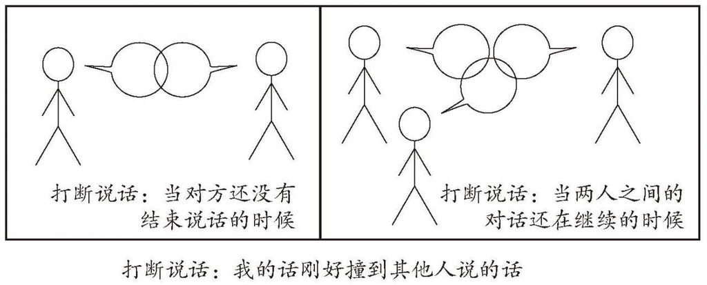

图8.1 连环漫画对话：打断说话

通过指导和角色扮演活动，可以明确一些什么时候开始说话的线索，这应该是一个话题或谈话的段落自然结束的时候，或者是别人的眼神传递出“该你说话了”的信息的时候。当阿斯伯格综合征个体看到这类“绿灯”的信号而做出适当回应的时候，应当给予表扬。

利用连环漫画对话来探索和解释在对话和游戏中自然包括的一系列信息和意义，是一个非常有用的方法。许多阿斯伯格综合征儿童对于别人的捉弄或取笑常常感到困惑和烦恼。运用语言框和想法框，加上不同的颜色，就可以指出那些隐藏的信息，并帮助孩子了解别的孩子会从他的语言和对话中感知什么。

年幼的阿斯伯格综合征儿童常假定别人和自己对某件事的想法完全相同，或者假定别人说出来的话和他们心中的想法一样。通过连环漫画对话可以说明在同一情景下每个人的想法和感受可能非常不同，而每个人真正说出来的话可能与心中所想的内容也不完全一致。连环漫画对话还有另一个优点，它可以显示一段对话中事件的先后顺序，并且指出其中可能出现的所有其他替代说法或行为会怎样影响后续结果。

第五章提到了许多教导心理理论能力的活动也可以用来改善对话能力。互动式DVD《想法解读：关于情感的互动式指导》（Mind Reading：the Interactive guide to Emotions，2004）可以帮助阿斯伯格综合征个体有效地学习辨认他人面部表情和说话声调的变化，也可以帮助他们学习补救不当的对话。阿斯伯格综合征儿童和成人都可以使用这套DVD，因为在这套DVD里依照难度情感分成了不同的等级。成人也可以自行阅读一些自助手册，获得有关对话技巧的指导（Gabor 2001）。

方案的最后一个阶段是将这些新学到的对话技巧运用到实际生活中。不过必须先告诉同伴和家人他们新学到的这些对话技巧，以确定他们是否在生活中成功地使用了这些技巧，从而提高他们继续学习的动机和自信心。还有一点非常重要，要及时表扬阿斯伯格综合征个体的成功对话表现，明确指出他的哪些话说得合适，称赞他们的对话技能一直保持进步。随着成熟度的增加，阿斯伯格综合征个体对掌握对话新技能的要求也随之出现，我们需要安排长期计划，解释清楚需要学习的新技能，然后让他们加以练习。对话技巧的教导应当是一项终身学习的方案。

## 五、字面意义理解

阿斯伯格综合征个体习惯于只从字面意义理解其他人说的话，因此，对谚语、反话、修辞、影射和讽刺的言语常常感到非常困惑。有个简单的例子可以说明他们只从字面意义理解对话：父亲待客的时候请小儿子泡一壶茶，过了好半天，还没有等到这壶茶来，就问儿子：“让你泡的茶呢？”儿子回答说：“在茶壶里啊。”儿子显然没有理解父亲最初的请求不只是把茶泡上，还包括为每个人端来一杯茶。阿斯伯格综合征个体并不是存心偷懒、迟钝或挑衅的人，他们只是往往照着字面意义理解，不了解话中隐含的其他意思。

在一次诊断评估中，我问一位阿斯伯格综合征年幼女孩：“你会数到十吗？”她回答说：“会。”然后继续默默地玩着玩具。对字面的解释也可以反应在理解图片内容上，比如一个阿斯伯格综合征孩子在看动画片《飞奔鸵鸟和大灰狼》（Road Runner）的时候，狼从悬崖上掉下来，不过突然打开一把雨伞，来代替降落伞的功能。孩子很困惑地说：“又没有下雨，它为什么要打伞？”

阿斯伯格综合征个体并非故意要让人烦或者很笨，相反，他们是的确不理解这些隐含的、暗示的或多重的意义。这个特征也会影响到对常见短语、谚语和隐喻的理解，比如：

1.Has the cat got your tongue？

（字面意思：猫咬了你的舌头吗？译注：描述对方因惊讶、尴尬而一时不知说什么好的神态。）

2.You’re pulling my leg.

（字面意思：你在拉我的腿。译注：指责对方在愚弄你，让你发火。）

3.A flat battery.

（字面意思：一个没气的电池。译注：电池快没电了。）

4.I caught his eye.

（字面意思：我抓到了他的眼睛。译注：我引起了他的注意。）

5.Looks can kilL.

（字面意思：外貌能杀人。译注：太迷人了。）

6.Your voice is breaking.

（字面意思：你的声音断了。译注：电话掉线了。）

7.Keep your eye on the balL.

（字面意思：把你的眼睛一直放在球上。译注：盯住那个球。）

8.Pull yourself together.

（字面意思：自己放在一起。译注：振作起来。）

9.I’ve changed my mind.

（字面意思：我把脑子换了。译注：我改主意了。）

我观察到，以上每个句子都会让阿斯伯格综合征孩子多少有点困惑，所以你必须一个一个地准确解释许多修辞的非字面意义。这些年来，家长和心理学家都已经认识到阿斯伯格综合征孩子有字面意义理解的问题，所以积累了一些教学经验。市面上目前有两本书详细地解释了英语中各种隐喻和日常用语的意义，一本适合孩子，一本适合成人，请参见参考文献中的书目（Stuart-Hamilton 2004；Welton and Telford 2004）。

社交故事也可以用来帮助理解修辞手法，比如谚语，且看卡萝尔·格蕾如何用下面的社交故事解释短语我改主意了（I’ve changed my mind）的真正意思。

有时有人会说：“我改主意了。”

这表示，他们原来有一个主意，不过现在他们又有一个新的主意。

当有人改主意时，我要试着保持冷静。

当有人说“我改主意了”，我应当这样理解，就像有人写了一些东西之后，感觉不对，然后用橡皮擦掉，再重写一些新的内容。（Attwood 1998，p.77）

我们可以安排教学活动，让孩子列举出一些倍感困扰的例句，比如“chill out”（字面意义：冷出去了；实际意义：冷静）或“catch your later”（字面意义：待会儿抓你；实际意义：一会儿见），然后一起猜测这些语句的真正意义。我们可以编写小故事来解释这些语句的含义，同时也描述一些可以使用这些语句的场景。

阿斯伯格综合征个体对于捉弄、讽刺和挖苦的语言也常感到困惑。有研究指出，考虑到阿斯伯格综合征孩子的智力和语言能力发展程度，他们对俗语的理解能力要低于预期表现（Kerbel and Grunwell 1998）。其他孩子，有时甚至老师也喜欢拿他们的天真开玩笑。某些嘲讽的语言会让阿斯伯格个体认为对方在说谎（Martin and McDonald 2004）。话语中隐藏的意义让他们难以捉摸，他们的思维也不够灵活，无法理解话中有话，往往只能根据逻辑性来判断，不会进一步思考其象征意义，而且假定别人说的话就代表了他们心中真正的想法。修辞用法对他们来说是不合逻辑的，也正是因此，他们认为其他人根本无法说清楚心中的复杂意图。

只作字面的意义理解可能造成品行或行为规范的问题。唐娜·威廉姆斯在她的自传中提道：

别人对我说的话，特别是字里行间的隐含意思，对我而言只有在一个特定的时刻和情景之下才具有意义。有一次，我们到国会大厦参观，被警卫抓住并严重警告不可以在墙上乱写乱画。我明确答应了他绝对不会再这么做，但是十分钟之后，我就因在围墙上涂写再次被警卫抓住。我并不是忽视了他们的警告，也不是故意捣乱，我根本就认为这次做的和之前做的完全是两码事。（Williams 1998，p.64）

父母、老师和家人必须理解阿斯伯格综合征孩子习惯于只理解字面意义，每次交谈时都停下来想一想，孩子会不会误解或不理解他们刚刚提出的意见和指导。不管孩子在何时出现字面意义理解的问题，都必须向他说明实际隐含的意义和完整的意思。我的妻妹在青少年时期也出现过这种问题。有一次她接电话，对方问她“萨拉（萨拉是她姐姐）在吗？”因为当时萨拉不在那个房间，因此她回答说不在，而且迅速挂上电话。幸好当时打电话的人正是我，我知道她有只做字面理解的倾向，因此，就又打过去告诉她，如果萨拉不在那个房间，希望她能找到萨拉，让她来接电话，这样我就可以和她通话。

## 六、韵律

如果你听过阿斯伯格综合征人士讲话，就会知道什么叫异常的音高、异常的重音和异常的节奏，亦即语言的韵律或旋律有异常表现（Fine et al.1991；Paul et al.2005；Shriberg et al.2001）。此外，他们也可能欠缺对声调的调整功能，导致说话声音平淡单调，重音的模式怪异，或者发音过于清晰，强调每个音节。

语言的韵律一般有三种不同层次的功能：语法、语用和感情。语法功能是用来表达说话的句子是一种问句（句尾音调上扬）还是一个陈述句（句尾音调下降），或者一个单词做名词还是动词使用。阿斯伯格综合征儿童和成人这部分的韵律功能受到的影响最少。语用功能的作用是给听者提供社会性信息，利用强弱或对比的重音来传递重点想法、意见和意图，或者让听者注意到新的谈话内容，就像阅读时用荧光笔划出重点一样。

韵律的感情功能是传达感受和态度的一种方式。简单的一句“你过来”可以用不同的口气来表示，如发现有趣事情而高兴的口气，或焦虑需要安抚的口气，或即将执行一个处罚时的生气的口气（Pyles 2002）。有研究证实了父母和医护人员的印象，即阿斯伯格综合征儿童和成人的语言韵律，特别是有关语用和情感部分，的确表现异常（Shriberg et al.2001）。他们的语言并没有传递出他人预期的社会性和情感信息。

某些阿斯伯格综合征儿童和成人的语言韵律极不顺畅，包括字词重复的频率过多，和同年龄孩子相比说话有停顿的地方较少，字的发音不正确或者怪异等。有时他们的谈话也有音量方面的问题，常常是声音过大，有时也会出现如同汉斯·阿斯伯格医生最先提到的鼻音或高频的声音，后来的研究也证实了这个最初的发现（Shriberg et al.2001）。

阿斯伯格综合征儿童和成人听其他人说话时也往往难以理解对方声调的变化、抑扬顿挫和强调某些字词之间的相关性（Koning and Magill-Evans 2001）。在辨认对话方不同的意图、想法和情感时，这些微妙的线索是非常重要的。从安德鲁·马修（Andrew Matthew）写的《结交朋友》（Making Friends）一书中摘录的一段内容，可以说明在加重不同字词的语气时，意义会有什么变化（Matthews 1990，p.129）。

I didn’t say she stole my money。（我没有说她偷了我的钱。）

我没有说她偷了我的钱。（是别人说的）

我没有说她偷了我的钱。（我的确没有说）

我没有说她偷了我的钱。（不过我暗示了）

我没有说她偷了我的钱。（其他人偷的）

我没有说她偷了我的钱。（她肯定对我的钱做了什么）

我没有说她偷了我的钱。（她偷了其他人的钱）

我没有说她偷了我的钱。（她偷了别的东西）

这些句子在字面上完全一样，只是重音放在不同的词上，就出现了七种不同的意思。

如果阿斯伯格综合征个体在语言的表达和语言认知方面存在韵律的问题，必须接受指导以了解韵律是怎样传递信息的。角色扮演、听录音和戏剧活动，都可以解释重音的改变方式和原因。加重某一个字的发音，类似用笔画出重点，考虑需要加重那些自己想要对听众传递的重要想法、感受和信息。听录音时，可以使用“指出隐藏信息”的教学游戏来确认说话者的想法和感受。《想法解读：关于情感的互动式指导》这套DVD里也包括一些表达特定情感的录音。这些活动可以用来识别情绪感受，并可以作为一种范例，练习如何表达某一种特定情感。第六章介绍的情感沟通活动也可以改善对语言韵律部分的理解和应用。

阿斯伯格综合征儿童还需要了解音量、说话速度和语调如何影响听众对他们话语的理解。录音带可以提供有用的深入观察，我们也可以使用特殊兴趣比喻策略来鼓励提高他们口语的可理解性，比如，“你的话就像火车跑得太快，我没法跳上去。”

## 七、学究型的谈吐

在其他人听来，阿斯伯格综合征儿童和成人的语言表达往往太学究气、过于正式和自命不凡（Ghaziuddin and Gerstein 1996；Ghaziuddin et al.2000；Kerbeshian et al.1990），其特征包括提供太多的信息，强调规则和事无巨细的资料，喜欢纠正别人话中的错误，使用过于正式的句型，刻板地解释别人的话。他们给人的印象往往是好争辩，而不是单纯地给对方纠错。阿斯伯格综合征个体常被认为像个学究，不过这并不是赞美。

某个阿斯伯格综合征青少年帮爸爸清洁办公大楼，爸爸要求儿子清空所有的垃圾桶。过了一会儿，爸爸看到有些垃圾桶里还有东西，他有点恼火地问儿子原因，儿子回答说：“那个不是垃圾桶，那是藤编的篮子。”这种迂腐的特征容易被认为是一种挑衅行为，就像我在美国和一位阿斯伯格综合征年轻人的谈话。这个年轻人非常着迷于不同牌子汽车的最高时速和不同国家道路的最高限速。我们两人的谈话气氛一直非常友好，直到我提到“低速可以省油”这句话，这个年轻人忽然生气了，激烈抗议我的用字错误，汽油应当是“gasoline”而不是“petrol”。

阿斯伯格综合征儿童选用的字词往往过于正式。例如，有一个5岁的女孩，当姐姐到学校接她回家时，她问：“我的母亲在家吗？”姐姐回答：“不在，妈咪还没回家。”显然这家孩子习惯用“妈咪”这个词，不过这个孩子却用了不寻常的正式表达方法来称呼自己的妈妈。当他们称呼其他人时，也习惯用全名加称谓的方式，比如，不说“Hello，Mary”（你好，玛丽），而是说“Hello，Mrs.Mary Smith”（你好，玛丽·史密斯夫人）。

有时这些孩子的用字用词方式很像成年人，因为他们的语言风格往往是从听大人说话、和大人的互动中习得的，而不是从其他孩子那儿学的。比如，我们会发现某个阿斯伯格综合征孩子的口音一直和当地孩子不一样，保留了妈妈的家乡话口音（Baron-Cohen and Staunton 1994）。通常我们期待学龄孩子的口音会很快变得和同学一样，而且我们注意到搬家到不同口音地区的普通孩子都是这样的。但是，阿斯伯格综合征孩子却不太可能出现这种情况，他们一旦听到某个词和短句，就会一直保持最初的发音，有经验的人一听就知道孩子模仿的是哪里人。

学究型言谈的另一个特征是他们较难忍受抽象或缺乏准确性的字词，因此，他们的家人应当避免使用“或许”、“可能”、“有时”、“等一下”之类的说法。乔利夫曾解释说：

生活就是这么的挣扎，不能确定的事情对其他人可能微不足道，但是我就感觉非常糟糕。如果家里有人说“我们明天可能去逛街”，或者有人说“我们再等等看吧”，他们不会了解，这种不确定性会给我带来极大的不安全感。我费尽心思想要确定事情到底会不会发生。不确定性还可能表现在其他方面，比如，东西到底放在哪里，别人对我的期待到底是怎样的。（Jolliffe et al.1992，p.16）

当他们感到焦虑时，学究现象就会更加严重。有时阿斯伯格综合征孩子喜欢不停地问父母问题，希望父母保证某件事到底什么时候发生。为了避免模棱两可，降低孩子的焦虑感，有时父母也要和孩子一样变得一板一眼。

## 八、听觉感知异常

一些阿斯伯格综合征人士在自传中提到一个困难，如果有几个人一起讲话，他们就无法只专心听其中一个人的声音，其他人的声音会失真地混淆在一起，完全无法分辨。在我的临床经验中，有个孩子的学校是两个班级合在一个教室上课。当他自己的老师在念数学测验时，另一个班的老师在念拼写测验。当老师批改他的考卷时，发现他把两个测验的答案都写在一起了。

坎迪（Candy）解释了为什么“太多声音会让别人的话变得难以理解”。如果有太多人同时说话，特别是他们谈的都是同一个主题，如教室里很多同学之间的小声讨论，阿斯伯格综合征孩子就会非常困惑。已有研究证实，阿斯伯格综合征儿童和成人处在太多背景谈论和嘈杂的环境中无法理解别人的话（Alcantara et al.2004），也无法感知、辨别和处理听觉信息（Jansson Verkasalo et al.2005）。

大部分人会利用嘈杂背景声稍小的片刻努力去了解对方谈话的重点，即“填补空缺”的能力，来加深明确对方说的话，但阿斯伯格综合征个体的这种能力很弱。这个信息对父母，特别是老师非常重要，为了帮助孩子提高听觉感知和理解能力，必须减少环境中嘈杂的声音和谈话。让这些孩子的座位尽量靠近老师，以便更清楚地听到老师的话，同时确保他们真正听清楚了老师的教学内容。我们要了解，这个问题来源于他们可能异常的听觉感知能力，而不是走神。

达瑞恩·怀特（Darren White）描述过在嘈杂的环境中无法分辨别人的谈话：

一开始我还能偶尔听懂一两个单词，可是接下来所有的词就通通混在一起了，我根本分不清句子在哪里开头，在哪里结尾。（White and White 1987，p.224）

在学校我总是显得懒散，因为有时听不清老师的指令，眼睛也会变得模糊看不清黑板上的字，然后老师就会说，“达瑞恩你赶快做作业。”（White and White 1987，p.225）

唐娜·威廉姆斯也提道：

我听到的任何声音好像都得经过一个复杂的大脑检查程序才能被破译。有时别人得把某个句子给我重复好几遍，因为我只能听到一些片段，仿佛是我的大脑在把句子分段处理，没有整体性，让这句话对我来说显得非常奇怪，不知所云。这就好比有人不停地在动电视机的音量调节，让声音时大时小而变得无法听清一样。（Williams 1998，p.64）

天宝·格兰丁也提道：

直到现在，我还是无法调整自己的听觉频道，比如，我用收音机听自己喜欢的歌曲的时候，突然发现自己几乎漏掉了一大半的内容，我的听觉感知常会不自觉地关掉。在大学上课的时候，我必须不停地抄笔记，才能避免我的听觉换频道。（Grandin 1990，p.61）

如果听觉感知问题变得非常严重，可能会表现出“选择性耳聋”现象，这时就必须安排语言病理学家或听力专家评估孩子的大脑听觉信息处理能力。他们不一定是听觉器官出现了问题，有可能是大脑处理听觉信息的区域出了问题。

我们应当鼓励阿斯伯格综合征孩子在产生听觉理解问题的时候请求对方再说一遍，或是用更简单的方式、更简单的词再说一次。不过，他们往往不好意思请求别人的帮助，因为害怕被人认为自己笨，或担心大人生气。我们可以请孩子大声复述一遍刚刚听到的话，或问他“你可以告诉我，我要你做什么吗？”，从而确定他是否真的理解了。

成年人也可以特意在每个句子之间都停顿一下，让孩子有时间处理已经听到的信息，也可以选择使用更多的文字指令。特雷泽·乔利夫（Therese Jolliffe）提到过使用这些策略的好处。

有人跟我说话时，我必须得努力用心地听，试图把握每一个机会听出这些字句的意思。在我读大学第一个学位时，我还可以应付得来，因为可以事先预习功课，老师也会把内容写在黑板上，教材讲解也会按照逻辑顺序教给学生，老师说话的速度不快，总是会在每个句子之后停一两秒钟，让我有时间分辨出更准确的内容。在阅读时，就不会有这种破译句子的困难，因为每个字的意思会马上展现在眼前。（Jolliffe et al.1992，p.14）

因此，如果阿斯伯格综合征个体只需要专注在一种声音来源上，或者每一个句子结束的时候有短暂的停顿，或者指令是书面书写的，就更有助于他们的理解。下面这个例子可以说明阅读比听讲更容易被理解：一个年轻人在工作上表现很不错，因为流水线经理总是会在口头指示后再给他一张书面总结；但是来了一位新经理之后，他拒绝花时间给这位阿斯伯格综合征员工写书面说明，这个年轻人在车间里难以听懂复杂的口头指示，因为不知道自己究竟该做什么而显得非常焦虑，工作表现也日益退步。最后这位新经理终于了解，书面指示对于这位特殊员工太重要了。

有些孩子会发展出相当早熟的阅读能力（请参见第九章），对书面文字的解码能力超强，不过他们的理解能力受限于语言发展的程度。这些孩子或许能读出一些其他同龄孩子不认识的单词，不过，在评估这些孩子的阅读能力时，会发现他们虽然阅读准确度相对超前，但阅读综合理解力却和他们的语言能力同样发育迟缓。因此，书面和文字的指示应当配合孩子的语言综合理解能力，而不是依据说或阅读复杂单词的能力。

## 九、语言流利程度

阿斯伯格综合征孩子的另一个语言特征是有时话太多，有时话太少，当谈到自己真正喜爱的特殊兴趣时，总是啰啰嗦嗦谈个不停，有问不完的问题，像不停的小溪一样可爱（这也是他们不懂的一种比喻修辞用法），不过有时也让人感觉乏味。孩子们求知若渴，也总是能用相当流利的语言展示自己的知识，虽然他们往往需要学习什么时候停止谈话，保持安静。

有些孩子可能会在一段时间变得不爱说话，或是根本不说了。临床经验发现，有些孩子只跟父母说话，在别人面前或教室里从不开口（Gillberg and Billstedt 2000；Kopp and Gillberg 1997）。语言的流利程度会受到焦虑感的影响，特雷泽·乔利夫说：

孤独症人士感觉最失败的事就是很难对别人解释自己的感受，不管是受到伤害或感到害怕，还是觉得不舒服，你总是无法为自己辩解。有时我会服用药物来降低恐惧感，虽然在我感到害怕的时候，会尝试告诉别人，不过我总是无法在事情发生的当时说出来。还有好几次当陌生人问我名字时，我竟然害怕到记不起来。可是在心情放松的时候，连只听过一次的电话号码和公式都能背出来。当我非常害怕面对某人或某事，或者感觉非常痛苦的时候，常常只能做出一些动作或发出怪声，什么话也说不出来。（Jolliffe et al.1992，p.14）

因此，不太说话甚或根本不说话的原因可能是焦虑感太高，有些成人在焦虑的时候还会出现口吃。此时他们的问题就不是语言技巧的问题，而是情绪影响到语言表达的能力。如果这类问题比较明显，我们要首先考虑那些帮助他们克服焦虑感的策略（请参见第六章）。

## 十、阿斯伯格综合征对话法

这么多年来，我对阿斯伯格综合征人士的认知能力、社会能力和语言能力已经有了相当程度的理解，也有无数和他们对话的机会。我开发了一套与他们谈话的阿斯伯格综合征对话法，其主要原则是仔细考虑该和他们谈什么，以及如何谈话。与阿斯伯格综合征个体交谈应当避免使用普通人常用的修辞手法，因为他们习惯于从字面上理解别人的话。如果谈话内容涉及到社会规范、想法和感受，我建议在每一句话之间要有短暂的停顿，让他们有时间运用智力能力（而不是天生直觉）来处理刚接受到的信息。天宝·格兰丁和我提过，对她来说，普通人的语速太快了，她总是无法及时处理来自所有频道的沟通信息，无论是对方说的话、口语的韵律，还是身体语言和面部表情。

采用阿斯伯格综合征对话法，普通人要明确说出自己的意图，避免模棱两可或不必要的微妙言辞。要允许阿斯伯格综合征个体在回答问题之前有一些时间来整理自己的想法，并保证他们不必因为短暂的沉默或缺少目光接触而感到不好意思。如果想通过接触、手势表达情感，记得先做口头说明，比如，摸手臂代表同情，受到礼物回应一个亲吻，而不要给他们带来没有预期的、不愉快的意外。

同时，我们还应该有清晰的、最好与谈话内容一致的面部表情，最好避免捉弄和讽刺的言语。阿斯伯格综合征个体需要明确知道对方理解他说的话，而他们自己却不太确定如何回应别人的称赞和表扬。如果有可能的话，尽量保证谈话环境不太嘈杂，或转移到比较安静的地方进行。面对可能导致压力升高的场景，特别是试图在一个拥挤的地方交谈时，他们的语言理解能力和口语流畅度都会受到影响。还有很重要的一点是不要批评他们直言坦率的特征，要知道这些人天生就不善言辞。

## 十一、外语

前面一章提到，许多阿斯伯格综合征个体会发展出特殊兴趣，某些人有学习外语的天赋，外语因此成为他们的特殊兴趣。他们往往能学习多种外语，而且发音非常标准，让说母语的人都听不出口音。一般英国人学习法语，法国人很容易就能听出讲话的是英国人，而阿斯伯格综合征人士在学习外语时，发音几乎和当地人一样。这项能力有助于他们发展和语言相关的职业，比如翻译或解说员。不过，有一种通用语言能让所有的阿斯伯格综合征人士觉得困难，即社交语言。就像杰夫（Geoff）曾对我说过，“当我参与社交谈话时，就像面对一门外语。”假如我们认为，对阿斯伯格综合征人士来说社交语言就像一门外语，我们从他们很小的时候就教导和鼓励他们学习社交语言，那么他们的“第二语言”最终也许可能和“本地人”说得一样好。

## 本章重点及策略

语言能力异常是阿斯伯格综合征的必然特征。

一般用来评估接受性和表达性语言能力的标准化测验，可能无法准确检测阿斯伯格综合征儿童和成人特殊的语言特征。

虽然阿斯伯格综合征儿童能够使用复杂的句型，但这并不代表他可以完全理解复杂的口头指示。

在接受语言病理学家的正式测试时，阿斯伯格综合征儿童可能表现出很好的语言知识能力，但在真实生活的语言应用中却无法使用必须的语言处理速度。

有些后来被诊断为阿斯伯格综合征的年幼孩子，可能有语言发育迟缓现象，不过他们第一次开口说话时就可能包含好几个单词和句子。

阿斯伯格综合征人士很难遵循传统的谈话规范，不懂得如何开始、延续和结束一段对话。

社交故事可以帮助谈话中的每一方认识社会氛围和规范、对方的期待、彼此的想法和感受。

互动式游戏和角色扮演活动可以学习和练习新的谈话技能。

成年人可以在必要的时候假装犯一些语用或对话错误，要求孩子挑出不好的谈话技巧。

阿斯伯格综合征儿童和成人也需要学习一些救援的问句和意见，用来补救不当的谈话内容或寻求澄清。

有一个活动适合年幼的阿斯伯格综合征儿童，即教导者坐在儿童旁边鼓励他和别的孩子或成年人对话，他可以伏在儿童耳边，轻声教他该说什么或做些什么，以及什么时候说。

包含教学计划和练习活动的训练方案可以改善谈话能力，用来增强：

1.聆听能力。

2.给予和接受赞美或批评的能力。

3.察觉何时和怎样打断别人的谈话。

4.用连接句引入谈话主题变更的能力。

5.修正批评意见的能力。

6.不知道该说什么或做什么的时候，知道如何问问题的能力。

7.训练方案中也可以用录像记录活动内容，重复播放，并找出对话时犯的错误和成功的表现。

青少年可能不愿意参加对话训练团体，不过，如果能将有关谈话技巧的指导和学校高中戏剧课程结合，他们可能就比较愿意加入。

连环漫画对话可以说明谈话中双方的想法和感受。

经常表扬阿斯伯格综合征个体与人交谈中的成功表现，指出他恰当的谈话（或保持沉默）和行为，是非常重要的。

阿斯伯格综合征个体习惯于只从字面上理解别人的话，因此，对于一些谚语、反话、修辞、隐喻，特别是讽刺的话，常感到非常困惑。

阿斯伯格综合征个体认为修辞不合逻辑，也是他们认为普通人无法表达清楚心中复杂意图的一个证明。

阿斯伯格综合征儿童和成人听别人说话时，在理解声调变化、抑扬顿挫或某些字句上重音的相关性上也有困难。

角色扮演、聆听录音和戏剧活动，都可以用来说明音调、转折和重音的改变，以及暗示表达的信息。

阿斯伯格综合征个体很难忍受抽象或缺乏准确性的字词，因此，家人应当避免使用“或许、可能、有时、等一下”之类的说法。

不少人在自传中提到，如果有几个人在一起说话，他就无法只专心听一个人的声音，各种声音会混淆失真。

要提高听觉感知能力和理解力，必须减少环境中的嘈杂声音。

书写或文字的指示语应当配合孩子的语言理解能力，而不是依据说或阅读复杂词汇的能力。

我发展出一套与阿斯伯格综合征人士谈话的阿斯伯格综合征对话法，主要原则是仔细考虑该和他们谈些什么，以及如何谈话。

采用阿斯伯格综合征对话法时，一般人要清楚说明自己的意图，避免模棱两可或不必要的微妙言辞。而且必须允许他们在回答问题之前有一段时间整理自己的想法，让他们不必为了短暂的沉默或缺少目光接触而感到别扭。

不要因为他们的直言坦率而生气，要知道这些人天生就不擅言辞。

假如我们同意对阿斯伯格综合征个体而言，社交语言就像一门外语，那么，可以从很小时候就开始教导和鼓励他们学习社交语言，他们的“第二语言”就有可能说得和“本地人”一样好。

# 第九章 认知能力

在与逻辑思考或特殊兴趣相关的领域，他们的能力表现得很突出，老师也常对他们的聪明解答感到惊讶；而面对机械式学习，特别是需要注意力集中的时候，包括抄写、拼写和计算，这些“聪明”的孩子就会严重失败，考试成绩常处于及格边缘。

——汉斯·阿斯伯格（1938）

阿斯伯格综合征儿童和成人的认知能力（即思考和学习能力）有一些不寻常的特征。某些幼儿在入学时学业能力超出同龄儿童水平。这种超前的识字和算术水平，可能是因为他们从很小开始就自己观看“芝麻街”一类的电视教育节目，使用电脑教育软件，或大量阅读儿童书籍，阅读与特殊兴趣有关的资料。有些幼儿仿佛能轻易地“破解”基础阅读、拼写或算术问题，而且这些学科会成为他们的特殊兴趣。相比之下，也有一些儿童的学业能力发展明显迟缓，通过针对早期认知能力的评估会发现，他们有特定的学习障碍。相比普通孩子，更多阿斯伯格综合征儿童的认知能力处于两个极端。

在学校里，老师很快会发现阿斯伯格综合征儿童独特的学习风格，他们天生擅长理解逻辑和自然世界，关注细节，喜欢以系统的方式记忆和整理事实资料（Baron-Cohen 2003）。不过这些孩子很容易分心，特别是在教室里；当他们解决问题时，也常固执于一个特定想法，而且害怕失败。随着年级的增长，老师会发现他们的组织能力也有问题，特别是完成家庭作业和作文的能力。还有，这些孩子明显无法遵从指导，或从错误经验中学习。学年成绩单会显示，他们的学业表现非常不平衡，某些领域成绩特别优秀，而某些领域则需要补习。

老师和父母必须了解阿斯伯格综合征儿童特殊的思考和学习能力，才能改善他们的认知能力和学业成绩。通常来说，孩子去学校上学是为了两个目的：学习功课和社交。如果阿斯伯格综合征孩子在学校里不能成功发展社会性，那么，学业成绩就变得更加重要，也必然成为孩子上学的主要目的，以及建立自信心的重要来源。

单靠阿斯伯格综合征的诊断评估，不能为了解某个孩子具体认知能力提供足够全面的信息，不过我们可以通过标准化智力测验和学业考试等正规测试结果，得到更多有价值的信息。

## 一、智力测验显示的能力分析

标准化智力测验至少包括十几个分项的测验，可以广泛测量智力水平。一些分项测验评估语言推理，另外一些评估视觉推理，心理学上将视觉推理命名为“操作智商”（Performance IQ）。而智商通常分为“语言智商”（Verbal IQ）、“操作智商”和“总智商”。总智商根据四个独立因素计算，即语言理解、知觉推理、工作记忆和处理速度。虽然阿斯伯格综合征个体的语言智商、操作智商和总智商都可能在正常范围之内（即IQ超过70），不过医护工作者更有兴趣的是，他们的语言智商和操作智商之间是否有明显差异，以及各个分项测验所显示的实际认知能力特征。根据这些信息我们可以了解他们是如何学习功课概念的，同时也可以找出认知能力比较差的部分，这个信息对老师特别重要。

汉斯·阿斯伯格医生的一位同事伊丽莎白·武斯特（Elizabeth Wurst）最早确认了阿斯伯格综合征个体在认知能力方面的异常。她和汉斯·阿斯伯格医生注意到，在维也纳诊所就诊过的很多阿斯伯格综合征儿童语言智商都明显高于操作智商。目前还有一个研究验证了汉斯·阿斯伯格医生及其同事在三十多年中所看过的个案，证实其中48%的儿童语言智商明显高于操作智商（Hipper and Klicpera 2004），而两种智商没有明显差异的儿童占38%，不过也有18%儿童的能力刚好相反，操作智商明显高于语言智商。

从那之后一直到现在，也有不少研究证实，阿斯伯格综合征人士的语言智商和操作智商之间确实有类似的差异（Barnhill et al.2000；Cederlund and Gillberg 2004；Dicerson Mayes and Calhoun 2003；Ehlers et al.1997；Ghaziuddin and Mountain Kimchi 2004；Klin et al.1995；Lincoln et al.1988；Miller and Ozonoff 2000）。如果阿斯伯格综合征儿童的语言智商比操作智商高很多，这种认知能力特征通常被称为“非语言学习障碍”（Non-Verbal Learning Disability or NLD，Rourke 1989）。帮助非语言学习障碍孩子的策略，也可以帮助有相同认知能力特征的阿斯伯格综合征儿童（Brown Rubinstein 2005；Russell Burger 2004；Tanguay 2002）。

有趣的是，也有一些研究发现，大部分阿斯伯格综合征儿童的语言智商并没有明显优于操作智商，特别是那些智力表现很好的孩子（Manjiviona and Prior 1999；Szatmari et al.1990）。最近还有一个研究提到，语言智商和操作智商之间的差距会随着年龄增长而消失（Dickerson Mayes and Calhoun 2003）。因此，智力测验结果所显示的认知能力特征，无法作为阿斯伯格综合征的诊断标准。我们只能说，由智力测验检验到的阿斯伯格综合征儿童的整体认知能力明显表现不平衡，所以我们必须非常小心，不能只用单一的智商分数来代表孩子的认知能力。孩子的各项智力能力特征或模式绝对比总智商分数更重要。

大约有50%的阿斯伯格综合征儿童具有相当超前的语言推理能力，一般称之为“语言型”儿童。如果这样的孩子无法在教室这个“社交剧场”学到特定的学业知识，他也可以通过阅读教材，参与一对一的讨论来提高自己的知识和理解力。如果阿斯伯格综合征儿童具有很强的视觉推理能力（“视觉型”的儿童大约占阿斯伯格综合征儿童的五分之一），那么，他可以通过观察和视觉想象来促进学习。俗话说的“一幅画胜过千言万语”，就非常适合形容这一类型的孩子。语言型的儿童可能最终会朝着需要很强语言技能的就业方向发展，如新闻工作者或法律专家，而视觉型的孩子则可以在工程或视觉艺术方面取得职业成就。

在分析儿童的智力测验结果时，医护工作者认为每个分项测验的智力能力指标对于认知能力的评估最具有参考价值。有关智商的研究指出，阿斯伯格综合征儿童通常具有良好的事实和词汇知识。他们在智力分项测验中得高分的通常是词汇、常识和语言问题解决。这些孩子往往具有丰富的词汇量和常识记忆，这使他们成为问答竞赛队伍争相邀请的对象。在操作智商和视觉推理的测验中，阿斯伯格综合征孩子在木块图测试（Block Design Test）中常获得相当高的分数，在测试中受试者必须在限定时间内用不同颜色的积木拼出一些抽象的图案。这些孩子大都擅长将一个大的几何图形分解成许多小部分，这也可以解释为何他们能够根据完整的乐高模型图片，在很短时间内就拼出一模一样的模型。阿斯伯格综合征儿童也擅长在一个复杂的几何图形中找出隐藏的图画（Firth 1989）。他们擅长“大海捞针”，不过有些老师可能会反驳说，这些孩子甚至无法在课桌抽屉里找到他们的课本。

至于得低分的测试，通常是需要用心智能力来控制信息的问题（多轨道思考），或者容易让孩子分心的题目，或者因为孩子无可救药的完美主义个性而影响到操作表现的题目，如数字背诵、算术和编码测试（视觉保留测试）。孩子在回答这些问题时，必须记住一连串的数字，心算一些算术题，以及在一定时间限制内模仿画出一连串的图形。阿斯伯格综合征儿童对于需要一连串连续推理的题目（如排列图片顺序测试）也可能会感觉困难。把可以连成一个故事的多张图画打乱次序，孩子要排列好这些图画，必须先理解故事的流程，才能找出正确的顺序。

智力测试之后，心理学家要向老师或父母说明孩子认知能力的强项和弱项，帮助他们了解孩子在某些学科的表现为何没有预期般理想。心理学家也可以根据孩子的认知优势，提出某些特殊教育方式，帮助孩子建立学业技能。孩子在某项功课上表现迟缓，本质上可能是因为他们无法理解概念——这根源于大脑连接的问题。因此，如果能根据智力测验的评估结果，改变教学模式，应该可以改善他们的学业表现。

智商评估为了解儿童的认知能力特征带来了有价值的信息，不过汉斯·阿斯伯格医生也注意到，大部分的智力测验都有意避开学业知识，目的是排除学业和环境的影响。他提道：

其实，学业考试也能揭示出这些孩子的学习困难。因此，通过学业考试，我们不仅能了解这些孩子对课堂知识的掌握，同时也能了解他们的学习方法、注意力、专注程度、分心程度和坚持性（Asperger［1944］1991，p.76）。

对认知能力的完整评估也应包括学习学业知识的能力，以及孩子在学校里不同学科的学习表现。

## 二、学校里的学习能力分析

如果单从智商分数来看，有些阿斯伯格综合征儿童应当具有不错的智力潜力，能保证在学校功课中取得好的成绩。不过他们独特的学习方式也包括一些特定的学习障碍，导致其学业成绩不如预期的好（Manjiviona 2003）。老师和父母公认的聪明孩子在学校功课的表现不如预期，这也会严重影响孩子的自信心发展。

出现这个问题有几个原因，其中最主要的是阿斯伯格综合征儿童常常有注意力和执行能力的障碍。我们可以从大公司的主管身上了解什么是执行能力。他们通常具有大格局、大视野，事先考虑各种决策的可能后果，有能力整合资源和知识，在有限的时间内规划并拟定出执行计划的优先步骤，同时能根据结果随时修正原先的决策。阿斯伯格综合征儿童和成人的执行功能则会出现严重的发育迟缓现象。

### （一）注意力问题

汉斯·阿斯伯格医生提道：“我们发现孤独症孩子的主动注意总是会分散。”（Asperger［1944］1991，p.76）后来的一些研究也指出，至少75%的阿斯伯格综合征儿童合并有注意力缺陷障碍（Attention Deficit Disorder，ADD）的诊断（Fein et al.2005；Goldstein and Schwebach 2004；Hotlmann，Bolte and Poustka 2005；Nyden et al.1999；Schatz，Weimer and Trauner 2002；Sturm，Fernell and Gillberg 2004；Yoshida and Uchiyama 2004）。

心理学家把注意力分成四个部分：持续注意的能力，注意相关信息的能力，需要时转移注意的能力，以及编码注意力——亦即记住自己需要注意的对象。阿斯伯格综合征儿童在这四个注意力部分都存在问题（Nyden et al.1999）。他们对于学校功课的注意力持续时间可能会有明显的问题，不过他们的注意力程度也常随着动机的强弱而改变。如果一个孩子正在参与和特殊兴趣有关的活动，他们的专心程度就会非常高，此时他几乎处在一种浑然忘我的状态，完全忽略了外界传来的提醒他应该转换到另一项活动的信号，或者根本无法留意老师或父母的评语、要求和指导，就好像除非发生大地震才能打断他们的专注力。至于持续注意力的时间长度，也会因为孩子是否愿意注意大人要他做的事情的动机强弱而有所不同。对于应当注意什么，他们通常有自己的想法。

即使老师要求阿斯伯格综合征儿童注意某项任务，他们可能还是无法将注意力集中在面前的资料上。普通儿童能够快速识别并选择注意和上下文或问题相关的内容，而阿斯伯格综合征儿童常会因为一些不相关的细节所困惑，自己无法知道应当重点看哪些内容。他们需要一些专门指导，来确定自己到底应当注意某一页书上什么地方。

有一些课堂活动需要孩子在学习过程中转换注意力，专注于新的信息。不幸的是，阿斯伯格综合征儿童在一个轨道上思考的时候，没有办法换轨道；此外，他们也有记忆处理的问题，即学到的知识无法如预期一般存储起来或编码，当再次遇到相同的问题，依然无法记得应当注意什么。这种特征会大大地影响到社交，阿斯伯格综合征儿童和成人常使用后天智力而非先天直觉来处理社交信息，如果互动的人数超过一个，他们会难以记住相关的社会性线索，以及改变自己的心智轨道。

执行能力缺陷的一个特征是很难将注意力从一个任务切换到另一个任务。阿斯伯格综合征个体在手头的活动还没结束或顺利完成之前，通常没有能力切换到另一个新的活动。普通儿童能够随时暂停一个想法或活动，轻易切换到下一个活动中，而阿斯伯格综合征儿童在教室里总是抗拒活动的改变，除非他们已经完成先前的活动，或者事情告一段落，否则他们无法轻松应付这种转换。如果要改变活动内容，老师或父母必须事先进行多次口头警告，或采用时间倒数的方式。如果可能，需要安排额外时间让阿斯伯格综合征儿童能完成先前的任务。

帮助阿斯伯格综合征儿童解决注意力问题的教育方案与为注意力缺陷障碍（ADD）儿童设计的方案很相像，比如：

1.强调重要信息。

2.把作业分成较小单元，以配合孩子的注意力维持时间。

3.老师定期监督并提供回馈，帮助儿童保持注意力。

4.减少环境中容易造成分心的因素。

5.提供一个安静、隔离的工作环境。

6.如果儿童合并有注意力缺陷障碍的诊断，可以考虑药物治疗。

针对合并阿斯伯格综合征和注意力缺陷障碍的儿童，我们还特别开发了一些教育策略，帮助他们在学校和家里持续和改善注意力（Kutscher 2005；Wilkinson 2005）。

### （二）执行功能

执行功能（executive function）这个心理学名词包括：

1.组织和规划能力。

2.工作记忆。

3.抑制和控制冲动。

4.自我反省和自我监控。

5.时间管理和优先排序。

6.理解复杂或抽象的概念。

7.应用新的策略。

已经有相当多的研究证实，一些阿斯伯格综合征儿童，更多的是青少年和成人，存在执行功能缺陷（Goldberg et al.2005；Goldstein，Johnson and Minshew 2001；Hughes，Russell and Robbins 1994；Joseph，McGrath and Tager-Flusberg 2005；Kleinhans，Akshoomoff and Delis 2005；Landa and Goldberg 2005；Ozonoff et al.2004；Ozonoff，South and Provencal 2005b；Prior and Hoffmann 1990；Rumsey and Hamburger 1990；Shu et al.2001；Szatmari et al.1990）。

在小学低年级，执行功能缺陷的主要特征表现在无法抑制反应（即过于冲动）、工作记忆和应用新的策略等方面。阿斯伯格综合征儿童通常因为在学校和社交场合容易冲动，对周围环境、后果和先前的经验不假思索就做出反应而名声在外。通常普通孩子在8岁就能“启动”自己的额叶功能，在决定该做什么或说什么之前抑制住自己的第一反应并仔细思考。阿斯伯格综合征儿童在做出反应之前，通常有能力进行深思熟虑，不过如果他们处在压力环境下，或感到心智超负荷及困惑的时候，就容易变得冲动。因此，我们应当鼓励他们在做出反应之前，先放松自己并考虑其他的各种可能选择，并帮助他们了解冲动其实是困惑和压力的象征。

工作记忆指的是在解决问题时保持或维持信息的能力。阿斯伯格综合征儿童可能会拥有优秀的长期记忆能力，能背诵自己喜欢的电影中所有演员名单或对白，不过，有时他们却无法用心回应和保留与当前课堂学业有关的信息。他们的工作记忆能力比同年龄孩子差，如果说普通孩子拥有一箩筐的记忆容量可以保持和利用适时相关信息，那么，阿斯伯格综合征儿童可以说只有一小杯工作记忆容量，从而影响他从记忆库里检索信息的数量。

此外，还有一个与工作记忆有关的问题，就是他们容易很快忘记一个想法。阿斯伯格综合征儿童常常打断别人，有个儿童解释其中一个原因是必须赶快把脑子里的话说出来，否则时间一长就忘了。

执行功能的缺陷还包括无法想出替代的解决方案。阿斯伯格综合征人士哈罗德·斯通（Harold Stone）曾向我解释，阿斯伯格综合征儿童和成人的思考方式就像是火车在一条轨道上运行。如果火车在正确的轨道上，孩子很快能到达目的地，问题得以解决。不过，我观察阿斯伯格综合征孩子总是最后一个知道自己在错误的轨道上的人，或是意识不到还有其他轨道可以通往目的地。因此，他们无法灵活思考，这也是执行功能缺陷的一个特征。普通儿童或成人能够很快对一个反馈做出回应，随时准备改变策略或方向。对他们来说，思考工具不是一辆单轨火车，而是一辆四轮驱动的越野车，可以任意改变方向，行驶在任何地方。

研究指出，阿斯伯格综合征儿童总是持续运用不正确的策略，即使他们已经知道这些策略无效，也无法从错误中学习（Shu et al.2001）。一个阿斯伯格综合征成人对我说，他在解决一个问题的时候，总是先假定自己的方法肯定正确，无须做任何改变。他的想法是：“这明明是正确的解决方法，可是为什么没效果呢？”因此，他们会体验极大的挫折感。这也可以解释父母和老师为什么总是发现阿斯伯格综合征孩子无法从错误中学习。现在我们知道，这个执行功能缺陷的特征主要来源于神经学的因素（额叶功能），而不是孩子故意选择错误的结果。

到了初中阶段，因为学习科目变得复杂，需要自学的内容增加，但老师和父母还根据同龄孩子的认知成熟度来要求阿斯伯格综合征孩子，他们在学校的执行功能问题就会变得更明显。在小学阶段，学业成绩，如历史课的学习，可以依赖背诵诸如事件发生日期的事实数据而获得好成绩。不过到了中学阶段，历史课的学习成绩评估方法改变，孩子们必须展现出写论文的能力，而论文必须有清楚的组织构架，分辨、比较和评估不同的观点与论据。阿斯伯格综合征青少年的执行功能缺陷问题还常常表现在组织和计划学校任务、完成课堂作业和家庭作业的能力上。阿斯伯格综合征成人杰里·纽波特如此描述自己的计划能力：“我走路时总是不去看路上的坑。”（来自个人私下谈话）

斯蒂芬·肖尔也提到自己对组织能力的看法：

如果得不到适当的支持，阿斯伯格综合征儿童可能会感觉陷入成百万个细碎的工作项目当中。我们有很多人的确无法决定优先顺序，没有组织任务的能力。（来自个人私下谈话）

老师可能会抱怨阿斯伯格综合征青少年无法将行动整合到一起，而且批评他们凌乱无章，这也是执行功能缺陷的一个特征，不一定表明孩子性格懒惰或对于功课不够积极投入。阿斯伯格综合征孩子也会因为在学校里缺乏机会做心智练习，或没有做好接受改变的准备而感到痛苦。课堂上成绩评估或测验方式的经常改变，会给他们带来非常大的困惑和焦虑。

某些阿斯伯格综合征青少年在以下方面存在困难，抽象推理，如何决定事情优先顺序（以便安排注意力次序）和时间管理，特别是要判断需要在某项指定任务上花多少时间。这些问题常让父母和老师生气，因为他们知道以孩子的智力水平应当有能力高水平地完成任务，不过执行功能缺陷却使他们无法及时完成任务，从而遭到惩罚。

此外，阿斯伯格综合征孩子在自我反省和自我监控方面也存在问题。普通孩子到了中学阶段都已将内心对话发展为解决问题的方法（Russell 1997）——这种内在思考过程通过和自己对话，讨论各种意见和解决方法的优点。阿斯伯格综合征儿童和青少年的内在思考过程，不如同年龄孩子发育得那么有效。还有许多人偏重图像思考，不会运用内在声音或内心对话的方式促进问题的解决（Grandin 1995）。阿斯伯格综合征青少年往往需要老师或大人的声音，来引导他们灵活思考。

有些阿斯伯格综合征儿童和青少年可以通过外在对话代替内在对话来促进问题的解决。在他们思考和解决问题时，会发现自言自语能有所帮助。这种解决和学习问题的适应方法，既有利也有弊：周围同伴会因为他的自言自语而分心，而且认为这是个怪人，不过老师却可以听到他的推理过程，并及时纠正他在知识和逻辑上的错误。

有些教育策略可以减少执行功能缺陷的影响，我们可以指定一个人作为阿斯伯格综合征孩子的“执行秘书”。父母或许发现他们自己早就是孩子的“执行秘书”了，每天指导他组织和计划任务，特别是完成家庭作业。这个“执行秘书”（父母或老师）需要武断地制定日程表，帮助他们校对论文草稿，用颜色标记参考书籍，鼓励采用处理问题的替代方法，并鼓励他们制作任务清单，拟定清楚的活动安排等。不过，对阿斯伯格综合征青少年或年轻人的智力水平来说，这种严密的监督和指导方式可能会显得保护过度。

父母一方如果以这种“执行秘书”的角色帮助孩子，学校机构和其他家人可能会误解他们在过度保护，不过大多数父母从亲身经验中认识到，如果不提供这样的支持，孩子就无法在学业成绩上展现自己的真实能力。我一向鼓励父母和老师勇于承担这个非常重要的“执行秘书”的角色。我们也希望这样的角色只是暂时的，孩子最终能发展出较好的组织能力，可以独立完成任务。不过有时在日常生活中，母亲的“执行秘书”角色往往要等到有妻子接替之后才能卸任。

## 三、解决问题的特征

阿斯伯格综合征孩子比较喜欢运用具有个人特色的方式来解决问题，我称之为弗兰克·辛纳屈综合征（Frank Sinatra Syndrome）或“我行我路”（My Way）。阿斯伯格综合征成人常以反传统、拒绝大众常识和传统文化智慧而闻名，儿童则通常不会考虑老师的建议，或采用其他孩子惯用的方法。虽然他们潜在的优势可能会给出更接近事物原始本质的答案——这是其他孩子不能做到的，不过，大部分学校作业却一贯依据普通孩子的问题解决发展能力而设计，因此，采用“我行我路”的方式可能会惹怒老师，他们往往希望特殊儿童优先考虑采用传统方式思考问题。

鼓励思维的灵活性也很重要，可以从孩子很小的阶段开始训练。成年人可以和阿斯伯格综合征幼儿一起玩“想想看还可以是什么”的游戏。普通孩子的想象型社交游戏中包含了灵活思考的部分，即将某种物品想象成其他东西，或具有好几种不同的功能，但很多阿斯伯格综合征儿童的想法都固定在物体的本来功能上。我和阿斯伯格综合征幼儿一起玩这个游戏的时候，会拿出一节托马斯火车的玩具轨道，问孩子这是什么，还可能是其他什么东西？我会给他们一些建议，如飞机的翅膀（模仿飞机飞行，用轨道当做飞机的翅膀），用来爬上树屋的梯子（用两个手指做出爬梯子的动作），或用来划线的直尺（用轨道当尺子划线）。另一个活动是可以一起玩“你能列举这件东西（砖头、衣服夹子等等）的多少种用途？”这些游戏都非常有趣，可以鼓励孩子的灵活和创意思考能力，并帮助他们加入同伴的社交游戏。

成年人和阿斯伯格综合征儿童一起玩的时候，应当不时利用（或故意制造出）需要解决问题的场景。由成人先说出自己的想法，让儿童听到成人思考各种不同的解决方案。有时即使已经想出一种解决办法，成人还是可以鼓励孩子继续集中心思，再确认一下是否还有其他可行的方法。这是“我们可以这么做，不过我们也可以那么做”的一个游戏范例，帮助孩子了解解决问题的方法往往不只一种。成人在描述自己的想法时，也应当包括这样的句子：“如果我保持冷静，就会更快找到解决办法”，以及“寻求他人帮助是一个明智和友好的做法”。

上学期间，老师在指导孩子解决功课问题时也可以采用相同的策略，即老师主动说出自己的内心想法，同时必须牢记，阿斯伯格综合征学生在心情放松时思维更灵活。如果孩子因为想不出解决方法而情绪激动，老师首先要帮助他平息情绪，或临时转换到一个比较平和的活动中，让孩子能更好地聆听，恢复注意力，然后再去思考其他可能的策略。

阿斯伯格综合征个体采用的某些非传统的问题解决方式，可能会被其他人视为不尊重的行为。米克（Mick）解释说：“我喜欢注视没有生命的物体，这能帮助我思考问题。如果我盯着空白的墙壁，就能更集中注意力，不过别人却认为我是不想搭理他们。”其他人需要了解阿斯伯格综合征个体往往要借助一种行为帮助思考，不过他们也需要向别人解释这类古怪行为，以免被人误解。

### （一）对待错误

阿斯伯格综合征儿童和成人的学习特征可能还包括这些倾向：陷入对错误的关注无法自拔，固执地想去纠正不规则的事情，以及对完美主义的本质渴望。这些倾向导致他们总是害怕犯错误，因此，某些孩子除非有把握能够完美地实现成功，否则，绝不会轻易开始一项活动。避免犯错误的心态显示：阿斯伯格综合征儿童盲目追求正确性，而不考虑速度和效率，这可能会影响到他们在限时测验中的表现，而且容易被认为有学究型的思考模式。创意型的阿斯伯格综合征成人，如作曲家、工程师和建筑师等，往往无法面对自己作品的任何误差。

有些阿斯伯格综合征儿童常认为自己像个大人，而不是孩子，因此，期待自己完成任务的表现要达到成年人的程度。阿斯伯格综合征儿童和青少年也害怕自己感觉或者看起来很笨，或是因为不知道该怎么做而被同伴嘲笑。他们很难接受自己犯错误，而这又让别人认为他们太过自大。任何提供给他们的建议都可能被看作和理解成针对个人的批评，这样一来，老师和朋友很可能就站到他们的对立面去了。

因此，我们必须改变阿斯伯格综合征儿童对错误和失误的看法。阿斯伯格综合征个体总是非常看重自己和他人的智力水平，因此，我们应当鼓励年幼的儿童了解认知的发展就像身体的发展一样，为了增强智力，大脑需要不断练习处理困难的问题和费力的智力活动。如果大脑处理的事情都很简单，我们的智力就不会进步。多用脑，才能让大脑更聪明。

我们可以用社交故事说明错误比成功经验能让人学到更多东西，错误可以引出有趣的发现，犯错是一个机会，而不是灾难。成年人应当主动示范如何面对错误，用一种积极的态度来回应孩子的错误，比如，“这个问题很难，是为了让你练习更复杂的思考和学习能力，我们可以一起来找到解决办法。”此外，我们也必须记住，虽然阿斯伯格综合征孩子害怕犯错，不过，把事情做好也会给他们带来巨大的快乐。相对取悦大人或给同伴留下深刻印象，成功和完美的结果对他们来说是更重要的动机来源。

我注意到，有些阿斯伯格综合征儿童（有时是成人）喜欢当面指责别人的错误，丝毫不觉得这种评论违反社会传统，会让别人感到难堪或被冒犯。不管什么人是何种身份，他们都会当面指出错误，并且认为对方应当很感激他们这么做，但对于老师来说，他们格外不喜欢自己的错误在教室里被大声说出。社交故事和连环漫画对话可以帮助阿斯伯格综合征儿童了解如何指出别人的错误，才不会造成冒犯。

### （二）阅读和数学成绩

不少研究指出，阿斯伯格综合征儿童在阅读课和数学课的平均学习成绩和同学没有明显差异（Dickerson，Mayes and Calhoun 2003；Griswold et al.2002；reitzel and Szatmari 2003；Smith-Myles et al.2002）。不过统计学分析数字显示出的标准差却很大，阅读和数学成绩落在两个极端分数段的阿斯伯格综合征儿童，比对照组要高。一项针对74个阿斯伯格综合征儿童的调查发现，其中23%在数学课的表现非常杰出，12%具有艺术方面的天分，但是17%有明显的阅读和写作障碍（Hippler and Klicpera 2004）。我们发现，阿斯伯格综合征儿童出现阅读早慧的人数比预期的要多（Grigorenko et al.2002；Tirosh and Canby 1993）。不过最新的研究指出，五分之一的阿斯伯格综合征儿童有明显的阅读问题，而将近一半的儿童有数学方面的问题（Reitzel and Szatmari 2003）。因此，阿斯伯格综合征儿童出现阅读和数学方面的学习问题或学习成绩不佳的概率会比同学高。

我们还不太能确定，为什么某些阿斯伯格综合征儿童的阅读测验得分很高，不过我们已经了解，这些孩子的好成绩是因为他们有相当好的书面学习能力（Grigorenko et al.2002），他们有明显的优势成为学校里的杰出阅读者。我们也不太确定，为何某些阿斯伯格综合征儿童会出现阅读困难，不过我们了解，他们可能是因为知觉和语言问题影响到阅读能力。举个例子，有一个阿斯伯格综合征儿童告诉我，他可以学会认识某个词，不过如果这个词由不同的印刷字体表现出来，他就会认为是一个完全没见过的新词。阿斯伯格综合征个体在知觉、认知和语言信息处理方面的问题以及家庭遗传等因素，都可能导致和阅读障碍相关的特征。

根据我的临床经验，传统的阅读障碍特殊教育方案对阿斯伯格综合征儿童并没有预期的效果，我们需要帮助他们安排由神经心理学家或阅读专家执行的完整评估，以确定孩子在阅读方面的真正困难。我们也需要找到一些适合这些孩子的新的教学策略，并确认当他们在小学高年级继续存在阅读困难时这些策略对他们的自信心发展带来的影响。一个有趣的发现表明，一些阿斯伯格综合征儿童经过评估后发现其阅读学习能力发展明显迟缓，不过几天之后，阅读能力就赶上了同龄孩子的程度。卢克·杰克逊曾为阿斯伯格综合征青少年同伴写了一本指导手册，他提到：“尽管学校用尽所有办法帮助我学习阅读，我还是做不到记住任何一个字母。不管别人教我多少遍，我都没办法理解。”不过到了七岁的某一天，好像一夜之间他就获得了阅读能力。他在撰写的手册中提到：“我希望这件事能鼓励父母不要放弃不会阅读的孩子。我告诉妈妈和学校老师，这就好像有什么突然打开了我脑子里的灯。”（L.Jackson 2002，p.117）

有些阿斯伯格综合征儿童虽然具有平均阅读水平，但却无法默读和独立阅读，即自己感觉舒适地不出声地阅读该年龄水平书籍的能力（Smith Myles et al.2002）。斯密斯·迈尔斯（Smith Myles）等人的研究发现，阿斯伯格综合征儿童的默读能力虽然落后，但当他们大声朗读时却能达到较高的阅读理解能力。对有些人来说，大声说出自己正在看的东西确实有助于理解，但一般孩子年龄较大之后，学校会要求必须默读。对于某些阿斯伯格综合征儿童来说，大声说出想法和读出声，的确有助于理解和促进问题的解决。

某些阿斯伯格综合征儿童对数学的特殊兴趣和能力可以通过阿斯伯格综合征的认知能力特征来说明。一些伟大的数学家习惯使用视觉影像建立数学概念，将数字看作形状，而不是代表数量，一些阿斯伯格综合征儿童的视觉推理和想象力也相当好。我们也发现，某些伟大数学家的人格特征类似阿斯伯格综合征的特征（Harpur，Lawlor and Fitzgerald 2004；James 2006）。马克·费舍尔是位数学天分很高的阿斯伯格综合征人士，他有数学硕士学位，曾经在书中这样描述他的快乐感受：

数学这门学问，充满着微小的细节和令人神往的东西，渴望能被人类智慧发现。这门学科的自然特征吸引着大量擅长关注细节的人，也包括孤独症人士（Fleisher 2006，p.182）。

某些能解出复杂数学题的阿斯伯格综合征儿童可能无法口头说明自己如何得到答案。汉斯·阿斯伯格医生提到自己诊断过的一个孩子曾经说：“我没有办法用嘴巴说，只能用脑子想（1991，p.71）。”如果孩子可以正确回答数学题，但是无法简单说出解题的思考过程，老师可能会感到困惑，甚至怀疑测验的结果，因为这些孩子无法表明自己的解题思路。

阿斯伯格综合征儿童另外一个学习特征是强烈追求确定的答案，如果某个问题有不止一个正确答案，无论是儿童或成人都会感到不舒服。在学校里，他们喜欢有标准答案的科目，比如数学；而不喜欢接触涉及价值判断的科目，比如英国文学。因此，习惯于将数字可视化，和寻求确定性，这两个因素可以解释为什么阿斯伯格综合征个体常具有数学方面的天赋。

但也有些阿斯伯格综合征儿童甚至在理解一些最基本的数学概念上都有很大困难，我们用运算障碍来形容这个问题。就像阅读障碍会影响到阅读能力，儿童如果有运算障碍，就必须接受完整的评估，来了解他们建立数学技能所必要的认知能力状况。他们的问题可能不在于如何算出一个简单的数学题，或背诵乘法口诀，而是如何将数学知识运用到日常生活上（Jordan 2003）。我们必须找出确定的原因和解决方法，而不仅仅是耐心提供常规补课计划，只希望他们能建立和学会运用数学概念。

### （三）弱中央统合能力

尤塔·弗里斯和弗朗西斯卡·哈佩在研究孤独症和阿斯伯格综合征儿童的学习能力和信息处理能力时发现了一些耐人寻味的现象（Frith and Happé 1994）。这些孩子非常注意细节，却很难察觉和理解全局或重点。我们可以用一个比喻来了解弱中央统合能力：想象将一张纸卷成筒状，用一只眼睛通过纸筒看世界，闭上另一只眼睛，你就会只看到细微部分，而看不到整个环境。

普通儿童比阿斯伯格综合征儿童的认知范围更广。阿斯伯格综合征儿童在教室学习时出现的困难可能不是注意力，而在于专注的焦点。他们无法及时完成某些活动的原因往往在于全神贯注于细节，强调部分而忽略了整体。老师或父母有时需要特地告诉孩子到底应当注意哪些地方。

“单信道反应”（Murray，Lesser and Lawson 2005）这个概念可以说明阿斯伯格综合征个体分配注意力的策略和一般人不同，他们常常无法归纳整理大范围的信息而导致以片段的方式看世界。他们可以学会一个个单独的事实，但是无法做出整体的综合分析。作为一个摄影爱好者，我把这个问题比喻为他们用长焦镜头对准世界，而不是广角镜头。

在处理复杂信息时，普通孩子能够将同时发生的所有事件统合成一个整体构架，并且自动深入处理信息，很快确认统一的主题。但阿斯伯格综合征儿童和成人难以确定哪些信息是相关的，哪些是多余的，也无法破译整体的模式或意义，并在脑子里产生一个统合构架。心理学家用“弱中央统合能力”一词形容这种信息处理模式。

“弱中央统合能力”解释了阿斯伯格综合征个体在认知、语言和社交方面的某些才能和障碍。在认知方面，有时他们能看到细微部分，并且发现心智构架不同的其他人注意不到的连接关系。有能力找到新的连接关系和象征，是成功的科学家或艺术家的必备优势，注意细节则有利于担任合同律师、会计师或稿件校对编辑。“弱中央统合能力”的缺点之一是花费很多的时间处理信息，需要不断反复地破译学校活动的模式，因为他们需要处理同时来自多方的信息。

语言方面，为了轻松地记忆，普通孩子会记住信息的要点和关键部分。一个弱中央统合能力的人在谈话时常记下细节，却无法记住整个故事，他们常被批评总是提供不相干的资料，而且很难总结和概括出关键点。

一个人如果具有很强的中央统合能力，就能很快从一个情景中找出哪些是相关信息，哪些是多余信息。普通人进到一个大房间内，如果里面有很多人正在进行不同的活动，这时他们的大脑可能会因为新信息过多而感到超负荷，不过他们会先确认哪些是必须注意的重要信息。普通人的大脑中有一个择优系统，通常的顺序是先注意人物和对话，而不是地毯的花色和灯具的样式。相比较而言，阿斯伯格综合征个体没有能力确定该注意哪些信息，以及哪些是不相关的信息。所以事情过后，普通人记住的是人，及其情感表现和对话内容，很快就会忘记其他资料。相比之下，阿斯伯格综合征个体可能记不得当时有哪些人在场，但却能记住在其他人看来琐碎不相干的一些细节。

对于阿斯伯格综合征儿童来说，最复杂的是处理与社会性和情感有关的信息。孩子一旦能够理解社会规范，对于周围发生的任何违规事件都会显得非常激动，他们不能忍受他人对规范的敷衍态度和欺骗行为。所以他们可能成为班上的“小警察”，严密监视同学中任何违反社会规范的举动，而且坚决采取制止措施。许多青少年都喜欢尝试违反社会规范和传统，而阿斯伯格综合征青少年就成了固定批评他们的人，而“警察”角色显然不会受到普通孩子的欢迎。

DSM-IV里的阿斯伯格综合征诊断标准包括儿童会发展出“明显僵化地固守于特定的、非功能性的刻板活动或仪式（American Psychiatric Association 2000，p.84）。”刻板活动和仪式的出现，可能是焦虑情绪的一种表现，而我们知道，阿斯伯格综合征儿童很容易出现焦虑情绪（请参见第六章），不过另一个原因也可能是中央统合能力弱的缘故，比如，难以确定日常生活的整体模式或统合性。我们发现，低龄的阿斯伯格综合征儿童习惯于建立并坚决执行刻板行为。刻板模式一旦建立起来，就必须执行下去，而这当中的步骤会随着时间日益增多。比如，每天晚上入睡前的例行刻板行为，一开始只需要排列三个玩具，后来却变成一种繁复的仪式，将很多玩具以严格的次序规则和对称性排列好。如果去一个地方几次都是走同样的路线，他们就会认为这条路是唯一的路线，无法接受任何路线的改变。以下这段话解释了阿斯伯格综合征人士为何一定要建立秩序感和确定性。

孤独症人士对现实环境常常感到困惑，因为现实环境中充满了大量相互作用的事件、人物、地点、声音和景象。这一切似乎都没有清楚的界限、次序和含义。我生命中的很大一部分时间都用来努力想搞明白每一件事情背后的模式。设定重复行为、时间、特殊路线和仪式，可以帮我在无法忍受的混乱生活中建立起秩序感。让事物保持不变，就会降低我的恐惧感。（Jolliffe et al.1992，p.16）

唐娜·威廉姆斯这么形容：

我喜欢复制、创造和排列次序。我喜欢我家的全套百科全书每本侧面都印有字母和数字。我总是一再检查，确定每一本都按照次序排列。我喜欢把混乱的次序排列好，我喜欢用百科全书不停地查询不同类别的资料。我也会阅读电话簿，统计姓布朗的有多少人，或计算一些名字的变化，以及一些少见的名字。我喜欢探求一致性。这就好像我的世界是上下颠倒的，而我想要把握住它的稳定性。可是大部分事情总在不断地变化，我根本没有机会准备好。正因为如此，我发现自己能从反复做同一件事情当中得到不少乐趣和舒适感。（Williams 1998，p.42）

我们能够理解，为什么中央统合能力弱的阿斯伯格综合征儿童强制要求自己的日常生活具有刻板常规和仪式，从而确定难以捉摸的日常环境模式或相关性。刻板常规的建立，让生活更可预测，有确定的秩序，因为新奇、混乱或不确定容易引发困惑和挫折感。建立起例行常规之后，就不必担心改变，或为了了解发生的事情和别人对自己的期待而建立新的统合性构架。

#### 儿童的早期记忆

弱中央统合能力也许可以解释阿斯伯格综合征的一个奇妙特征，亦即在他们年龄很小时就展现出超强的记忆力（Lyons and Fitzgerald 2005）。普通孩子大约在3～6岁开始记事，他们通常无法记得更早发生的事情。而阿斯伯格综合征个体的父母经常发现他们的孩子竟然能生动准确地描述婴儿时期发生的事情。艾伯特（Albert）的父母提到：“他能记得很小时候的事情，只是一件小事，之后再也没有人提起过，但是几年之后他会突然提到，而且记得清每一个细节。”（Cesaroni and Garber 1991，p.308）

艾伯特提道：

我记得1岁的时候到过纳什维尔（Nashiville），那个地方的空气有时闻起来有木柴的味道。我还记得听到音乐声，让我非常着迷。我知道自己在一个和家不一样的地方，起床时我闻着空气的味道，感觉像在一座老房子里。（Cesaroni and Garber 1991，p.307）

早期的自传式回忆可能主要是视觉的，以及对自己极为重要的个人经历，比如，坎迪提到在她的记忆里充满了各种物品的形象，比人物或个人随身用品都要多得多（来自私下谈话内容）。

我们还不能确切了解为什么阿斯伯格综合征个体具有优秀的长期记忆能力，能够记住细节和事实，甚至能够回忆婴儿时期发生的事情。一个还算合理的理由是阿斯伯格综合征个体的大脑链接模式从婴儿时期就和普通人不同，而弱中央统合能力也影响到知觉、认知处理、存储和检索记忆内容的方式，因此，他们拥有一般人所没有的再现婴儿时期记忆的能力。

能够正确再现场景的能力也可能延展到记住书中的所有内容。这种极其逼真有如照相机般的记忆力在考试中非常有帮助，不过我也知道有几位阿斯伯格综合征大学生曾被指控考试作弊，因为他们的答案准确完整地引用了教科书的内容。我也认识一些阿斯伯格综合征男孩（很少有女孩），他们有惊人的方向记忆力，能记住他们到过的所有地方，甚至年幼的孩子就能在车后座正确指引妈妈把车开到我的诊所门口，让着急赶时间还记不住路的妈妈大松一口气。

## 四、课堂上促进认知发展的策略

经验显示，在安静和规划良好的教室环境里学习，阿斯伯格综合征儿童的认知和学业能力会有很大进步。莉莎·派尔斯（Lisa Pyles）在为儿子写的传记中提到，心理学家描述她儿子在学校的表现：“约翰（John）就像是一只正在学习如何待在原地不动的小狗。他的每一丝精力都是为了能继续待在这间教室里而努力，因为本能的力量不停地告诉他要赶快离开，所以他根本没有精力花在学业上。”（Pyles 2002，p.23）

因此，我们必须敏感地注意孩子的知觉超负荷和压力承受状况，仔细考虑如何将孩子安排在适当的位置，减少干扰，让他能清楚地听到和看到老师。如果考虑到社会性的因素，最好将孩子的座位安排在友好的同学旁边，当老师忙不过来的时候也有人可以帮助他们；同时尽量不要变更日常作息和老师名单，给他们准备一目了然的日程表，并且为任何活动的转换预留时间。如果小学老师要请假，安排代课老师，学校应当事先通知父母这项临时变动。对某些孩子来说，那天最好留在家里，这样对代课老师也有利。

老师必须定时检查阿斯伯格综合征孩子的学习进度，以确保他们没有开小差，并知道接下来该做什么。有时，一个专门的特殊教育资源教室有利于他们提高专注力。可以给较大的孩子发全套的课堂笔记或进行学习指导，因为阿斯伯格综合征青少年不像其他同学那样能有效地记笔记或抄写黑板上的材料。老师应当了解这些孩子执行功能的问题，并帮助他们建立组织和规划能力，比如，制作项目清单，并允许他们有额外时间完成一项活动或作业。

如果阿斯伯格综合征儿童的总智商在正常范围之内，学校当局常会假定这样的孩子不需要再另外安排针对学习问题的课堂助教辅导。但是，有很多阿斯伯格综合征儿童的总智商虽然在正常范围内，但他们的智力或认知能力的分项测验结果却非常不平衡。而且尽管总智商在平均值或平均值之上，他们的思考和学习方式却非常独特，而目前的一些标准化智力测验可能无法检测出他们特殊的学习困难。学校老师确实需要而且也必须主动要求和接受特殊教育老师在班里提供帮助，帮助那些智力正常但不具有常规认知能力特征的阿斯伯格综合征儿童提高认知能力，发展学业。

特殊教育助理老师或学习辅导项目在学校里可以为阿斯伯格综合征孩子提供额外或个别的指导，帮助他们准备和完成功课或家庭作业。阿斯伯格综合征儿童如果处在一个嘈杂、有干扰、人来人往的教室环境里，常常无法学会某些概念，不过如果能使用基于电脑软件的课程来呈现资料，他们就可以更清晰地理解。从学前班到高中毕业，目前许多学校的常规课程内容都有相应的软件资料可供学习。

也有一些阿斯伯格综合征儿童的学业成绩比其他同学优异很多，可是社交成熟度却远远低于同伴。每学年结束的时候，学校相关人员可能会召集父母讨论，决定孩子是否要重修一年，这样他们社交成熟度的落后情况就不那么明显，还是可以正常升级或跳级和智力程度相当的孩子一起学习。

如果感觉学校的功课太简单，阿斯伯格综合征儿童容易烦躁。他们在教室里学习时，喜欢和智力相当的同学在一起。留级或跳级的决定还必须考虑很多其他因素，我通常建议孩子应当与智力相当的同学一起学习，这样就能保持他们对课程的兴趣并提高学习动机，当然，这就必须安排一些教学方案来改善他们的社交成熟度，减少智力和社会能力发展之间的差距。

## 五、教师需要具备的知识和人格

六十多年前，汉斯·阿斯伯格医生就曾提道：

这些儿童对教师的人格特征异常敏感。无论他们的程度多么差，哪怕是在最佳状态下都有学习困难，他们也能接受一定的指导和教育，不过只限于那些能理解他们、真心爱护他们、性格和蔼且特别具有幽默感的人。教师的内在情绪态度确实会影响到（哪怕是不自觉的）儿童的心情和行为。当然，想要管理和教导这些儿童，绝对需要具备充足的知识，能够了解他们的特点，还要有教学的天赋和经验，只懂得教学的效率绝对不够。（Asperger［1944］1991，p.48）

老师需要根据阿斯伯格综合征儿童的社交、语言和认知能力，安排一个对他们友好的环境。为了创造出这样的环境，应当给予老师各种条件，比如，方便取得与阿斯伯格综合征相关的信息和专业知识，参与各种培训课程等。学校也应收集相关的信息建立资料库，教育管理部门也要考虑增加班级助理教师的数量，辅导阿斯伯格综合征儿童社会性课程，辅助管理情绪，协助促进和同学之间的社会性融合，并提供必要的学业补课指导。

要成为一位能成功教育阿斯伯格综合征儿童的老师，必须具有某些人格特征。我在不少学校的观察发现，很多阿斯伯格综合征儿童被教育得不错，他们的老师都是有同理心、理解孩子内心世界的人，而且能够帮助他们在认知和学业成绩上取得很大进步。这些老师的教学方法、学习评估方法和对孩子的期望目标都具有很大的灵活性，他们能够始终如一地喜爱和欣赏孩子，知道他们的动机和学习能力。卡萝尔·格蕾建议，一位成功的教师必须了解儿童心理理论能力发育迟缓的问题，即理解别人的想法和感受的能力发育迟缓，而且需要懂得“阿斯伯格综合征心理理论”，亦即了解这些孩子自身独特的想法和感受（来自私下谈话内容）。

妮塔·杰克逊这样描述自己的一位老师：

奥斯本（Osbourne）先生总是充满活力，随时可以讲一个轻松的笑话。他很少生气，也不像其他老师那样总是提高嗓门。他允许我课间时躲在音乐教室的储物柜里，对我的奇怪行为毫不在意，他好像很了解而且接受我用这种笨办法与外界隔离。我敬重他不像其他人一样喜欢刨根问底。有时他会轻轻敲柜子的门，偷偷塞给我一块饼干（我从来不会拒绝）。学期最后一天，我买了一罐饼干给他，感谢他整个学期让我享受的美好滋味。（N.Jackson 2002，p.34）

我们还必须了解，绝对没有两个阿斯伯格综合征儿童具有相同的能力特征、体验和人格特征。对某一两个阿斯伯格综合征儿童有效的教学经验并不见得适用于后来的孩子，有时必须为每一个阿斯伯格综合征儿童制定不同的教学策略。

另外，在教育阿斯伯格综合征儿童的时候还要注意，不要被他们一些表面上听起来粗鲁或无礼的言论轻易激怒。当老师问某个孩子：“你可以放下你正在做的事么？”如果孩子简单回答说：“不行。”其实他是在说实话，而并非不礼貌。我们也应当避免讽刺的言语，因为他们只从字面意义理解别人话中的意思。

老师也需要了解，能有效提高其他孩子动机的传统方法，不见得对阿斯伯格综合征儿童有效。汉斯·阿斯伯格医生饶有兴致地探讨了可以用于阿斯伯格综合征儿童的教学策略，他写道：

在普通孩子那里展现爱心、关心和贿赂的态度和方法，确实能引发他们好的行为表现，不过这些方法却只是让弗里茨，以及其他有同样问题的孩子感到不高兴。（Asperger［1944］1991，p.47）

要想更有效地增强阿斯伯格综合征孩子的动机，需要针对他们智力方面的自信心，比如，表扬他们有多么聪明，将他们的特殊兴趣纳入教学活动当中，以及帮他们减少出错的可能。

汉斯·阿斯伯格医生继续提道：

在进行任何教学活动时都不要带任何感情色彩。教师绝对不能发脾气，也不应当期待自己被所有人喜爱。老师应不惜任何代价保持冷静威严，控制好情绪。（Asperger［1944］1991，p.47）

我们还有一些忠告：阿斯伯格综合征儿童努力想要专注做事时，如果受到他人情感类的干预，无论是生气还是爱意表达，都会造成他更大的困惑和烦恼。有时，阿斯伯格综合征儿童必须表明自己需要安静的环境。如果儿童的情绪越来越激动，也不利于成人进行教学互动。

汉斯·阿斯伯格医生进一步提出建议：“另一个教学技巧是宣布所有教学评估都不针对个人，而只是一种评价教学质量的客观规定。”（Asperger［1944］1991，p.48）有时老师或校长必须拿出相关校规跟孩子解释，以证明老师是在执行一个大家都同意的规定，而不是针对个人的报复性举动。

### （一）家庭作业

阿斯伯格综合征儿童和青少年生活中的一个主要痛苦来源，是他们的父母和老师要求必须完成令人满意的家庭作业。为什么这些孩子对写作业这件事会出现如此强烈的情绪反应？为什么完成功课对他们来说这么困难？这里我提出两个理由，第一个理由主要是因为他们在学校所承受的压力程度和心力衰竭，第二个原因在于他们的认知能力特征。

这些儿童必须和同学一起学习传统的课程教材，不过他们却比其他同学遭遇更多的压力体验，因为他们还必须应付额外的并行课程，也就是社交课程的学习。他们必须运用自己的智力推理能力确定教室里和操场中的社会规范。其他孩子不需要刻意学习这些社会整合技巧，而阿斯伯格综合征儿童则必须学会努力破解社会性线索和社会规范，依靠认知能力确定在社交情景中该说些和做些什么。通常他们从外界得到的主要回应都是针对犯错的批评，却很少听到正面的回应。不幸的是，只从犯错当中学习，绝对不是最积极的学习方式。因此，这些孩子不得不更加专注于社交课程，避免大量犯错，以至于放学后他们在智力和情感上都感到疲惫不堪。他们也往往无法解读和回应老师和其他同学的情感信号，应付复杂的社交活动，应对操场中嘈杂的声音和混乱的场面，学校里经常发生的计划外的改变，以及嘈杂教室里的强烈感觉刺激。他们很少能在学校一整天的时间里找到放松的机会。

在和一些难以学会社交课程和应付学校压力的阿斯伯格综合征儿童讨论这些困难时，他们常解释说，家庭和学校之间需要有一个清楚的界限。他们认为：“上学是为了学习，回家则是为了生活乐趣和放松心情。”因此，为了完成家庭作业，必须中断他们必要和应得的乐趣与放松，实在不是他们所能承受的事情。肖恩·巴伦解释说，“我实在想不通，为什么有些学校的功课必须在家里做，学校的事情就应当留在学校里做，难道不是这样么？”（Grandin and Barron 2005，p.94）

特殊的认知能力特征导致阿斯伯格综合征儿童在学校（特别是在家里）做作业的时候，需要明确并将认知能力调整到学习状态。由于执行功能的缺陷，他们的规划、组织和确定优先顺序的能力也有欠缺，在解决问题的过程中容易冲动而且缺乏弹性，工作记忆相当受限。阿斯伯格综合征儿童其他特征还包括很难产生新的想法，很难确定哪些资料相关或者多余，时间知觉能力和时间管理能力不佳，需要有人监督和引导。此外，他们也可能出现特别的学习问题，如阅读困难。

以下策略可以减少执行功能缺陷的影响，改善孩子在家里的表现，帮助孩子完成家庭作业，减轻他们和父母的压力。

#### 创造一个有利的学习环境

孩子写作业的地点应当有利于他专注和学习，就像孩子在教室里一样，安排适当的座位和光线，去除所有可能造成分心的因素。这些因素可能是视觉方面的，如周围的玩具或电视机，因为这些东西会提醒孩子自己更想做什么；也可能是听觉方面，如电器转动发出的声音，以及兄弟姐妹的聊天声。父母还要保证写作业地点的设施只和当时工作有关，此外，写作业的环境也要远离因为好奇来打扰的年幼弟妹。

如果父母制作一个每日家庭作业时刻表，同时和学校老师每天交换家庭作业日志，将是一个非常有效的方法。老师可以在日志本上记录每项作业期望完成的时间和内容。因为有时老师原本预期只需几分钟完成的作业，阿斯伯格综合征孩子却需要好几个小时才能完成。老师也可以给父母列出完成家庭作业所必需的设备和资源。

家庭作业日志和计划书可以帮助孩子记住带哪些书回家，以及每天晚上该做哪些作业。我们可以到文具店买一本管理人员使用的记事本，让孩子感到这个方法的严肃性、正规性。这样的技巧原本就是为做管理工作的成人创建的，而不只是针对有学习问题的孩子。

可以使用一个计时器提醒孩子还剩多少时间完成每部分作业内容。还必须留意写作业的时间不要和孩子最喜欢的电视节目播出时间相冲突。如果无法避开，可以考虑用录像机录下节目，等到作业做好后再看。

如果孩子需要安排固定的休息时间来保证注意力集中，可以把作业分成几个小的部分，并且让孩子了解在下一次短暂休息之前需要完成多少作业。父母容易犯的一个错误是对孩子的注意力期望过长，特别是孩子已经在学校劳累了一天之后。

### （二）老师为家庭作业所做的准备

老师可以在家庭作业上划出重点并提供书面说明，以及通过询问孩子一些问题，确定孩子是否了解哪些材料和家庭作业有关。老师也可以要求孩子在开始做作业之前先提出一份计划，以保证他的工作具有一致性而且合乎逻辑，特别是大作业，如写论文的时候。如果某项作业要好几天才能完成，老师必须定时检查孩子的草稿和进度，以提高作业准时完成的可能性。

### （三）记忆力问题

如果孩子想不起来家庭作业是什么，或者做作业的时候不记得相关的信息（执行功能缺陷的一个特征），解决办法是买一个辅助执行的工具。如准备一台小录音机，录下老师的口头说明，也可以让孩子录下自己的想法，当作提醒自己重要信息的个人备忘录。这样，孩子和父母就能知道老师在课堂上说了些什么，以及和家庭作业有关的信息。另一个策略是拨打班上其他同学的电话，询问相关信息。

### （四）监督

父母和老师很快就会察觉，阿斯伯格综合征孩子通常需要大量的监督来确保完成任务。不过孩子做作业的时候，父母同时也会有其他家务和杂事需要处理，因此，就出现一个关键矛盾。

孩子可能不知道作业该如何开始，或是哪些事情必须先做。拖拖拉拉会是一个难以解决的问题，父母必须监督孩子开始做作业，不过一旦孩子开始以后，父母就会发现需要监督的问题会没完没了。父母需要力争做到随叫随到，在孩子感到困惑的时候及时提供帮助，协助他找到合适的解决策略。普通孩子碰到困难时，会认为最明智的做法是考虑其他可行的办法，阿斯伯格综合征儿童则无法想出其他的变通办法，或找出一个非常规的处理方法。帮助他们思考多种方案的一种方法，是给孩子提供一个解决特定问题的策略清单，他们就知道除了常规办法，往往还可以考虑其他计划。

父母的监督还必须包括帮助孩子确定先后顺序和做好任务计划，帮助解决词汇提取困难（word retrieval problems）和维持动机。运用特别的奖励可以提高孩子保持专注和持续努力的动机。

### （五）认知类型

我们必须特别考虑阿斯伯格综合征儿童在认知能力方面的特长和缺陷。如果孩子的优势在于视觉推理能力，那么，使用流程图，通过画图组织任务，应用心智思维地图和示意图，都能提高孩子的认知理解力（Hubbard 2005）。如果孩子的优势在于语言能力，那么，运用文字说明和比喻手法进行讨论，特别是与特殊兴趣有关的比喻，就可以有效地帮助他。此外，还可以利用电脑和键盘作辅助学习手段，特别是对那些书写能力有问题的孩子尤其有用。有时父母可以作为“执行秘书”，帮孩子录入有关资料并校对答案，让家庭论文作业变成一个合作项目，而不是依靠他们独自完成。很多父母从多年的经验了解到，如果自己不参与，孩子的功课绝对无法准时完成或达到所期待的水平。

阿斯伯格综合征儿童大都喜欢接触电脑，如果学习资料在电脑屏幕上，他们可能更容易理解。而教师讲解教材时，因为加上了社会性和语言等方面的信息，会增加儿童的困惑。因此，老师应当调整家庭作业的形态，增加利用互联网资料做作业的比例。使用文档处理软件，特别是软件附加的图形、语法和拼写检查等功能，都可以帮助阿斯伯格综合征儿童改善作业的可读性和质量。

如果父母无法帮孩子解决某个特定的问题，应当和老师商量是否可以随时打电话请教，最好无论白天晚上老师都可以和孩子直接讨论。如果能得到老师的课外辅导，家庭作业完成的质量和数量必会有明显改善。

最后一点，对阿斯伯格综合征儿童的教导需要具备一些特殊教育技巧，而父母通常缺少这样的专门技能。而且作为父母，和孩子情感的介入绝对多于学校的老师，因此，很难在解决问题上保持客观和理性的态度。有一个选择是聘请家庭教师给予技术性的指导和监督，不过，大部分家庭可能没有这样的经济实力。

### （六）减少家庭作业的数量

如果家庭作业总是带来痛苦，孩子放学后就已经筋疲力尽，那么，对极力想要激发孩子生活动机的父母，以及知道针对这类孩子家庭作业绝对不是最有效的教育方式的老师们，应当怎样降低他们的苦恼？如果一定要给阿斯伯格综合征孩子布置标准数量的作业，那么，相关的每一个人都必须认同，大家都需要付出时间和心力，确保孩子能准时交出令人满意的作业。

有一个办法是让孩子在学校做完家庭作业。利用午餐时间，早晨上课前或者放学以后，让孩子在单独准备的资源教室或学校图书馆里做作业，不过他们还是需要老师或助教的监督和指导。在高中阶段，某些孩子可以少修一些课程就能毕业，这样在学校空出来的时间就可以用来做家庭作业。

如果这些策略都无效，还有什么其他方法呢？我曾经读过一篇研究报告，里面居然清楚地建立了一个模型，探讨儿童时期花在家庭作业上的时间和成人后工作和生活品质之间的相关性。人们或许会辩解说，做家庭作业可以鼓励孩子自我学习，不过，如果阿斯伯格综合征儿童对某项活动有特别的兴趣，他们自我学习的能力非常好，那么，他们的主要问题是无法在教室的社会环境中学习。

我个人的意见是，如果阿斯伯格综合征儿童无法准时完成家庭作业，不应当受到处罚；而且除非阿斯伯格综合征儿童或青少年主动愿意多花时间在家庭作业上，否则，一天的家庭作业时间不应当超过30分钟。30分钟以后，父母可以在作业本和作业日志上签上名字，注明孩子在规定时间内做完多少作业，老师的评分就应当基于做完的那部分作业。这个做法对于孩子、父母和老师来说，都是一个轻松的方案。

## 六、视觉思考

阿斯伯格综合征个体具有不同的思维模式，有的人会利用图像而非文字进行思考。有一个很值得注意的研究，是让一些阿斯伯格综合征成人连续几天佩戴一个会随机发出“哔哔”声音的仪器（Hurlburt，Happé and Frith 1994），要求他们听到哔哔声音时，暂停脑子里的想法，然后记录下当时正在想的事情。另一些普通人在接受这项实验时，记录下来的一系列想法会有很多，包括语言、感受、身体感觉和视觉图像。

不过阿斯伯格综合征成人记录的主要是或者只有图像内容。有些阿斯伯格综合征人士显然偏向于视觉型思考，这种思考类型有几个优点，就如同天宝·格兰丁所列出的：

我的大脑完全是视觉型的，因此，设计空间形象的任务，比如画图，对我来说非常容易。我曾在六个月之内自学了画机械草图，设计一间大型的钢筋混凝土养牛场。不过，记住电话号码或在脑子里加减数字，对我却非常困难，我必须用笔写下来。我记忆的每个信息都是视觉的。如果必须记住一个抽象概念，我会在脑中检索曾经看到的书中或笔记中涉及抽象概念的那一页，从中读出信息。我唯一不需要依靠视觉图像记忆的是音乐旋律。通常，我很难通过听觉记住事情，除非它确实激发了我的某种情感，或是让我建立起一幅视觉图像。在教室内，我得仔细记笔记，因为我总是会忘记听到的内容。当我思考一些抽象的概念（比如人际关系）时，我常利用视觉比喻，比如，人与人之间的关系就好像是一道玻璃滑动门，开门时动作必须小心轻柔，如果用力一踢，门可能就会粉碎。如果我要学一门外语，我必须依靠阅读，让一切信息视觉化。（Grandin 1984，p.145）

天宝·格兰丁曾写过一本书详细分析她的视觉思考，并讨论这种能力如何影响到她的生活，以及如何帮助她发展出非常杰出的设计技能（Grandin 1995）。

这种思维方式在现实中有缺点，因为学校教学几乎都以口头语言思考方式完成。老师通常使用语言和讲演方式介绍各种概念，而较少利用实际操作方式。有一种教学策略有利于视觉型的学习者，就是大量利用图表、模型和积极参与的方式。比如，上数学课时，孩子可以准备一个算盘放在桌上。他们也可以在脑子里将各种原理和事件想象成一幅真实的景象。有几个阿斯伯格综合征成人曾向我说明，他们在学习历史和科学时如何将事件视觉化，比如，脑子里像放纪录片一样呈现变化的分子结构。

这种思维方式也有突出的优点。视觉思考型的阿斯伯格综合征个体常具有棋类和台球方面的天赋。二十世纪最伟大的科学家爱因斯坦就是一个视觉思考者。他的语言课成绩不及格，一向依赖视觉方式学习。他的相对论理论就是基于移动中的货车和光束的视觉图像建立的。有趣的是，从他的人格特征和家庭史来看，都显示他有阿斯伯格综合征的迹象（Grandin 1984）。

## 七、认知方面的天赋

一些阿斯伯格综合征儿童和成人的认知能力明显高于平均水平，比如智商超过130，被称为超常生（Lovecky 2004）。这种能力对阿斯伯格综合征儿童而言有好处也有问题，好的方面包括有较高的智力能力处理和学习社会性线索及社会规范，老师们会佩服他们高超的智力，参加智力竞赛获胜的经验也能给孩子和学校带来荣誉感。学业上的成就能提高一个人的自信心，无论他是年轻人还是成人，连带着其他人也比较容易接受他们天真的个性和怪异的举动，甚至会赞赏他们那种与世无争的散漫教授形象。认知方面的天赋有助于从事技术开发等高薪职业，或从事以研究为主的学术职业。不过，高智商也存在很多问题。

和同龄人相比，阿斯伯格综合征儿童社交能力和情感成熟度远远发育不足，因此，容易被孤立、嘲笑或欺负，而比同伴更高的智力往往会引发更严重的社会孤立和疏远。他们在教室里找不到无论是社交还是智力方面水平相当的朋友。阿斯伯格综合征儿童所具有的丰富词汇量和知识也容易让成年人对他们的社会推理能力、情绪管理能力和良好行为表现，有相当高的期待，因此，当这些儿童的表现不如同伴成熟时，大人的批评也就显得有失公平。

具有比较高的智力，也常常会有比较高的道德感和理想。年幼的阿斯伯格综合征孩子在遇到不公平的状况时，如看到虐待动物，就会感觉非常痛苦。他们对遭受天灾的受害者也常报以深切同情。此外，他们对公平也有很高的道德理想，以至于影响到自己和同伴之间的互动和游戏，因为其他孩子通常都抱着比较灵活和自私的态度来看待社会规范。

智商属于优异程度的普通孩子其概念理解能力常常优于情绪管理能力，他们会因为担心自己的理解力超过同龄孩子的心智而表现得小心翼翼。而智力优异的阿斯伯格综合征孩子在处理这些因为智力优越而增加的社交顾虑时，其技巧性远远不如那些高智商的普通孩子。

与阿斯伯格综合征个体有关的认知能力特征也会影响到认知天赋的表现。他们形成概念或解决问题能力可能会是一流的，不过在实际过程中，将想法组织成一个统一的框架，以及用语言表达想法的能力，都可能出现严重的障碍。阿斯伯格综合征儿童和成人虽然清楚自己的想法，解决问题的能力也非常优异，但无法让其他人理解他们想做什么。

我们知道，阿斯伯格综合征儿童和成人经常只专注于问题的某个特定部分。仔细专注某个特定细节，或许可以找到别人忽略的地方（Hermelin 2001），但其缺点是可能会对比较不重要的问题关心过度。阿斯伯格综合征个体有追求完美的个性，对自我实现的标准很高，如果一件事不能如预期般成功，他们往往很快放弃。这些孩子虽然智力优秀，却容易因为自我要求标准过高而感到挫折，偏偏他们又非常欠缺应对挫折的能力。

如果阿斯伯格综合征儿童的智力推理能力比其他同伴发育得早，他们常常会编出一些极富想象力的故事去吸引其他孩子（Lovecky 2004）。他们或许因此成为一群年幼孩子的头儿，积极表演这些想象出来的故事。进入儿童期之后，阿斯伯格综合征孩子的创造力和艺术方面的天赋能够成为自我表现和个人满意度的表达形式，而不是为了给观众展示或者希望得到同伴的赞赏（Hermelin 2001）。

戴尔德丽·洛韦茨基（Deirdre Lovecky，2004）曾研究过一些智力超常的阿斯伯格综合征儿童，发现在学校里老师提供的功课通常和他们的认知能力不相匹配。因此，老师们必须能够确认这些孩子的智力潜能，安排更深入的课程。这些孩子也适合进入天资优异特教班，不只是为了能扩展知识和认知发展，也可以有机会认识潜在的朋友。这种友谊可能建立在交换信息和讨论智力问题的基础上，因为除此之外，他们还能在什么地方找到同龄而智力又相当的真正朋友呢？

现在我们知道，科学和艺术方面的重要进展本质上归功于思考方式异于常人，而且拥有许多阿斯伯格综合征认知特征的人（James 2006）。普通人擅长社会性和语言思维方式，阿斯伯格综合征人士拥有和他们不同的知觉和认知能力特征，将会是一个突出的优点，可以发展为有价值的才能。利利安娜是位具有相当高智力水平的阿斯伯格综合征女性，她曾对我说：“语言是思维的牢笼。”的确，有很多先进的科学和哲学发现是通过不同的概念理念产生的，而不是单纯以语言思考作为基础。

李（Lee）是牛津大学的学生，他这样说明：

我认为，阿斯伯格综合征是另一种看待世界的方式。从数学层面看待事物对我很有帮助。我发现以一种高度抽象的方式去思考，其实非常容易。比如，我可以在两分钟之内完成魔方还原。（Molloy and Vasil 2004，p.40）

雷切尔（Rachel）也提道：

我加入门萨学会的一个理由是我想要用它来证明我的智力，我可以宣称：“我有高智商，而且可以证明给你看，因为我是门萨的成员。”总的来说我确实认为，大部分阿斯伯格综合征人士都有不错的智商。如果我可以选择改变自己，去掉阿斯伯格综合征的特征，说句真心话，我并不愿意，因为我知道自己同时也会失去一部分智力。（Molloy and Vasil 2004，p.43）

这个社会需要阿斯伯格综合征人士为我们的未来带来新视野。

## 本章重点及策略

某些阿斯伯格综合征幼儿入学时，学业能力优于同龄孩子。

有更多的阿斯伯格综合征儿童的认知能力落在两个极端。

学校里的学习能力特征：

1.老师很快就会发现阿斯伯格综合征孩子独特的学习风格，他们擅长理解逻辑和自然领域，注意细节，以系统的方式记忆和整理事实资料。

2.阿斯伯格综合征儿童很容易分心，特别是在教室里。他们在解决问题时，常固执于一种想法，而且害怕失败。

3.随着年龄的增长，老师会发现阿斯伯格综合征孩子在组织能力方面也有问题，特别是完成家庭作业和论文的能力。

4.如果孩子在学校里的社会性不成功，学业成绩就变得更重要，必然成为孩子上学的主要目的，以及发展自信心的重要来源。

5.孩子的智力特征或模式比总智商分数更重要。

6.至少75%的阿斯伯格综合征儿童的学习能力特征显示出合并有注意力缺陷障碍的问题。

7.心理学家将注意力分成四个部分：持续注意的能力，注意相关信息的能力，需要时能转移注意的能力，以及编码注意力——亦即记住自己需要注意的对象。阿斯伯格综合征儿童在这四个部分都可能出现问题。

执行功能：

1.已经有相当多的研究证实某些阿斯伯格综合征儿童，更多的是青少年和成人，存在执行功能缺陷的问题。

2.执行功能这个心理学名词，包括：组织和规划能力、工作记忆、抑制和控制冲动、自我反省和自我监控、时间管理和优先排序、理解复杂或抽象的概念、应用新的策略。

3.有一个策略可以减少执行功能缺陷造成的问题，即让某个人充当“执行秘书”。

问题解决能力

1.研究指出，阿斯伯格综合征儿童总是持续运用不正确的策略，即使他们知道这些策略没用，也没有办法从错误中学习。

2.阿斯伯格综合征儿童通常比较喜欢用有个人特色的方式来解决问题。

3.鼓励灵活思考是一件重要的事情，可以从很早的阶段就开始训练。成年人可以跟阿斯伯格综合征幼儿一起玩“想一想还可以是什么”的游戏。

4.成年人在解决问题时可以大声说出自己的想法，这样，阿斯伯格综合征儿童就能听到大人解决问题的不同途径。

处理错误

1.阿斯伯格综合征儿童和成人的学习特征包括：总是专注于所犯的错误，想要固定变换的事情，以及追求完美的渴望。

2.我们必须改变阿斯伯格综合征儿童对错误和失误的看法。

3.社交故事可以说明从错误中学习，会比从成功经验中获得更多的启发，错误可以导致一些有趣的发现。犯错是一个机会，而不是灾难。

阅读和数学成绩

1.阅读和数学成绩落在两个极端的阿斯伯格综合征儿童比预期的要多。

2.根据我的临床经验，传统的阅读障碍特殊教育方案对阿斯伯格综合征儿童并没有预期的效果。

3.某些能够解答复杂数学题的阿斯伯格综合征儿童，可能无法口头说明自己如何得到答案。

弱中央统合能力

1.阿斯伯格综合征儿童擅长注意细节，却很难察觉和理解全貌或要点。

2.阿斯伯格综合征个体的父母常会惊讶地发现，他们的孩子竟然能生动准确地描述婴儿时期发生的事件。

课堂促进认知发展的策略

1.如果能在安静而且规划良好的教室环境里学习，阿斯伯格综合征儿童的认知和学业能力必定会有很大进步。

2.老师必须根据阿斯伯格综合征儿童的社会、语言和认知能力，安排一个对他们友好的环境。为了创造出这样的环境，应当给予老师各种机会，以方便获得阿斯伯格综合征相关的信息和专业知识，参与各种培训课程。

3.老师如果能展现同理心，理解阿斯伯格综合征儿童的问题，就能帮助他们，让他们的认知能力和学业成绩都能有很大进步。这样的老师能灵活运用教学技巧、学习评估方法和期待目标。他们始终如一地喜欢和赞美孩子，尊重孩子的能力，明确孩子的动机，并了解孩子的学习特征。

家庭作业

1.阿斯伯格综合征儿童和青少年的一个主要痛苦是父母和老师要求他们完成令人满意的家庭作业。

2.孩子在家写作业的环境应当利于他的专注和学习。

3.一个非常有帮助的做法是，父母给孩子准备一本家庭作业日程表，并和老师每天交换日记和家庭作业日志。

4.老师可以在家庭作业上划出重点，提供书面说明，以及询问孩子一些问题，来确定孩子的确了解需要什么相关的材料完成家庭作业。

5.我的意见是，如果阿斯伯格综合征儿童无法准时完成功课，不应当给予惩罚，而且，除非儿童主动愿意多花时间在作业上，每天的家庭作业时间不宜超过30分钟。

我们现在知道，世界上有很多科学和艺术方面的重要进步都要归功于那些思考方式异于常人以及拥有许多阿斯伯格综合征认知特征的人。

# 第十章 运动与协调性

在体育课上，他的动作显得特别笨拙。他从来无法跟上大家的节奏。他缺少运动系统的协调性，动作极不自然，因此，无法令人感到愉悦。

——汉斯·阿斯伯格（［1944］1991）

阿斯伯格综合征人士的运动方式就和他们的思考方式一样，有着与众不同的表现。在阿斯伯格综合征儿童走路或跑步时，可以看出他们的协调能力发育不成熟，而阿斯伯格综合征成人则常有奇怪而独特的走路姿态，缺乏流畅性和效率。如果仔细观察，他们的手脚常常无法同步运动，尤其是在跑步的时候（Gillberg 1989；Hallett et al.1993）。父母经常会提到阿斯伯格综合征孩子学走路比一般孩子慢了一两个月（Eisenmajer et al.1996；Manjiviona and Prior 1995），在学习需要手指灵巧动作的活动时，如系鞋带、穿衣服和使用吃饭工具，常常需要特别的指导（Szatmari，Bartolucci and Bremner 1989a）。老师可能也会注意到孩子难以做好写字和用剪刀一类的精细动作，而类似学习骑自行车、溜冰和滑板车等一些需要协调性和平衡性的动作也会受到影响。阿斯伯格综合征儿童，有时也包括成人，经常无法掌握自己身体在空间的位置，容易绊倒、碰撞东西或打翻饮料，他们给人的整体印象是一个动作笨拙的人。

上体育课、体育锻炼或是在操场中玩球类游戏时，体育老师和其他孩子都会明显感到阿斯伯格综合征儿童的运动和协调性的问题。他们在接球、投球和踢球方面的能力发展都不成熟（Tantam 1991）。当他们用两只手接球时，手臂的动作常协调不好，影响到时间的掌握，比如，两只手可以合拢摆出正确的姿势，但下一个分开的动作却晚了一秒钟，仿佛孩子需要花费太多时间考虑下一个动作。抛球的时候，在抛之前，他们的眼睛常不看着目标所在的方向，以至于影响到准确度（Manjiviona and Prior 1995）。阿斯伯格综合征儿童球技不佳和不受球队欢迎的一个后果是被排斥在操场所有的社会性游戏之外，他们可能就会因为知道自己的能力不如其他同学而选择主动放弃这类活动；而当他们鼓起勇气参与活动时，别的孩子却认为他们对球队是个负担，没有好处，而故意排挤他们。因此，阿斯伯格综合征儿童根本没有机会和同伴一起练习提高球技。

父母可以在阿斯伯格综合征孩子很小的时候就安排球类技巧的指导和练习，这不是为了让他成为优秀的运动员，而是为了保证他有加入同龄人喜爱的球类游戏的基本能力。不过有趣的是，有些阿斯伯格综合征儿童在游泳时却能展现很好的协调性和流畅性，他们在蹦床上的弹跳技巧也可能会非常好，在练习一些像高尔夫这样的单人运动时也表现出很好的协调性，而且有可能发展为特殊兴趣。此外，他们也可能喜欢骑马之类的休闲活动，在这些运动上的能力技巧有可能达到同龄孩子的较高水平。

可以通过观察以及测量特定动作能力的一系列标准化测试来评估阿斯伯格综合征孩子的运动技能。即使不是专家，也能看出大多数阿斯伯格综合征儿童的笨拙动作表现，不过，现在有不少应用专门评估方法测试的研究已经指出几乎所有的阿斯伯格综合征儿童都有运动障碍问题（Ghaziuddin et al.1994；Gillberg 1989；Gowen and Miall 2005；Green et al.2002；Hippler and Klicpera 2004；Klin et al.1995；manjiviona and Prior 1995；Miyahara et al.1997）。

因此，克里斯托弗·吉尔伯格医生将动作笨拙列为他们建立的阿斯伯格综合征六项诊断标准之一（Gillberg and Gillberg 1989）。相比之下，彼得·绍特马里和其同事的诊断标准、美国精神医学会的DSM-IV诊断标准，以及世界卫生组织的ICD-10诊断标准中都没有直接提到运动能力。不过，DSM-IV列举了一系列与阿斯伯格综合征有关的特性，包括相对轻微的动作笨拙容易遭到同伴的排挤和社会孤立。虽然目前我们认为动作笨拙应被列为阿斯伯格综合征的一个特征，但四个常用诊断标准的三个都没有给出明确定义。

## 一、运动能力特征

阿斯伯格综合征儿童的运动能力缺陷特征包括双手不够灵巧（Gunter，Ghaziuddin and Ellis 2002；Manjiviona and Prior 1995；Miyahara et al.1997），缺乏协调性，平衡能力差，抓握和肌肉紧张（Nass and Gutman 1997），以及手部操作速度缓慢（Nass and Gutman 1997；Szatmari et al.1989a）。如果测验孩子闭上眼睛单脚站立和走平衡木（脚尖接脚跟走直线）的能力，就会发现孩子存在平衡方面的问题（Iwanaga，Kawasaki and Tsuchida 2000；Manjiviona and Prior 1995；Tantam 1991）。天宝·格兰丁曾这样描述自己：“当我把一只脚放在另一只脚的前面走直线时，总是无法保持平衡。”（Grandin 1984）妮塔·杰克逊也提到自己走路的困难。

对我来说，学走路是最糟糕的一件事，因为根本没办法用手臂帮忙。我的上半身总是很僵硬，就好像手臂与身体缝在了一起。我还发现自己无法走直线，因此，发明了一种奇怪的走路姿势——像鸭子一样摇摇晃晃，或像一个有严重膀胱问题的人，这是同学欺负我的一个理由。（N.Jackson 2002，p.87）

这些运动能力特征都会影响孩子在操场中使用冒险器材的能力，以及在体育馆里完成某些动作的能力，也因此增加了孩子遭到捉弄的可能。

汉斯·阿斯伯格医生还注意到，自己看过的一些孩子中有奇怪的面部表情。他形容某个孩子“表情贫乏而且僵硬”（Asperger［1944］1991，p.57），也很少用脸部动作表达想法和感受的变化。阿斯伯格综合征个体的表情平淡漠然，缺乏调节和微妙的动作，容易让别人感觉他处于悲伤之中。克里斯托弗·吉尔伯格医生所列的诊断标准中也包括笨拙或生硬的身体语言（Gillberg and Gillberg 1989）。我也观察到阿斯伯格综合征个体的身体语言可能无法和交谈对方形成一致的“共舞”。

虽然我们目前对阿斯伯格综合征个体的社交、情感、语言和认知能力已经有相当多的研究和临床知识，但对他们运动能力的了解却很有限（Smith 2000）。未来十几年这方面的研究资料一定会增加，也会开发和研究更多的特殊教育策略提高他们的运动能力和协调能力。

## 二、运动障碍的早期检测

最近的研究指出，早在婴儿时期，阿斯伯格综合征个体就已出现异常的动作模式。奥斯纳特·泰特尔鲍姆（Osnat Teitelbaum）和同事分析了16位阿斯伯格综合征孩子在幼儿时期的家庭录像（Teitelbaum et al.2004），仔细地检查了儿童的动作模式和反射动作，并找出持续过久的原始反射以及没有在预期年龄出现的反射动作。研究者发现，某些后来被诊断为阿斯伯格综合征的婴儿有着被称为莫比乌斯嘴型的奇怪嘴形——即上唇突出而下唇平坦。这些孩子在仰卧伸手抓和操作玩具时呈现奇怪的不对称姿势，如只用一只手；还有从仰卧翻成俯卧时，亦即当他们改变姿势由仰卧躺着改成肚子着地时的动作很奇怪。他们坐立动作的发展会有几个月的延迟，而且在爬行时可能不会出现四肢交替进行的基本动作。分析这些婴儿学走路的过程，会发现他们跌倒时存在问题，如倾向于只向一侧摔倒，且无法运用防御反射行为。

阿斯伯格综合征儿童翻转身体转动头部以维持直立状态的反射动作也发展滞后。如果抱住到6～8个月的普通孩子的腰，把他身体举在半空，他的身体会慢慢向一侧倾斜45度，再回复直立姿势，然后又向另一边倾斜，这样头部有一个本能的代偿动作，来维持头部的直立姿势，这称为“倾斜测验”。如果这项能力发展迟缓，也可以作为日后发展出阿斯伯格综合征特征的孩子反射动作迟缓的另一项指标。

今后应当有进一步的研究确认婴儿时期的异常动作模式和反射动作发育迟缓现象，与日后出现阿斯伯格综合征特征之间的相关性。父母也许有兴趣通过评估过程发现家中新生婴儿日后是否有可能产生阿斯伯格综合征的迹象，儿科医生则可将这种评估作为早期筛检工具，及时找出需要仔细检测是否有其他阿斯伯格综合征特征的婴儿。

## 三、运动的心理规划和协调性

被称为“失用症”的人无法概念化和规划动作，因此，做出来的动作没有预想中熟练和协调。研究指出，阿斯伯格综合征儿童无法做好运动的心理准备，规划出相对完整的动作路径（Minshew，Goldstrein and Siegel 1997；Rinehart et al.2001；Rogers et al.1996；Smith and Bryson 1998；Weimer et al.2001）。规划不佳的动作和慢半拍的心理准备时间，应当比只用“笨拙”两个字来形容阿斯伯格综合征儿童的运动问题要准确得多。

本曾这样描述自己想法和行动脱节的经验：

我总是感觉自己的身体和大脑之间没有联系，有时甚至感觉自己好像没有身体，完全无法控制。我想转身时却跌倒了，看东西也有困难，我不能专注，也无法将头转到自己想要的方向。（Lasalle 2003，p.47）

此外，他们在本体觉方面也有问题。本体觉是指统合身体在空间中的位置和动作的所有信息（Weimer et al.2001），以及维持姿势和平衡的能力（Gepner and Mestre 2002；Molloy，Dietrich，and Bhattacharya 2003），这是儿童在爬行和进行冒险游戏时经常用到的技能。阿斯伯格综合征儿童在攀爬游戏设备时容易掉下来，在爬树时经常也有摔落和受伤的危险，从而不愿意与同伴一起参与这些活动。我还知道有好几个阿斯伯格综合征儿童喜欢长时间倒立，在看电视的时候喜欢头在地板，双脚搭在椅背上。

在检查阿斯伯格综合征儿童一般运动能力的时候会发现运动失调的症状，亦即肌肉协调性比较无序，而且运动模式异常，这也包括运动中表现出不正常的用力、节奏和准确度，以及不稳的步态。观察阿斯伯格综合征儿童走路、跑步、爬楼梯、跳跃和触摸目标（手摸鼻子的测验）等行为，都会发现运动失调的症状（Ahsgren et al.2005）。职业治疗师、物理治疗师以及专精于运动发展障碍的医疗专家，应当仔细筛检新的个案，以确定他们是否有合并阿斯伯格综合征的可能性（Ahsgren et al.2005）。

阿斯伯格综合征个体出现的另一种运动障碍问题是关节松弛（Tantam，Evered and Hersov 1990）。我们还不太确定这是身体结构的问题，还是因为肌肉张力过低。大卫·明齐安尼克（David Miedzianik）在自传中曾这么形容：

我记得在幼儿园好像玩了很多游戏，老师也教我们写字。从幼儿园到小学，老师总是说我拿笔的方法不正确。直到现在，我拿笔的方法还是不够好，因此，我的字也写得不好。我想过很多理由解释自己笔拿不好的原因，后来发现我的手指关节是双关节，我可以把手指尖整个弯到手背。（Miedzianik 1986，p.4）

如果出现关节松弛，抓握动作不成熟或怪异，就应当将孩子转到职业治疗师或物理治疗师诊所安排评估和矫正治疗。对于年幼的儿童来说，这是一个应当优先处理的问题，毕竟上学后要用笔写很多作业。

当阿斯伯格医生最初定义阿斯伯格综合征的特征时，曾提到儿童无法模仿不同的节奏。这个特征也可见于天宝·格兰丁的自传性文章。

不管是在儿童时期或进入成人阶段，我始终无法跟上节拍。在音乐会中，当大家都配合音乐打拍子时，我必须模仿旁边的人一起拍手。我可以保持自己的缓慢节奏，不过始终无法和他人或乐器的声音保持同步。（Grandin 1984，p.165）

这也解释了走在阿斯伯格综合征人士旁边我们所能感受到的明显异常。通常当两个人走在一起，他们手脚的动作会慢慢同步，就好像阅兵一样，他们会自行找到一致的节奏，而阿斯伯格综合征个体却好像始终和旁边的人有不同的步伐。

## 四、书写

汉斯·阿斯伯格医生首先提到一些儿童有书写问题。他最初出版的研究报告是以四个孩子为对象的详细观察记录。他这样描述其中的一个孩子弗里茨：“他握笔的动作紧张，无法顺利移动笔”，而另一个孩子恩斯特“他手里的笔不听使唤，好像总是卡在那里，而且溅出墨水”（Asperger［1944］1991，p.63）。老师和家长都很关心孩子的书写困难，他们（也包括一些成人）写的每个字母不仅难看而且过大（Beversdorf et al.2001），这也被称作“大字症”。因为写每个字母都要花很长时间，阿斯伯格综合征孩子完成功课的时间就会拖得很长。当班上其他孩子已经写完好几个句子时，他却还在第一个句子上徘徊，试图写得更工整一些，结果却只是加重挫折感，为自己没能力写出整齐一致的字母感到难为情。

有时用铅笔写的字被孩子不断用橡皮擦掉重写，因为他们总是觉得自己写得不如课本上印得那样完美。他们可能会拒绝班上的某个活动，不一定是不喜欢那个活动，而是讨厌必须在活动中写字。老师可能因为无法辨识孩子的字迹而感到苦恼，不过需要记住，这是一种运动障碍的表现，和他们对功课的投入态度无关。

有些阿斯伯格综合征儿童会迷上书写，并且对书法产生特殊兴趣。这时出现的问题常常是孩子花太多时间在课堂上写作业，每个字都要求写得非常完美，可是，这些孩子会完全专注在字体的形状上，而忽略了句子的意义。

阿斯伯格综合征儿童如果出现书写问题，有几个处理方法可以考虑。改善动作协调性的矫正练习——本质上就是通过大量的练习改善书写时需要的精细动作技能，不过，孩子们往往非常不耐烦且抗拒这种练习。职业治疗师可以建议一些其他的方法改善书写能力，比如，使用略微倾斜的台面和容易拿的笔，或者让助教老师帮助抄写题目。不过我想提醒老师和家长的是，书写技能在二十一世纪已经是一项过时的能力，现代科技的发展用打字拯救了不擅长书写的人。

我们应当鼓励阿斯伯格综合征幼儿学习打字和使用教室里的键盘、电脑和打印机。虽然目前基本的书写技能还是需要的，不过或许当这一代孩子长大成人之后，他们只需要对着文字处理机说话，就可以记录并打印出所有的谈话内容。现在已经很少有人会手写书信，电子邮件成为最主要的沟通方式。高中和大学的考试也已经允许阿斯伯格综合征学生用打字的方式应试，这样不仅有利于这些学生更流畅地回答问题，也更容易让老师批改试卷。因此，老师或父母都不需要太过于忧虑孩子的书写能力，相反，应当鼓励孩子尽早学会打字。如果没有条件做到，也应当允许孩子有额外的时间完成写作任务和考试。

## 五、改善运动和协调性的活动及策略

如果确认儿童有运动发展和协调性的问题，就需要安排由职业治疗师或物理治疗师进行评估，确定发育迟缓的程度和运动能力特征。评估提供了一个基准线，作为检查训练方案进展状况、调整活动设计、实施计划和评估成果的依据。从评估结果也可以看出，他们在日常生活中应当训练调整的地方是哪些，以及如何通过调整他人的期待来包容他们的运动障碍。此外，也必须评估阿斯伯格综合征儿童的运动能力缺陷对他们日常生活的影响有多大，特别是生活自理能力、自信心、同伴的接纳和排斥，以及遭到嘲笑的可能性。孩子被戴上笨拙的帽子，会给他们的实际生活和心理带来很多影响。

治疗师可以提供需要改善运动能力的孩子一些能在家里完成的活动，包括那些正在诊所接受运动治疗的孩子。重要的是，不管在家里、治疗师诊所，还是在学校进行的各种治疗活动，都应当力求带来快乐。阿斯伯格综合征儿童最终会敏感地了解到自己的能力不如同伴，不情愿参与运动，除非这些活动本质上能带来快乐，而且能带来明显的进步，让他们确实受到鼓励和获得成功经验。

体育课老师需要了解阿斯伯格综合征孩子的天生特点，以及如何调整体育课的活动内容（Groft and Block 2003）。调整方案应当着重身体素质训练，而不是竞赛性质的团队活动。如果老师要求儿童参加球类比赛，必须禁止其他孩子取笑他的笨拙，同时不可以让队长自行挑选队员，因为这样常会使阿斯伯格综合征儿童成为最后被挑中的一位，而同队的其他孩子也会抱怨有这么一个动作笨拙的队员。

体育老师也必须了解体育馆是阿斯伯格综合征儿童不喜欢的地方，那里的噪声太大，孩子们的喊叫声在墙壁见回响，加上快速的动作练习，会让有动作协调问题的阿斯伯格综合征儿童感到困惑，与其他孩子无法避免的近距离的身体接触也会让他们不舒服。体育老师也应有能力处理孩子因为犯错或团队失分而产生的痛苦或过度反应。

安排一位指导者支持和保护阿斯伯格综合征孩子免受嘲笑，是非常有好处的。体育老师也可以在团队比赛中加入创新安排，比如，可以请阿斯伯格综合征儿童担任裁判的助手，因为他们善于挑出错误和熟悉各种规则；如果他们擅长数字，也可以请他统计分数，负责学校联赛的排名表。

老师或治疗师在帮助儿童处理动作问题时应当尽量站在儿童的两侧做示范，而不是面对面的位置。也可以录像，让孩子有机会看到自己的动作，并且详细记录训练方案对改善某些技能的效果（Manjiviona and Prior 1995）。有时，老师也可以手把手指导学习某个动作。最后就是安排每天的身体素质活动，这不但可以改善运动和协调能力，同时，对情感表达和情绪管理有问题的阿斯伯格综合征儿童来说，体能的发泄也是一个恢复情绪的方法。

## 六、非自主性动作或抽搐

根据临床经验和观察，阿斯伯格综合征儿童或成人可能出现偶发性非自主的动作或抽搐。有研究指出，20%～60%的阿斯伯格综合征儿童会出现抽搐（Gadow and DeVincent 2005；Hippler and Klicpera 2004；Kerbeshian and Burd 1986，1996；Marriage et al.1993；Nass and Gutman 1997；Sverd 1991）。抽搐可能是瞬间的抽动，也可能是复杂的动作，有时口部肌肉也会发出非自主性的声音或短句。表10.1列出了一些简单和复杂的动作或声音抽搐。

表10.1 简单和复杂的动作或声音抽搐

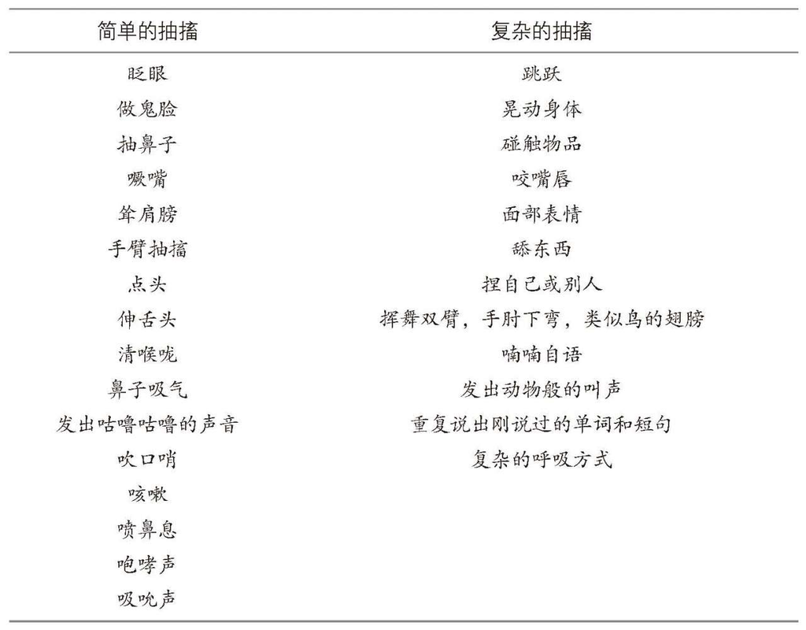

非自主性的动作或声音通常都是突然发生的，而且没有目的。如果阿斯伯格综合征儿童出现抽搐，通常在早期就会出现征兆，随着年龄增长，抽搐的次数和复杂性逐渐增加，非自主性动作在10～12岁达到高峰。到了青少年后期，抽搐的次数逐渐下降，40%的儿童到了18岁以后，抽搐就会消失（Burd et al.2001）。

儿童的语言抽搐也会随着时间而改变，出现不同形态的抽搐，也可能有几个月的时间完全没有发生抽搐。孩子在专心做一件事，或在进行某项吸引人的活动时，比如，回答开放式问题的时候，抽搐可能会消失（Nass and Gutman 1997）。孩子放松时（比如坐着看电视），可能就会出现非自主性动作，压力不一定会直接影响抽搐的发生，不过面对压力环境，抽搐的频率可能增加。

抽搐不一定只是非自主性的动作和声音。我认识有些合并抽搐障碍（tics）的阿斯伯格综合征青少年，提到自己“脑中会蹦出一些不理性的想法”，我称这些为想法和情感抽搐（thought and emotion tics）。这些想法和紧跟着出现的行为或感受，不见得和当时的气氛有关系。有时，可能出现想做出某些不当行为和让他人困窘行为的想法，或者出现强烈悲伤、生气或焦虑等情感抽搐。这些情绪感受一般只持续几秒钟，不过，假如一天当中频繁发生，就值得关注。

我们知道，抽搐的发生是因为大脑皮层和大脑运动中枢之间的计划回路障碍，以及神经递质多巴胺和去甲肾上腺素的活动（Kutshcher 2005）。医学上减低抽搐频率的原理就是降低多巴胺的分泌。父母应当了解，某些药物，如用来治疗注意力缺陷多动障碍的兴奋药物，会增加多巴胺的分泌，从而增加抽搐频率。

由于抽搐的非自主性，儿童总是无法意识到即将发生抽搐，因此，很难抑制这些动作或声音。不妙的是，某些动作，如间歇性的吸鼻涕，容易让家人生气，而且受到学校同学的捉弄和取笑。因此，无论是父母、老师或同学，都不应当批评或取笑孩子的非自主性动作或声音，有时最好的做法是不理会抽搐。如果孩子因为别人的反应而感到痛苦，父母应当给予同情和感情支持。频繁的抽搐动作或声音也可能干扰班上正在进行的活动，也会让其他孩子分心，容易破坏儿童自身的注意力，因此，需要花费较多时间才能完成工作。老师需要做榜样示范如何接受阿斯伯格综合征儿童的抽搐行为，必要时也可以给他们较多时间完成工作，并鼓励其他孩子不要理会这些动作或声音。

临床心理学家和精神科医生都关心抽搐的发展。根据临床经验和最近的研究结果发现，某些阿斯伯格综合征儿童日后可能出现三种不同的发展障碍。如果出现至少两种抽搐动作和至少一种声音抽搐，而且这些症状至少持续一年，就需要考虑抽动秽语综合征的诊断。合并抽动秽语综合征的阿斯伯格综合征儿童，也很有可能出现注意力缺陷多动障碍以及发展焦虑障碍，如强迫症（Epstein and Saltzman-Benaiah 2005；Gadow and DeVincent 2005）。因此，虽然抽搐的发展情况相对较好，不过，临床工作者在诊断评估当中除了确认抽搐症状，也应当筛检是否合并有注意力缺陷多动障碍的症状，并评估是否有出现强迫症的可能性。临床工作者也应当留意，这些合并的障碍是否影响到儿童的日常生活，并且必须熟悉所有相关的治疗和教育方法。

## 七、运动能力的退化

有一些研究文献指出，某些阿斯伯格综合征青少年的动作能力出现缓慢但持续退化的现象（Dhossche 1998；Ghaziuddin，Quinlan and Ghaziuddin 2005；Hare and Malone 2004；Realmuto and August 1991；Wing and Attwood 1987；Wing and Shah 2000）。这些个案非常不寻常，退化表现在动作和口语反应越来越慢，很难开始和完成一个动作，而且在做某件事情时，如铺床或穿衣服，越来越需要一些身体指导或口头提醒。有时，他们做某件事时会瞬间僵住，有时会出现静止性震颤，缓慢拖拉的步态，肌肉僵硬，以及一张看似戴上面具的漠然面孔，这些特征很类似紧张症（catatonia）和帕金森症的运动特征。

动作的退化现象常发生在10～19岁之间，在孤独症青少年身上比阿斯伯格综合征青少年出现得更多，特别是那些有严重学习和语言障碍的人。不过，也有少量阿斯伯格综合征青少年会出现这种现象。这种退化现象，只是和紧张症和帕金森症类似，但不能直接与两者等同，我们可以用一个新名词“孤独紧张症”（autistic catatonia）来形容（Hare and Malone 2004）。我们还不太确定，这种动作能力的退化是源于某一特定的神经学状况，还是一种异常的心理–运动迟滞表现，或者是因为临床抑郁症导致的动机缺乏，还是掌管运动规划和执行反应（比如化想法为行动）的认知能力出现严重退化。

目前我们正在努力开发不同的治疗方法（Dhossche 1998；ghaziuddin et al.2005；Hare and Malone 2004）。如果阿斯伯格综合征青少年出现孤独紧张症的症状，应当立即转入神经学家或神经精神学家诊所，安排完整的运动技能检查。药物和其他一些治疗技术可以有效降低这种罕见的动作障碍。父母也可以利用一些简单的技巧，帮助他们开始或重新开始一个动作。例如，由别人接触需要移动的那只手或脚，或旁边安排一个人操作相同的设备，示范如何开始一个动作。另外，听音乐也有助于保持动作顺畅。物理治疗师为帕金森症病人设计的一些活动也可以帮助阿斯伯格综合征和有紧张症的孤独症青少年。

## 八、运动能力表现优异

虽然我们已经知道阿斯伯格综合征可能伴随运动能力缺陷，不过我也认识某些阿斯伯格综合征儿童和成人具有非常优秀的运动能力，甚至能赢得国家和国际的竞赛奖牌。动作方面的一些缺陷并不会影响到某些运动技能，如游泳、蹦床、高尔夫和骑马这类可以单独练习的活动。因为他们的表现相当不错，这些活动也会成为阿斯伯格综合征儿童的特殊兴趣，再加上大量的练习和专心一致的决心，他们的这些技能往往能达到非常高的境界。

阿斯伯格综合征儿童也可能展现耐力极限运动的特长，如马拉松赛跑。阿斯伯格综合征人士一旦跑出成绩，就会忍受一切痛苦，坚持跑步。阿斯伯格综合征儿童可能也会喜欢剑术之类的运动，参与者戴上面具就没有和对手目光接触的问题，而且需要学习一些固定的动作和反应。武术也是吸引他们的运动，特别是能以慢动作的方式学习一些防卫和攻击动作，武术的发展历史和文化也会吸引他们的兴趣。室内台球运动是和敏捷性无关的项目，阿斯伯格综合征青少年也许凭直觉就能理解球的移动规律。虽然一位阿斯伯格综合征人士杰里·纽波特曾对我说：“我从来做不出任何优雅的动作”，不过，阿斯伯格综合征儿童的确有潜力参与和喜爱一些运动项目，在某些项目上甚至能有杰出的表现。

## 本章重点及策略

至少有60%的阿斯伯格综合征儿童动作笨拙，不过，一些采用专门评估方法测试的研究指出，几乎所有的阿斯伯格综合征儿童都有特定的运动障碍表现。

阿斯伯格综合征儿童走路或跑步时的协调能力不够成熟，而阿斯伯格综合征成人则常有奇怪的甚至独特的步态，缺乏流畅性和功效。

老师也会注意到他们的精细动作问题，比如写字和使用剪刀的能力。

有些阿斯伯格综合征儿童接球、投球和踢球的动作能力都发展得不成熟。

从孩子很小开始，父母就可以安排指导和练习球类技巧，这不是为了让他成为优秀的运动员，而是为了让他具有基本的能力，顺利加入一些受同龄人欢迎的球类游戏。

最近的研究指出，如果追溯到阿斯伯格综合征个体的婴儿时期，会发现他们当时就已经出现异常的动作模式。

动作规划不佳和慢半拍的心理准备时间应当比只用笨拙两个字形容阿斯伯格综合征儿童的运动问题要准确得多。

老师和父母非常关注孩子的书写困难。

我想提醒老师和家长的是，书写技能在二十一世纪是一项过时的能力，现代科技的发展，用打字拯救了有书写困难的人。

体育老师需要了解阿斯伯格综合征儿童的天生特点，并知道如何调整体育课的活动。

根据临床经验和观察，阿斯伯格综合征儿童和成人也会出现偶发性非自主动作或抽搐。

动作方面的一些缺陷有时并不会影响到某些运动技能，如游泳、蹦床、高尔夫和骑马。

# 第十一章 感觉敏感

无论是在味觉还是触觉体验上，我们往往总是有明确的好恶感。许多孩子异常强烈地反感某种触觉体验，他们无法忍受新衣服的粗糙感，或穿上补过的袜子。洗涤液也常带来令人不快的感觉，所以洗手是一个不愉快的场景。此外，噪声也会让人过度敏感。不过，在某一特殊情景下表现过度敏感的孩子，有可能在其他场合却显得过度不敏感。

——汉斯·阿斯伯格（［1944］1991）

临床界和学术界确认阿斯伯格综合征的主要依据是个体在社会推理、同理心、语言和认知能力等方面的能力状况。不过，阿斯伯格综合征人士的自传和父母描述孩子的内容都确认了另外一个明显特征：即对特定的感官体验出现过度敏感或过度不敏感的反应。最近的一些研究和综述性文献也都确认，他们具有异常的感觉知觉和感觉反应模式（Dunn，Smith Myles and Orr 2002；Harrison and Hare 2004；Hippler and Klicpera 2004；Jones，Quigney and Huws 2003；O’Neill and Jones 1997；Rogers and Ozonoff 2005）。有些成人认为，在日常生活中感觉敏感对他们的影响更大，比结交朋友、情绪管理问题和找到合适的工作，都要大。但是，因为医护工作者和学术界人士一直都忽视了阿斯伯格综合征的这一特征，我们目前还无法满意地解释为何会出现异常的感觉敏感，也没有更多有效的策略来矫正感觉敏感的问题。

最常见的敏感反应是针对某些特殊的声音，不过对某些触觉体验、光线强度、食物的味道和质地以及某些气味，也可能产生感觉敏感；对于疼痛和不舒服，会有过度反应或反应过低的情况；对于平衡感、运动知觉以及身体定向，也会反应异常。他们可能有一个或好几个感觉系统同时受到影响，以至于对日常生活中的一些感觉变得非常敏感而难以忍受，或非常不敏感，好像完全感受不到。父母常常会困惑，为什么他们对一些感觉会如此敏感，而对另一些却根本没反应；他们本人同样也困惑不已，为什么其他人没有和他们一样的感觉体验。

父母常会提到，孩子能注意到别人根本听不到的微弱声音，对于突然出现的噪音过度惊慌，以及难以忍受某些频率的声音，如烘手机或吸尘器的声音。孩子必须掩住耳朵来隔绝声音，或绝望地逃离现场。他们也可能不喜欢温和的关怀动作，如拥抱或亲吻，因为这种触觉体验（不一定是情感方面）不太舒服。明亮的阳光会让人眼前发黑，几乎看不清东西；某些颜色会过于刺眼让他们不愿意看；他们还可能会过度沉迷于一些视觉细节，如在阳光照射下漂浮着的灰尘，为此经常发呆。幼儿常常挑食，排斥某些特定质地、味道、气味和温度的食物。他们也对香水或清洁剂的气味避之不及，因为闻起来很恶心。此外，一些儿童也会表现出平衡感的问题，害怕双脚离开地面，讨厌倒立的动作。

在另一个极端，对某些感官体验可能会缺乏敏感度，如对于特定的声音没有反应，受伤时不会感觉到疼痛，或严寒的天气里也不觉得需要添加厚衣服。他们的感觉系统可能在某一个时刻过度敏感，而另一个时刻又过度不敏感。但是某些感觉体验也会激发强烈的愉快感，如洗衣机振动时的声音和触觉，或街灯发出的不同颜色。

## 一、感觉超负荷

阿斯伯格综合征儿童或成人常会提到他们感受到的感觉超负荷。克莱尔·塞恩斯伯里这样描述自己在学校因为感觉问题而带来的反应。

几乎每个学校的走廊和大厅都充满着不断回响的噪声、荧光灯的光线（一个让孤独症谱系人群感到视觉和听觉压力的特别来源）、上下课的铃声、人们之间的相互碰撞，还有清洁剂的味道等等。对于那些普遍具有感觉过度敏感和感觉信息处理问题的孤独症谱系人士来说，每天大多数的时间，他们都面临着感觉超负荷的危险。（Sainsbury 2000，p.101）

妮塔·杰克逊以“汹涌的感觉波浪”来形容强烈的感觉体验（N.Jackson 2002，p.53），这些常会造成阿斯伯格综合征个体产生过度紧张、焦虑，以及几乎“因为过度惊吓而崩溃的状况”；对于普通孩子来说，类似的感觉体验并不会令人厌恶，有时反而是种愉悦的感觉。但是，敏感的孩子在感觉刺激比较多的环境中，比如教室，因为不确定何时会出现下一个痛苦的感觉体验，因而容易变得高度警觉、紧张和容易分心。这些孩子会主动回避某些场合，如学校的走廊、操场、繁忙的购物中心和超市，因为这些地方的感觉刺激都太强烈了。由于对特别强烈的恐惧感有心理预期，他们可能出现焦虑障碍，如因为狗可能会突然吠叫而恐惧狗，或出现广场恐惧症（害怕待在公共场所）。相比而言，家是一个相对安全的地方，可以控制感觉体验。他们也会逃避参加一些社交场合，如生日聚会，不仅仅是因为不确定需要遵守哪些社交规范，也因为那些精力旺盛的孩子们的嘈杂声，和随时可能面对气球突然爆裂的声音。

## 二、诊断评估和诊断标准

我们知道，那些长大后可能发展出孤独症或阿斯伯格综合征其他症状的孩子，在婴儿时期就能确定感觉敏感的问题（Dawson et al.2000；Gillberg et al.1990），因此，对于有可能发展出阿斯伯格综合征其他症状的年幼孩子，应该在前期的筛检中增加某些感觉敏感度的检查。我们也知道，这些特征在幼儿时期非常明显，到了青春期可能会慢慢消失，但某些人可能终身都具有一些特征（Baranek，Foster and Berkson 1997；Church et al.2000）。

设计筛检工具的目的是辨别一个孩子是否有可能是阿斯伯格综合征，是否需要进一步由有经验的医护工作者进行完整的阿斯伯格综合征诊断评估。目前的筛检工具（请参见第一章）包括有感觉敏感的问题，因为医护工作者认为异常的感觉敏感模式可以区分阿斯伯格综合征儿童和普通儿童（Rogers and Ozonoff 2005）。感觉敏感被认为是严重孤独症的一个特征，目前主要的孤独症诊断评估工具——《孤独症诊断访谈表（修订版）》（ADI-R，Rutter，Le Couteur and Lord 2003）就包括询问家长一系列问题，来检查孩子是否曾经对噪音过度敏感，是否曾出现对味道、气味或触觉体验的异常反应。就目前来说，还没有与ADI-R相当的诊断工具评估阿斯伯格综合征，但我和其他医护工作者已经汇集了诊断评估过程中有关感觉敏感的信息，以及异常感觉知觉的发展历史，可以考虑作为确认阿斯伯格综合征特征的依据；但是异常的感觉知觉并没有包括在阿斯伯格综合征目前的四个诊断标准当中。将来在修订诊断标准时应当考虑增加异常的感觉知觉，因为这个特征经常严重影响个人的生活品质。

### （一）概论

临床界和学术界都需要有一个检测阿斯伯格综合征儿童和成人感觉体验的概念性、描述性的框架，博格达什纳（Bogdashina 2003）、哈里森和黑尔（Harrison，Hare 2004）建议阿斯伯格综合征人士可能具有的特征有：

1.感觉体验同时具有过度敏感和过度不敏感的状况。

2.感觉变异。

3.感觉封闭。

4.感觉超负荷。

5.异常的感觉信息处理。

6.很难辨认感觉信息的来源路径。

有些感觉和知觉体验会令他们非常不舒服的感觉，因此，阿斯伯格综合征个体可能会发展出一套应对和补偿策略。但有些感觉体验比听到钟表的滴答声让他们感觉悦耳，渴望再次获得这类愉快的体验（Jones et al.2003）。不管是否引起愉悦感或不适感，他们所感受到的感觉世界绝对与众不同。

### （二）评估工具

目前已经有好几种专门设计的在所有感觉方式中测量敏感度的工具。《感觉行为量表》（The Sensory Behaviour Schedule，简称SBS）是一个由17个项目组成的筛检问卷，提供对感觉知觉和相关行为的简要描述（Harrison and Hare 2004）。《感觉能力分析量表》（The Sensory Profile）共有125个题目，用来测量5～11岁的孩子在感觉信息处理、感觉调节、针对感觉体验的相应行为和情绪反应，以及过度反应或过度不反应等方面问题的严重程度（Dunn 1999b）。此外，也有一份简单版量表（Shot Sensory Profile），父母只需十分钟就可以填写完毕（Dunn 1999b）。

《感觉能力分析检核表（修订版）》（The Sensory Profile Checklist Revised，SPCR）是一份相当全面的评估孤独症和阿斯伯格综合征儿童的工具。分析清单共有232个问题，由家长填写，以确认孩子的感觉优势和弱点，并根据结果确定适当的矫治活动（Bogdashina 2003）。

医护工作者也可以开发自己的评估工具，包括用来检测引起焦虑或过激行为的感觉体验清单。这些工具可以评估包括以下感觉体验的学校环境：书写笔在白板上发出的声音、荧光灯发出的闪烁光线和噪声、吱吱作响的椅子和地板、室内温度、房间内的背景噪声，以及清香剂、美术用品和清洁用品的气味。当我观察一名处在充满挑战性环境当中的阿斯伯格综合征儿童时，常会自己先闭上眼睛仔细聆听，并深吸一口气，试着分辨各种气味，尝试通过他们的眼睛和感觉系统来体会世界。

## 三、听觉敏感

70%～85%的阿斯伯格综合征儿童对某些特定的声音非常敏感（Bromley et al.2004；Smith Myles et al.2000）。根据临床观察和个人叙述，有三种类型的声音容易引发极度的不适感。第一种类型是没有征兆突然产生的噪音，有位成人用尖锐来形容这类声音，如狗吠声、电话铃声、人的咳嗽声、学校火警报警器的声音、按圆珠笔的声音，或脆的东西破裂的声音。第二种声音是连续的高频率声音，特别是室内常用的小家电马达的声音，如食物粉碎机、吸尘器或冲马桶的声音。第三种类型则是一些令人困惑的、复杂的或多层次的声音，如在购物中心或人多嘈杂的社交场合中的背景声音。

父母或老师通常很难理解他们的感觉，因为一般人并不会认为这些声音会带来严重的不适感。不过，想象一下，听到指甲刮黑板的声音所带来的极度不舒服，甚至仅仅是回想一下这种声音都会让人反感地起鸡皮疙瘩，这其实就是阿斯伯格综合征人士对那些声音的感受。

下面我引用几位阿斯伯格综合征人士如何描述自己的感觉体验强度，以及随之而来的痛苦或不舒服的感觉。第一段来自天宝·格兰丁：

突如其来的巨大响声还是会吓到我，我对声音的反应通常比别人强烈。我一直讨厌气球，因为我永远不知道哪一个会突然爆掉，这会让我吓得跳起来。持续的高频率马达噪声，如吹风机和浴室的通风马达，也会让我感到不舒服，但低频的马达声音就没有关系。（Grandin 1988，p.3）

达伦·怀特（Darren White）描述道：

我也很怕听到吸尘器、食物搅拌机和榨汁机的声音，因为我感受到的音量可能比实际大了五倍之多。

公共汽车的发动机声音对我来说就像一阵阵打雷，仿佛比原来放大了四倍，每次坐车时我都必须用手捂住耳朵。（White and White 1987，p.224-5）

特雷泽·乔利夫（Therese Jolliffe）这样描述自己的听觉敏感度：

下面这些声音是现在依然困扰着我、必须用手掩住耳朵才能忍受的：叫喊声、人多嘈杂的声音、碰到泡沫塑料餐具发出的声音、气球和飞机的声音、建筑工地上机械的噪音、捶打和敲击声、电动工具使用时的声音、海浪声、荧光笔在纸上涂色或划线的声音和放焰火的声音。不过除了这些，我可以读乐谱并演奏乐器，也喜爱某些风格的音乐。事实上，当我感到生气和绝望的时候，只有音乐才能让我内心平静下来。（Jolliffe et al.1992，p.15）

利亚纳·霍利迪·维利提到有几种特定的声音会让她感到非常痛苦：

高频率和金属般尖锐的声音都会刺激我的神经。口哨声、聚会上制造噪声气氛的玩具、长笛和喇叭声以及其他类似的声音，都会干扰我的平静心情，让周围一切变得面目可憎。（Willey 1999，p.22）

威尔·哈德克罗夫特（Will Hadcroft）解释一个人是如何在不愉快的听觉体验中变得过度焦虑的：

我永远处在对一切事情都感到紧张和恐惧的心态当中。我厌恶走在铁桥下时刚好有一列火车从我头上驶过。我害怕气球爆裂的声音、聚会中礼花炮的声音和圣诞节礼花筒的声音。我非常小心地避免碰到任何突如其来的大声响。哦，我还没提到打雷，这是我绝对害怕的声音，即使日后我知道闪电才是危险因素，但还是更害怕打雷声。虽然我喜欢观赏放焰火的场面，但烟花节（Guy Fawkes Night）的来临还是会让我感到紧张万分。（Hadcroft 2005，p.22）

敏锐的听觉也可能被视为一项特长，如艾伯特（Albert）能比父母早好几分钟听到火车快进站的声音。他说：“我总是能先听到，妈妈和爸爸不能，我的耳朵和身体都感受得到这种声音。”（Cesaroni and Garber 1991，p.306）我在诊所看过一名儿童，他的特殊兴趣是公共汽车，能分辨出经过他家附近汽车的独特发动机声音。他的第二个特殊兴趣是公共汽车号牌，他可以很快认出即将驶来但还看不清楚的公共汽车的号牌。不过，他不喜欢在家里的后花园玩，问他原因，他解释说不喜欢听到如蝴蝶等昆虫拍动翅膀发出的啪啪声。

有时，他们也会出现听觉变异或封闭的现象。达伦是这样描述这种波动状的变异情况：

我的耳朵会玩一个花招，即能够改变周围声音的大小。有时候我很难听到别的孩子跟我说话时的声音；而有时候，他们的声音听起来却又像子弹发射的巨响。（White and White 1987，p.224）

唐娜·威廉姆斯这样解释：

有时候，别人必须把一个句子向我重复好几次，因为我总是只听到一些片段。我的脑子把他们讲的句子切割成一个个单字，变成一种奇怪的、不知所云的信息，这有点像有人在不停地调电视机的音量。（Williams 1998，p.64）

我们不太确定，感觉封闭是因为正沉迷于某项活动以至于听觉信号无法打断极为专心的状态，还是因为天生就会暂时或间断性失去听觉信息的知觉和处理能力。这样的特征会容易让父母怀疑他们的阿斯伯格综合征幼儿是否耳聋。唐娜·威廉姆斯对此提道：

我的父母曾认为我耳聋。他们站在我身后，轮流发出很大的声音，我却丝毫没有反应。我被带去做听力检查，测验结果表明我没有耳聋，但我还是会这样。几年之后，我又接受了一次听力检查，这次发现我的听力比普通水平要好，我可以听见只有某些动物才能听得到的声音频率。我的听力问题显然是因为对声音的注意力不够稳定。（Williams 1998，p.44）

阿斯伯格综合征个体如何应对听觉敏感？有些人会学着拒绝接受特定的声音，就像天宝·格兰丁描述的：

当我碰到太大的噪声或令人迷惑、我自己都无法辨别的声音的时候，我或是将它们全部挡在外面，或是全部接受，就像让耳朵驶入一辆货车。为了避免声音的突然冲击，我常选择退缩到隔绝世界的地方。成年之后，我还是很难调整听觉的输入。如果在机场打电话，我无法屏蔽掉周围的背景声而保留电话中的声音。其他人可以在嘈杂的环境中打电话，但我不行，虽然我的听力完全正常。（Grandin 1988，p.3）

还有一些技巧可以防止那些不愉快的感觉体验的入侵，如通过哼歌来阻绝噪声，或专注在某一活动中，这等于是接受了催眠。

### 降低听觉敏感的策略

必须首先找出那些令阿斯伯格综合征孩子非常痛苦的听觉体验，那些让孩子必须用手捂住耳朵来防止痛苦的声音，用身体退缩或不断眨眼等行为回应的突发噪声，或让他们直接告诉我们哪些声音听起来很难受。我们可以帮助孩子避免接触到这些声音。如果孩子感觉吸尘器的声音太过强烈，可以挑选孩子在学校的时候再使用吸尘器，这是最简单实际的解决办法。有个小女孩无法忍受教室里其他同学和老师把椅子在地板上拖动的声音，我们就将每张椅子腿包上垫子，让她能安心上课。

也可以用物理隔绝听觉刺激的方法，比如，准备一副硅胶耳塞放在口袋里，只要感觉噪声无法忍受就戴上。这个方法非常适用于已知的嘈杂场所，如学校的餐厅。在前面引用特雷泽·乔利夫的话中也提到过一个策略：“……当我感到生气或绝望时，音乐是唯一能让我内心感到平静的方法。”（Jolliffe et al.1992.p.15）我们可以试着让他们学习用耳机听音乐，隔绝那些感觉强烈的噪音，这样他们就能平静地逛购物中心，或在吵闹的教室里专心写作业。

向孩子解释那些难以忍受的声音的成因和持续时间也会有帮助。卡萝尔·格蕾所创的社交故事（请参见第三章）用途非常广泛，也适用于处理听觉敏感度问题。针对一名对公共卫生间烘手机的噪声敏感的孩子，可以给他撰写社交故事，说明这个机器的功能和设计原理，并说明一段时间后机器会自动关闭。这些令人安心的知识可以降低孩子的焦虑感，并增加忍耐力。

很明显，父母和老师都必须了解孩子的听觉敏感性，并努力降低突发噪声的强度，减少孩子所处空间内的背景声和谈话声，尽量避免接触那些已知的孩子无法忍受的强烈听觉体验。这些做法都可以降低他们的焦虑感，并帮助孩子提高注意力和社会性。

目前还有两种治疗方法可以降低孤独症或阿斯伯格综合征儿童的听觉敏感度。由职业治疗师发展的感觉统合治疗（Sensory Integration Therapy，Ayers 1972），主要是依据琼·艾尔斯（Jean Ayers）首创的做法，在治疗过程使用一系列专门的游戏设备，改善感觉信息的处理、调整、组合和统合能力。在治疗计划中，需要安排可控而且有趣的感觉体验，由职业治疗师执行，每周进行几个小时，连续持续几个月。虽然这套方法非常流行，但几乎没有实际证据可以证明感觉统合治疗的有效性（Baranek 2002；Dawson and Watling 2000）。不过，就如同格雷斯·巴拉内克（Grace Baranek）在回顾研究文献的文章中提到的，缺乏实证数据并不代表感觉统合治疗没有效果，只是目前还未能客观科学地展现成效。

另一种治疗是由居伊·贝拉尔（Guy Berard）在法国首创的听觉统合治疗（Auditory Integration Therapy，AIT；Berard 1993）。这个治疗方法需要被治疗者戴着耳机听一套总共十个小时的电子调制音乐，疗程为十天，每天安排两次，每次半个小时。在治疗之前的评估中，用听力图确认患者对哪些频率反应过度敏感。之后，根据听力评估的结果，使用特制的电子调制和过滤设备，随机制作高频和低频的声音，并过滤掉让人敏感的波段。这种治疗花费昂贵，虽然也有传闻说的确有一些成功的案例能够降低听觉敏感度，但目前依然缺乏实证研究的支持（Baranek 2002；Dawson and Watling 2000）。

虽然有些声音令他们感到不舒服，但我们也应当记住，有些声音会令他们感到非常愉快。举个例子，有个阿斯伯格综合征幼儿非常着迷于特定的主题旋律或时钟的滴答声。唐娜·威廉姆斯也提道：

我非常喜欢的一种声音是金属发出的声音。我妈妈有一阵肯定非常苦闷，因为我家的门铃刚好属于这类声音，所以我经年累月地喜欢去按门铃。（Williams 1998，p.45）

我妈妈最近租了一架钢琴，而我从很小就喜欢能发出响声的东西。我会把别针串起来，不是用嘴巴咬着玩，就是放在耳边让它们摇晃发出声音。同样，我也喜欢金属碰撞的声音。我最喜欢的两件东西是一片水晶和一个音叉，我随身带了好多年。（Williams 1998，p.68）

## 四、触觉敏感

超过50%的阿斯伯格综合征儿童对某种形式的触摸或触觉体验会出现过度敏感反应（Bromley et al.2004；Smith Myles et al.2000），他们对某一类的触摸、按压身体的力度或触碰到身体的某个部位，会过度敏感。天宝·格兰丁这样提及自己幼年时敏锐的触觉：

婴儿时期我拒绝别人碰我，年龄稍大一点，我记得如果有亲戚抱我，我的身体会变得僵硬、退缩而且想要逃开（Grandin 1984.p.155）。

儿童时期的我曾经渴望被拥抱的舒适感，不过每当有人抱我，我还是会逃开，害怕那种仿佛失去控制要被吞没的感觉（Grandin 1984.p.151）。

对天宝来说，社交问候中的身体接触形式或表达感情的姿势动作都让她感觉太过强烈，难以承受，就像大浪向感官涌来。因此，某些逃避社交互动的行为也许本质上是因为害怕身体接触带来的生理反应。

阿斯伯格综合征儿童害怕与其他孩子太靠近，可能也是担心会出现无意的或非预期的身体接触。他们也害怕和亲戚会面，因为不喜欢可能发生被拥抱或亲吻的感情动作，这些都会引起感觉的过度敏感反应。

利亚纳·霍利迪·维利这样描述自己童年时的体验：

我常发现自己甚至不可能去摸某些东西。我讨厌僵硬的、光滑的、粗糙的或穿上很紧的东西。我想到或是看到这些东西，甚至仅仅是脑海里存在这类东西，就会马上起鸡皮疙瘩和打寒战，出现很不舒服的感觉。即使是在公共场合，我也会马上脱掉那些让我不舒服的衣物。（Willey 1999，pp.21-22）

据我所知，成人后的利亚纳不再有上述行为，但她在最近写给我的电子邮件中提到，她的触觉还是比普通人敏感，有时因为不能忍受身上穿的衣服而又离家太远不能更换，就会到附近的服装店买一套新衣服穿。我理解这绝对不是为了想买更多新衣服而找的借口。

天宝·格兰丁在儿童时期也讨厌过某种质地的衣物。

有些不良行为直接来自感觉的困扰。我常因为星期天必须穿感觉不舒服的正式服装而在教堂里行为失礼或尖叫。冬天去教堂必须穿着裙子，走在路上时我的腿就感到非常不舒服，衬裙的粗糙质地让我发疯；大多数人对此不会有特别的感觉，但孤独症孩子却会感觉像砂纸在打磨皮肤一样，我们受损的神经系统会将某些刺激过度放大。其实解决我的问题很简单，只要用我平常穿的柔软衣料制成正式的衣服就行了。成年之后，我依然对穿新样式的内衣感觉极不舒服。大多数人习惯于不同材质的衣服，但我总是要花很多时间去适应新的材质。现在，在购买日常和正式服装时，我还是要尽量挑选同一材质的。（Grandin 1988，pp.4-5）

阿斯伯格综合征儿童可能会坚持只穿少数几件衣服来维持同样的感觉体验，父母的麻烦是必须勤洗，而且需要留意这几件衣服的耐洗性。如果孩子习惯了某种材质，父母可以一次购买很多件不同尺寸的相同衣服，这样就可以应付洗涤、着装、破损和孩子逐渐长大的体型。

阿斯伯格综合征儿童身体的某些部位可能过于敏感，如头部、上臂和手掌。他们可能会感觉洗头、梳头或理发是很痛苦的事情。斯蒂芬·肖尔提到自己童年时对理发的反应时说：

理发对我来说一向是件大事，实在让我很痛苦。父母为了安慰我，告诉我头发是死的，没有感觉。我无法清楚地告诉他们，是头皮被头发拉扯而感觉不舒服。别人帮我洗头也是很困难的事情。现在我长大了一些，神经系统也比较成熟，理发终于不再是个麻烦事了。（Shore 2001，p.19）

理发的体验也会受到听觉敏感的影响，即讨厌听到剪刀的尖锐声音，以及电动推子的震动声。碎头发掉到脸上和肩膀上的触碰感，也会让人感觉不舒服。年幼的孩子如果坐在成人的理发椅上，脚碰不到地面，也会产生不稳定的不适感。

汉斯·阿斯伯格医生注意到有些儿童讨厌脸上有水的感觉。利娅（Leah）曾写信描述说：

小时候我很讨厌淋浴，盆浴还可以，因为我无法忍受水冲在脸上的感觉，一直到现在还不喜欢。有一阵子我连续几个星期不洗澡，当我发现其他孩子每天都定时要洗澡时，感觉非常惊讶。

这一特征明显会影响到个人卫生，以及和同龄人交往的受欢迎程度。

触觉的敏感可能会导致孩子无法忍受教室里的某些教学活动。阿斯伯格综合征儿童往往讨厌手上有胶水的感觉，不喜欢手指画，不喜欢捏橡皮泥，也讨厌参加戏剧表演活动，因为强烈不喜欢戏剧服装的粗糙材质地带来的触觉感受。他们对挠痒痒以及身体某些部位被突然触碰（比如被人戳一下后背）会出现过度反应。一旦青少年同伴们发现了这个反应，阿斯伯格综合征青少年就很容易成为被捉弄或折磨的对象，经常会被人用手指戳背，然后欣赏他们明显惊恐或不舒服的反应。

触觉敏感也会影响到成人和伴侣之间的感觉体验和性关系（Aston 2003；Hénault 2005）。每天表达情感的亲密动作，比如，爱抚地触摸前臂和拥抱，对阿斯伯格综合征个体可能都不是愉快的感觉体验。非阿斯伯格综合征的一方会抱怨阿斯伯格综合征伴侣明显不喜欢表达情感的身体接触，不会主动做出亲密的动作。面对能够带来感觉愉快体验的常见的亲密身体接触，他们也会在触觉方面过度敏感，认为这类体验的感觉不愉快或甚至无法忍受，更谈不上是种享受。所以在做爱时讨厌某种形式的身体接触，可能是因为感觉知觉的问题，而不是因为阿斯伯格综合征个体缺乏爱意或忽视双方关系。

### 降低触觉敏感度的策略

如何降低触觉敏感度呢？父母、老师和朋友应当认识到，阿斯伯格综合征个体对某些触觉体验具有知觉和反应上的困难，不应当强迫他们忍受这些体验，而是应当尽量避免。让幼儿玩一些不会导致触觉防御的玩具和教学活动，就不会带来痛苦。感觉统合治疗虽然可能会降低触觉防御，但正如前面所述，目前仍缺乏实质科学研究证实感觉统合治疗的成效。

父母可以减少问候时表达情感的身体碰触和持续时间，并且让孩子预先知道他可能被碰触的时间和方式，避免因引起太唐突的感觉反应而导致惊吓。我们可以剪掉衣服的标签，鼓励孩子忍耐洗头和理发，使用剪刀和电动推子前预先给孩子进行头部按摩，或者用毛巾缓慢而有力地摩擦孩子的头皮和肩膀，降低孩子头皮的过度敏感度。有时，触碰的力度也会产生问题，对于轻轻的触碰更容易出现敏感反应，而用力的按压反而能够被接受，甚至感觉舒适。天宝·格兰丁发现用力按压或挤压身体的感觉非常舒服而且能让心情平静：

被人拥抱时，我总是想要挣脱并且全身僵硬，但我却渴望被人按摩背部；摩擦皮肤能带来安抚的效果。我还渴望被用力按压的刺激感。我原来一直喜欢躺在沙发垫下面，然后让妹妹坐上来。按压动作能达到安抚和放松的效果。小时候，我也喜欢爬进舒服的窄小空间里，那样感觉很安全和舒适。（Grandin 1988.p.4）

天宝设计过一个人体挤压机，里面铺着泡沫塑料，几乎可以把她的身体整个包在里面，并用木板机械提供稳定的压力。她发现这种机器能产生安抚和放松的体验，并且会逐渐减轻触觉敏感度。

利亚纳·霍利迪·维利喜欢沉浸在水里的触觉愉悦感，她在自传中提道：

我发现在水底下会感觉安全，我喜欢浮在水里的感觉。那时我就像液体，宁静而平稳，内心非常平静。水给人的感觉稳固有力，而处在奇妙的黑暗水底，我会感觉更安全。水能带给我安静、单纯和自然的平静感。我喜欢整个早晨在水底游泳，享受美好时光，努力屏住气待在安静和黑暗的水底，直到我的肺受不了为止。（Willey 1999，p.22）

的确有些触觉体验会让阿斯伯格综合征个体感到愉快，但他们往往处于触觉防御状态，这种状态不仅仅影响到一个人的心理，同时也影响到人际关系，因为普通人习惯于身体接触。阿斯伯格综合征个体似乎还没有准备好接受“保持联系”（keep touch）这句问候语。

## 五、味觉和嗅觉敏感

父母常提到阿斯伯格综合征幼儿有敏锐的能力，可以察觉别人闻不到的气味，而且非常挑食。超过50%的阿斯伯格综合征儿童都有嗅觉和味觉的敏感反应（Bromley et al.2004；Smith Myles et al.2000）。

肖恩·巴伦（Sean Barron）曾说明自己对食物的味道和质地的感觉：

吃饭对我而言是一个大问题。我喜欢吃口味平淡而简单的食物，最喜欢吃的有麦片（不加牛奶，直接干吃）、面包、早餐煎饼、通心粉、意大利面条、土豆和牛奶。这些都是我从很小就开始吃的东西，让我感觉安全而舒服。我根本不想尝试新的东西。

我对于食物的质地超级敏感，把东西放进嘴巴之前，一定要先用手指摸摸它的感觉。我很讨厌把几种食物混在一起，比如面条加上青菜，或把面包做成三明治。我绝对不会吃这种东西，因为我知道吃了之后会非常难受。（Barron and Barron 1992，p.96）

斯蒂芬·肖尔也有过类似的感觉体验：

芦笋罐头黏糊糊的口感实在令人无法忍受，我也好久没吃西红柿了，因为有一次小西红柿在我嘴里突然裂开。小片水果在嘴巴里爆裂出汁水的刺激感也令我难以忍受，因此，我绝对不会再冒险去尝试。

我也不能忍受把胡萝卜放在绿色沙拉里，或把芹菜放在金枪鱼沙拉里，因为这些食物的质地差异太大，但我喜欢单独吃芹菜和小胡萝卜。我小时候喜欢（现在比较少）按照一定的顺序吃东西，先把盘中的某样食物吃完以后，才开始吃第二种食物（Shore 2001，p.44）。

阿斯伯格综合征幼儿可能会坚持只吃清淡和有限的几样食物，比如，每天晚饭都只吃白米饭或香肠加土豆片，而且一吃好几年。孩子对某些食物的纤维质或稀糊糊的质地，或把某些食物混在一起，感到不舒服，然后拒绝吃，这可能会让全家经常吃不好饭，特别是主持做饭的妈妈会感到很失落，因为孩子从来不考虑尝试任何新的或更有营养的食物。还好，随着发育慢慢成熟大部分这类儿童能够逐步增加摄取食物的种类，很多人到了青少年早期，偏食的习惯甚至会完全消失。

吃某些食物时也可能会出现某种触觉防御现象。我们知道，如果把一根手指头伸进喉咙，人都会有干呕的反应，这是一种自发反射的防卫型动作，避免固体物体跑进喉咙里，这种感觉非常不舒服。阿斯伯格综合征儿童如果吃进富含纤维质的食物，口腔也可能会出现类似的触觉防御反应，而不仅仅是在喉咙里。

有时候，他们拒绝吃某种水果或青菜是因为对特别的气味过度敏感。普通儿童或成人可能觉得某些气味非常好闻，但对于具有较强的嗅觉和知觉敏感度的阿斯伯格综合征儿童而言，却可能是过分刺激的气味。我请具有这种特征的儿童描述吃成熟桃子的体会，有人说“闻起来就像尿的味道”或“好像已经烂掉了”。

嗅觉敏感度也会让某些阿斯伯格综合征个体对他人身上的香水味或清香剂味道感觉恶心。有位成人告诉我，他觉得香水味很像杀虫剂的味道。对于嗅觉敏感的儿童，他们可能因为不喜欢闻到图画课里美术用品或学校的餐厅、教室里充满的某种清洁剂的气味而想逃开。

特别敏感的嗅觉也有优点。我认识好几位阿斯伯格综合征成人，他们不只有敏锐的嗅觉，对葡萄酒也有特殊兴趣，因此，成为知名的葡萄酒专家和鉴赏家。有一次利亚纳·霍利迪·维利敏锐的嗅觉在餐厅发挥了作用，她闻出邻座客人点的海鲜已经不够新鲜了，警告他们继续吃就会闹肚子。她也靠自己敏锐的嗅觉，从女儿呼出的气味察觉她生病了（来自私下谈话内容）。

### 增加食物摄取多样性的策略

应该避免使用强迫喂食或挨饿的方法让孩子摄取多样化的食物。当孩子对某种食物越来越敏感，这往往不是简单的故意挑衅的行为问题。不过无论如何，父母应当保证孩子能够摄取足够种类的食物，营养学家可以帮助找出一些孩子能接受而且有营养的、不同质地、味道或气味的食物。孩子的敏感度虽然会随着年龄增长而慢慢消减，但害怕或逃避某种食物的心态可能依然存在。因此，临床心理学家可以设计系统化的脱敏处理方案。首先要鼓励孩子描述自己的感觉体验，找出自己最不反感、最可能接受的食物清单。给孩子尝试他不喜欢的食物时，一开始可以只用舌头舔一舔，试试看味道，而不需要他咀嚼或吞咽下去。在孩子尝试特殊的食物时，应当鼓励他放松心情，大人在一边采取支持的态度，成功时给予祝贺，并提供适当奖品奖励这种勇敢的行为。感觉统合治疗方案应当也能有所帮助。不过，有些成人终其一生只能接受有限的几种食物，具有单一的营养成分，而且得用固定的方式烹调和进食。但我们至少知道，通过不断的练习，可以让他们有效地准备接受更多样的食物。

## 六、视觉敏感

大约五分之一的阿斯伯格综合征儿童对特定的亮度或颜色会出现敏感反应，或者产生变形的视觉知觉（Smith Myles et al.2000）。这些儿童或成人表示，光线太强会导致视线模糊，会避免接触到太强烈的光线。达伦曾提到：“在阳光明媚的天气，我的视线更容易模糊。”偶尔，他也会对某种颜色产生敏感反应，比如：

记得有次圣诞节，我收到的礼物是一辆新自行车，明黄色的，我根本无法去直接注视它。车子上仿佛还有一些红色，因此整辆车看起来像是明亮的橘黄色，在我模糊的视线中就好像一团火。

我也无法看清浅蓝色，这种颜色看起来太淡，好像透明的冰块。（White and White 1987，p.224）

有时，他们也会过度沉迷于视觉细节，很容易注意到地毯上的斑点或他人皮肤上的污点。阿斯伯格综合征儿童如果天生擅长绘画，并发展成特殊兴趣，大量地练习，可能会画出像现实照片一样真实的艺术作品。举个例子，一位幼儿对火车很感兴趣，可能很早就会用透视画法画出火车的图像，几乎包括火车头的每一个细微部分，但他图画中的人物可能只达到同年龄孩子的表现程度。

也有一些人提到视觉变形，达伦说道：

我曾经特别讨厌小卖部，因为我的视觉会让它看起来比实际还小。（White and White 1987，p.224）

这种特殊的视觉体验容易造成害怕或焦虑的反应，特雷泽·乔利夫解释说：

可能是因为我看到的东西总不是正确的影像，因此，我害怕看到一些东西，比如，人（特别是他们的脸）、强光、拥挤的人群、快速移动的物体、不熟悉的大型机器和建筑物、陌生的地方、自己的影子、黑暗、桥梁、河流、沟渠、小溪以及大海（Jolliffe et al.1992，p.15）。

某些视觉体验令人困惑，比如，经过光线反射，教室白板上的文字难以分辨，因而容易分心。利亚纳·霍利迪·维利提道：

太亮的光线、正午的阳光、反射的光线、闪烁的光线、荧光灯，每一种都让我的眼睛受伤。尖锐的声音再加上明亮的光线，会使我的感觉系统超负荷。我的头开始有紧绷的感觉，胃纠成一团，脉搏随着心脏快速跳动，这些感觉一直持续到我能找到一个安全的避难所为止。（Willey 1999，p.22）

在写给我的一封电子邮件中，卡罗琳（Carolyn）解释说：

荧光灯不只光线太强，也会闪烁不停，让我看到一些阴影。小时候，这种感觉令我非常恐惧。长期暴露在荧光灯下，会让我头脑混乱和头晕，甚至导致偏头痛。

有报告说阿斯伯格综合征个体也可能无法看到想找的东西就在眼前（Smith Myles et al.2000）。他们总是看不见“眼皮底下的东西”，似乎天生如此。一个孩子可能被要求从他的书桌或柜子里找一本书，尽管别人很容易看到那本书就在表面，但那个孩子却始终无法认出那就是要找的书。这样的表现可能会惹怒老师，也让他们对自己的蠢笨行为感到生气。

不过，并非所有的视觉体验都会令人感到不安。对阿斯伯格综合征个体来说，视觉的对称性常带来强烈的愉悦感。年幼的儿童喜欢平行线、铁轨上的枕木、警戒栅栏或郊区的电塔，成人对于对称性的兴趣可能延伸到鉴赏建筑物。利亚纳·霍利迪·维利对建筑有着丰富的知识和鉴赏力。

一直到今天，建筑设计依然是我最感兴趣的主题之一。年龄越大，我越容易沉浸在这个兴趣带来的乐趣之中，它几乎是减轻我任何痛苦的完美方案。每当我感到混乱和紧张的时候，我就拿出建筑和设计书籍，凝视那些让我着迷的各种空间和场所，那些线条、直线和画有强烈平衡感图案的建筑平面。当我因生活中太多的错误和失败的沟通而黯然心碎的时候，就会找出房屋设计软件，开始设计一个最有感觉的家。（Willey 1999，p.48）

有好几位知名的建筑师就具有阿斯伯格综合征的某些人格特征。不过，欣赏建筑物的对称性相对也有一个缺点。利亚纳就曾对我说过，假如她看到不对称的建筑，就会对这样的设计感到恶心和烦躁不安。

### 降低视觉敏感度的策略

父母和老师可以避免将阿斯伯格综合征孩子安置在会对视觉造成紧张和不安的环境中，比如，不要让孩子坐在车上太阳晒得到的靠窗位置，或教室里阳光照得到的座位。另一个方法是让他们在室内也使用太阳镜和护目镜，以避免强光或眩光，或者安排一个特别的位置，过滤掉视觉刺激。孩子还可以留一头长发作为天生的帘子或障碍，隔绝不舒服的视觉或社会性的体验。由于对某些色彩强度的感知问题，孩子可能喜欢穿单一黑色的衣服，这不一定和时尚有关。

有一些矫治方法可能可以降低孩子的视觉敏感度。海伦·伊尔伦（Helen Irlen）发明并使用一种有色镜片，可以改善视觉知觉，降低视知觉超负荷等困扰。这种没有度数的有色镜片（称为伊尔伦滤镜）可以过滤对阿斯伯格综合征人士敏感的光线频率。在初期的评估过程中，可以使用一份特别的问卷和一套测试程序来确定镜片的颜色。目前尚没有实证科学研究表明这种镜片对于阿斯伯格综合征个体有效，但我知道，有几位儿童和成人曾提到戴上这种滤镜确实能降低视觉敏感度和感觉超负荷。

视觉治疗（Vision Therapy）主要是由行为验光师（behavioural optometrist）提供对眼睛和大脑处理视觉信息部分的再训练，评估过程包括判定可能的潜在视觉异常功能以及任何一种补偿机制，比如，斜视或转动头部、使用周边视野以及偏好使用一只眼睛。这套矫正方案采用每周一次的治疗过程，并布置家庭任务进行练习，但目前也还没有相关的实证科学研究证明它对阿斯伯格综合征个体的有效性。

还有需要记住的一点是，当阿斯伯格综合征个体感到非常不安或激动时，最好是安排一块区域或一个房间，让他们撤退到里面，远离人群慢慢平静下来。在这个区域需要考虑让感觉平静和放松的因素，可以布置对称的家具，考虑墙壁和地毯的颜色，并避免不愉快的声音、气味或触觉体验。

## 七、平衡感和运动感

有些阿斯伯格综合征儿童的前庭系统有问题，会对平衡感、动作知觉和协调性（Smith Myles et al.2000）产生影响。有一个说法是这些孩子有“重力不安全感”，一旦双脚离地，他们就会变得焦虑；需要快速变化身体姿势时（比如参加足球等球类运动），也会有迷失方向的感觉；当他们倒立时，会极度不舒服，也影响到平衡感。

利亚纳·霍利迪·维利提道：

我实在不擅长运动。每次看到旋转木马、开车越过山头或快速转过一个拐角，胃就会很不舒服，想吐。第一个孩子出生以后，我很快发现自己的前庭问题不仅表现在游乐场和开车方面，虽然我可以自己摇晃，却无法抱着女儿一起在摇椅上晃。（Willey 1999，p.76）

相反，我知道有些阿斯伯格综合征儿童对于坐过山车分外高兴，甚至视之为一种特殊兴趣，而且喜欢看和听过山车。

其实，一直到现在我们才开始研究阿斯伯格综合征儿童和成人的前庭系统问题。如果儿童有平衡感和运动感的问题，我会建议安排感觉统合治疗。

## 八、对于疼痛和温度的知觉

有时阿斯伯格综合征儿童和成人会表现得坚忍克己，不会对一般人无法忍受的疼痛表现出痛苦和退缩。孩子有时会偶然注意到身上的瘀伤或切口，却不记得是什么时候造成的。他们可以毫不在意地取出皮肤里扎的刺，滚烫的饮料照喝不误，炎热的夏天可能穿着厚衣服，而冰冻的天气里坚持只穿夏装，就好像他们体内有个非常奇特的温度计。

他们对疼痛的反应可能过度敏感或过度不敏感（Bromley et al.2004）。因为对某些疼痛和不舒服的忍受阈比较低，他们常常被同伴形容为“哭宝宝”。不过，阿斯伯格综合征儿童对于疼痛的反应通常倾向于过度不敏感。有位青少年的父亲向我描述孩子的高疼痛忍受阈：

两年前有一天，孩子回到家里，腿部受到严重的刮伤，挫伤得很厉害，还有不少伤口。我赶忙找出急救包，告诉他坐下来，要处理他的伤口，但他似乎不太理解，说道：“没关系，根本没感觉，我常常这样”，接着就走回自己房间去了。十八年来这种情况一直如此。他也不像别人一样感到冷，即使到了冬天也不穿外套，总是穿着短袖衣服去学校，而且觉得很舒服。

有一年冬天我在澳洲沙漠中度假，正巧碰到一名来自美国的阿斯伯格综合征年轻人。我们和其他旅行者一起享受户外晚餐，这样我们就有机会欣赏到沙漠天空中明亮的星星，饭后我们还参加了一位天文学家的讲座。当天的气温在冰点以下，除了这位年轻人以外，每个人都不断抱怨太冷了，身上也加穿了不少厚衣服。而这位年轻人却一直只穿一件T恤衫，不肯穿上同伴递给他的厚衣服。他解释说自己觉得很舒服，但其他人看到他在这么寒冷的沙漠夜晚只穿单薄衣服，却都感到不舒服。

在卡罗琳写给我的一封电子邮件中提到了另外一个例子，她说：

我对疼痛和温度的反应，就跟我对无关紧要的事情或受到巨大创伤的反应相似：面对低刺激事件的反应太过夸大，而面对高刺激事件时却又感觉麻木。在多数实际情况中，我比普通人表现得好。一个无关紧要的事件可能会非常戏剧性地妨碍我的行动表现，但是面对巨大创伤事件，我却可以进行逻辑思考，表现得冷静而有效率，不像别人那么惊慌。

汉斯·阿斯伯格医生注意到，他看过的儿童当中有四分之一的孩子完成大小便训练的时间比较晚（Hippler and Klicpera 2004）。这些孩子可能是不容易察觉到尿急和便急的信号，以至于经常发生大小便失控的意外。对不舒服、疼痛以及极端温度缺乏反应，使得年幼的阿斯伯格综合征儿童往往无法学习怎样躲避危险，常常因为意外事故被送到医院急诊。医护人员可能会对儿童的大胆感到惊讶，也可能怀疑父母是否疏于照看孩子。

父母最担忧的一个问题是不知道如何察觉孩子是否有慢性疼痛的症状需要就医，中耳炎或盲肠炎可能会发展到很危险的状态才被发现，孩子也不会提到自己吃药后的副作用，或牙疼、例假带来的疼痛和不适。有父母注意到孩子几天来的表现有点异常，不过孩子说不出来自己到底是不是很痛，他们最后决定带他去看医生，结果发现是睾丸扭转，必须切除。如果孩子稍微有疼痛的表现，父母就必须对任何不适感保持警惕，并检查是否有疾病的表现，如发高烧或肿胀，并且利用第六章提到的情感表达策略，如情感温度计，来帮助孩子表达疼痛的强度。父母也需要撰写社交故事，向孩子解释疼痛时告诉大人的必要性，因为这可以帮助他恢复良好的感觉，避免情况恶化。

## 九、异常的感觉信息处理

有种很少见的感知觉叫做“联觉”，指的是人的某个感觉系统体验到一种感觉信息，同时联系到另一个感觉系统的知觉体验。最常见的一个例子是每次看到某种颜色，耳朵就会听到一个特别的声音（称为颜色听觉），或闻到某种特别的气味。这不是阿斯伯格综合征个体所独有的特征，但的确有好几位成人描述过这个不寻常的现象。举个例子，吉姆（Jim）提到：“有时候，这些感觉通道混在一起，声音仿佛通过颜色传了进来。”（Cesaroni and Garber 1991，p.305）他解释当某种声音出现时，常伴随着模糊的颜色、形状、质地、动作、香味和味道。利亚纳解释说：“当我努力搜寻某个单词的时候，我需要的是那些能让我发笑的单词，那些具有柔顺质地的单词，以及说出来令人感觉暖和的单词。”（Willey 1999，p.31）

吉姆也注意到，听觉刺激会干扰其他感觉的处理过程，比如他“必须关掉厨房里的电器，才能尝到食物的味道。”（Cesaroni and Carber 1991，p.305）异常的感觉信息处理还包括很难分辨感觉信息的来源。吉姆解释说：“有时，我知道有什么感觉在某个地方出现，但我无法马上说出到底是哪种感觉。”（Cesaroni and Garber 1991，p.305）这种体验让人非常困惑，糟糕的是，对感觉知觉领域的研究才刚刚开始，我们依然无法明确解释这些现象（Bogdashina 2003）。

本章的最后要用利亚纳·霍利迪·维利的话，说明阿斯伯格综合征人士如何开始慢慢接受自己的感觉知觉，以及如何生活在“充满着声音的环境当中”。

我想，我的女友们开始学着接受在大庭广众中没有太多疼痛和困窘反应的我。当然，她们还会不断提醒我：不要在众人面前自言自语，在人群当中不要太大声讲话，不要对每个人都提到自家的狗，与人对话时不要天马行空，在公园时不要捂着耳朵大声叫：“难道有人能忍受这些噪音？”不要捏着鼻子尖叫：“天哪，这里怎么这么臭！”不过，今天这已都不再是我的问题了。一路走来，尽管我有这么多的怪癖和奇怪行为，她们却从来不会忘记告诉我，无论怎样她们都会永远爱我。（Willey 1999，pp.93-4）

## 本章重点及策略

有些阿斯伯格综合征成人认为，相对于结交朋友、管理情绪和找到合适的工作等问题，感觉敏感更严重地影响自己的日常生活。

最常见的敏感反应是针对某些特殊的声音，但阿斯伯格综合征个体也可能对触觉体验、光线强度、食物的味道和质地以及特殊的气味敏感。对疼痛和不舒服，会有过度反应或反应过低的情形；对平衡感、运动知觉和身体定向，可能也会有异常反应。

感觉敏感的孩子处在有感觉刺激的环境中（如教室），因为他们不知道何时会出现下一个痛苦的感觉体验，因而容易变得处处警惕、紧张而且容易分心。

虽然这些症状在幼儿时期非常明显，但到了青春期可能会慢慢消失。不过，某些阿斯伯格综合征成人可能终身都具有这些特征。

听觉敏感

1.有三种类型的声音会引起极度的不适感。第一种是非预期的突发噪声，第二种是连续的高频率声音，第三种是令人困惑、复杂的或多层次声音的混合。

2.有些声音是可以防止的，比如使用硅胶耳塞可以降低听觉刺激程度。用社交故事向年幼的儿童解释那些难以忍受的声音的来源和持续时间，也会有帮助。

3.有两种治疗方法可以降低孤独症或阿斯伯格综合征儿童的听觉敏感度：感觉统合治疗和听觉统合治疗。不过至今仍然缺乏客观科学的证据证实这两种治疗方法的成效。

阿斯伯格综合征个体对某一类的触摸、按压的力度或触碰身体某个部位，也会出现过度敏感的反应。

嗅觉和饮食的敏感

1.父母常提到阿斯伯格综合征幼儿有很敏锐的能力，可以察觉到别人闻不到的气味，而且非常挑食。

2.孩子的敏感虽然会慢慢消减，但害怕或逃避某些食物的心态可能依然存在，因此，临床心理学家可以设计系统化的脱敏处理方案。

视觉敏感

1.大约五分之一的阿斯伯格综合征儿童会对某种亮度和颜色产生敏感反应，或产生变形的视觉知觉。

2.父母和老师可以避免将孩子放到对视觉感官太过强烈或令人不安的环境当中，比如，不要让孩子坐在车上太阳晒得到的靠窗位置，或教室内阳光照得到的座位。

有些儿童有重力不安全感，一旦双脚离地就会变得焦虑，需要快速变化身体姿势时，也会有定向混乱的感觉。

疼痛的敏感

1.阿斯伯格综合征儿童或成人有时看着就像坚忍的斯多亚学派，面对其他人无法忍受的疼痛时，不会表现出退缩和痛苦。

2.父母最担心的一个问题是不知如何察觉孩子有慢性疼痛症状以及何时需要就医。

3.父母可以做的一个很重要教学方案就是撰写社交故事，给孩子解释疼痛时他必须告诉大人，这是为了能帮助他消除身体的不适感，以免情况恶化。

# 第十二章 大学阶段及职业生涯

我们可以根据孤独症人士幼年时期的表现预测他未来从事的特定行业，这可能比预测普通孩子的未来要更准确。因为他们从事特定行业的能力，常常自然而然地从他们天生的特殊能力中发展出来。

——汉斯·阿斯伯格（［1944］1991）

过去十几年来，被诊断为阿斯伯格综合征的儿童数目明显增多。这些孩子有的已经长大，不少人即将进入社区大学或综合大学学习。之前一些看上去有潜力的阿斯伯格综合征大学生，不能顺利适应从高中到大学的转变，因为他们无法具备大学所要求的更多独立能力，以及相应的学业和社交能力。他们往往由于承受过多压力以及缺乏外界支持而出现焦虑障碍或抑郁症，需要退课或退学。幸好，我们在逐步积累更多知识，更多地了解阿斯伯格综合征大学生需要哪些特殊支持和帮助（Fleisher 2003；Harpur et al.2004；Palmer 2006）。

有不少社区大学、综合大学和其中的某些课程组合非常适合阿斯伯格综合征学生的特点；学生、父母和学校教职员可以在一起讨论每种选择的优缺点，帮助学生做出最后的决定，可以通过在学校网站下载课程详细介绍或访问校园和科系办公室获得相关信息。在读或已经毕业的学生也可以从过来人的角度，为新生提供对课程和教师的看法。父母应当还希望了解，学校可以给阿斯伯格综合征学生提供哪些特殊辅助服务。一旦学生注册了大学的某个课程，高中学校也应当安排教师或辅导人员主动与大学联系，向他们提供怎样帮助该学生的资料。

有些阿斯伯格综合征高中生进入大学之后，不想让学校知道他们的诊断，希望自己能有一个全新的开始，也不希望自己和其他同学被区别对待。我们需要和他们讨论这种做法的优缺点，决定是否要告知学校，以便得到必要的支持帮助。我的通常做法是鼓励学生告诉学校这件事，因为让他们产生不安的通常不在于是否要通知学校，而是用什么方式通知。

阿斯伯格综合征大学生要做好心理准备，因为要面对完全不同的生活方式。在注册入学之前，要先考虑住宿、经济来源以及生活和情感方面的支持问题。住在家里是有好处的，哪怕至少是第一年，因为父母可以在以下方面提供帮助：生活预算、自理能力（如洗衣、做饭和保持个人卫生），以及保证准时交作业所必需的组织能力，并随时检查孩子的压力负荷情况。如果他们必须离家居住，那么学校里帮助大学生的机构就必须了解需要为他们提供哪些额外的支持和监督。

学生本人也需要确定自己一个学期应当修几门课，当然一开始最好不要修太多课程，因为要留下更多的自由时间，学习适应新的生活方式，熟悉环境和学业要求。当他们参与团体作业和写电子邮件给教师的时候也需要接受一些指导，以了解新的社会规范，以及上课和答疑课的流程。可以安排一位辅导学生或导师，随时提供友善的建议，帮助他了解社交程序和要求。

阿斯伯格综合征学生会有一个和以前不同的每日和每周作息表，他们最好也拟定一个学习计划，在学期开始就做好符合学业要求的组织和管理。他们往往需要比其他学生更多地和任课老师交谈，以确认自己没有偏离轨道，并保持继续课业的良好心态。另外，最好能安排一位熟悉阿斯伯格综合征的辅导老师，在必要时能在教员评价学生时为他们争取应有的权益。

安排课程作业和考试时，应当考虑到阿斯伯格综合征学生的独特认知、社会性、动作和感觉。这些学生可能很难用口语表达内在想法和解题方法，有时他们的字迹难以辨认，参与团体项目时有人际技巧方面的困难，对于批评和失败过度敏感。同时，也要考虑到他们的自信心、焦虑和感觉敏感等问题都可能对一些课程产生影响。对此，有一些实际的解决办法，比如，用打字而不是口语来说明一个概念或解决方法，为避免字迹潦草考试时可用键盘答卷，尽量一个人做项目，不参加团体作业等。教师应当理解阿斯伯格综合征的自然特征，并相应地修正授课方法和期待目标。当学生表现出某些特征时，老师不应感到困惑、被冒犯或发火。

学生生活不只是学习，阿斯伯格综合征学生也希望结交朋友以及参加学生团体的社交活动。学校里有很多学生社团和俱乐部，可以提供各种休闲娱乐和社交机会，有些大学还有专门为阿斯伯格综合征学生设立的支持团体。这些团体能为他们提供很多意见，从怎样解决被社交圈孤立的感觉，到如何改善学习方法等等。阿斯伯格综合征老生也可以给“大学新鲜人”提供同理和感情支持。

如果和其他学生建立起友谊，阿斯伯格综合征学生可以获得更多学业上的帮助，比如，分享课程资源和相互校对文章，当他们因为社交天真而受到取笑和欺负时，也可以得到朋友的指导。此外，他们也会遇到如何建立亲密关系和性关系的问题，以及接触到酒精和毒品的可能性，因此，阿斯伯格综合征学生必然需要获得学校教职员和同学们的支持帮助。

学生生活通常充满压力，学生辅导员应当鼓励阿斯伯格综合征学生表达出内心的焦虑、愤怒和难过情绪。第六章提到的认知行为疗法（CBT）和情绪管理策略，非常有帮助。我发现，阿斯伯格综合征学生一旦退课或不及格，并非是智能不足或不够用功，而主要是因为缺乏有效的压力管理能力。

我猜想，某些社区大学或综合大学应当会逐渐积累帮助阿斯伯格综合征学生的经验和专业知识，而且他们会拥有越来越多理解和欢迎这些学生的教师和员工。将来肯定会有类似“针对阿斯伯格综合征学生的最佳大学指南”的非官方手册，这样的大学就会成为学生和家长们的首选。有些大学，比如牛津大学和剑桥大学，在支持有天分的特殊学生和教职员方面已经拥有良好的声誉。另一个有意义的结果就是，阿斯伯格综合征毕业生可能会对阿斯伯格综合征的研究产生很大兴趣。

相对普通学生来说，阿斯伯格综合征学生大学毕业是一件更值得庆祝的大事，因为这意味着他们努力适应了新的生活方式，能够独立自主，成为新的社会力量中的一分子。毕业以后，他们将会面临下一步如何走的问题，有些成人非常适应学术生涯，因此，选择学术和研究作为终身职业，其他人则需要确定如何将自己的学术能力发挥到新的工作岗位上。

## 一、适合从事的职业

其实，没有什么职业是阿斯伯格综合征人士不能做的。我接触过数以千计的阿斯伯格综合征成人，从兼职的邮递员到拥有和经营一个成功跨国公司的老板，职业分布广泛。这份职业清单还包括教师、政治家、飞行员、工程师和心理学家等，所涉及的行业包括电子业、机械业，甚至野生动物保护区的巡视员。阿斯伯格综合征个体通常拥有一些天生的特殊能力，同时也会有一些特定的困难。我们正在研究为何某些个体的工作表现不符合他们所具有的能力和资历，也开始开发一些策略，帮助他们找到和维持一份快乐而有成就感的工作。

### 就业素质

在针对阿斯伯格综合征个体的工作成绩考核表中，一般都会发现以下特征：

1.可靠。

2.坚韧。

3.完美主义者。

4.能很快发现错误。

5.合格的技术能力。

6.富有社会正义感和诚信。

7.倾向对传统常规提出质疑。

8.严谨准确。

9.注意细节。

10.逻辑性强。

11.一丝不苟。

12.知识渊博。

13.富有创意的问题解决能力。

14.诚实。

15.希望固定的规范和清楚的目标期待。

不过他们也有一些特定的困难，容易出现以下的问题：

1.团队合作技能。

2.成为部门经理。

3.不服从传统方法。

4.感觉知觉。

5.按时完成工作进度和遵守工作步骤。

6.管理和表达压力及焦虑感。

7.合乎现实的职业要求。

8.找到符合自己资历的工作——他们的资历通常比工作要求高。

9.误解指令。

10.适应变化。

11.接受建议（容易视他人建议为批评）。

12.个人修饰和卫生。

13.融入团体——容易上当或成为戏弄和折磨的对象。

14.请求帮助。

15.组织计划能力。

16.解决冲突——容易指责别人。

17.人际技巧。

从阿斯伯格综合征个体的经历来看，要找到并维系一份适当的工作或职业并不像有同样资历的普通人那么简单。不过，我们还是有一些策略、服务和资源，可以帮助他们顺利找到合适的工作。

## 二、成功就业的策略

第一个阶段，需要安排一个完整的评估，了解阿斯伯格综合征个体的专业能力和经验，包括认知能力、人格特征、动机、兴趣和人际关系技巧。现在已经有专门为阿斯伯格综合征青少年和成人设计的职业手册，可以用来确定他们工作能力的优缺点，并帮助他们解决在过去工作中所遇到的问题（Myer 2001）。应当在学生大学毕业之前就实施专业能力的评估，以便在他们开始找工作之前就有机会改善某些必要的能力，包括团队工作必备的合作技能，休息时间的闲聊和互动技巧，以及如何应对职业要求的变化。

选择什么样的职业发展道路也必须事先仔细考虑。有些人可能已经具有追求某种特定职业的理想，这时他需要接受指导来了解自己的理想是否符合现实情况，并了解自己必须具备哪些能力和经验。他们的特殊兴趣可能会成为职业发展的路径。阿斯伯格综合征个体通常拥有特殊专长，而这些专长可能有助于发展出一份成功的专业职业，从事与该特殊兴趣相关的研究工作。如果他们拥有有价值的知识，如鉴别珍贵的古董或解决电脑问题，那么，其他人可能会相对容易接受他们的怪异人格特征。高度的视觉推理能力以及多年玩建筑玩具和机械的经验，足以培养出成功的工程师或机械专业人员。绘画、演唱、演奏乐器、作曲和撰写科幻小说的能力，也可以指向艺术方面的职业。充满社会正义感，以及生性和善和关怀弱者的个性，可以考虑那些以关怀别人和追求正义为核心的专业，比如老师、警察、医生和医学相关学科，以及照顾动物。如果对语言、法律和数学有特殊兴趣，可以为做翻译、律师或会计师打下基础。对地图有兴趣的，可以选择做出租车司机、卡车司机或邮递员。

有些阿斯伯格综合征青少年和年轻人可能根本不知道什么样的职业适合他们的能力和人格特征。在读中学的时候，父母可以建议他们尝试不同的工作经验，帮助他们找出将来可能从事的职业方向。这样做不是为了增加孩子的收入，因为其中一些工作经验只是义工，而是增加相关工作的技巧和知识，有利于他们以后做出适当的职业选择。大学的就业服务部门需要明白阿斯伯格综合征学生在求职方面的问题，在他们毕业之前就提供适当的支持和训练。我们也需要注意，有一些行业和职业不是依靠教室内的学习能力，而是通过传统的学徒制学习特殊的职业技能。

接下来，阿斯伯格综合征学生需要准备个人简历，其内容应当包括过去所有的相关工作经验和成就、兴趣和能力，也可以包括记录过去工作成果和证明的照片和录音。在求职面试中，阿斯伯格综合征个体可能不能表现出足够的人际关系能力和自信心，也不如其他候选人那么能说会道，勇于在雇主面前推销自己，但如果准备一份结构良好和内容完善的简历，就能让雇主了解他们比在面试时表现出的水平具有更多专业能力。他们在准备简历和工作申请手续等方面也都需要专业指导。

在申请工作过程和求职面试中，阿斯伯格综合征个体会面临一个问题，即是否要告诉雇主有关自己有阿斯伯格综合征的事实，以及应当提供多少具体信息。这往往是一个非常个人化的决定，牵扯到许多因素，目前有两篇文章可供参考（Murray 2006；Shore 2004）。通常来说，对雇主诚实是上策。

有些阿斯伯格综合征个体不需要太多外界的帮助和鼓励就能依靠自己的力量顺利找到工作，不过对那些很难找到合适工作的人，这里有几本书，对他们自己、父母、职业咨询人员和雇主提供了建议（Fast 2004；Grandin and Duffy 2004；Hawkins 2004；National Autistic Society 2005）。阿斯伯格综合征个体可能需要事先排练求职面试的场景，和熟悉的人讨论是否要接受某个工作机会。不过，绝对不能只要一有工作机会就贸然接受，而应当要考虑这份工作是否的确适合他们。如果处在一个无法顺利工作的情景下，不仅会对他们的自信心产生不良影响，而且也会影响到以后的职业选择。此外，也必须考虑他们的压力承受能力，所以有时从兼职开始做起可能更有好处，等到他们积累了足够的工作经验，获得足够的自信心之后，再转成全职工作。

一旦受雇之后，还需要注意几个特别的问题。从一开始，他们就需要雇主的持续帮助和指导，来了解雇主对工作的期待（特别是出现非预期的变化时），以及在团体中能有效合作的必要人际技巧和组织技能，特别是工作优先顺序和时间管理。不过我也发现，个人卫生习惯通常是导致他们丢掉工作的最快的原因。部门主管除了口头说明之外，也需要配合文字指示，避免因为他们的听觉记忆问题而耽误工作，而且记得要等前一项工作完成之后，再交代下一项工作，避免他们搞混。这些员工也需要别人定期给予回馈，来肯定他们的成绩，并指出需要改进的能力，以及说明如何改善。

帮助阿斯伯格综合征成人建立起顺利的长期工作经历的做法包括：从相关文献获得知识，雇主和雇员保持一贯积极合作态度，给予充分时间以利于双方相互适应。不过，也有一些阿斯伯格综合征成人无法顺利找到和维系一份工作。政府机构需要了解，一名不就业的阿斯伯格综合征成人需要享受政府的福利补贴，需要家人在其生活、经济和情感方面给予帮助，而且他们很容易因为没有工作出现抑郁症和自信心低落。从另一个角度来说，如果他们一直不能就业，社会也无法从这些有天分的人群身上获益。

为了解决这个问题，英国建立了一套支持就业的服务方案。

### （一）展望就业服务

展望就业服务（The Prospects Employment Service）是由英国政府和英国孤独症协会进行的一个联合项目，一开始在伦敦开展，如今已经推广到格拉斯哥、谢菲尔德和曼彻斯特等城市。有130位阿斯伯格综合征和高功能孤独症成人在机构的帮助下达到了70%的高就业率（Howlin，Alcock and Burkin 2005）。这个服务计划为阿斯伯格综合征个体提供就业咨询师，帮助他们寻找和持续工作，对一个人的服务时间可能持续好几年。最近对这项计划前八年工作进行的评估发现，影响阿斯伯格综合征个体就业的最主要特征是：组织能力（特别是配合进度、同一时间专注和应对一项以上任务的能力）、沟通方面的困难、不成熟的社交能力、焦虑感和无法应对变化。

该计划中涉及的大部分职业以办公室工作、技术和电脑行业，以在大型私人公司工作为主，不过也有在政府和公共部门、小型企业和慈善机构的工作。这套计划为每一位受助者投资几千英镑的费用，不过一旦他们受雇，政府的收益会超过投入，因为除了减少福利补贴的花费，同时也增加了来自受雇者的税收。至于阿斯伯格综合征个体的收益，则包括增加可支配收入，提升自信心，建立新的社交网络，以及获得展示特殊天分和能力的机会。针对展望就业服务项目的影响评估研究发现，雇主和受雇者一致同意，如果没有就业咨询专家的服务，他们双方就不可能达到这样的效果（Howlin et al.2005）。

就业咨询师同时扮演多种角色：老师、社会工作者、心理学家、弱势群体代言人，以及为使用不同“语言”和不同期待的来自两种文化的双方担当翻译。咨询师必须了解阿斯伯格综合征个体在工作能力方面的优缺点，为他们确认合适的空缺职位，帮助他们准备面试，在雇主、阿斯伯格综合征个体和他们家人之间进行联络，给雇主提供相应的教育，必要的话，还为要雇员的同事提供培训，并选定一位同事担任他的指导者。咨询师还必须给阿斯伯格综合征个体提供情感和生活上的帮助，并持续监控他们的工作状况，作为“问题处理者”随时准备处理各方面可能发生的冲突和误解。对阿斯伯格综合征个体的个别帮助一开始可能高达每个月50小时，不过会慢慢减少到每个月只有几个小时。以阿斯伯格综合征个体为服务对象的就业咨询师是一项难度很高的工作，不过也是一份很有成就感的工作，特别是看到他们的生活品质因找到一份理想工作而大大提升时。

丹麦的奥胡斯市（Aarhus）有一项有趣的就业实践。有一家公司于2004年成立，所有的雇员都是阿斯伯格综合征或孤独症人士。这家公司主要测试电子设备，包括新的电话机和电脑软件。公司老板（某位孤独症孩子的父亲）专门雇佣阿斯伯格综合征人士，因为他们有一双观察入微的眼睛，而且喜欢做反复检验的工作。每位雇员都有独立办公室，上班时间很有弹性；有一位工作人员专门负责处理个人和人际关系的相关问题。事实上，这不是独一无二的创举，我知道有些信息技术领域的跨国公司就雇佣了为数不少的阿斯伯格综合征人士（或至少人格特征非常相近的人）担任专门技术人员。一些大公司的人事或人力资源部门，也越来越熟悉阿斯伯格综合征，知道如何开发阿斯伯格综合征雇员的潜能，为公司带来更多利益，其中包括避免将他们转到容易引发压力的部门。

### （二）晋升到管理层

阿斯伯格综合征个体的工作能力获得证明之后，下一步需要评估他们的发展情况，考虑是否有晋升为部门主管的可能。最近，我遇到一位任职于一家大公司的阿斯伯格综合征成人，他的工作是修理办公室机械设备。他积累了丰富的有关复印机和传真机的机械和电子知识，总是能很快找出问题原因，快速修理好，进入下一项任务。雇主经常以他作为新雇员学习的优秀榜样。由于他杰出的工作表现，公司决定提升他为修理部门的经理，在公司总部工作。

虽然他拥有机械方面的天分，却天生不懂人的心理。他不理解也不会处理办公室政治、维护自我利益、制定团队政策和处理文字工作。他开始辗转反侧，就像典型的阿斯伯格综合征成人那样焦虑，不过却没有将自己的困难告诉上级领导或妻子。最后因为压力实在太大了，他尝试用自杀来解决一切。精神科医生检查了他的病历，发现他曾被诊断有阿斯伯格综合征。这样，治疗他抑郁症的方法就非常直接——让他回到能够处理好责任和发挥生产力的工作岗位上，就能成功。

最近，有篇文章探讨了处于管理层的阿斯伯格综合征个体所面临的问题，并给出了宝贵的建议（Johnson 2005）。其他的策略还包括：安排一位执行秘书，弥补他们在组织管理和人际问题上的不足；部门员工要认识并适应阿斯伯格综合征人士与人相处的特别方式；高级管理人员不要轻易将阿斯伯格综合征人士调到可能会给全体人员带来不能忍受的压力的职位。

在他们的职业生涯中，还可以考虑其他一些策略。如果他们最终有能力经营自己的事业，或许是从家庭经营开始，在某一领域发展出专长，就不需要进入团队合作或有组织阶层的体制，比如，许多阿斯伯格综合征个体是天生的发明家、专家或手工艺家。不过，如果有家人的帮助给予各项建议，会更有利，毕竟他们不太懂得判断人性，容易受骗，或者他们应当有一位具有熟练的人际关系技巧的合作者，可以处理对外事宜，或帮助出售他们自己设计和制造的产品。

## 三、工作带来的心理价值

一般人如果不能就业容易产生临床抑郁症，阿斯伯格综合征个体也不例外。如果工作性质属于大材小用——就是说本身的条件优于工作所需，也一样容易出现抑郁症状，就像一个信息工程硕士只能找到生产线的体力工作，或超市的上架员。因此，拥有一份能自我实现而且有价值的工作，是预防抑郁症的重要措施。

最后一点，我注意到有些职业和专业特别适合阿斯伯格综合征个体。某些大学以接纳个性特异的人闻名，尤其是这些人能够表现出具有创意和奉献的研究才能。我常提到，大学不只是一个崇尚知识的殿堂，也是一些社交障碍人士的庇护天堂。

还有一些本章没有提到的职业，可能也适合阿斯伯格综合征个体，图书馆员就是其中一种——图书馆一向是个安静的工作环境。军人是另一个可能适合的职业，处在炮火中阿斯伯格综合征个体能够保持冷静，不太会因为情绪化或不舒服而影响军事目标。最后一种是类似旅游向导，或电话推销员的职业，这种工作大都已有一套内容完善的脚本，而且只需要单向沟通，所以非常适合阿斯伯格综合征个体。

未就业不仅意味着没有收入，也意味着缺乏生活目标和日常规划，缺少自我价值感，对阿斯伯格综合征个体来说，更意味着少了自我认同。一份能够配合他们能力和特征的工作，可以给他们提供必需的自我价值和自我认同，让他们有真正的动力继续生活下去。我请阿斯伯格综合征成人自我介绍时，他们总是提到自己正在做些什么，职业是什么和自己的特殊兴趣，而很少提到家人或社交圈子。正如天宝·格兰丁告诉我的：“我就等于我在做的事业。”

## 本章重点及策略

社区大学和综合大学

1.当阿斯伯格综合征学生注册某些大学课程时，高中学校应当安排某位教师或相关人员主动和大学联系，提供资料，帮助大学教职员了解这位学生的特殊需求。

2.阿斯伯格综合征学生上大学后继续住在家里（至少是第一年）是有好处的，因为父母可以在以下方面提供帮助：预算控制、生活自理，准时完成作业需要的组织能力，以及检查压力负荷情况。

3.需要确定一个学期应当修几门课，当然一开始最好不要修太多课程。

4.参与团体作业和写电子邮件给教师时，阿斯伯格综合征学生需要接受指导，来了解新的社会规范，以及上课和辅导课的流程。安排一位学生指导员，可以随时给他们提供友好的建议，帮助他们熟悉社交场合的标准程序和要求。

5.阿斯伯格综合征学生可能需要比其他学生更频繁地和任课老师见面，来确定一切都没有偏离轨道，并获得继续完成课程的良好心态。

6.学校的课程作业和考试安排，都应当考虑到阿斯伯格综合征学生的认知、社会性、动作和感觉特征。

7.有一些实际的解决办法，比如用打字代替口语来说明一个概念或解决方法，考试时用键盘回答来避免写字潦草，尽量一个人完成项目，不采取团体方式。

8.有些学校有专门为阿斯伯格综合征学生设立的支持团体。

9.阿斯伯格综合征学生退课或不及格的原因，通常不是智能不足或不够用功，而是缺乏有效的压力管理能力。

职业生涯

1.从阿斯伯格综合征个体的通常经历来看，找到并维持一份适当的工作或职业方向，并不像有同样资历的普通人那么容易。

2.有些行业和专业领域适合通过传统的学徒制学习特殊的职业技能，而不是依靠教室内的学习方式。

3.阿斯伯格综合征个体需要准备简历，内容包括过去所有的相关工作经验和成就、兴趣和能力，记录过去工作成果和证明的照片和录音。

4.他们可能需要先排练求职面试的场景，也需要和熟悉的人讨论是否要接受某一个工作机会，但是绝对不能一有工作机会就贸然接受。

5.阿斯伯格综合征个体需要从最开始就得到雇主的持续帮助和指导，来充分了解雇主对他工作的期待，在团体中能有效合作的必要人际技巧，还有组织能力，特别是工作的优先顺序和时间管理。

6.阿斯伯格综合征个体成功就业的益处，包括增加可支配收入、提升自信心、建立新的社交网络，以及获得展示特殊天分和能力的机会。

# 第十三章 长期伴侣关系

他们之中结过婚的，很容易在婚姻生活中出现紧张局面和问题。

——汉斯·阿斯伯格（［1944］1991）

阿斯伯格综合征男性和女性也可以和其他人发展出亲密关系，成为终身伴侣。双方开始进行交往的时候，肯定是被对方吸引的，那么，他们具有哪些吸引他人的特征呢？

## 一、选择伴侣

根据我的临床经验以及玛克辛·阿斯顿（Maxine Aston，2003）的研究，阿斯伯格综合征男性的确具有一些适合作为伴侣候选人的正面特征。双方第一次约会时，通常会分享彼此的兴趣，比如照顾动物、相似的宗教信仰或正在上的同一门课。许多女性回忆和阿斯伯格综合征伴侣见面时的第一印象（当时对方可能还没有做过诊断），觉得对方看起来和善、细心，有一些不成熟，是个非常理想的“英俊而沉默的陌生人”。阿斯伯格综合征儿童常被形容有着天使般的面孔，成年后也拥有具有美感的对称面孔。对很多女性来说，这个人的外貌可能比过去交往过的任何人都要好看，特别是如果女方缺乏自信，觉得自己外表不够吸引人的时候，这样英俊的男伴会让她感觉良好。他们缺乏社交和谈话技巧的特征，会被视为“沉默的陌生人”的一个特征。如果女性认为自己是同理心强和善于社交的类型，那么，就会感觉对方欠缺的社交能力可能会被自己启发而改变。她们可能会因为男方缺乏社交能力而产生强烈的母爱，相信他们的社交困惑和缺乏社交自信心是儿童时期的环境造成的，能够慢慢改变，因为相信爱可以改变一切。

这些阿斯伯格综合征男性的吸引力，还由于他们的智力能力、职业发展潜力和交往过程中对女方的专情态度而大大提高。他们的忠诚有时候会表现得非常谄媚，甚至其他人会觉得这种谄媚的态度几乎就是在纠缠对方。他们的爱好和特殊兴趣，一开始也很容易讨人喜爱，而且容易被认为是一般男孩和男性都会有的特征。总之，他们具有非常吸引人的“彼得·潘特征”（Peter Pan）。

阿斯伯格综合征男性也常因为诚实坦率、有社会正义感和强烈的道德感而受到女性欣赏，此外，他们也常被形容为具有传统的价值观，不像其他现代男性那么渴望和异性发生亲密的身体接触，或花很多时间与男性朋友混在一起。这些人还具有女性特征，不够大男子主义——这反而是现代女性向往的理想伴侣类型。

阿斯伯格综合征男性在情感和发展成熟关系方面比较晚熟，这有可能是他人生的第一个正式关系，尽管同龄人都已经有过多次的长期伴侣关系。不过，没有过去关系的包袱也会是一个优点。

许多女性告诉我，她们的阿斯伯格综合征伴侣和自己的父亲非常相像。因此，如果自己有位阿斯伯格综合征父亲或母亲，也可能会倾向于挑选有一位相同特征的人做终身伴侣。

当阿斯伯格综合征男性被问到当初女方有哪些特征吸引他们的时候，他们常会提到一项具体的特征，比如头发或某种人格特征，特别是在照顾孩子或受伤动物时表现出来的母爱。他们通常不像其他男性那样在意伴侣的身材，也不在意年龄或文化上的差异。

有时，阿斯伯格综合征个体对于未来的伴侣人选会先设定心目中的理想条件，然后有目的地去寻找符合自己各项条件，特别是能帮助解决他们生活困难的人。一旦他们遇到一位合适的候选人，就会全心全意展开追求，而且常让对方感到无法招架。他们提出的条件之一是具有良好的社交能力和母性，最好是在同理心和社交理解力谱系偏高的那边。阿斯伯格综合征男性知道，他们需要一位能给自己当“执行秘书”的伴侣，帮助他们应付组织能力不足所产生的问题，以及能够接替自己母亲提供情感支持功能。这些人很容易诱发女性强烈的母爱，而他们也知道这就是自己对伴侣的要求。他们也常寻找有强烈道德感的对象，一旦两人结婚，就能够专心坚守婚姻的约定。

如果一位普通男性被阿斯伯格综合征女性吸引，又会是什么情况呢？这与普通女孩被阿斯伯格综合征男性吸引的情况非常类似。一位天生具有父爱和同情心的男性，可能容易被阿斯伯格综合征女性不成熟和天真的个性所吸引，当然也可能倾倒于她出众的外貌和令人赞叹的天分和能力。有时，女方超然而冷漠的感情表现反而会令他回忆起自己的母亲，他们也可能会一起分享共同兴趣，普通男性也会非常满足于女方在关系初级阶段表现出的讨好态度。

阿斯伯格综合征男性希望能找到一位弥补他在社交和情感方面不足的伴侣——亦即在社交和情感能力上和他正好相反的人，而阿斯伯格综合征女性却可能会喜欢找一位个性相似的伴侣。她们和没有太多社交生活，以及没有强烈愿望与异性身体亲密接触的人，相处起来会更舒服一些。她们感觉当男女双方有相似的特征和期待时，这种关系比较能够成功发展并维持下去。

不过，阿斯伯格综合征个体通常不擅长辨认生活中的恶人，有些女性挑选伴侣不够明智，成为关系中的受害方，遭到对方的种种虐待。一开始，阿斯伯格综合征女性可能会怜悯男人的行为，就像同情一只流浪狗，但是，她却很难从这种被偏激人格特征的吸引中挣脱出来。自信心低落也会影响阿斯伯格综合征女性挑选伴侣时所做的决定。德博拉（Deborah）在写给我的电子邮件中提到：“我的期望值特别低，因此，容易选择有虐待倾向的人。自信对孤独症成年人有多么重要，我再同意不过。”

## 二、伴侣关系中的问题

交往阶段的经历，并不能预测未来长期伴侣关系中可能遇到的问题。阿斯伯格综合征个体可能会通过细心观察和模仿电视上的人物，或者学习影片中的对白，而从表面模仿浪漫情调。有些女性说，她们直到结婚之后才发现对方的真面目，婚礼过后，他们就舍弃了之前一直很吸引对方的伪装的浪漫人格。有位妇女提到：“他已经赢得追求的目标了，所以不用再伪装成另外一个人。”

这种关系的发展过程很容易隐藏日后潜在的问题。通常一开始讨人喜欢的优点，到后来就容易变成问题所在。在问题产生最初，非阿斯伯格综合征的一方可能还持有乐观的态度，认为伴侣会慢慢改变，情感会变得更成熟，社交能力会逐步提高，不过后来却变得失望，因为他们的社交能力根本没有什么变化，而这是由于根本缺乏社会化动机造成的。不变的原因往往是因为学习社会化要花很多心力，容易感到心力交瘁，又担心出差错。结果两人一起和朋友相处的机会就会慢慢变少。阿斯伯格综合征一方不再像交往阶段那样喜欢和需要一起参加社交活动，而非阿斯伯格综合征一方为了维持婚姻关系，也不得不同意减少与家人、朋友和同事相处的时间和频率，最终有可能慢慢被阿斯伯格综合征特征所同化，从而形成自己的一部分人格特征。

非阿斯伯格综合征一方出现的最普遍问题是孤独感。阿斯伯格综合征一方通常非常享受长时间独处的乐趣，所以虽然两个人住在一起却很少交谈，如果有谈话也只是为了交换一些信息，而很少是为了享受相处的共同感、分享经验和看法，就像一位阿斯伯格综合征男性提到的：“我的快乐很少来自情感和人际交流。”

在普通人的伴侣关系中常常会保持有固定的爱意和感情表达方式。已婚的阿斯伯格综合征男性克里斯说：

我很难用语言表达自己的爱意，这并不是因为我会感到难为情或者没有意识到。我知道别人可能很难理解我的感受，很难理解为什么我需要花费很大力气才能向妻子说出我对她的感觉。（Slater-Walker and Slater-Walker 2002，p.89）

对于丈夫很少使用表达爱意的话语和动作，他的妻子补充说：

有一次，克里斯告诉我他爱我。从那时起，我就领悟到，实在不需要让阿斯伯格综合征重复做出这些微小的亲密表现，虽然在其他伴侣那里，这种方式是日常习惯，但对他们来说，只要偶尔说一次，就足够了。（Slater-Walker and Slater-Walker 2002，p.99）

对阿斯伯格综合征个体来说，经常重复做一些非常明显或已知的事实，实在是不合逻辑的。

如果长期忍受情感冷落，非阿斯伯格综合征一方可能会容易自信心低落，或患抑郁症，就像处在情感的沙漠里却想要开放的玫瑰一样（Long 2003）。阿斯伯格综合征一方虽然也想要努力成为朋友和爱人的角色，可是却往往不知道应当如何表达（Jacobs 2006）。

最近，一项针对伴侣为阿斯伯格综合征男性的女性的调查中有个问题是：“你的伴侣爱你么？”50%的被访女性回答说：“我不知道。”（Jacob 2006）在他们的伴侣关系中，显然缺少日常表达情感的话语和动作，以及明确表达的爱意。阿斯伯格综合征个体在情感表达上有困难，这其中也包括爱情（请参见第六章）。有位妻子对她的阿斯伯格综合征丈夫说：“你从来不说你在乎我。”他则回答说：“我难道不是刚把篱笆修好么？”阿斯伯格综合征个体常以更实际的做法来表达爱意，也许我们可以改写《星际迷航》里的一句话，当斯波克在检查外星生命时说“吉姆，这就是生命，不过和我们所知道的不太一样。”套用于阿斯伯格综合征个体的表现：“这就是爱，不过和我们所知道的不太一样。”

我们可以打一个比方说明不同人群对爱情的需要和所拥有的能力，普通人的需求要装满一大筐，而阿斯伯格综合征人群的需求却只有一小杯，很快就能装满。他们往往无法表达足以满足伴侣需要的爱意。不过，我也见过一些阿斯伯格综合征男性对伴侣的爱意表达过于频繁，结果像是他们感到严重焦虑，需要无穷尽的母爱安慰。有位阿斯伯格综合征男性说：“我们感受得到爱情，也能表达出来，问题是表达的往往不够，而且强度也不对。”阿斯伯格综合征个体对伴侣的关系通常不是过度疏离，就是太过粘人。

如果伴侣遇到烦恼，需要同理心和爱意的言语和动作来恢复情绪，但却发现阿斯伯格综合征一方会刻意让她们独处。我们应当认识到这不是态度冷漠的表现，他们通常都是非常和善的人，只不过心里认为最有效的情绪恢复方法就是独处。他们也常提到，拥抱给人的感觉是一种令人不舒服的挤压动作，不会带给他们良好的安慰感。而非阿斯伯格综合征的一方常会抱怨，拥抱自己的伴侣就像是抱着一块木头。他们的确无法从这种亲密的身体接触中感受放松或享受。

独处是阿斯伯格综合征个体最常使用的情感修复方式，因此，他们会认为别人也应当使用同样的方法。他们也可能不知道应当如何回应对方，害怕自己会把情况变得更糟。我观察过这样一个情景，一位阿斯伯格综合征丈夫坐在正在哭泣的妻子旁边却一动不动，没有任何安慰的话语或行为。后来我跟他谈起这个场景，问他是否注意到妻子在哭，他回答说：“是的，不过我不想做错什么。”

此外，伴侣关系中也可能存在性接触的问题。阿斯伯格综合征个体可能天生就不是一个浪漫的人，他们不懂怎样制造情爱气氛，不了解前戏和亲密的身体接触在伴侣关系中的重要价值。罗恩（Ron）是位阿斯伯格综合征男性，他提到：“亲密的身体接触对我而言，是一种有侵犯性的过度举动，不管和什么人在一起，我从来没有感受过那种传说中的身体化学反应。”由于阿斯伯格综合征个体特殊的感觉体验，在性接触中也可能产生不愉快的感觉，以至于影响到双方的愉悦感。

因为信息来源不多，他们拥有的性知识也非常有限。阿斯伯格综合征男性可能认为成人色情书刊是性生活指南，而阿斯伯格综合征女性则把电视里的肥皂剧作为学习亲密关系行为的脚本。非阿斯伯格综合征一方也难以和一位总是需要母爱照顾，情感成熟度只有青少年阶段的伴侣建立起平等、浪漫、热情的关系。

有时，性会变成一种特殊兴趣。他们喜欢收集相关信息，对不同的做爱方式感兴趣，性欲也会变得过度，甚至成为强迫行为。不过，阿斯伯格综合征个体的伴侣所抱怨的通常是对方缺少性欲，而极少有过度的情况。有了孩子之后，或者双方正式建立起婚姻承诺之后，阿斯伯格综合征一方往往就会变得对性毫无兴趣。在婚姻关系咨询门诊中，有位非阿斯伯格综合征女性很痛苦地告诉我，她和她丈夫已经一年多没有发生性关系了。而她的丈夫则很困惑地问她：“我们已经有足够的孩子了，为什么还要有性生活呢？”

此外，还有其他一些问题。现代西方社会常使用“伴侣”一词来取代原先使用的“丈夫”和“妻子”，这反映了大众对两性关系态度的转变。现代女性已经不再满足于对方只是家庭的经济来源，她们也期待对方能分担家庭事务，包括家务劳动和照顾孩子，以及成为她们最好的朋友、经常谈心、分享生活经验和提供情感支持。但分享经验或成为好朋友都不是阿斯伯格综合征个体轻易能胜任的任务。

阿斯伯格综合征个体通常无法处理焦虑情绪，连带着也会影响到伴侣关系。焦虑情绪会带来很强的控制欲，要求全家人的生活都必须按照固定的模式进行。阿斯伯格综合征个体往往不和自己的伴侣商量就直接宣布自己的决定，如搬家或换工作，导致另一半常抱怨被排斥在重大决策之外。阿斯伯格综合征成人也一直存在执行功能的问题（请参见第九章），因此，另一半必须担负起规划全家人的经济和预算的任务，帮助对方解决在工作中遇到的组织管理和人际交往问题。这些问题都会增加非阿斯伯格综合征一方的压力和责任。

任何一种关系中都免不了出现意见不合或冲突，而阿斯伯格综合征个体一向就缺乏能力来应对人际关系的冲突。他们没有太多可以选择的方法，不擅长协商的艺术，也缺乏接受其他观点或同意妥协的灵活性，甚至连一部分责任都不愿意承担。因此，我们总是听到另一半抱怨说，“他从来不承认自己错了”，“我总是那个被责备的人”，“受批评的总是我，他从来就没有鼓励过我”。有时他们也会骂人，特别是面对批评时，骂人是第一反应，这显然表明他们没有能力去表达懊悔、原谅和忘记过错。这些问题都归结于阿斯伯格综合征的核心特征——无法理解别人的想法、感觉和反应。阿斯伯格综合征个体也存在管理愤怒情绪的问题，使调和伴侣关系变得更加复杂。

最近有项研究，调查伴侣关系中如果男方有阿斯伯格综合征而女方不知道这个诊断时对双方心理和生理健康情况所造成的影响，结果发现，伴侣关系对双方健康状况的影响非常不同（Aston 2003）。大部分阿斯伯格综合征男性认为，伴侣关系能显著改善他们的心理和生理健康状况。他们提到自己的压力感减弱，相比独处更喜欢二人世界，并相当满意这种伴侣关系。与之相反，非阿斯伯格综合征的一方，以压倒性的人数陈述伴侣关系使她们的心理健康状态明显恶化。她们觉得心力交瘁而且情感被漠视，有不少人甚至出现临床抑郁症。而且许多被访者提到，她们的身体健康状态也因为这种关系而恶化。总之，调查结果表明，大部分阿斯伯格综合征男性认为伴侣关系有助于改善心理和身体健康，但非阿斯伯格综合征一方则刚好有完全不一样的结果。这也可以解释为什么许多阿斯伯格综合征男性觉得自己的伴侣关系相当不错，但自己关系技巧却老是受到批评。他们觉得这种伴侣关系能满足自己的需求，可是另一半却感觉到自己更像主妇、会计和母亲。

## 三、改善伴侣关系的策略

我通常会为一方是阿斯伯格综合征个体的伴侣关系提供咨询帮助，我也很敬佩非阿斯伯格综合征一方在经营双方关系中投入的努力。这些努力包括：信任自己的伴侣，忠于两人的关系承诺，能够凭直觉了解到对方是“不能做到”而不是“不愿意做”，而且能够想象和同情阿斯伯格综合征个体的处境。

根据一些临床和咨询的经验，一个成功的伴侣关系有三个必要条件（Aston 2003）。第一，双方都必须接受阿斯伯格综合征的诊断，一般来说，非阿斯伯格综合征一方总是能最先做到这一点，不再责怪是因为自己做得不好或感觉要发疯，而且他们的艰难处境终于获得确认，家人和朋友也最终能理解她们的困难。他们自己也会感觉比以前更有能力来应付日常生活。不过，在接受诊断结果之后，他们往往也不再对提高对方的关系技巧抱有任何期望。

阿斯伯格综合征一方必须接受这个诊断结果，才能进一步确认自己在伴侣关系中的优缺点。他们必须开始了解自己的行为和态度如何影响对方，这样两人才能达成一致合作的意愿，找出需要改进的地方，改善两人的关系，促进彼此了解。

第二个必要条件，是双方都必须具备寻求改变和愿意学习的动机。非阿斯伯格综合征人士通常有比较高的改变动机，而且他们具有更灵活的态度和不错的技巧来适应关系变化。第三个必要条件，是找到合适的婚姻咨询师的帮助，非阿斯伯格综合征一方有意愿调整自己的行为来顺应伴侣的能力缺陷，也愿意执行阿斯伯格综合征专家、相关文献书籍和支持团体的建议。

有不少接受传统的婚姻关系咨询服务的伴侣发现，标准的婚姻关系治疗方案一般不太适合一方是阿斯伯格综合征的伴侣关系。合适的婚姻关系咨询师必须熟悉阿斯伯格综合征的相关知识，也必须调整咨询技巧，从而顺应阿斯伯格综合征个体在同理心、自我洞察、自我剖析和情感表达，以及面对先前的伴侣关系体验等方面的特定问题。

我们现在已经可以找到不少由一方是阿斯伯格综合征个体的伴侣和阿斯伯格综合征专家写的自助文章（Aston 2003；Edmonds and Worton 2005；Jacobs 2006；Lawson 2005；Rodman 2003；Slater-Walker and Slater-Walker 2002；Stanford 2003）。

还有一点需要提醒的是，我提到的伴侣关系问题和支持策略，大多来自我在提供婚姻关系咨询过程中的经验，我所帮助的对象是小时候未被诊断为阿斯伯格综合征的成人，他们没有机会从儿童时期就接受有关结交朋友和建立关系能力的指导。他们花费了大量时间来认识、了解自己和别人的不同，建立起一些伪装和补偿机制，达到某种肤浅的社交关系成果，但是这些技巧却可能不利于日后与伴侣发展亲密关系。我认为，新一代的阿斯伯格综合征儿童和青少年有更多有利条件，因为他们能够及早被确诊，而且自己对阿斯伯格综合征也有比较多的认识，亲朋好友也能够一直努力，帮助他们建立起双方都满意的长期关系。

不只阿斯伯格综合征个体可以通过咨询师的指导和鼓励来改善关系技巧，非阿斯伯格综合征一方也可以从某些策略中得到帮助。家人和朋友在接受阿斯伯格综合征的诊断结果之后，可以给非阿斯伯格综合征一方提供更多的情感支持。非阿斯伯格综合征一方也应当建立自己的朋友圈，减少孤独感，并重新体验参与社交活动的快乐感觉（伴侣不一定需要在场）。非阿斯伯格综合征一方不必为阿斯伯格综合征一方不在场而感到内疚，因为非阿斯伯格综合征一方很需要有好朋友帮助补偿缺失的情感，并作为心灵伙伴提供同理心，这样对婚姻关系也有好处。偶尔和好朋友圈子共度休闲时光和假日，可以重拾社交能力和维持婚姻关系信心。保持一个积极的态度也是维护婚姻的重要因素，就如同俗话所说：“生活如果给你一粒柠檬，你要有本事把它变成柠檬汁。”

## 四、成为父母

由伴侣关系演变到为人父母的角色之后，阿斯伯格综合征人士可能完全不了解普通儿童和青少年的需求和行为。非阿斯伯格综合征一方会感到自己实际上又当爹又当妈，因为孩子的到来，整个家庭常常必须顺应多变的生活作息和行为期待，各种难以忍受的嘈杂声、混乱的环境和干扰夫妻二人活动的行为，以及孩子的朋友们不时“入侵”到自己家中，并面临大量非黑即白的评论。他们常需要安全感，却很少给予自己家人安全感，他们对别人觉得有情感意义的事件不太有兴趣，常批评而很少赞美别人。全家的气氛会受到这种消极心态的影响，容易造成大家都紧张，生活热情降低。全家人都会变得敏感，害怕他们这种快速的情绪变化，特别是突然的暴怒。因为害怕强烈的情绪反应，导致大家都尽量避免和他们对抗。

如果这种行为或态度的强度比较轻微，很容易被家人和社会解释为某些男人的典型表现，不过，社会对母亲却有不同的期望值，总是期待妈妈们天生就具有抚养和满足孩子情感需要的能力。期待一位阿斯伯格综合征母亲有这种天生本能不太现实。有时如果一位单身的阿斯伯格综合征女性怀孕了，会接受自己做母亲的本能不足的事实，为了新生婴儿的利益愿意让自己的小孩接受领养。虽然阿斯伯格综合征爸爸或妈妈的天生亲子能力不好，他们还是可以学习如何当一个好父母。我认识不少为人父母的阿斯伯格综合征人士，通过阅读和接受指导了解普通孩子的发展和需要，成为模范父母。不过这当然需要一些先决条件：第一，能察觉自己有接受指导的需要；第二，能够找到接受建议的机会。非阿斯伯格综合征一方通常具有抚养孩子的本能，应当视为家中的育儿专家。

一个普通孩子面对父母的阿斯伯格综合征，会有什么反应？每个孩子都有特定的个人应对方式。孩子有时感觉阿斯伯格综合征父母无视他的存在，或认为他很烦人，很多孩子感觉他们被剥夺了正常孩子所期待或需要的接纳、安全、鼓励和爱。有位女孩提到，她从来没有感觉到阿斯伯格综合征父亲表达的爱，即使父亲能表现关爱，通常也是冷冷的，令人感觉不舒服。有些孩子会认为父母只看重他的成就，而不是他这个人本身。与阿斯伯格综合征父母谈话，发现他们只是在大段表达自己的问题，偶尔快速关注或表面关心一下孩子的问题。孩子被要求不能轻易表达自己的感情，比如沮丧或期待获得同情。阿斯伯格综合征父母有时会影响到孩子的交友，甚至令他感到尴尬。有位阿斯伯格综合征母亲的女儿在寄给我的邮件中写了下面这段话，从中可以体会到作为阿斯伯格综合征人士子女的心声。

六岁时，我差点就拥有一位澳洲笔友。我非常兴奋能收到来自地球那边的来信，特别是当时还没有互联网。我欣喜若狂，迫不及待想写信给这位新朋友，告诉她我的一切。我读着她的来信，正在想怎么回答她的问题的时候，我妈妈发表了不同的看法，她说：“这封信有几处拼写错误，首先你必须帮她改正这几个错别字，然后把正确拼写的信寄回给她，这样她就能学会怎么拼写正确。”我不知道这个小女孩是否学会了正确的拼写，因为我再也没有收到过她的来信。

子女会发展出几种应对心理。由于童年时代缺乏爱和鼓励，以及阿斯伯格综合征父母的要求比较高，这些孩子常会变成高成就取向的人，一直努力想要获得某个崇高目标，以便得到小时候没有得到过的来自父母的赞赏。另一个心理是想逃离这种家庭环境，更喜欢和朋友的家人相处，而且很早就离家生活，可能会走得很远，以避免经常回家团聚。还有一种心理反应可能是强烈仇恨阿斯伯格综合征父母，因为他们根本不是普通孩子所需要的父母。孩子或许也会鼓励非阿斯伯格综合征父母一方与对方离婚，但分手不是一件容易的事情，因为很明显，阿斯伯格综合征一方根本无法独自处理这个问题，无论是具体情况还是情感处理。

当孩子长大以后，如果知道自己的父母一方有阿斯伯格综合征，应当最终会理解父（母）亲的人格特征、能力和动机。有位女儿提到：“我从来没有感受过父亲的爱。不过知道了诊断结果以后，我终于可以主动关爱和接受我的家人，同时摆脱他对我造成的感情伤害。”

如果父母和孩子都有阿斯伯格综合征，亲子之间会出现自然的联系或对抗。利亚纳·霍利迪·维利与父亲之间有非常亲密和支持性的关系，父亲知道自己的女儿也和自己一样，需要学习有关大众、社会化和谈话的相关知识。他努力成为女儿的人生导师，每天指导她在社交场合应当做什么和说什么。父女双方都能彼此了解，而且尊重对方的观点和经验。当然，不是每一对亲子关系都能这么融洽，强迫两个缺乏灵活性和独断专行的阿斯伯格综合征个体在一起，很容易造成相互仇恨和争执不休。这时，家里非阿斯伯格综合征一方必须成为有经验的外交家，努力保持家庭内部的和平，并选择要偏向哪一方。家中如果同时有两个阿斯伯格综合征，很像有两块磁铁，不是相互吸引，就是相互排斥。

利亚纳的家族中每一代都有阿斯伯格综合征。她有一个阿斯伯格综合征女儿，父亲则具有一些相关特征。利亚纳的家庭能以一种非常积极的态度来看待阿斯伯格综合征，她说：

在我家，我们总是鼓励阿斯伯格综合征女儿认识到自己拥有令人羡慕的特征和强大的能力，同时，我们也会让她认同自己在社会性、情感和认知方面的不足。平衡了优缺点之后，我们就能帮助她努力发挥自己的长处，给她提供学业上和情感上的支持，帮助她努力练习不足之处。我们的目标就是帮女儿做到我父亲和我所能做得到的那些，参与这个世界，但不会忘记自己本来是谁，和自己需要什么。（Willey 2001，p.149）

## 本章重点及策略

阿斯伯格综合征男性伴侣

1.许多女性提到第一次和伴侣见面时的印象（当时对方可能还没有被诊断）：他看起来和善、有礼貌、有些不成熟，不过十分符合“英俊而沉默的陌生人”的理想条件。

2.对方有限的社交能力能激发出女性强烈的母爱本能。

3.阿斯伯格综合征男性的智力、职业发展潜力和交往过程中对伴侣的专情程度，能提高他们在女性心目中的吸引力。

4.阿斯伯格综合征男性在情感和发展成熟关系方面常比较晚熟。

5.许多女性提到，她们的伴侣与自己的父亲非常相像。

6.阿斯伯格综合征男性不像其他男性那样在意伴侣的身材、年龄或文化上的差异。

阿斯伯格综合征男性喜欢找一位与他在生活中能够互补的伴侣——即在社交和情感能力谱系处于偏高位置的人；相反，阿斯伯格综合征女性则喜欢找一位个性相似的伴侣。

伴侣关系中常见的问题

1.交往阶段所发生的事情，并代表未来婚姻关系中可能遭遇的问题。

2.一开始如果乐观地认为阿斯伯格综合征伴侣会慢慢改变，他们的情感和社会性会变得更成熟，后来希望就会破灭，因为发现阿斯伯格综合征一方的社会性没有变化，他们没有改变的动机。

3.非阿斯伯格综合征一方的最常见问题是孤独感。

4.非阿斯伯格综合征一方长期忍受情感冷落，容易造成自信心低落和抑郁症。

5.阿斯伯格综合征一方习惯以具体行动来表达爱意，而不是通常表达爱意的动作。

6.我们可以用一个比喻来说明一个人对爱情的需求和所具有的能力，普通人的需求常有一大筐，而阿斯伯格综合征人群的需求却只有一小杯，而且很快就会装满。

用来解决关系困难的有效策略

1.临床和咨询的经验显示，一个成功的伴侣关系有三个必要条件。第一是双方都必须接受阿斯伯格综合征的诊断结果。第二是双方都必须具有寻求改变和愿意学习的动机。第三是有接受合适婚姻咨询服务的机会，非阿斯伯格综合征一方愿意调整自己来适应这种能力和经验。

2.非阿斯伯格综合征一方也可以从某些策略中受益，比如建立自己的朋友圈以减少孤独感，并重新体验参与社交活动的快乐。

作为父母

1.伴侣关系演化到父母角色之后，为人父母的阿斯伯格综合征人士可能完全不了解普通儿童和青少年的需求和行为。

2.阿斯伯格综合征爸爸或妈妈可以学会如何当好父母。

3.当这些孩子长大，知道自己的父母一方有阿斯伯格综合征之后，最终会理解他们的人格、能力和动机。

4.父母一方和孩子都有阿斯伯格综合征，亲子之间会出现自然的情感联系或对抗。

# 第十四章 心理治疗

他们是那么不可思议地费解和难以捉摸。他们的情感生活就像一本尚未开启的书。

——汉斯·阿斯伯格（［1944］1991）

目前在阿斯伯格综合征领域，已经发展出不少针对儿童或成人的心理治疗方法，但还很少看到个案研究的发表。以我的个人看法（某些心理治疗医师也有相同的看法），传统的心理分析式的心理治疗对阿斯伯格综合征儿童和成人的效果都不明显（Jacobsen 2003，2004）。不过，我们可以找到几篇使用调整过的心理分析式心理治疗的个案研究报告（Adamo 2004；Alvarez and Reid 1999；Pozzi 2003；Rhode and Klauber 2004；Youell 1999）。针对母亲和婴儿之间的关系所做的详细心理分析，无助于了解阿斯伯格综合征儿童的心智，只会导致母亲出现严重的负罪感，儿童也会非常困惑。因为阿斯伯格综合征并非来源于母亲无法爱自己的孩子，无法与孩子建立起联系。虽然这个解释现在已经非常明确，但还是有一些国家，比如法国，仍然以这种传统的心理分析概念作为了解孤独症和阿斯伯格综合征的主要理论框架，以及实施心理治疗的基础。

传统的心理治疗分析方法主要是以普通孩子的发展模式为基础，而阿斯伯格综合征儿童通过知觉和接触到的却是一个完全不同的世界。在心理分析治疗中，通常利用分析孩子的装扮游戏来探索他的内在想法，但阿斯伯格综合征幼儿进行的装扮游戏常常只是对过去事件的精确重现，或表演自己喜爱的故事中的某段情节，不一定代表对自己生活的隐喻，或具有内心投射的意义。这些儿童在接受投射测验时，提供的更可能是真实的资料，而不是自我内心的投射内容，他们常常只是直接描述自己所看到的内容。

阿斯伯格综合征儿童接受墨迹测试（Rorschach profile）的结果往往与诊断标准一致（Holaday，Moak and Shipley 2001），很少提到有关人的内容、人的动作和合作的行为，测试结果报告中会出现“社会关系匮乏或无法令人满足”和“社交笨拙”之类的评论。阿斯伯格综合征儿童的反应也明显不同于标准数据中所显示的情感经验，以及建立并维系亲密关系的能力。这项测验确实能快速、准确检测到阿斯伯格综合征个体的某些特征。

明尼苏达多相人格量表第二版（The Minnesota Multiphasic Personality Inventory，2 edition，简称MMPI）曾被用来测试阿斯伯格综合征成人，结果显示了他们社会孤立、人际困难、抑郁情绪和处理冲突能力不足等人格特征（Ozonoff et al.2005a）。这些人格表现和临床描述相当一致，之外还包括在社交场合感到不自在、社交保守和内向、羞怯和社交焦虑感。这项研究也确认了他们缺乏自我洞察力和对自我（或他人）的觉察力，这些结果都与我们提到的阿斯伯格综合征心理模式，特别是有关心理理论能力滞后的部分相当一致。

心理治疗对父母还是相当有帮助的，可以帮他们了解拥有一个阿斯伯格综合征孩子或伴侣的心理反应，以及帮他们理解为什么一直对阿斯伯格综合征孩子或伴侣大吼的“我难道没有告诉过你……”是完全无效的（Jacobsen 2003）。这句话常是父母或妻子在愤怒中说出来的，而且可能已经对阿斯伯格综合征个体说过无数次，这常常是因为不理解阿斯伯格综合征的特征脱口而出。

父母或伴侣也可以通过心理治疗师的帮助了解阿斯伯格综合征个体的内心，这样才能和无法用传统方式与家人互动的阿斯伯格综合征个体达成一致，同时也能深入了解他们的相关情感，并帮他们做出必要的调整。我们知道，如果有人可以解释阿斯伯格综合征的特征和阿斯伯格综合征儿童的内心想法，就可以强化孩子与父母之间的关系（Pakenham，Sofronoff and Samios 2004），并改善和阿斯伯格综合征伴侣关系的品质（Aston 2003）。

阿斯伯格综合征儿童和成人接受心理治疗也确实获得了一些成效，但这种治疗必须建立在完全了解阿斯伯格综合征特征的基础之上，特别是他们理解与沟通思想和感受的能力，以及根据他们的生活经验，藉由自我形象、自信心和自我接纳所呈现出的自我概念。此外，心理治疗师也需要充分了解有关阿斯伯格综合征认知心理学的最新研究成果，特别是有关心理理论、执行功能和弱中央统合能力的研究，同时，阅读阿斯伯格综合征人士自传中提到的经验，随时对传统的心理治疗模式进行适当调整。只有这样，才最终可以得到一个不是根据普通儿童的能力、经验和想法，而是基于阿斯伯格综合征儿童特殊的能力、想法和经验表现所发展出来的全新理论观点和心理治疗模式。

来访者和心理治疗师之间发展出默契的关系，是心理治疗中的重要因素，但阿斯伯格综合征个体会立即而且始终保持喜欢或不喜欢某人的状态，特别是专业人员。因此，我们必须非常慎重选择最有可能被阿斯伯格综合征个体接纳的心理治疗师。心理治疗师也必须了解他们独特的语言表达方式，包括了解他们在语用语言方面的问题，特别是在轮流对话中的语言问题，以及是否知道什么时候和如何中断别人的谈话，是否有做字面意义理解的倾向和是否有学究风格。阿斯伯格综合征个体则需要较多的时间来理解治疗过程，因此，一个清楚的、结构化的和系统化的治疗方案，每次时间较短但是次数密集的安排，是最有成效的。在每一次治疗中，治疗师最好先打印出治疗的重点，以便于他们阅读，并在下次治疗开始时先检查这些重点。心理治疗师需要说明治疗关系的特性和界限，比如，什么时间适合给治疗师打电话，是否明确治疗师需要知道哪些信息，而且明白治疗师是以专业人员而不是以朋友的身份提供帮助（Hare and Paine 1997）。

虽然心理治疗师对阿斯伯格综合征个体非常有益，但一般很难找到一位拥有丰富的治疗阿斯伯格综合征个体经验的心理治疗师，而且价格合理，能够让家庭长期负担。有些家庭具有足够的经济实力，能够支付持续几个月到几年的每周一次心理治疗，但大部分家庭没有这种实力，而且他们也不太可能得到政府部门的补助或私人健康保险的保障。

（一）了解彼此的心理

心理治疗师进行心理治疗的一个任务是了解来访者的内在想法。阿斯伯格综合征个体在理解和表达自己和他人的内在想法上会出现很大问题。利亚纳·霍利迪·维利曾说过：“阿斯伯格综合征，特别是男性，很难进行自我分析。我们之中有一些人从来就不知道怎样了解自己的内在，以及如何对外说明。”（Willey 2001，p.87）

我们使用认知心理学家最先使用的名词“心理理论”来解释这个特征，不过也可以用心理分析架构来解释这个概念（Mayes，Cohen and Klin 1993）。心理治疗师必须结合第五章所提到的策略，帮助阿斯伯格综合征个体发展出更好的成熟度和洞察力，帮助他们了解别人的想法、感受和意图，此外，也必须帮助他们学会使用更多的词汇，精确表达第六章所提到的各种情感。

传统心理治疗主要是通过来访者和治疗师面对面的对话进行。我们知道，相比其他人群来说，阿斯伯格综合征个体很难流畅地使用口头语言，有效表达自己的内在想法和情感，而且他们也难以应对心理治疗师的语言和意图，破译微妙的社会和情感线索。相比其他来访者，阿斯伯格综合征个体和心理治疗师的互动过程让人感觉更困惑而且有压力。我发现，使用电脑交流或互发电子邮件的方式进行对话能让阿斯伯格综合征个体更放松，而且他们能提供更多内在想法和体验。阿斯伯格综合征个体常无法应付生活中的社会性互动和对话，如果在治疗中减少面对面的交流，他们就更能做出解释和学习。

另外，还可以考虑用艺术形式来表达情感，比如画出某一事件，或在进行连环漫画对话时使用对话框和想法框（请参见第六章）。来访者可能喜欢通过挑选某一首音乐来精确表达自己的内在想法和情感，或者可以通过重现喜欢的某部电影或故事来表达自己所经历的事件或情感。这些间接的策略都可以帮助了解阿斯伯格综合征个体的内在世界。

阿斯伯格综合征个体很难理解和化解发生在自己或别人身上的不公平事件。曾经发生在他们身上的欺凌、误解、责怪或背叛，甚至很多年以后，都会时时出现在他们脑海里，就像每天都在经历同样的悲惨生活。他们不断在脑海中重复当时的情景，试图去理解别人的动机，以及确定到底是谁的错，想要彻底想明白和得到确定答案。心理治疗师可以首先利用连环漫画对话方式帮助来访者了解当事人各方的想法和感受，并帮助他们发展出更好的对心智和意图的洞察力。如果他们缺乏直观了解心智的能力，心理治疗师可以提供解释和信息。这样就能消除他们过去经历中的噩梦，因为他们理解和明确了过去一直搞不清楚的某些想法和意图。

像帮助其他来访者那样，心理治疗师会大量使用情感转移法，这可能对阿斯伯格综合征个体不起作用，不过治疗师可以扮演心理导师的角色，认同他们并给予教导，帮助他们更清楚地表达自己的观点和意图。他们也可以更好地意识到自己的话语和行为如何影响别人的想法。

因此，长期心理治疗可以帮助阿斯伯格综合征个体了解自己生命中的重要事件，以及学习如何应对我们所处的这个不了解阿斯伯格综合征人士观点和意图的世界。想要回答“我来自何处”这个哲学本质问题，必须结合阿斯伯格综合征的自然特征，了解他们过去的经历，以及这些特征如何影响到个人的人格发展，只有这样，我们才能到达心理治疗的另一个层次——了解“我现在是什么”——也就是建立“自我概念”。

（二）自我概念

在儿童时期的某个阶段，阿斯伯格综合征孩子开始了解自己与其他孩子不一样。在第一章里提到，对这种认识儿童会出现四种心理反应，即抑郁、逃入想象世界、傲慢和通过模仿他人来自救。心理治疗可以帮助阿斯伯格综合征儿童和成人形成合乎实际的自我评价，认识到自己的优点，而不是过分强调缺点。

阿斯伯格综合征个体或许经常批评自己——这是造成临床抑郁症的一个因素。阿斯伯格综合征少年卡罗琳告诉我：“我总是感觉自己令人失望，最糟的是我从来不能原谅自己。”心理治疗可以帮助他们降低对自我的怀疑和批判。通过第十五章提到的特征认知活动（Attributes Activity），还可以有效降低负面的自我形象，帮助他们确认个人特征，觉察到自己的与众不同之处，而不是光盯着缺点。如果父母和他们生命中的重要人物能一起合作参与活动，就能鼓励他们体验更多有趣而且成功的事件，获得更多成功的社交经验，并有助于自信心的提升。

如果他们的幻想世界开始干扰现实生活，就必须留意“逃入幻想世界”这个心理反应。我们不难理解一个人感到被现实世界所疏远就会逃入想象世界，但面对巨大压力时，他们可能会发展成妄想，甚至失去现实感，出现精神分裂的症状。为了应对生活中的困境，阿斯伯格综合征儿童可能想象自己是一个富有力量和价值的超级英雄。心理治疗可以帮助他们建立一个基于有自我价值的人格特征的、稳定且合乎现实的自我概念，而不是一直执着于自己在社会融合中遇到的困难，或总是与其他社交能力好的孩子做比较。由于常有遭受欺凌的经验，阿斯伯格综合征青少年容易出现迫害妄想，认为别人都心怀恶意。心理治疗和心理理论能力的指导有助于他们学习了解别人的意图，并保持客观的态度。心理治疗也鼓励自我对话，帮助他们从更客观的角度接受和解释他人的意图。

阿斯伯格综合征个体也会发展出补偿性的自我概念，认为自己是个杰出的人，这可能会让别人觉得他很自大。心理治疗同样可以帮助他们比较客观地认识自己的能力和别人的特征。治疗还包括深入了解这种态度如何影响社交关系，如何影响与他人交朋友和维系友谊的能力，以及学习承认犯错的价值，学习不要因为别人无法符合他们的高期待标准而感到愤怒等。

如果阿斯伯格综合征个体对阿斯伯格综合征诊断的反应是希望通过一些事先设定的脚本和选定的角色，通过扮演普通人而得到社会的接纳，尽管这能隐藏他们社交能力的问题，但却无法呈现出真实的自我，或了解自己的真实面目。他们表现出来的人格特征，可能取决于某个特殊情况下自己所选定的角色，以及某个特殊情景中成功人物的表现。有个阿斯伯格综合征人士是位退休的专业演员，他告诉我：“我一直到成人阶段才发展出自我认同。”从儿童时期到成人早期，除了在剧中所扮演的角色之外，他都搞不清自己到底是谁。心理治疗可以帮他们找到自我认同、自我意识和自我接纳。

（三）促进自我认同的治疗活动

自我认同的第一个阶段是理解阿斯伯格综合征的自然特征，以及在能力分析和人格方面的相关表现。第二个阶段是通过完成半投射性句子的活动，比如，“我是……；我有时……”，“当……，我感到……”之类的句子，让心理治疗师更多了解他们的自我表征。我发现，他们在描述自我认同时，常包括与身体和社会能力有关的自信心低落的信息，但他们对自己的智力能力则有较高的评价。

如果要求阿斯伯格综合征儿童和成人描述自己，他们常会通过自己喜欢做的事情或收集的东西来界定自己的人格特征，而较少提到家人和朋友形成的社会网络（Lee and Hobson 1998）。有一次，我请阿斯伯格综合征青少年丹尼（Danny）来描述自己的人格特征，以及他所认识的人的特征，他回答说：“我不知道人格特征是什么意思。”

与阿斯伯格综合征儿童谈到他们的特殊兴趣，通常听者都会惊讶于他们所拥有的渊博知识，以及他们为特殊兴趣所建立的归类和分类系统，但也对他们不能自然地把周围人群按照特征或人格分类而感到意外。阿斯伯格综合征儿童和成人有能力按逻辑将物品和事实分门别类，却无法将普通人分类。这个问题可能根源于他们没有发展出成熟的性格特征。普通孩子很小的时候就会将周围人简单地分成好人和坏人两大类，并随着年纪的增长开始接受一个人可能同时具有几个不同的特征。普通孩子会以这样的方式形容老师：“她是一位很和蔼的老师，不过某些时候会变得刻薄。”一个人可以具有一种以上的人格属性。普通孩子也会开始了解同伴中哪些是好孩子，哪些是坏孩子，哪些值得接近，哪些应当远离。他们开始学习和不同人在一起时，必须依据他人的个性调整自己的行为。当普通孩子慢慢长大以后，会学到更多的词汇描述不同的人格特征，并且扩展自己的人格概念。最后，他们发展出来的友谊概念，不是根据两个人的接近程度、所拥有的物品或身体能力，而是根据人格特征，如有趣、关心别人和值得信任。这些孩子已经足够成熟，不用外显的特征来描述他人，而是更倾向于欣赏他人内心的东西，并有能力将此描述出来。

自我认同的第三个阶段是发展更多词汇，以及了解个性和人格特征。这可以帮助阿斯伯格综合征个体理解别人的人格特征，从而最终理解自己的个性和人格特征。我会要求阿斯伯格综合征儿童选择一位自己熟悉的人，找出可以代表这个人的某种动物，比如，用忙碌的海狸代表妈妈，用捕食的老虎或鲨鱼代表喜欢捉弄他的孩子等。当我问他们什么动物代表我呢，通常得到的答案是狗，因为我见到他们的时候显得很开心，而且愿意无条件接纳他们！如果问哪些动物可以代表他们自己，答案相当多，比如，一只胆小的老鼠，一只聪明的老鹰等。这个活动可以用来确定应当避开哪些特征，比如被认定为危险的动物，或帮助了解信任和表里不一的概念——比如一只披着羊皮的狼，以及哪些动物或个性与他们自己的特征表象相一致。在这种特征化的活动中，还可以使用汽车、建筑物、房间或家具来代表特定的人物，如用图书馆代表老师，或用臭烘烘的厕所代表讨厌的人。我发现给阿斯伯格综合征个体提供心理治疗或教学时，幽默感是非常重要的组成部分。

此外，也可以利用儿童的特殊兴趣发展他们识别个性的能力。有位阿斯伯格综合征儿童的特殊兴趣是俄国军用战机。当我问他：“如果你妈妈是一架俄国战机，你觉得她会是哪一种机型？”他回答应当是一架老旧笨重的伊尔运输机，因为她走路很慢，而且总是拎着装得满满的购物袋。我再问他自己又是哪种机型，他回答应当是最新型的米格战斗机，速度非常快。他描述的个性非常符合自己的情况，因为他的确还存在注意力缺陷多动障碍。

由罗杰·哈格里夫斯（Roger Hargreaves）编著的《先生们和小妞们》（Mr.Men and Little Miss）系列是一套非常受欢迎的儿童书籍，书中刻画了脾气暴躁先生、笨先生、爱管闲事先生、助人为乐小妞和古怪的雀斑小妞等形象，可以用来提高幼儿的字词能力，以及增加对人格特征的概念性认识。心理治疗师可以问孩子，是否认识什么人很像书中的某个人物，比如学校的校长可能像爱管闲事先生（不过最好不要当面告诉校长这点）。心理治疗师也可以创造新的阿斯伯格综合征先生或阿斯伯格综合征小姐，用来介绍阿斯伯格综合征的特征，以及故事里的其他人物如何与这个阿斯伯格综合征人物交流互动。我们还可以延伸故事情节，同孩子一起编出一个想象故事，让这个孩子因为具有阿斯伯格综合征特征而成为英雄。目前的确有这样的儿童故事，里面有具有阿斯伯格综合征特征的人物和英雄（参见本书参考书目）。

阿斯伯格综合征青少年还可以利用电脑游戏，来探讨不同的人物类型，并且依照他们的人格和能力塑造出新的人物，比如《模拟人生》（The Sims）。我们还可以录下一些戏剧节目并反复播放，以提高他们对人物性格描述的认识，并有机会探索扮演其他人物的经验，观察别人是如何演出他们的角色。通过这些学习，他们就比较能够认识自己，就像普通人认识他们自己一样。

利亚纳·霍利迪·维利曾对我描述过，她十几岁到二十几岁的时候如何不懂怎样分辨坏人，以至于常使自己置身于不利的处境。她知道她的那些朋友们都非常擅长鉴别个性，因此，每当她新交往一个可能成为朋友的人时，就会请她的朋友帮忙鉴定，给她建议这个人是否适合继续来往。

心理治疗可以帮助培养更开阔的视野，这种视野在创造社交机会、决定是否与别人建立友谊或亲密关系时非常有价值。其价值在于界定某人的特征，并确定与这种类型的人格相配或互补的类型。这就像两片拼图，某个人的拼图形状（指特性或能力表现）很特殊，如果能充分了解这个人的特征或人格，就能帮他找到另一片相称的形状（指一个具有互补特征的人）并与之连接，两个人就能自然成为朋友，甚至是终身伴侣。

成人也可以通过阅读其他阿斯伯格综合征人士的自传，在与自己相类似的经验和情感中获得认同。在长期的心理治疗方案中，可以请来访者写下自传，与心理治疗师一起检视过去发生的事件，在对阿斯伯格综合征的理解以及对他人想法和意图的了解的基础上，产生新的认识。

最近一项针对阿斯伯格综合征成人的气质和性格的研究发现，他们大都具有焦虑症和强迫症的人格特征，同时又比较被动、依赖，容易发脾气（Soderstrom，Rastam and Gillberg 2002）。该研究也发现阿斯伯格综合征个性倾向于不成熟，在自我指导（self-directedness）方面存在问题，如具有外在控制观（externalised locus of control）——认为一个人的情感，不是因为个人因素造成的，而是来自他人的行动和意图的影响，比如高兴和不舒服。

乔治·凯利（George Kelly）在20世纪50年代首创的个人建构理论，具有科学而且合乎逻辑的理论框架，是一种非常适合有阿斯伯格综合征倾向的人的实用治疗方法（Hare，Jones and Paine 1999）。个体建构心理学（Personal Construct Psychology，PCP）的原则是“个人能发展自己独特的现实模式”（Fransella 2005），这种模式非常适合阿斯伯格综合征个体。个体建构心理学使用表格来收集个人信息，运用测量系统和数学公式，使呈现自我特征时更具视觉化，简洁明了。这种方式使个人可以分析自己的世界，更好地与他人建立连接，改变自我认知和个人特征。

建构的过程需要一个包括要素和结构（constructs）的简明信息表。这里的要素是指人，来访者在一些空白的卡片上写下他生命中重要的人物名字，一张卡片只写一个名字，然后在另外两张卡片写上：“我想要成为什么样的人”以及“我现在是怎样的人”。利用这些要素来辨认人与人之间相似与相异的结构或维度。再让他们随机挑出两三张卡片，然后问这些人的相似度和相异点。答案中描述该结构两个极端情况的词汇可以引发讨论，如“有帮助”和“没有帮助”。将该结构的两个极端情况写在一张大纸的下边，然后把所有的卡片都交给来访者，问他“谁是最……的人？”请他分别在结构的两端按照顺序排列卡片，并由临床医生记录结果。接着重新打散卡片，请他再挑出两三张，确定另一个构架，重复刚才的程序，直到找到好几个（或足够的）构架为止。不同要素和结构的安排以及它们之间的关联性，可以通过直观判断或电脑软件分析。我个人认为，认知行为疗法（请参见第六章）和个体建构心理学是最适合阿斯伯格综合征儿童和成人的心理治疗方案。

我注意到阿斯伯格综合征成人的建构机制大都不成熟，有一些结构在他们之中频繁出现，如智力能力，这对他们来说具有极高的个人价值，被称为笨蛋将是一个非常伤人的耻辱，因为阿斯伯格综合征个体钦佩有高智商的人。他们也可能会产生智力上的优越感，并成为其人格的一部分。这些发现对我非常有价值，也因此改变了我赞美阿斯伯格综合征儿童的方式。对于普通孩子来说，告诉他做了让别人开心或骄傲的事情，就是一种强有力的奖励或原动力，但阿斯伯格综合征孩子缺乏这种取悦别人的利他愿望，所以我通常会根据他们对自己智力的虚荣心，赞美他们有多么聪明，而不是告诉他们，我对他们的表现有多开心。

心理治疗（或完整人生）有两个最终目的：了解自己和接受自己。有些阿斯伯格综合征儿童或成人似乎不必接受正式治疗，就能达到这两个目标。12岁的阿斯伯格综合征男孩沃里克（Warwick）在写给我的电子邮件中提到：“我希望能看到，其他人愿意接受我们这些孤独症谱系孩子的有趣风格。我总是要花太多时间来观察你们是怎么做的，这让我经常感到疲惫、紧张和愤怒。有时我就是想做我自己，我很高兴成为我自己。”有位成人告诉我：“我不再希望自己能恢复正常。我接受自己的阿斯伯格综合征特征，我希望能分享做自己的快乐感觉。”丽贝卡（Rebecca）写了一封电子邮件给我：

我就是被你们称为社会怪物里的一个。我是一个被人看做不可饶恕的人。我曾被视为一个外星人，一个怪物；或者，被你们这一代叫做书呆子、怪人、傻瓜、笨蛋之类的。不过，我有阿斯伯格综合征，在我这辈子所有被叫过的称呼中，我最喜欢的是阿斯伯格综合征，因为这表示我身处一个优秀的群体中。

利亚纳·霍利迪·维利的父亲曾说：“如果阿斯伯格综合征人士有一个好的新闻经纪人，我们就能掌控一切媒体，而不是由那些神经发育正常的人们在控制世界。”（来自私下交流）

唐娜·威廉姆斯在自传中提到：“世人皆‘正常’，唯我‘不正常’。”（Williams 1998，p.54）那些具有阿斯伯格综合征生活经验而且已经接纳自我的人能为阿斯伯格综合征提供最好的心理治疗。年轻的阿斯伯格综合征女士妮塔·杰克逊给其他的阿斯伯格综合征人士提出如下建议：

你必须接受真正的你自己——不管这有多困难。否认自己，只会妨碍你的一切。承认自己的特征，研究它，并记住任何因为你的特殊而对你不友好的人根本不值得你在意。我知道知易行难——我自己也不能完全做到这点。不过，接纳自己是个人成功的关键……而最重要的是，要对自己诚实，因为归根结底，你只能依靠自己。（N.Jackson 2002，pp.16-17）

## 本章重点及策略

传统的心理分析式心理治疗对阿斯伯格综合征儿童或成人成效甚微。

阿斯伯格综合征的成因并不是母亲无法爱孩子，或无法与孩子建立心灵相通的关系。

阿斯伯格综合征儿童在接受投射测验时提供的答案可能是真实的资料，而不是自我的内心投射。

对阿斯伯格综合征儿童和成人来说，接受心理治疗确实有益，但前提是心理治疗师必须完全了解他们的特征，特别是了解他们的理解、沟通和感受的能力，并根据他们的生活经验，了解藉由自我形象、自信心和自我接纳所呈现的自我概念。

心理治疗师需要了解有关阿斯伯格综合征最新的认知心理学研究，特别是有关心理理论、执行功能和弱中央统合能力的研究，同时必须阅读阿斯伯格综合征人士自传中提到的经验，对传统的心理治疗模式进行适当调整。

使用电脑交谈或电子邮件方式，或利用连环漫画对话方式画出事件，能让阿斯伯格综合征人士比较轻松地进行治疗对话，更能洞察自己的内在想法。

在对阿斯伯格综合征的治疗中，心理治疗师不能像对其他来访者那样大量使用移情，相反，他可以扮演导师，认同并指导阿斯伯格综合征个体，帮助他们更好地表达自己的观点和意图。

长期的心理治疗可以帮助阿斯伯格综合征个体理解自己生命中的重要事件，学习如何应对这个不太了解阿斯伯格综合征个体的观点和意图的社会。

心理治疗可以帮助阿斯伯格综合征儿童和成人发展出一个合乎现实的自我认识，更清楚自己的优点，而不是过分强调缺点。

1.自我认同的第一个阶段，是让阿斯伯格综合征人士理解阿斯伯格综合征的自然特征，以及与其个人能力和人格方面相关的特征。

2.自我认同的第二个阶段是通过半投射型的句子完成活动，让心理治疗师能进一步了解他们的自我表征。

3.自我认同的第三个阶段是发展更多词汇，以及了解个性和人格特征。

乔治·凯利在20世纪50年代首创的个人建构理论具有科学而且合乎逻辑的理论构架，是一个非常适合有阿斯伯格综合征倾向人群的实用治疗方案。

心理治疗（或完整人生）有两个最终目的：了解自己和接受自己。有些阿斯伯格综合征人士似乎不需要接受正式的心理治疗也能达到这两个目标。

# 第十五章 常见问题解答

最后一章里，我将试图回答前面各章中所没有提到的，但却是父母、专业人员和阿斯伯格综合征人士经常提出的一些问题。通过二十多年来对阿斯伯格综合征特殊特征的研究，医护人员和学者们已经积累了一定的知识基础，可以为我们给出当前的答案。这其中最常问到的问题，尤其是阿斯伯格综合征个体刚被确诊时的最大疑问就是：阿斯伯格综合征的产生原因是什么？

1.阿斯伯格综合征的产生原因是什么？

首先，我们明确知道，阿斯伯格综合征的产生不是因为不适当的抚养方式或儿童时期的心理或生理创伤。不过，通常父母还是会认为，孩子的行为和能力的表现或多或少与儿童的个性缺陷和父母抚养技巧有关：也许是因为没有给予孩子足够的爱，或因为某些创伤经历，比如目睹一桩意外事件，或从树上摔下来。其实，父母大可不必背负起这种负罪感。根据大量研究成果，我们已经清楚地知道阿斯伯格综合征是源自大脑内部特定结构和系统的功能丧失，简单地说，就是他们的大脑线路链接方式与众不同，但这不一定是大脑缺陷，更不是因为父母在儿童成长过程中做了什么，或没有做某些事情而引起的。

我们现在已经可以通过对普通人的脑影像研究确认，是大脑某些结构和系统的联合运作形成了“社会脑”，并可以检查与阿斯伯格综合征个体有所不同的任何一种结构功能。大脑影像技术和神经心理测验的研究已经可以证实，阿斯伯格综合征的产生和“社会脑”的功能缺失有关，其中包括大脑额叶的内侧前额叶和眶额叶区、颞上沟、下颞叶皮质基底、颞叶的颞极部分。此外还有证据显示，阿斯伯格综合征个体杏仁核、基底神经节和小脑也出现功能缺失（Frith 2004；Gowen and Miall 2005；Toal，Murphy and Murphy 2005）。最新的研究也指出，这些部位之间的链接非常薄弱（Welchew et al.2005）。此外也有证据表明，阿斯伯格综合征个体的右半球皮质功能不全（Gunter et al.2002），多巴胺系统异常（Nieminen-von Wendt et al.2004）。神经学对阿斯伯格综合征个体大脑功能的研究结果和心理学对其在社会推理、同理心、交流和认知能力表现特征的调查结果相一致，因此，我们现在已经明确知道，阿斯伯格综合征个体的哪些大脑结构的运作方式或“线路”与众不同。

不过，为什么这些大脑区域的发展与众不同？可能对大多数阿斯伯格综合征个体来说，遗传因素是一个解释。汉斯·阿斯伯格医生最先注意到，阿斯伯格综合征儿童的父母（特别是父亲）也有阿斯伯格综合征的影子，因此，提出这个病症可能是遗传性的。后续的研究也证实，某些家族成员中也具有惊人的相似特征。有研究指出，如果采用比较严格的阿斯伯格综合征诊断标准，在阿斯伯格综合征儿童的父母当中，大约有20%的父亲和5%的母亲也具有阿斯伯格综合征（Volkmar et al.1998）。虽然他们从来没有接受过正式的诊断，但父母中非阿斯伯格综合征的一方对这样的发现并不感到惊讶。如果采用比较宽松的诊断标准，那么，阿斯伯格综合征儿童的第一直系亲属中有50%具有类似特征（Bailey et al.1998；Volkmar et al.1998）。如果考虑到直系或嫡系亲属关系，就有超过三分之二的家族成员中有人具有类似的特征（Cederlund and Gillberg 2004）。所以，基因的确存在相关因素。

在第一章我曾经用完成一百块拼图来比喻阿斯伯格综合征的诊断评估过程。部分阿斯伯格综合征特征对当事人的生活品质确有不良影响，不过某些特征可能还有有益的影响。如果家族成员中某些人具有比普通人更多的阿斯伯格综合征特征，这种经由遗传而来的积极特征，可能有助于阿斯伯格综合征个体在工作上获得成功，比如在工程、会计和艺术领域内有所发展。我们知道在阿斯伯格综合征儿童的父母或祖父母当中，工程师的比例高于平均值（Baron-Cohen et al.2001b）。这些人的后代出现阿斯伯格综合征特征的可能性更高，甚至足以做出阿斯伯格综合征的诊断。这些阿斯伯格综合征儿童的兄弟姐妹或许也很想知道，自己的子女中阿斯伯格综合征的发生率有多高。目前我们还无法确定易感基因的精确传递方式，不过，相信在不久的将来，可能就能更明确地了解特定基因如何在家族中传递。

阿斯伯格综合征儿童的母亲常会问一个问题：不顺利的怀孕或生产过程是否会造成阿斯伯格综合征特征，或至少是影响这个病症表现程度的一个因素。洛娜·温（Wing 1981）的文章首先使用了“阿斯伯格综合征”这个诊断名称，她发现在自己的个案中，有一些儿童在产前、产中或产后过程中的确出现了足以造成脑部功能缺失的条件。她最初的观察也在后来的一些研究中得以证实。研究发现，31%的阿斯伯格综合征儿童母亲曾出现孕期并发症，60%的儿童在生产过程中出现生产问题或生产并发症（Cederlund and Gillberg 2004）。不过，目前尚未发现某种怀孕或生产期间的单一并发症，与后来发展出阿斯伯格综合征特征存在关联。我们也还不知道，如果一个胚胎已经存在发育缺陷，是否会因为如难产之类的产科问题，而提高病症表现的程度。

但的确有证据显示，出生时过小或高龄产妇的婴儿有较高的阿斯伯格综合征发生率（Cederlund and Gillberg 2004；Ghaziuddin，Shakal and Tsai 1995）。早产（36周以下）或晚产（42周以上）的孩子，出现阿斯伯格综合征的比例也较高（Cederlund and Gillberg 2004）。在怀孕期间和生产阶段，一些影响到脑部发育的因素也同样会影响社会脑的发展，以至于造成阿斯伯格综合征。

最近有研究指出，至少四分之一的阿斯伯格综合征儿童在出生后的头几个月大脑和头围的成长速度比预期要快。这些儿童患有大头症，即头部和大脑过大（Cederlund and Gillberg 2004；Gillberg and de Souza 2002；Palmen et al.2005）。我们可以将大头症的阿斯伯格综合征儿童分成两类：一种是出生时头部就很大，一种是出生后婴儿早期头部快速成长变大。一开始的快速成长速度会慢慢变缓，到了儿童后期，普通孩子就能赶上他们的速度；在5岁左右，头围的差异就不再明显。目前，还缺乏满意的证据来解释这个现象的原因，但阿斯伯格综合征以及孤独症幼儿确实有大脑增大的现象，而且有初步资料显示，增大的是额叶、颞叶和顶叶，而不是枕叶部分（Carper et al.2002），同时，脑灰质也会增加（Palmen et al.2005）。所以，有一个快速成长而且相对过大的大脑，哪怕只有一部分，并不见得是件好事。

我们已经确认，阿斯伯格综合征是孤独症谱系障碍中的一支，病原学中有关孤独症成因的研究结果也可以为解释阿斯伯格综合征的成因提供参考。未来的研究可以进一步确认怀孕期或婴儿早期的感染、影响大脑发育的先天性代谢问题（如对某些食物的消化产生毒素），以及其他影响大脑发育的生物因素，是否也和阿斯伯格综合征的发生有关。

目前，我们还无法明确指出阿斯伯格综合征产生的特定成因，但至少找到了一些可能的原因，父母也可以放心，不合适的抚养技巧绝对不是真正的原因。

2.应当向儿童说明诊断结果吗？

答案明显是：需要。临床经验显示，尽快解释诊断结果是非常重要的，而且最好是在孩子发展出不适当的补偿反应之前就进行。这样，他们才更可能实现自我接纳，不需要继续和其他孩子做不公平的比较，也不太容易出现焦虑障碍、抑郁症或行为规范障碍。儿童也可以具有充足的知识参与设计治疗方案，了解自己的优缺点，以及知道自己为何需要定期去看专业人员，而兄弟姐妹和同伴却不需要。儿童会大大松一口气，知道自己并不是奇怪的孩子，只是大脑线路和常人不同而已。

3.何时以及如何解释诊断结果？

应当向几岁的儿童解释诊断结果？通常8岁以前的儿童不会察觉自己和同伴有什么不同，也不太能理解如阿斯伯格综合征发育障碍这样复杂的概念。因此，向年幼的儿童解释诊断结果，必须符合孩子年龄的理解程度，提供的资料也要从孩子的角度出发。应当强调参与治疗方案的好处是交朋友，享受和其他孩子一起玩，同时也帮助他学习并在学校获得好成绩。我们可以通过和孩子讨论以及安排一些活动来解释个体差异的概念，比如，班上有些孩子很容易就学会了阅读，但是有些孩子就觉得比较难。医护人员或父母可以解释说，还有一种阅读是“阅读”他人和社会情境。现在已经有方法可以帮助这种特殊阅读障碍的孩子。目前，向儿童解释诊断结果和含义的人更多是父母，而不是专业人员。有一些书籍可以帮助理解诊断，读者可以参照本书后面的参考目录。父母也可以鼓励孩子阅读把阿斯伯格综合征个体描写为英雄的故事书，帮助孩子了解阿斯伯格综合征的特征，特别是凯西·胡普曼（Kathy Hoopmann）撰写的一系列优秀少儿探险故事，会让阿斯伯格综合征儿童和青少年非常入迷，他们也能从英雄的故事里了解类似经历和能力。

·特征认知活动

我开发了一套名为特征认知活动（Attributes Activity）的方案，可以向8岁以上的儿童及其家人（包括兄弟姐妹和祖父母）解释诊断结果。我会安排一次家庭成员聚会，其中包括刚被诊断为阿斯伯格综合征的儿童或青少年。我们需要在墙上贴一张大白纸，或者使用白板和彩笔。然后可以把白纸分成两栏，一栏写特征，另一栏写困难。通常我会建议先来讨论儿童的父母，列出他们所有的特征和困难，包括实际能力、知识、个性和激情等。接下来要目标对象说出自己的意见，医护人员把这些内容都记录下来之后，其他家庭成员可以加入讨论。我相信这是一个积极的活动，大家对不同的属性加以评论，确保特征多于困难。然后用同样的流程讨论另一个家人，阿斯伯格综合征儿童或青少年可以先观察和参与，以便知道轮到自己的时候应当做什么。

有时，这些孩子可能不愿意参加，或是想不出太多自己的特征或属性，这时家人或医护人员可以给一些建议，不过在提到困难时应当非常谨慎，避免当事人受到伤害，表15.1是一名阿斯伯格综合征儿童的特征认知活动范例。

医护人员需要针对阿斯伯格综合征儿童提出的每一个特征和困难发表意见，并告诉他们科学家们常常试图寻找一些模式。如果他们找到一个统一的模式，就会给它一个名字，就像汉斯·阿斯伯格医生六十多年前在维也纳诊所看到许多具有类似特征的孩子，他就发表了一篇文章描述这些临床特征，这就是日后我们所熟知的阿斯伯格综合征。

我常对儿童说：“祝贺你有阿斯伯格综合征！”这说明他不是疯子，也不是坏孩子或有缺点，只不过思考方式和一般人不一样而已。接下来，我们可以继续探讨儿童的某些天分或特长其实都源自阿斯伯格综合征，无论是他丰富的火花塞知识、写实绘画的能力，还是观察入微的本领以及数学天分等。这都是为了说明阿斯伯格综合征的好处。特征认知活动也可以直接由年幼儿童的父母来执行，不一定需要专业人员在场，不过我发现，阿斯伯格综合征青少年比较能接受医护人员，而不是他们的父母对特征的说明。

表15.1 一名阿斯伯格综合征儿童的特征认知活动范例

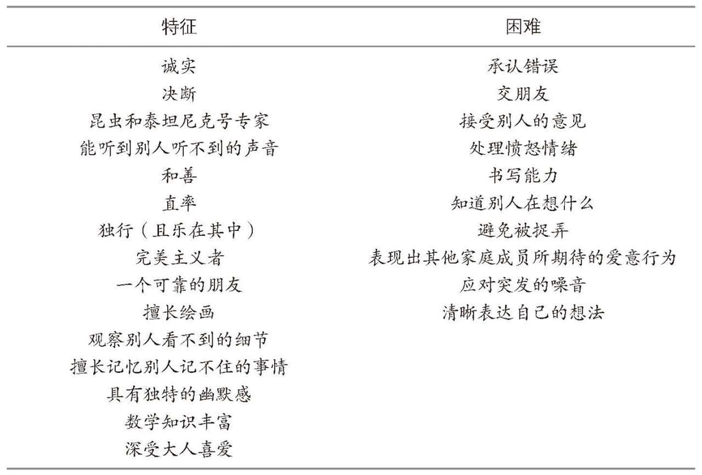

特征认知活动的下一步是继续讨论困难，以及哪些策略可以在家里和学校提升特定能力，包括提高社会理解力的方案，有助于情绪管理的认知行为治疗和药物治疗，以及改善交友能力的意见和策略。最后，医护人员要总结阿斯伯格综合征所产生的特征和困难，并举例说明某些在科学、信息技术、政治和艺术领域有杰出表现的成功人士，正是得益于阿斯伯格综合征的特征而得以展其特殊的才华（Fitzgerald 2005；James 2006；Ledgin 2002；Paradiz 2002）。

汉斯·阿斯伯格医生提道：

那些在科学和艺术领域有成就的人，好像必须具有一些孤独症的特点。要想获得成功，必须具有逃避日常生活和琐碎事物的能力，还需要有创意，从另一个角度思考，并且能以一种崭新的方式呈现出来，最终把这些能力导向一种专门领域，从而获得非凡的成绩。（Asperger 1979，p.49）

阿斯伯格综合征女性天宝·格兰丁是位颇有成就的工程师、作家和学者。她曾说过：“如果这个世界当初完全交给你们这些社会精英们的话，现在我们一定还在洞穴里交谈。”（来自私下交流）

特征认知活动也可以用在阿斯伯格综合征成人和家人或伴侣身上。与一方是阿斯伯格综合征个体的一对伴侣进行特征认知活动时，我会要求非阿斯伯格综合征的一方说明她/他对另一方的爱，以及第一次见面时对方吸引她/他的特点。我注意到，他/她们提到的阿斯伯格综合征个体特征包括：外表的吸引力（沉默的英俊陌生人）、忠诚、令人印象深刻的聪明才智，以及有创意的想法、具有女性特质、接触过程具有挑战性、交往期间非常殷勤。不过就像其他所有的关系一样，随着时间的推移，某些特征越来越明显，某些特征则慢慢消失，但他们的伴侣关系的有些特征的确与阿斯伯格综合征有关。